# SCIE 326 Final

4. **Derry's example.** All cows are reptiles; All reptiles can fly; Therefore, all cows can fly. Derry calls this "a logically valid syllogism, in a formal sense, even though not a single statement in it is true" (Derry, p. 99). He separates this formal validity from "material" validity: a bad argument is one whose conclusion is untrustworthy, for example because some premises are false, even when its logical form is correct (Derry, pp. 98-99).

5. **Example.** A valid argument with a false conclusion must have a false premise: "When a logically valid argument yields an empirically false conclusion, it means that at least one of the premises of the argument must be empirically false" (Unit 9 Overview). This is the logic of the hypothetico-deductive method: from a hypothesis I deduce, validly, a conclusion that can be tested; if the test shows the conclusion is false, then either the hypothesis or some other assumption used in the deduction is false.

6. **Significance.** Logic can check only the form of a scientific argument; experiment checks its truth. A hypothesis may "feel right" or resemble an accepted theory, but its acceptance "depends on analytic and empirical demonstration" (Unit 9 Overview). Valid deduction turns a hypothesis into a testable prediction, and a failed prediction then counts against the hypothesis.

U9-R06Recall

Explain this topic from the assigned readings: the three laws of Aristotelian logic: the law of identity, the law of contradiction and the law of the excluded middle. Give an example or explain its significance in this unit.

Source Three laws of Aristotelian logic (Discussion 9.2)

1. **Tool of thought.** Aristotle called logic the *organon*, or tool of thought. His three laws "are the rules that must be followed if the conclusion of an argument is to follow as a necessary consequence of the initial premises" (Discussion 9.2). For Aristotle, real knowledge of a thing came from an intuition of its essence, "that which it must have in order to be entitled to its name," and logic worked out the consequences of that intuition. The medieval Schoolmen called the rules the "Laws of Thought."

2. **The three laws.** The course wording, the meaning the discussion gives each law, and the matching rule for truth-values (Discussion 9.2):

[output not shown]

3. **A wording trap.** The course's one-line statement of the excluded middle reads like non-contradiction (nothing has a property and its negation). The explanation that follows gives the real excluded-middle meaning: either the thing has the property or it does not. On the exam give the course line and that meaning.

4. **Propositions only.** The laws apply only to a restricted class of statements: questions, commands and injunctions do not fall under them. "Statements that can have a definite truth value are called propositions" (Discussion 9.2). Even "It is three o'clock" is not a proposition, because its truth value depends on what time it actually is.

5. **Change and modern logic.** The laws eliminate the possibility of change, since a thing that changes has become other than itself; Aristotle dealt with change through the life cycle as an ideal of natural order (Discussion 9.2, footnote 186). For almost 2000 years logic was thought to apply to the world; since the 19th century it is purely formal, dealing with syntax, not semantics. The Aristotelian laws are "not sufficient as a basis for modern logic" but necessary, because truth tables and the assignment of truth-values require them (Discussion 9.2).

6. **Example.** What makes a rose a rose and not a carnation, and lets two people know they are talking about the same thing, is a fixed identity (Discussion 9.2). Rule 1 of the syllogism, that a term keeps the same meaning in premises and conclusion, is "an immediate consequence of the laws of identity and contradiction"; breaking it is equivocation: Light eliminates darkness; Feathers do not eliminate darkness; so Feathers are not light (Discussion 9.2).

7. **Significance.** The laws give words intelligible, stable meanings: a defined term must keep its meaning, and every proposition must be definitely true or false. That makes valid deduction possible, underlies truth tables and the propositional calculus, and in mathematics supplies the basic rules for constructing proofs (Discussion 9.2).

U9-R07Recall

Explain this topic from the assigned readings: the four kinds of categorical proposition and the distribution of their terms. Give an example or explain its significance in this unit.

Source Categorical propositions and distribution (Discussion 9.2)

1. **Categorical propositions.** They are statements about classes (categories) that affirm or deny that a class S (the subject) is included in a class P (the predicate), in whole or in part. There are only four kinds, set by their **quality** (affirmative or negative) and their **quantity** (universal or particular); the four forms are called moods (Discussion 9.2, Tables 9.2.1 and 9.2.2):

| Mood | Name | Form | Subject S | Predicate P |
| --- | --- | --- | --- | --- |
| **A** | Universal affirmative (UA) | All S are P | distributed | undistributed |
| **E** | Universal negative (UN) | No S is P (S is not-P) | distributed | distributed |
| **I** | Particular affirmative (PA) | Some S are P | undistributed | undistributed |
| **O** | Particular negative (PN) | Not all S are P (some S are not-P) | undistributed | distributed |

2. **Distribution.** "A proposition is said to distribute a term if it refers to all members of the class designated by that term" (Discussion 9.2). In All men are mortal, men is distributed (all men are meant) but mortal is not (the proposition does not refer to all mortals). Derry: "Distribution means making a statement about all members of a class" (Derry, p. 100); in all cats are cute, cats is distributed and cute is not.

3. **Memory rule.** **Quantity** decides the subject: universal propositions refer to the whole class S, particular ones do not. **Quality** decides the predicate: affirmative forms never refer to the whole class P, while negative forms exclude S (wholly or in part) from the entire class P. So No gods are mortal refers to the entire class of mortals, since an exclusion must be from the whole class (Discussion 9.2).

4. **Example.** All cats are mammals; All dogs are mammals; so All dogs are cats. Mammals is the predicate of two affirmative premises, so it is never distributed, and the argument commits the fallacy of the undistributed middle (Discussion 9.2). Derry's version: all cats are cute, all dogs are cute, therefore all cats are dogs (Derry, p. 100).

5. **Significance.** Knowing the mood and the distribution of each term is what lets us draw immediate inferences (the square of opposition, converse, obverse and contrapositive) and check syllogisms: Rules 2 and 3 for a valid syllogism are both about distributed terms. Derry warns that people's lives have been destroyed by arguments that leave the middle term undistributed (Derry, p. 100).

U9-R08Recall

Explain this topic from the assigned readings: the square of opposition. Give an example or explain its significance in this unit.

Source Square of opposition (Discussion 9.2)

1. **Immediate inference.** Given the truth-value of one categorical proposition, we can infer the truth-values of the other three with the same subject and predicate. Only one proposition is involved, so these are immediate inferences, and the square of opposition diagrams them (Discussion 9.2, Figure 9.2.1).

2. **The four relations.** Discussion 9.2 defines:

| Relation | Pairs | Rule |
| --- | --- | --- |
| **Contradictories** | A and O; E and I | necessarily opposite truth-values: exactly one is true |
| **Contraries** | A and E | cannot both be true, could both be false |
| **Subcontraries** | I and O | cannot both be false, could both be true |
| **Subalternation** | A to I; E to O | the universal implies its particular: All S are P implies Some S are P; No S is P implies Not all S are P |

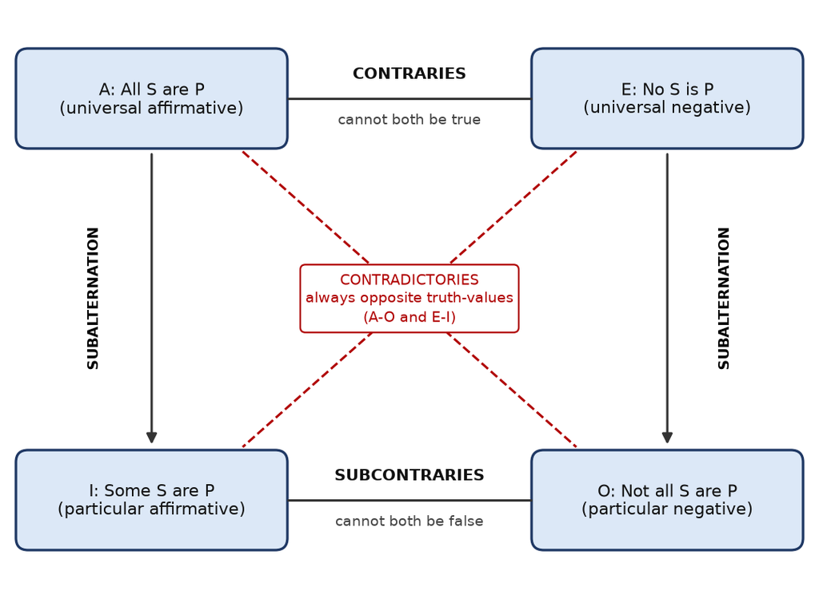

3. **Reading it.** Start from one known truth-value and apply the relations. Subalternation carries truth downward only: a true universal makes its particular true, and a false particular makes its universal false, but a false universal leaves its particular undetermined.

| Given | A | E | I | O |
| --- | --- | --- | --- | --- |
| A true | true | false | true | false |
| E true | false | true | false | true |
| I true | undetermined | false | true | undetermined |
| O true | false | undetermined | undetermined | true |
| A false | false | undetermined | undetermined | true |
| E false | undetermined | false | true | undetermined |
| I false | false | true | false | true |
| O false | true | false | true | false |

4. **Example.** If All men are mortal is true, then Some men are mortal is true (subalternation), No man is mortal is false (contraries) and Not all men are mortal is false (contradictories). If instead we only know that Some swans are white is false, then No swan is white is true (contradictory), so Not all swans are white is true and All swans are white is false.

5. **Significance.** The square is the simplest case of reasoning by the laws of contradiction and the excluded middle: if a proposition is true, its negation must be false (Discussion 9.2). Contradictories are what a counter-example uses: one observed case of an S that is not P (an O proposition) is enough to make All S are P false.

U9-R09Recall

Explain this topic from the assigned readings: the other forms of immediate inference: the converse, the obverse and the contrapositive. Give an example or explain its significance in this unit.

Source Other immediate inferences (Discussion 9.2, Table 9.2.3)

1. **Definitions.** Besides the square of opposition, a categorical proposition with subject S and predicate P gives three more immediate inferences (Discussion 9.2):

| Form | How to form it | Course example from All men are mortal |
| --- | --- | --- |
| **Converse** | swap subject and predicate (for an A proposition, only by limitation, from universal to particular) | Some mortals are men |
| **Obverse** | change the quality (affirmative to negative or back) and replace P by its complement non-P | No man is not mortal |
| **Contrapositive** | replace S by non-P and P by non-S | All non-mortals are not men; in better English, No immortals are human |

2. **Complement.** The complement of a class S is everything not in that class, called not-S or non-S and written S with a bar or S' (Discussion 9.2).

3. **The four moods.** Table 9.2.3 gives each form; some are invalid inferences:

| Proposition | Converse | Obverse | Contrapositive |
| --- | --- | --- | --- |
| All S are P | Some P are S (by limitation) | No S is non-P | All non-P are non-S |
| No S is P | No P is S | All S are non-P | Some non-P are not non-S (by limitation) |
| Some S are P | Some P are S | Some S are not non-P | invalid |
| Some S are not P | invalid | Some S are non-P | Some non-P are not non-S |

4. **Equivalence.** The forms in each row can replace each other in proofs (Discussion 9.2). The forms marked "by limitation" go from a universal to a particular, so they follow from the proposition but are weaker: Some P are S does not give back All S are P.

5. **Example.** The most often used case is the contrapositive of a universal affirmative: it is often easier to prove All S are P by proving All non-P are non-S (Discussion 9.2). The converse is the common trap. Derry: "If taxes are too high, then productivity is low; productivity is in fact low, therefore taxes are too high" assumes the converse, and "A valid argument doesn't imply its converse"; compare "If I am a corporate executive, then I make a good salary" (Derry, p. 99): a good salary does not make me an executive.

6. **Significance.** These rewritings let a scientist restate a claim in the form that is easiest to test or prove, while the invalid cells and the limitations mark the inferences that look natural but do not follow.

U9-R10Recall

Explain this topic from the assigned readings: the vocabulary of the syllogism and its four figures. Give an example or explain its significance in this unit.

Source Syllogism vocabulary and the four figures (Discussion 9.2)

1. **Syllogism.** A syllogism combines two categorical premises to give a conclusion. The inference is mediated rather than immediate, and a valid syllogism yields a conclusion "that is more than just their sum" (Discussion 9.2). So the two premises must share a common term: All cats are furry and On a clear day the sky is blue yield nothing new, but All men are mortal and Socrates is a man yield Socrates is mortal.

2. **Terms and premises.** Discussion 9.2 names the parts:

| Part | Definition | Socrates example |
| --- | --- | --- |
| **Middle term (M)** | in both premises, not in the conclusion (it is divided out) | man (all men) |
| **Minor term (S)** | subject of the conclusion | Socrates |
| **Major term (P)** | predicate of the conclusion | mortal |
| **Major premise** | contains M and P | All men are mortal |
| **Minor premise** | contains M and S | Socrates is a man |

3. **The four figures.** The figure is the order of the terms in the premises (Table 9.2.4):

|  | First figure | Second figure | Third figure | Fourth figure |
| --- | --- | --- | --- | --- |
| Major premise | M-P | P-M | M-P | P-M |
| Minor premise | S-M | S-M | M-S | M-S |
| Conclusion | S-P | S-P | S-P | S-P |

4. **Moods and count.** Each premise is universal or particular and affirmative or negative, so each has 4 moods and a pair of premises has 4 × 4 = 16 moods, written as in (UA, PN): U universal, P particular, A affirmative, N negative, major premise first. 16 moods × 4 figures = 64 possible syllogistic forms, "although most of them are not valid"; only 19 are valid (Discussion 9.2, footnote 188).

5. **Example.** All cats are mammals; Some animals are not mammals; therefore Some animals are not cats. The conclusion makes animals the minor term (S) and cats the major term (P); mammals is the middle term. The major premise is P-M and the minor S-M, so this is the second figure, with mood (UA, PN) (Discussion 9.2).

6. **Significance.** Naming the terms, premises, figure and mood is the first step in assessing any argument in syllogistic form: the rules for validity are stated in these terms (for example, the middle term must be distributed in at least one premise). Syllogisms "provide the reasoning formula for Aristotelian logic" (Discussion 9.2).

U9-R11Recall

Explain this topic from the assigned readings: the six rules for a valid syllogism and the fallacies that break them. Give an example or explain its significance in this unit.

Source Six rules for a valid syllogism (Discussion 9.2)

1. **Validity.** A syllogism is valid when its conclusion follows necessarily from the premises; a valid conclusion "cannot be more general than, its premises" (Discussion 9.2). Breaking any one of six rules gives an invalid syllogism, or fallacy:

[output not shown]

2. **Why the rules hold.** An undistributed middle may refer to different parts of its class in each premise, so it links nothing; two negative premises exclude both terms from the middle class, so again there is no link; and two affirmative premises can only include subject and predicate in the middle class, so they cannot give a negative conclusion (Discussion 9.2).

3. **Lemmas.** From the rules Discussion 9.2 proves: (1) the conclusion is affirmative if and only if both premises are; (2) no valid syllogism has two particular premises; (3) if one premise is particular, the conclusion is particular; (4) no particular major premise with a negative minor premise; (5) the conclusion has at least one fewer distributed term than the premises; (6) first figure: major premise universal, minor premise affirmative; (7) second figure: major premise universal and one premise negative; (8) third figure: minor premise affirmative and conclusion particular; (9) fourth figure: an affirmative major needs a universal minor, a negative premise needs a universal major, and an affirmative minor gives a particular conclusion.

4. **Example.** Check All cats are mammals; Some animals are not mammals; so Some animals are not cats. Mammals (middle) is distributed in the negative minor premise (rule 2); cats is distributed in the conclusion and in the universal major premise (rule 3); animals is undistributed in the conclusion; there is one negative premise and a negative conclusion (rules 4 to 6); every term keeps its meaning (rule 1). The syllogism is valid. Derry's FOPL accusation fails rule 2: the front organization is undistributed in both premises (Derry, p. 100).

5. **Significance.** "These six rules are both necessary and sufficient for insuring the validity of classical syllogisms" (Discussion 9.2), so checking them is a complete test of any argument in syllogistic form, and naming the broken rule identifies the fallacy.

U9-R12Recall

Explain this topic from the assigned readings: the Venn diagram method for syllogisms. Give an example or explain its significance in this unit.

Source Venn diagram method (Discussion 9.2)

1. **Classes as regions.** A class is drawn as a closed curve whose inside stands for its members and outside for its complement. Shading a region means it has no members; an x in a region means it has at least one member. Two overlapping circles show two classes, and shading the overlap makes them mutually exclusive. The diagrams are named after the logician John Venn (1834-1924) (Discussion 9.2). G. Spencer-Brown: "Distinction is perfect continence."

2. **The method.** For a syllogism (Discussion 9.2, Figures 9.2.7 to 9.2.9):

[output not shown]

3. **Example.** Every cat likes to eat mice; Felix is a cat; so Felix likes to eat mice. Shade the cat circle outside likes to eat mice, then the Felix circle outside cats: the only unshaded part of Felix lies inside likes to eat mice, so the syllogism is valid. Every cat likes to eat mice; Every dog likes to eat mice; so Every dog is a cat: after shading, parts of the dog circle lie outside the cat circle but inside likes to eat mice, so nothing restricts dogs to being cats and the syllogism is invalid (Discussion 9.2).

4. **Significance.** The diagram gives "a topological way of evaluating syllogisms without having to worry about the conclusiveness requirement on the middle term" (Discussion 9.2): the construction itself takes care of the middle term. It is a visual check that agrees with the six rules, and diagrams in general are useful aids in thinking.

U9-R13Recall

Explain this topic from the assigned readings: the logical connectives and how to build a truth table. Give an example or explain its significance in this unit.

Source Logical connectives (Discussion 9.2, Table 9.2.5)

1. **Propositional calculus.** Aristotelian syllogisms are a restricted form of class inclusion inference about things; a propositional calculus deals instead with the truth or falsity of propositions based strictly on their form. George Boole (1815-1864) developed an algebraic formalism for Aristotle's logic, and the course credits Ludwig Wittgenstein with the truth table, its basic element (Discussion 9.2).

2. **The connectives.** "and" (∧), "or" (∨, inclusive: true if either or both are true), "implies" (→) and "if and only if" (↔), with negation "not" (¬) added for completeness (Discussion 9.2, Table 9.2.5):

| P | Q | P∧Q | P∨Q | P→Q | P↔Q | ¬P |
| --- | --- | --- | --- | --- | --- | --- |
| T | T | T | T | T | T | F |
| T | F | F | T | F | F | F |
| F | T | F | T | T | F | T |
| F | F | F | F | T | T | T |

3. **Reading the table.** P→Q is false only when P is true and Q false: "a true statement cannot imply a false statement, but a false statement can imply a true statement or a false statement" (Discussion 9.2), so a false statement implies anything (rows 3 and 4). P↔Q has the same column as (P→Q)∧(Q→P), and statements with the same truth-values are equivalent (Table 9.2.6).

4. **Building a truth table.** Give each variable a column; there are 2<sup>n</sup> rows for n variables (4 for two, 8 for three). In the rightmost variable column write T and F alternately; in the next column to the left write them in pairs (T, T, F, F); in the next, in fours (four Ts then four Fs), doubling each time. Then compute the innermost brackets first and work outward to the whole statement (Discussion 9.2).

5. **Example.** For (P∧Q)→R and (P∧Q)∨R (Table 9.2.7), compute P∧Q first:

| P | Q | R | P∧Q | (P∧Q)→R | (P∧Q)∨R |
| --- | --- | --- | --- | --- | --- |
| T | T | T | T | T | T |
| T | T | F | T | F | T |
| T | F | T | F | T | T |
| T | F | F | F | T | F |
| F | T | T | F | T | T |
| F | T | F | F | T | F |
| F | F | T | F | T | T |
| F | F | F | F | T | F |

6. **Significance.** Truth tables are rarely used in actual research reasoning, which runs on looser plausibility, but they help in experimental design: to test P implies Q, only P present with Q absent can falsify it, so the experiment must look for that case; tests where P and Q both occur, or neither does, cannot falsify it. Even if Q always follows P, that suggests but does not prove that P causes Q, "because causation is not the same as logical implication" (Discussion 9.2).

### Key term questions18

U9-T01Term

Define or distinguish Proposition. Give an example and explain its role in this unit.

1. **Definition.** A proposition is a statement that has a definite truth value, either true or false (Discussion 9.2).

2. **Example.** "Water boils at 100 °C at sea-level pressure" is a proposition. "Close the door" and "Is it raining?" are not.

3. **Role in this unit.** The three Aristotelian laws apply only to propositions: each has a constant truth value, cannot be both true and false, and must be one or the other.

4. **Distinction.** Discussion 9.2 even excludes "It is three o'clock," because its truth changes with the time. A proposition must have a fixed truth value.

5. **Significance.** Propositions are the units of truth tables and of the propositional calculus, which judges arguments by form alone.

U9-T02Term

Define or distinguish Categorical proposition. Give an example and explain its role in this unit.

1. **Definition.** A categorical proposition is a statement about classes that affirms or denies that class S is included in class P, wholly or in part (Discussion 9.2).

2. **Forms.** There are four: A "All S are P," E "No S is P," I "Some S are P," O "Some S are not P."

3. **Example.** "No reptiles are mammals" is an E proposition about the classes of reptiles and mammals.

4. **Role in this unit.** These are the building blocks of immediate inference (the square of opposition) and of syllogisms, and they can be drawn as Venn diagrams.

5. **Distinction.** A compound proposition such as "if p then q" is treated by the propositional calculus, not by class logic.

U9-T03Term

Define or distinguish Quality / quantity. Give an example and explain its role in this unit.

1. **Quality** is whether a categorical proposition affirms or denies inclusion (affirmative or negative). **Quantity** is whether it refers to the whole subject class or to part of it (universal or particular).

2. **The four combinations.** A = universal affirmative, E = universal negative, I = particular affirmative, O = particular negative.

3. **Example.** "Some samples are not contaminated" is negative in quality and particular in quantity: an O proposition.

4. **Role.** Quantity decides whether the subject is distributed, and quality decides whether the predicate is distributed (Table 9.2.2).

5. **Use.** The validity rules depend on them: two negative premises cannot give a valid syllogism, and a particular premise forces a particular conclusion.

U9-T04Term

Define or distinguish Distributed term. Give an example and explain its role in this unit.

1. **Definition.** A term is distributed in a proposition when the proposition refers to every member of the class it names (Discussion 9.2; Derry p. 100).

2. **Rule.** Universal propositions distribute the subject; negative propositions distribute the predicate. So A distributes S only, E both, I neither, and O the predicate only.

3. **Example.** In "All men are mortal," *men* is distributed but *mortal* is not, since the statement says nothing about all mortals. In "No gods are mortal," *mortal* is distributed, because the gods are excluded from the whole class of mortals.

4. **Role.** Two validity rules use it: the middle term must be distributed at least once, and no term may be distributed in the conclusion unless it was distributed in its premise.

5. **Significance.** Derry's FOPL case shows real harm from an undistributed middle: "some members of the FOPL are Communists" does not make every member a Communist.

U9-T05Term

Define or distinguish Immediate inference. Give an example and explain its role in this unit.

1. **Definition.** An immediate inference draws a conclusion from a single proposition (Discussion 9.2).

2. **Kinds.** The square-of-opposition relations (contradictory, contrary, subcontrary, subalternation), and the converse, obverse and contrapositive forms.

3. **Example.** From "All men are mortal": the obverse "No man is non-mortal," the contrapositive "All non-mortals are non-men" (no immortals are human), the converse by limitation "Some mortals are men," and, by contradiction, "Not all men are mortal" is false.

4. **Distinction.** It uses one premise; a mediated inference (a syllogism) needs two linked by a middle term.

5. **Care.** Some forms are invalid: the converse of an O proposition and the contrapositive of an I proposition do not follow.

Note*Course slip: Discussion 9.2 defines the converse as "obtained from r by changing its quality," the same wording as the obverse. The converse actually swaps subject and predicate; for an A proposition the quantity is limited (All to Some), as its own example "Some mortals are men" shows.*

U9-T06Term

Define or distinguish Mediated inference / syllogism. Give an example and explain its role in this unit.

1. **Definition.** A mediated inference combines two categorical propositions (premises) that share a middle term to reach a conclusion. This form is the syllogism (Discussion 9.2).

2. **Example.** "All men are mortal; Socrates is a man; therefore Socrates is mortal." The middle term, *man*, links the premises and drops out of the conclusion.

3. **Requirement.** The premises must share a term; "All cats are furry" and "On a clear day the sky is blue" yield nothing but their sum.

4. **Role.** It is Aristotle's model of deduction: what is true of all members of a class is true of each one. Its validity is judged by the six rules or by a Venn diagram.

5. **Distinction.** Derry calls syllogisms without conditional premises "categorical syllogisms" (p. 91); conditional premises lead into the propositional calculus.

U9-T07Term

Define or distinguish Figure. Give an example and explain its role in this unit.

1. **Definition.** The figure of a syllogism is the arrangement of the middle term in its two premises (Discussion 9.2).

2. **The four figures.** First: M-P, S-M. Second: P-M, S-M. Third: M-P, M-S. Fourth: P-M, M-S. The conclusion is always S-P.

3. **Example.** "No reptiles are mammals; some pets are reptiles; therefore some pets are not mammals" has M-P and S-M: first figure.

4. **Role.** Each figure has its own validity conditions. In the first figure the major premise must be universal and the minor premise affirmative; in the second, one premise must be negative.

5. **Significance.** Figure plus the quality and quantity of the propositions identifies a syllogistic form (64 in the course's count, 19 valid).

U9-T08Term

Define or distinguish Mood. Give an example and explain its role in this unit.

1. **Definition.** A mood is the pattern of quality and quantity of the propositions in an argument. Table 9.2.1 also calls the four kinds of categorical proposition (A, E, I, O) "moods."

2. **In syllogisms.** The course counts 16 possible combinations of major and minor premise for each figure (for example, UA with PN), giving 64 forms.

3. **Example.** "All cats are mammals; some animals are not mammals; therefore some animals are not cats" has a universal affirmative major premise and a particular negative minor premise: (UA, PN), or AOO including the conclusion, in the second figure.

4. **Role.** Mood together with figure determines validity: AAA in the first figure is valid, while AAA in the second is the undistributed middle.

5. **Significance.** It lets us judge an argument by its form alone, without regard to content.

Note*Outside the readings: traditional logic names the valid forms by their vowels, for example Barbara (AAA, first figure) and Ferio (EIO, first figure).*

U9-T09Term

Define or distinguish Fallacy. Give an example and explain its role in this unit.

1. **Definition.** In this unit, a fallacy is an invalid syllogism: one that breaks at least one of the six rules, so its conclusion does not follow (Discussion 9.2).

2. **Types.** Equivocation (four terms), undistributed middle, illicit major and illicit minor (over-generalization), exclusive premises, an affirmative conclusion from a negative premise, and exclusive inclusion.

3. **Example.** "All cats are cute; all dogs are cute; therefore all cats are dogs" (undistributed middle, Derry p. 100).

4. **Distinction.** A fallacy is a defect of *form*. A valid argument can still have a false conclusion if a premise is false; that is not a fallacy. Derry also names informal fallacies (straw man, ad hominem, false dilemma) that mislead without any logical form.

5. **Significance.** Spotting a fallacy lets us reject an argument without having to judge its premises (Derry p. 91).

U9-T10Term

Define or distinguish Essence. Give an example and explain its role in this unit.

1. **Definition.** For Aristotle, the essence of a thing is "that which it must have in order to be entitled to its name" (Discussion 9.2).

2. **Example.** Having three sides is essential to a triangle; colour and size are not. A four-sided figure therefore cannot be a triangle.

3. **Role.** Aristotle thought knowledge came from intuiting essences and then deducing all other properties from them by logic. Logic validates intuitions rather than replacing them.

4. **Link to the principles.** The identity of indiscernibles groups things with no *essential* difference under one name, at a stated level: lions and tigers share the feline essence but differ in species.

5. **Limit.** Essences assume fixed, unchanging kinds, which fits stable objects better than growing, evolving or changing ones (Footnote 186).

U9-T11Term

Define or distinguish Abduction. Give an example and explain its role in this unit.

1. **Definition.** Abduction, Peirce's third form of inference, is inference to the best explanation: choosing the explanation that best fits a surprising fact or a set of clues (Discussion 9.1).

2. **Form.** All the balls in bag A are black; this ball is black; therefore this ball probably came from bag A.

3. **Example.** When milkers who had had true cowpox caught smallpox, Jenner inferred that cowpox matter protects only at its strongest stage, the explanation that fitted all his records (Derry pp. 23-24).

4. **Role.** Together with induction, it generates hypotheses in the hypothetico-deductive method; deduction then tests them.

5. **Limit.** Its conclusion is only probable. Other explanations may fit, and logically it resembles affirming the consequent, so the explanation must still be tested.

U9-T12Term

Define or distinguish Problem of induction. Give an example and explain its role in this unit.

1. **Definition.** The problem of induction is that no certain justification exists for inferring a general law from a finite number of cases. There is no formal "logic of discovery" that proves inductive conclusions (Discussion 9.1; Derry p. 190).

2. **Example.** "The sun has always risen in the east, so it always will." Elements were shown "innumerable times" to be unchangeable, until radioactivity proved otherwise around 1900 (Derry pp. 199-200).

3. **Why it is unsolved.** Justifying induction by its past success is itself an inductive argument and so assumes what it sets out to prove (Derry p. 199).

4. **Role in this unit.** It is why induction and abduction can only *suggest* hypotheses, while deduction from those hypotheses provides the tests.

5. **Response.** Falsificationism turns the question around: theories are accepted provisionally while they survive tests, because a failed prediction can refute a theory but successes cannot prove it (Derry p. 200).

U9-T13Term

Define or distinguish Hypothetico-deductive method. Give an example and explain its role in this unit.

1. **Definition.** The hypothetico-deductive method forms a hypothesis from observations (by induction or abduction), deduces testable consequences from it, and compares them with observation (Discussion 9.1; Derry p. 24).

2. **Logic.** If H → P and P fails, then H, or another assumption used in the deduction, is false (contrapositive). If P holds, H gains support but is not proved.

3. **Example.** Jenner's hypothesis that full-strength cowpox matter protects led to the 1796 Phipps experiment.

4. **Role in this unit.** It shows all four polarities working together: bottom-up synthesis and induction to form the hypothesis, then top-down analysis and deduction to test it.

5. **Caveat.** The starting data are theory-laden, and real research uses looser plausibility arguments than textbook steps suggest.

U9-T14Term

Define or distinguish Theory-laden data. Give an example and explain its role in this unit.

1. **Definition.** Data are theory-laden when they are collected and interpreted within a conceptual framework that decides which data are relevant and which questions are significant (Discussion 9.1).

2. **Example.** "The sun rises in the east" uses concepts of "sun" and "east" that meant something very different to the ancient Druids than to us (Derry pp. 198-199).

3. **Role in this unit.** It adds a top-down element to the supposedly bottom-up start of the hypothetico-deductive method.

4. **Consequence.** If observations already contain theory, it is circular to say that they prove the theory, which undermines strict empiricism and logical positivism (Derry p. 199).

5. **Balance.** How much this weakens empirical testing is disputed; some think it rules out objective science, while others see only a need for small adjustments to empiricism.

Note*Derry credits the term to "N. R. Hansen"; the philosopher is Norwood Russell Hanson (Patterns of Discovery, 1958).*

U9-T15Term

Define or distinguish Tautology. Give an example and explain its role in this unit.

1. **Definition.** A tautology is a proposition that is true for every assignment of truth values to its parts (Unit 9 Study Question 11).

2. **Example.** p ∨ ¬p (the law of the excluded middle), or De Morgan's law ¬(p ∨ q) ↔ (¬p ∧ ¬q).

3. **How to show it.** Construct the truth table: the final column is T in every row.

4. **Role in this unit.** A tautological conditional is a valid inference form; for example, ((p → q) ∧ p) → q is modus ponens. A tautological biconditional shows that two expressions are logically equivalent and can replace each other.

5. **Distinction.** A tautology is true by form alone and says nothing about the world; its opposite, a contradiction such as r ∧ ¬r, is false in every row.

U9-T16Term

Define or distinguish Contrapositive. Give an example and explain its role in this unit.

1. **Definition.** The contrapositive of "if p then q" (p → q) is "if not q then not p" (¬q → ¬p). For a categorical A proposition, the contrapositive of "All S are P" is "All non-P are non-S" (Discussion 9.2).

2. **Equivalence.** The two always have the same truth table, so each can replace the other in a proof (Study Question 10).

3. **Example.** "All men are mortal" has the contrapositive "All non-mortals are non-men," or "No immortals are human."

4. **Role.** It underlies falsification: if hypothesis H implies prediction P and P fails, then H fails (modus tollens). It also tells us which cases to examine, such as the odd-number card in the four-card task.

5. **Distinction.** The converse (q → p) and the inverse (¬p → ¬q) are *not* equivalent to p → q; using them gives Derry's converse and inverse fallacies (pp. 99-100).

U9-T17Term

Define or distinguish Principle of equal a priori probabilities. Give an example and explain its role in this unit.

1. **Definition.** Given a set of possibilities and no prior information to distinguish between them, the best estimate is that each is equally probable (Discussion 9.1).

2. **Example.** With no information about a die, each face is assigned a probability of 1/6. With two sealed boxes and no clue, each is given 1/2.

3. **Role in this unit.** It is the statistical form of the principle of sufficient reason: with no reason to prefer one possibility, none is preferred, just as an equally loaded balance does not tip.

4. **Link.** It is connected with symmetry and with the principles of simplicity in later units.

5. **Limit.** The probabilities must be revised once evidence distinguishes the possibilities; the principle is a starting point, not a result.

U9-T18Term

Define or distinguish Principle of least action. Give an example and explain its role in this unit.

1. **Definition.** Of all the possible ways a physical system could evolve, the one it actually takes is the one for which the quantity called "action" is minimal (Discussion 9.1).

2. **Origin.** It comes from the "efficient" interpretation of sufficient reason, Leibniz's optimality principle of the greatest result for the least effort, championed by Maupertuis.

3. **Example.** A ray of light between two points follows the path that takes the least time, which is why light bends when it passes from air to water.

4. **Role in this unit.** Stripped of its theological origins, it runs through modern physics. Accounting for facts by an optimality principle is taken as sufficient reason to accept a theory as a possible explanation.

5. **Link.** Optimality and symmetry principles return in later units.

Note*The light example is the related principle of least time (Fermat), a classic optimality principle from outside the readings.*

### Applied written questions16

U9-A01Applied5 marks

Give one argument that is valid with a false conclusion and one that is invalid with a true conclusion. Explain why truth alone cannot establish validity.

Source Unit 9 Overview; Discussion 9.2

1. **Valid, with a false conclusion.** "All mammals can fly; pigs are mammals; therefore pigs can fly" (Unit 9 Overview). The form is valid (first figure, AAA): if both premises were true, the conclusion would have to be true. The conclusion is false because the major premise is false.

2. **Invalid, with a true conclusion.** "All dogs are animals; some animals are mammals; therefore all dogs are mammals." The conclusion happens to be true, but the middle term "animals" is never distributed (the predicate of an affirmative premise, then the subject of a particular one), so the conclusion does not follow.

3. **Proof that the second form is invalid.** Keep the form and change the content: "All dogs are animals; some animals are fish; therefore all dogs are fish." The premises are true and the conclusion is false. A valid form can never do that, so the form is invalid.

4. **Why truth cannot establish validity.** Validity is a property of form: it says that *no* argument of that shape can lead from true premises to a false conclusion. A single true conclusion shows only that this instance happened to come out right, not that every instance must. Derry adds that the truth of a conclusion "doesn't tell us anything about the truth or falseness of the premises" (p. 91).

5. **What validity does give.** In a valid argument with a false conclusion, at least one premise must be false. That is why validity, and not truth alone, is what lets the hypothetico-deductive method reject a hypothesis.

U9-A02Applied5 marks

Classify the inferences as deduction, induction or abduction: a theory predicts a measurement; repeated measurements suggest a general law; an unexpected measurement suggests a hidden source. Explain their different limitations.

Source Discussion 9.1

1. **Deduction:** a theory predicts a measurement. The prediction follows from the theory and the conditions by logical necessity: the general gives the particular.

2. **Induction:** repeated measurements suggest a general law. A finite set of cases is generalized to all cases.

3. **Abduction:** an unexpected measurement suggests a hidden source. This is inference to the best explanation of a surprise; for example, irregularities in the orbit of Uranus led astronomers to propose an unseen planet, Neptune.

4. **Different limitations.** A deduction is only as reliable as its premises, including auxiliary assumptions about instruments and conditions; a valid deduction from a false theory gives a false prediction. Induction suffers from the problem of induction: no finite number of measurements guarantees the law, and a new case can overturn it, as when elements proved changeable (Derry pp. 199-200). Abduction picks the best explanation *among those we have thought of*: another hidden source, an instrument fault or a false assumption might fit as well, and its form resembles affirming the consequent.

5. **How they work together.** Induction and abduction propose hypotheses, and deduction turns them into testable predictions. Only the test can confirm, provisionally, or refute them.

Note*Outside Unit 9: the prediction of Neptune from Uranus's orbit (1846) is a standard history-of-astronomy example.*

U9-A03Applied10 marks

Using an original scientific example, trace top-down and bottom-up reasoning through hypothesis formation, prediction, testing and revision. Include analysis and synthesis.

Source Discussion 9.1

**Example: what causes stomach ulcers?** For decades, ulcers were blamed on stress and excess stomach acid.

1. **Theory-laden start (top-down).** The stress-and-acid framework decided which data seemed relevant; bacteria were assumed unable to survive in stomach acid, so they were not looked for. The questions we ask come from a prior framework.

2. **Bottom-up observation.** The pathologist Robin Warren nevertheless saw curved bacteria in biopsies of inflamed stomach linings. This is data about components, gathered from the bottom up.

3. **Analysis.** The biopsies were broken down by tissue, inflammation and presence of bacteria, and the bacteria were cultured and identified (*Helicobacter pylori*). Analysis asks what the essential components are.

4. **Hypothesis by induction and abduction.** Repeated co-occurrence of the bacteria with gastritis and ulcers (induction), and the bacteria as the best explanation for inflammation that acid alone did not explain (abduction), gave the hypothesis H: *H. pylori* infection causes most ulcers.

5. **Synthesis.** The hypothesis combined separate strands (the biopsy findings, the frequent return of ulcers after acid treatment, and the bacterium's ability to survive acid) into one structural account of the disease.

6. **Top-down deduction of predictions.** If H is true, then (a) infecting a healthy stomach should produce gastritis, and (b) killing the bacteria with antibiotics should cure ulcers and stop them from returning. This is analysis working downward from the hypothesis to specific, testable consequences.

7. **Testing.** Barry Marshall drank a culture of the bacterium and developed gastritis; clinical trials showed that antibiotic treatment healed ulcers with far fewer relapses than acid-reducing drugs alone. The predictions fitted, which supports H but does not prove it (affirming the consequent).

8. **Revision prompted by misfit.** Not everyone infected develops an ulcer, and some ulcers occur without the bacterium. By non-contradiction, H as a universal claim ("infection always causes ulcers") had to be revised: it became "infection is a major cause, acting with host factors," with a second cause (anti-inflammatory drugs such as aspirin) recognized separately.

9. **Structural and functional.** The account is structural (how the bacterium damages the stomach lining) and is tested by its function in the whole patient (whether removing it cures the disease).

10. **The cycle.** The investigation alternated between the poles (framework, observation, analysis, synthesis, deduction, test and revision) exactly as Discussion 9.1 describes: neither pole alone would have overturned the acid theory.

Note*Outside the readings: Warren and Marshall's work dates from 1979-1985 (Marshall's self-experiment was in 1984); they received the 2005 Nobel Prize in Physiology or Medicine.*

U9-A04Applied5 marks

State the A, E, I and O categorical forms using a single subject and predicate. Identify the quantity, quality and distributed terms in each.

Source Discussion 9.2

Subject S = metals; predicate P = conductors.

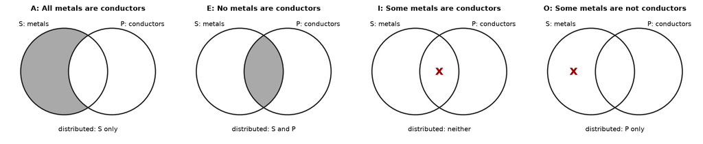

1. **A, "All metals are conductors."** Quantity universal, quality affirmative. S is distributed; P is not (it says nothing about all conductors).

2. **E, "No metals are conductors."** Universal negative. Both S and P are distributed: every metal is excluded from the whole class of conductors.

3. **I, "Some metals are conductors."** Particular affirmative. Neither term is distributed.

4. **O, "Some metals are not conductors."** Particular negative. S is not distributed; P is distributed, because those metals are excluded from the entire class of conductors.

5. **Rule behind the pattern.** Quantity decides the subject (universal distributes S) and quality decides the predicate (negative distributes P) (Discussion 9.2, Table 9.2.2). Only A is true of the real world here.

U9-A05Applied10 marks

Explain contradictory, contrary, subcontrary and subaltern relations. State the nonempty-class assumption needed for the traditional square of opposition and consider what changes for an empty subject class.

Source Discussion 9.2

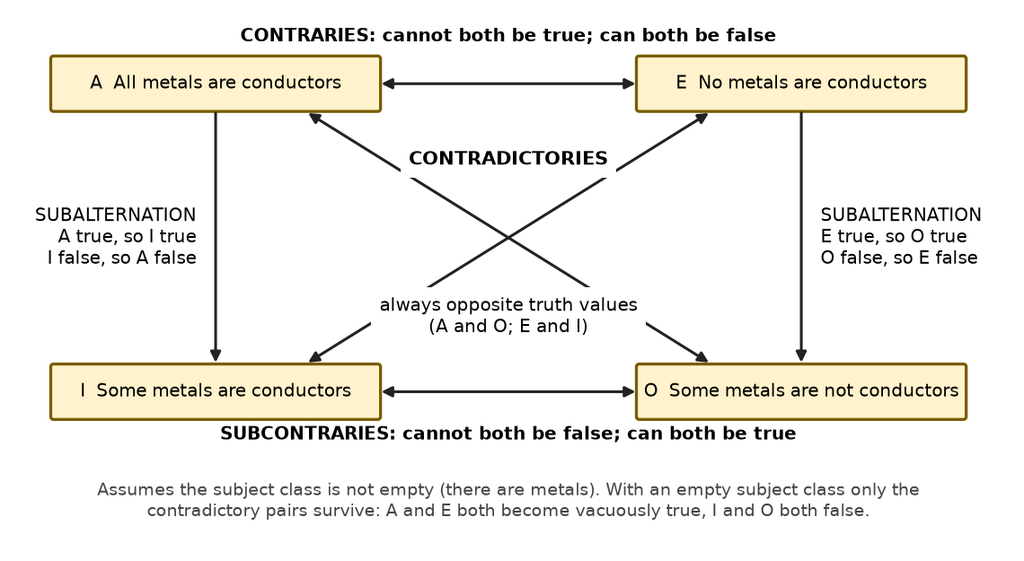

1. **Contradictories (A-O and E-I)** always have opposite truth values: exactly one is true. "All metals are conductors" and "Some metals are not conductors" cannot both be true or both be false.

2. **Contraries (A-E)** cannot both be true but can both be false. "All students passed" and "No students passed" are both false if results were mixed.

3. **Subcontraries (I-O)** cannot both be false but can both be true. "Some students passed" and "Some did not" are both true in the mixed case.

4. **Subalternation (A to I, E to O).** A true universal makes its particular true; a false particular makes its universal false. A false universal, or a true particular, settles nothing.

5. **Immediate inferences.** Given one truth value, the square lets us infer others; for example, if I is false, then E is true (contradictory), A is false (subalternation) and O is true (subcontrary).

6. **The nonempty-class assumption.** The traditional square assumes existential import: the subject class has at least one member. "Some S are P" is read as "there is at least one S, and it is P," and the universals are taken to be about existing S.

7. **Empty subject class.** Take "unicorns." In the modern (Boolean) reading, "All unicorns are white" and "No unicorns are white" are both vacuously true, because there is no unicorn to break either. "Some unicorns are white" and "Some unicorns are not white" are both false, because there is no unicorn at all.

8. **What breaks.** Contraries fail (A and E are both true); subcontraries fail (I and O are both false); subalternation fails (A is true but I is false).

9. **What survives.** The contradictory pairs still hold. A says "nothing is S and not P," O says "something is S and not P," and exactly one of these is true whether or not S is empty. The same holds for E and I.

10. **Lesson.** Before reasoning around the square, state the assumption that the class has members. Science often deals with classes that may be empty (perpetual-motion machines, a predicted particle), and inferring "some" from "all" there would smuggle in an existence claim.

U9-A06Applied5 marks

Assess: All biologists are scientists; some teachers are biologists; therefore some teachers are scientists. Identify all three terms and premises, give its figure and mood, and draw a Venn diagram.

Source Discussion 9.2

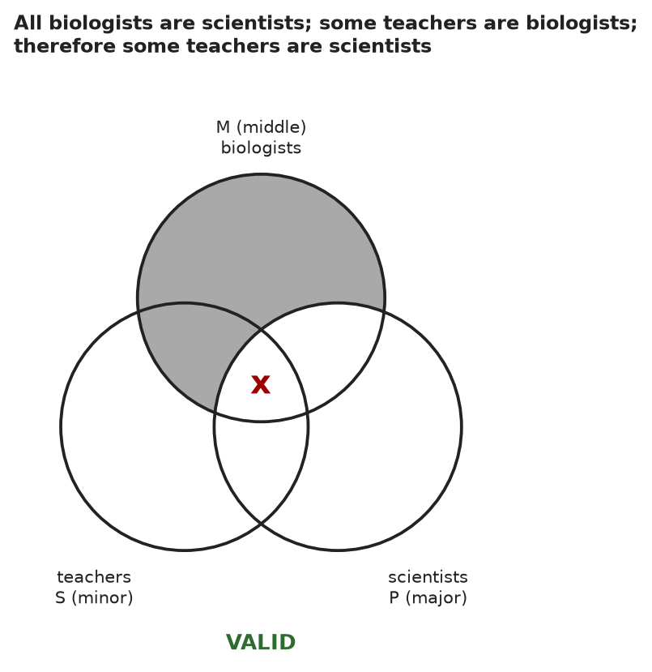

1. **Terms.** The conclusion "Some teachers are scientists" gives the minor term S = teachers and the major term P = scientists. The middle term M = biologists appears in both premises only.

2. **Premises.** The major premise (contains P) is "All biologists are scientists," an A proposition. The minor premise (contains S) is "Some teachers are biologists," an I proposition.

3. **Figure and mood.** M-P and S-M is the first figure; the mood is AII (traditionally *Darii*).

4. **Rules.** M is distributed in the major premise, as the subject of A. The conclusion distributes no term, and there are no negative premises. Every rule is satisfied, so the syllogism is **valid**.

5. **Venn diagram.** Shade biologists outside scientists (major premise). The "some teachers are biologists" x then has only one open place, teachers ∩ biologists ∩ scientists, so it lies inside teachers ∩ scientists: the conclusion is already drawn.

U9-A07Applied5 marks

Assess: All poets are writers; all scientists are writers; therefore all scientists are poets. Use both a distribution rule and a counterexample or Venn diagram.

Source Discussion 9.2

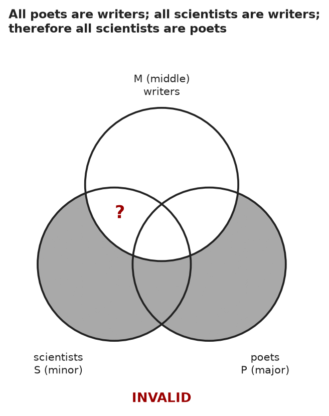

1. **Structure.** S = scientists, P = poets, M = writers. Major premise "All poets are writers" (P-M, A); minor premise "All scientists are writers" (S-M, A); conclusion "All scientists are poets" (A). Second figure, AAA.

2. **Distribution rule.** "Writers" is the predicate of two affirmative propositions, so it is never distributed. The middle term must be distributed at least once, so this is the **fallacy of the undistributed middle**. The premises place poets and scientists inside the class of writers without saying how they relate to each other.

3. **A second check.** In the second figure one premise must be negative (Lemma 7); both premises here are affirmative.

4. **Counterexample.** A physicist who writes textbooks but no poetry is a scientist and a writer but not a poet, so the premises can be true while the conclusion is false. It is the same form as Derry's "all cats are cute; all dogs are cute; therefore all cats are dogs" (p. 100).

5. **Venn diagram.** Shading poets outside writers and scientists outside writers leaves the region "scientists who are writers but not poets" (?) open. The conclusion would need that region to be empty, so it is not forced: **invalid**.

U9-A08Applied5 marks

Assess: No reptiles are mammals; some pets are reptiles; therefore some pets are not mammals. Identify the middle term and explain the inference graphically.

Source Discussion 9.2

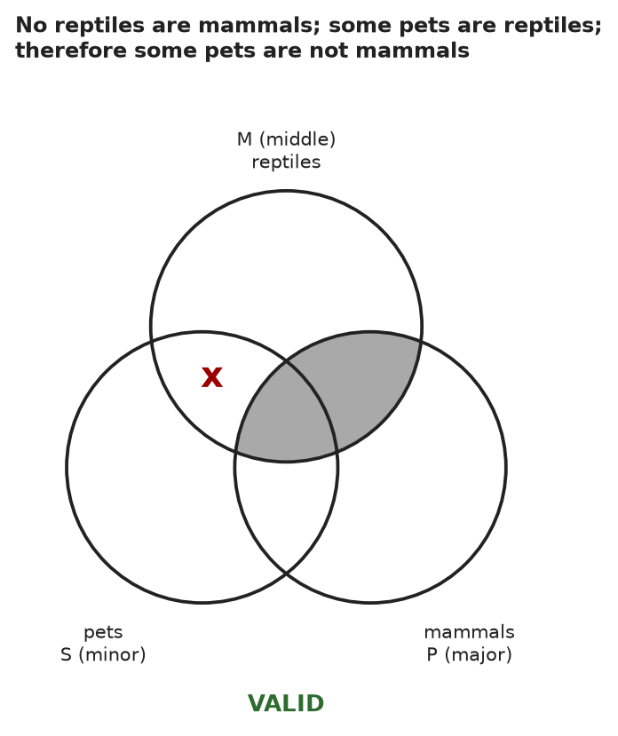

1. **Terms.** S = pets, P = mammals, M = reptiles (the middle term appears in both premises but not in the conclusion).

2. **Form.** Major premise "No reptiles are mammals" (M-P, E); minor premise "Some pets are reptiles" (S-M, I); conclusion "Some pets are not mammals" (O). First figure, EIO (traditionally *Ferio*).

3. **Rules.** M is distributed in the E premise. "Mammals" is distributed in the negative conclusion and also in the E premise. There is one negative premise and a negative conclusion. All rules hold: **valid**.

4. **Graphically.** The E premise shades reptiles ∩ mammals. The I premise needs an x in pets ∩ reptiles, and the only unshaded part of that region lies outside mammals, so the x lands in "pets, reptiles, not mammals."

5. **Reading the result.** That x is a pet outside the mammal circle, which is exactly "some pets are not mammals." The conclusion was drawn by the premises themselves.

U9-A09Applied5 marks

Assess: All samples are labelled; no controls are samples; therefore no controls are labelled. Identify exactly what the premises leave undecided.

Source Discussion 9.2

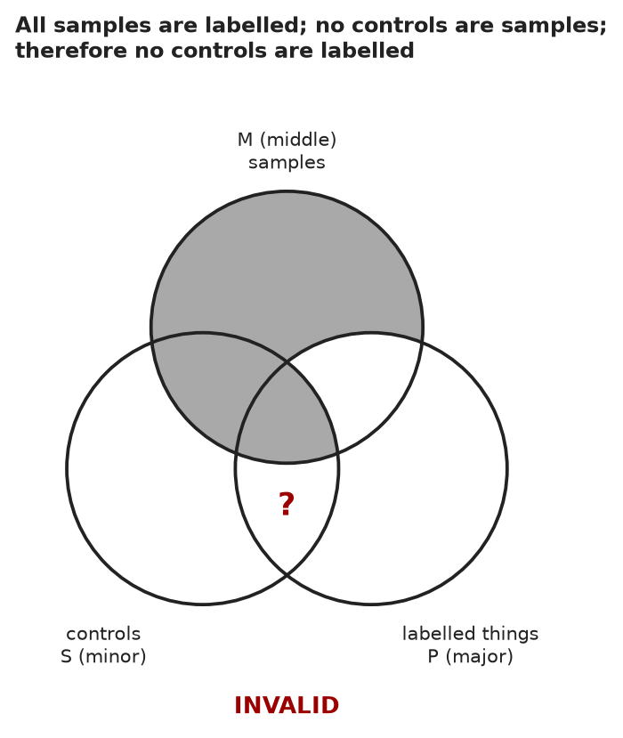

1. **Form.** S = controls, P = labelled things, M = samples. Major premise "All samples are labelled" (M-P, A); minor premise "No controls are samples" (S-M, E); conclusion "No controls are labelled" (E). First figure, AEE.

2. **Fault.** "Labelled" is distributed in the conclusion (the predicate of a negative) but not in the major premise (the predicate of an affirmative). The conclusion says more about labelled things than the premise did: the **illicit major** (Rule 3). In the first figure the minor premise must also be affirmative (Lemma 6). The syllogism is **invalid**.

3. **What the premises leave undecided.** They tell us that every sample is labelled and that no control is a sample. They say *nothing* about things that are labelled but are not samples. Whether any control falls in that group is left open: the region "controls that are labelled but not samples" (?) is neither shaded nor marked.

4. **Concretely.** A laboratory may label its controls too; that is consistent with both premises and makes the conclusion false. Equally, the controls might all be unlabelled. The premises cannot decide between the two.

5. **Valid alternative.** To conclude anything about the controls' labels, we would need a premise such as "Only samples are labelled" (All labelled things are samples), which with "No controls are samples" does validly give "No controls are labelled."

U9-A10Applied5 marks

Construct the truth table for ((p → q) ∧ p) → q. Name the inference represented and explain why its conclusion depends on both premises.

Source Discussion 9.2

| **p** | **q** | **p→q** | **(p→q)∧p** | **((p→q)∧p)→q** |
| --- | --- | --- | --- | --- |
| T | T | T | T | T |
| T | F | F | F | T |
| F | T | T | F | T |
| F | F | T | F | T |

1. **Result.** The final column is T in every row, so the statement is a tautology: the inference it encodes is valid.

2. **Name.** It is *modus ponens* (affirming the antecedent): if p then q; p; therefore q. "All men are mortal; Socrates is a man; therefore Socrates is mortal" has the same logic.

3. **Why both premises are needed.** The conjunction (p → q) ∧ p is true only in the first row, where q is true. Drop the premise p, and the last row (p and q both false) has p → q true with q false. Drop p → q, and the row with p true and q false has p true with q false.

4. **So** neither premise alone guarantees q; only together do they rule out every row in which q is false.

5. **In science.** From an accepted law (if p then q) and the observed condition (p) we deduce the prediction (q). The prediction is only as safe as both the law and the observation.

U9-A11Applied5 marks

Construct the truth table for ((p → q) ∧ q) → p. Identify a counterexample row and connect it to a scientific prediction that comes true.

Source Discussion 9.2

| **p** | **q** | **p→q** | **(p→q)∧q** | **((p→q)∧q)→p** |
| --- | --- | --- | --- | --- |
| T | T | T | T | T |
| T | F | F | F | T |
| F | T | T | T | F |
| F | F | T | F | T |

1. **Result.** The final column has an F, so this is **not** a tautology; the inference is invalid.

2. **Counterexample row.** The third row: p false, q true. Then p → q is true and q is true, but p is false. Both premises hold and the conclusion fails.

3. **Name.** This is *affirming the consequent*, Derry's "converse" error: "If taxes are too high, productivity is low; productivity is low; so taxes are too high," or "If I am an executive I earn a good salary; I do; so I am an executive" (p. 99).

4. **Scientific case.** Let p be "the geocentric (Ptolemaic) model is true" and q be "planet positions appear where the model predicts." The model predicted positions well for centuries, so q was observed, yet p was false. A prediction that comes true is the q-true, p-false row in practice.

5. **Lesson.** A successful prediction supports a hypothesis but cannot prove it; only a failed prediction is logically decisive (modus tollens). That is why theories are accepted provisionally.

Note*Outside Unit 9: the long predictive success of Ptolemy's model is standard history of astronomy.*

U9-A12Applied5 marks

Compare the converse, inverse and contrapositive of p → q. Use truth tables to identify which is equivalent to the original.

Source Discussion 9.2

1. **Definitions.** For p → q: the converse is q → p, the inverse is ¬p → ¬q, and the contrapositive is ¬q → ¬p.

| **p** | **q** | **p→q** | **converse q→p** | **inverse ¬p→¬q** | **contrapositive ¬q→¬p** |
| --- | --- | --- | --- | --- | --- |
| T | T | T | T | T | T |
| T | F | F | T | T | F |
| F | T | T | F | F | T |
| F | F | T | T | T | T |

2. **Equivalent to the original:** only the contrapositive, whose column (T, F, T, T) matches p → q in every row.

3. **Not equivalent:** the converse and the inverse (T, T, F, T) differ from the original in rows 2 and 3. Using them gives Derry's converse and inverse fallacies (pp. 99-100).

4. **Converse and inverse match each other,** because the inverse is the contrapositive of the converse.

5. **Example.** "If it is a dime, it is a coin": the contrapositive "If it is not a coin, it is not a dime" is true, but the converse ("a coin, so a dime") and the inverse ("not a dime, so not a coin") fail, since it may be a nickel (Derry p. 100).

U9-A13Applied5 marks

Test both De Morgan equivalences with truth tables: ¬(p ∨ q) ↔ (¬p ∧ ¬q), and ¬(p ∧ q) ↔ (¬p ∨ ¬q). Explain the change of connective.

Source Discussion 9.2; corrected counterpart to Study Question 11

**First law.**

| **p** | **q** | **¬(p∨q)** | **¬p∧¬q** | **↔** |
| --- | --- | --- | --- | --- |
| T | T | F | F | T |
| T | F | F | F | T |
| F | T | F | F | T |
| F | F | T | T | T |

**Second law.**

| **p** | **q** | **¬(p∧q)** | **¬p∨¬q** | **↔** |
| --- | --- | --- | --- | --- |
| T | T | F | F | T |
| T | F | T | T | T |
| F | T | T | T | T |
| F | F | T | T | T |

1. **Verified.** In each table the two middle columns agree in every row, so each biconditional is a tautology and each pair is logically equivalent.

2. **First law in words.** "Not (p or q)" is true only when neither is true, which is "not p and not q."

3. **Second law in words.** "Not (p and q)" is true whenever at least one of them fails, which is "not p or not q."

4. **The change of connective.** Moving the negation inside the brackets negates each part and swaps ∧ and ∨. Negation turns "at least one" into "none" and "both" into "at least one missing."

5. **Use.** It lets us state exactly what would refute a compound claim: to refute "the drug is safe and effective," we need show only that it is unsafe *or* ineffective.

U9-A14Applied5 marks

Four cards show E, T, 4 and 9. Which must be turned to test the rule that a vowel implies an even number? Explain why each chosen or rejected card matters.

Source Discussion 9.2; variation on Study Question 9

**Turn over E and 9, and only those.** The rule "if a vowel then an even number" is broken only by a vowel paired with an odd number.

1. **E (vowel): turn it.** An odd number on the back would refute the rule directly (p, check for q).

2. **9 (odd, not-q): turn it.** A vowel on the back would refute the rule. This is the contrapositive check: not-q must come with not-p.

3. **T (consonant): leave it.** The rule says nothing about consonants. A false antecedent makes p → q true whatever is on the back.

4. **4 (even): leave it.** Any letter behind it is consistent with the rule. Turning it seeks only confirmation, and reasoning from "even" to "vowel" would be affirming the consequent.

5. **Principle.** Test a conditional where it could fail: the cases with p and the cases with not-q. The same logic tells an experimenter which observations can falsify a hypothesis.

U9-A15Applied5 marks

A prediction follows from H together with auxiliary assumption A and instrument assumption I. The prediction fails. Write the logical form of the result and explain why H alone has not automatically been refuted.

Source Unit 9 Overview; Discussion 9.1

1. **Logical form.** (H ∧ A ∧ I) → P; observation: ¬P; therefore ¬(H ∧ A ∧ I). This is modus tollens, the contrapositive of the prediction.

2. **What that means.** By De Morgan's law, ¬(H ∧ A ∧ I) is equivalent to ¬H ∨ ¬A ∨ ¬I: *at least one* of the hypothesis, the auxiliary assumption or the instrument assumption is false. Logic does not say which.

3. **Why H survives.** The prediction never followed from H alone, so its failure refutes only the conjunction. The Unit 9 Overview states it exactly: either "the hypothesis, or some other assumption involved in the deduction, is false."

4. **Example.** When Uranus strayed from its predicted orbit, astronomers kept Newton's law (H) and rejected the auxiliary assumption that no unknown planet was pulling on it. That led to the discovery of Neptune. Instrument checks (I) are routinely the first suspect when a result is surprising.

5. **Practical consequence.** Each assumption must be tested independently (calibrate the instrument, check the auxiliary conditions). If a failure keeps pointing at H, H should be revised; protecting it forever with new auxiliary assumptions would make it untestable.

Note*Outside the readings: philosophers call this the Duhem-Quine problem. Neptune's discovery (1846) is a standard example.*

U9-A16Applied10 marks

Compare non-contradiction, sufficient reason and the identity of indiscernibles using one experimental investigation. Explain how an apparent contradiction could trigger productive revision.

Source Discussion 9.1

**Investigation: Jenner and the smallpox vaccine (Derry ch. 1, pp. 21-24).**

1. **Non-contradiction stated.** A statement that involves a contradiction is false; in empirical work a contradiction shows that an assumption must be checked (Discussion 9.1).

2. **Non-contradiction applied.** Jenner's records showed people who had had "cowpox" and later caught smallpox, against the legend that cowpox protects. Both claims could not stand as stated, so one assumption, that "cowpox" is a single disease, had to give.

3. **Identity of indiscernibles stated.** Things that cannot be distinguished are to be treated as the same; what counts as "the same" depends on the criteria and level of discourse.

4. **Identity of indiscernibles applied.** Farmers had treated every cowpox case as the same disease. Jenner found differences in the pustules, duration and symptoms, so the cases were not indiscernible. He split them into several diseases and named one "true cowpox." A better criterion of identity removed the first contradiction.

5. **Sufficient reason stated.** Nothing happens without a reason why it is so and not otherwise.

6. **Sufficient reason applied.** Some patients were protected and others were not. Rather than dismissing the legend, as other doctors did, Jenner assumed that there must be a reason for the difference, and kept looking for it.

7. **The second contradiction.** Milkers who had had *true* cowpox caught smallpox the next year. The hypothesis "true cowpox protects" contradicted the records.

8. **Productive revision.** Seeking a sufficient reason again, Jenner noticed that the disease gains and loses strength, and proposed that the matter protects only at full strength. The failed milkers had caught cowpox at an early stage. He applied the identity of indiscernibles again: true cowpox at different stages is not "the same" with respect to protection.

9. **Test.** The revised hypothesis predicted that full-strength matter would protect a person never exposed before. The 1796 Phipps experiment confirmed it.

10. **Comparison.** Non-contradiction *detected* the problem, sufficient reason *motivated* the search for an explanation, and the identity of indiscernibles *supplied* the fix, by redrawing categories with better criteria. An apparent contradiction is therefore not a dead end but a sign that a category or an assumption needs refining, the same lesson as the non-white swan.

### People and attributions20

U9-P01Person

Identify Rudy Rucker and the idea or contribution the assigned readings ascribe to this person. Explain its significance in this unit.

Source Unit 9 Overview epigraph

1. **Who.** Rudy Rucker is an American mathematician and science-fiction writer. The Unit 9 Overview opens with an epigraph from his book *Mind Tools: The Five Levels of Mathematical Reality* (Unit 9 Overview).

2. **Quotation.** "We really don't know how to formulate all the rules for correct language use. The formal logic that humans have developed deals only with the correct use of certain very special kinds of statements" (Unit 9 Overview).

3. **Meaning.** Formal logic covers only a small, special part of language. In the modern view, logic applies to language usage, to the way we can legitimately use words and evaluate true or false statements, and it "applies to the world only to the extent that our linguistic descriptions fit the world" (Unit 9 Overview). Discussion 9.2 makes the restriction precise: "Statements that can have a definite truth value are called propositions," and questions and commands do not fall under the Aristotelian laws (Discussion 9.2).

4. **Significance.** Because logic tests coherence, not facts, logical validity and empirical truth can disagree. The argument that pigs are mammals and all mammals can fly, so pigs can fly, is valid but empirically false, and "It is a serious mistake to confuse empirical truth and logical validity" (Unit 9 Overview). A valid argument with a false conclusion shows that at least one premise is false, which is what the hypothetico-deductive method relies on.

U9-P02Person

Identify Richard Dawkins and the idea or contribution the assigned readings ascribe to this person. Explain its significance in this unit.

Source Discussion 9.1 epigraph

1. **Who.** Richard Dawkins is a British evolutionary biologist. Discussion 9.1 opens with a remark of his quoted in a *New Yorker* profile of him (Discussion 9.1).

2. **Quotation.** "[W]hen two opposite points of view are expressed with equal intensity, the truth does not necessarily lie exactly halfway between them. It is possible for one side to be simply wrong" (Discussion 9.1).

3. **Meaning.** When two opposite views are equally intense, the intensity is no evidence for either, and the truth is not necessarily halfway; one side may simply be wrong. The discussion does not comment on the epigraph, but its principle of non-contradiction makes a related point: two contradictory views cannot both be true, and "Non-contradictory statements may or may not fit, but those that are contradictory definitely will not" (Discussion 9.1).

4. **Significance.** Supporters of conflicting scientific theories strengthen their side "by providing further reasons why their theory should be chosen as correct," and the community accepts a theory when it has sufficient reason (Discussion 9.1). Sometimes the truth does lie between the extremes: on how far cognitive abilities and social behaviours are genetically determined, the discussion expects that "the more extreme positions of either side will prove false" (Discussion 9.1). Each case is decided by evidence and reasons, not by the intensity of the debate.

U9-P03Person

Identify Alfred North Whitehead (1861-1947) and the idea or contribution the assigned readings ascribe to this person. Explain its significance in this unit.

Source Discussion 9.1 epigraph

1. **Who.** Alfred North Whitehead (1861-1947) was a philosopher (Discussion 4.2; Discussion 13.1). A passage from his *Science and the Modern World*, his Lowell Lectures of 1925, heads the section "Principles of Reason" in Discussion 9.1.

2. **Quotation.** "All the world over and at all times there have been practical men, absorbed in irreducible and stubborn facts; all the world over and at all times there have been men of philosophic temperament, who have been absorbed in the weaving of general principles" (Discussion 9.1).

3. **Meaning.** Two temperaments recur everywhere: practical men absorbed in stubborn facts versus philosophic men weaving general principles. Facts come from experience and general principles from reason. The section then looks for principles of reasoning that are "the analogues of things that appear to be universally true in experience," which joins the two (Discussion 9.1).

4. **Significance.** The same split runs through the polarities of reason: bottom-up reasoning starts from components and data, top-down reasoning from global laws and principles. Science needs both: "It is not a matter of choosing one or the other, but of having a functional balance employing both" (Discussion 9.1). In the hypothetico-deductive method, facts suggest a hypothesis, and consequences deduced from it are tested against new facts.

U9-P04Person

Identify Gottfried Wilhelm von Leibniz (1646-1716) and the idea or contribution the assigned readings ascribe to this person. Explain its significance in this unit.

Source Discussion 9.1

1. **Who.** Gottfried Wilhelm von Leibniz (1646-1716) was a German philosopher and mathematician who also "occasionally acted as a diplomat" (Discussion 9.1).

2. **Three principles.** He strongly emphasized the three principles of reason: non-contradiction, sufficient reason and the identity of indiscernibles. He considered the first two "to be the ultimate foundations of both reason and science" (Discussion 9.1).

3. **Sufficient reason.** His statement of the principle, from the *Monadology*, is that "there can be no fact real or existing, no statement true, unless there be a sufficient reason, why it should be so and not otherwise" (Discussion 9.1). He also suggested, for theological reasons, its efficient interpretation as a principle of optimality.

4. **Calculation.** His primary goal was laws of reason that would let all humans communicate without subjective biases, so that disputes could be resolved by logical and mathematical calculation. He envisioned a universal language, the *characteristica universalis*, and a science of reason, the *calculus ratiocinator*, so that disagreeing parties could sit together and say, "Let us calculate" (Discussion 9.1).

5. **Significance.** Sufficient reason expresses "the fundamental assumption of science": the world is ordered, and this order is comprehensible to human reason (Discussion 9.1). Unit 9 Objective 1 asks you to state the three principles and describe how they are applied in scientific thinking (Unit 9 Overview).

U9-P05Person

Identify Pierre-Louis Moreau de Maupertuis (1698-1759) and Gottfried Wilhelm von Leibniz (1646-1716) and the ideas or contributions the assigned readings ascribe to them. Explain their significance in this unit.

Source Discussion 9.1

1. **Who.** Pierre-Louis Moreau de Maupertuis (1698-1759) was a French scientist. Gottfried Wilhelm von Leibniz (1646-1716) emphasized the principle of sufficient reason (Discussion 9.1).

2. **Idea.** Discussion 9.1 gives a third, "efficient" interpretation of sufficient reason, suggested by Leibniz for theological reasons and espoused by Maupertuis. It is a principle of optimality: "everything in nature is determined according to a principle of maximization and minimization," that is, "the greatest result for the smallest effort" (Discussion 9.1).

3. **Least action.** Stripped of its theological associations, and no longer directly related to sufficient reason, this optimality version is an ancestor of the "principle of least action" found throughout modern physics: of all possible evolutions of a physical system, the one taken is the one for which the action is minimal (Discussion 9.1).

4. **Significance.** In physics, "a sufficient reason for accepting a theory as at least a possible explanation of some set of facts is that the theory accounts for them on the basis of an optimality principle" (Discussion 9.1). The discussion takes up symmetry in Unit 10 and symmetry and optimality principles in Unit 13.

U9-P06Person

Identify Heraclitus (c. 535-475 BCE) and the idea or contribution the assigned readings ascribe to this person. Explain its significance in this unit.

Source Discussion 9.1

1. **Who.** Heraclitus of Ephesus (c. 535-475 BCE) was an early Greek thinker, called "The Obscure," who held that fire was the basic substance (Discussion 7.2). Discussion 9.1 calls him "the philosopher Heraclitus."

2. **Quotation.** In his words, "you cannot step in the same river twice" (Discussion 9.1). The course notes that this line is a paraphrase of his Fragment 91a.

3. **Meaning.** In one sense each experience is unique. So when two experiences appear indistinguishable, we must ask whether they are different experiences of the same thing or experiences of two different things. Two identical white billiard balls rolling at once are two things, identical only as "cue ball" for the game; one ball seen before and after turning away is the same ball, displaced in time and space. A tree planted and seen 10 years later, or you today and last year, raises the harder question of which identity criteria apply (Discussion 9.1).

4. **Significance.** This is the principle of the identity of indiscernibles applied to experience. To put two objects in one category we "must specify the level of discourse and the criteria of identity that we are using to define the category," thinking in terms of a hierarchy of categories (Discussion 9.1).

U9-P07Person

Identify Francis Bacon (1561-1626) and the idea or contribution the assigned readings ascribe to this person. Explain its significance in this unit.

Source Discussion 9.1

1. **Who.** Francis Bacon (1561-1626) was an English philosopher and statesman (dates from Discussion 7.2). He criticized the "empty" speculations of Aristotelian academics and held that the role of knowledge was to reduce human suffering (Unit 13 Overview). A passage from the second book of his *Advancement of Learning* heads the section "Polarities for Reasoning" (Discussion 9.1).

2. **Quotation.** "[A]ll true and fruitful natural philosophy hath a double scale or ladder, ascendant and descendent, ascending from experiments to the invention of causes, and descending from causes to the invention of new experiments" (Discussion 9.1).

3. **Meaning.** Science is a double ladder. Going up, experiments lead to causes: the bottom-up direction of induction and synthesis. Going down, causes lead to new experiments: the top-down direction of deduction and analysis (Discussion 9.1).

4. **Significance.** The hypothetico-deductive method climbs both ways: begin with data and, by induction or abduction, generate an explanatory hypothesis; then deduce consequences that can be tested by observation or experiment. A fit raises confidence, and a misfit calls for adjusting the hypothesis. "The actual process of scientific reasoning involves a continual interplay among these complementary pairs" (Discussion 9.1).

U9-P08Person

Identify C. H. Waddington (1905-1975) and the idea or contribution the assigned readings ascribe to this person. Explain its significance in this unit.

Source Discussion 9.1

1. **Who.** C. H. Waddington (1905-1975) was a biologist who coined the term "chreod" for an equilibrium path of development (Discussion 14.1). A passage from his *Tools for Thought* heads the section on polarities for reasoning, next to Bacon's double ladder (Discussion 9.1).

2. **Quotation.** "One view is that the world consists of things, and that any changes we notice are really secondary, arising from the way things interact with one another. The alternative is that the world consists of processes, and that the things we discern are only stills out of what is essentially a movie" (Discussion 9.1).

3. **Meaning.** The world as things versus the world as processes. In the first view change is secondary, coming from interactions between things; in the second, things are only frames taken from continuing change. The discussion does not develop the passage, but it introduces polarities that are complementary ways of describing one world, used together rather than chosen between.

4. **Significance.** Aristotelian logic suits the world of things: the Aristotelian laws "eliminate the possibility of change, because if something changes, it has become other than itself" (Discussion 9.2), and Study Question 5 asks how the laws "provide a natural way to think about unchanging independent objects" (Unit 9 Study Questions). Things that change, such as a tree that grows for 10 years, need explicit identity criteria (Discussion 9.1).

U9-P09Person

Identify Charles Sanders Peirce and the idea or contribution the assigned readings ascribe to this person. Explain its significance in this unit.

Source Discussion 9.1

1. **Who.** Charles Sanders Peirce was an American logician who first distinguished a third form of inference, called abduction, or inference to the best explanation (Discussion 9.1).

2. **Idea.** When something unusual occurs, the mind automatically seeks an explanation, an answer to the question "why has the expected order of things been altered?", by searching memory or generating possible explanations. Abduction is "simply trying to determine which of the possible explanations for an event gives the best fit" (Discussion 9.1). Choosing between several possibilities on a single clue, or on a variety of apparently unrelated clues, is abductive.

3. **Form.** Deduction: all the balls in that bag are black; these balls are from that bag; so these balls are black. Abduction keeps the major premise and swaps the minor premise and the conclusion: all the balls in that bag are black; these balls are black; so these balls are from that bag. Induction: these balls are from that bag and are black, so all the balls in that bag are black. If bag A has more black balls than bag B, a black ball is probably from bag A (Discussion 9.1).

4. **Significance.** Objective 3 asks for the difference between deductive, inductive and abductive inference (Unit 9 Overview). In the hypothetico-deductive method a hypothesis is generated by induction or abduction and then tested deductively, and Table 9.1.1 pairs induction/abduction with bottom-up reasoning and synthesis (Discussion 9.1).

U9-P10Person

Identify Aristotle (384-322 BCE) and the idea or contribution the assigned readings ascribe to this person. Explain its significance in this unit.

Source Discussion 9.2

1. **Who.** Aristotle (384-322 BCE) was a Greek philosopher (Discussion 3.1). He showed how the Sophists could be refuted by formalizing the rules for valid argument, and he called logic the organon, or tool of thought (Discussion 9.2).

2. **Essence.** Real knowledge of a thing comes from an intuition of its essence, "that which it must have in order to be entitled to its name." Once the essence is grasped, the other properties follow by deduction, so logic validates intuitions and works out their consequences (Discussion 9.2).

3. **Three laws of thought.** The law of identity: "A thing is equal to itself." The law of contradiction: "no thing can ever be other than it is." The law of the excluded middle: "for any given thing and any property, either the thing has that property, or it does not" (Discussion 9.2). The laws exclude change, so to deal with change he introduced the life cycle as an ideal of natural order.

4. **Syllogism.** He classified the ways two categorical propositions sharing a common term combine to yield a conclusion: "All men are mortal" and "Socrates is a man" yield "Socrates is mortal" (Discussion 9.2). There are 19 valid syllogistic forms.

5. **Significance.** For Aristotle logic applied to the world, a view held for almost 2000 years; modern logic deals only with the form of statements, "with syntax, not semantics" (Discussion 9.2). His laws are still basic for deductive argument and are needed to build truth tables.

U9-P11Person

Identify Plato (427-347 BCE) and the idea or contribution the assigned readings ascribe to this person. Explain its significance in this unit.

Source Discussion 9.2 epigraph

1. **Who.** Plato (427-347 BCE) was a Greek philosopher (Unit 3 Overview). Discussion 9.2 opens with a passage from his dialogue *Euthydemus* (Discussion 9.2).

2. **Epigraph.** One speaker gets Ctesippus to admit that he has a dog, that the dog has puppies and so is their father, and that the dog is his. He then concludes: "Then being a father he is yours, so the dog becomes your father and you the puppies' brother" (Discussion 9.2).

3. **Meaning.** Plato parodied empty rhetoric. In early Greek thought "the basic principles of rational argument had not at that time been worked out," and "empty rhetoric often took the place of valid reasoning" (Discussion 9.2). The discussion does not analyze the argument, but its trick is that "yours" shifts meaning, from a dog you own to a father who is yours. The modern law of identity forbids this: "once a term has been defined, its meaning cannot legitimately be changed in further discussions" (Discussion 9.2).

4. **Significance.** Sophistry, the use of invalid arguments to present "the semblance of truth, rather than truth itself," is what formal logic was built to refute (Discussion 9.2). Objective 5 asks how the three laws of Aristotelian logic establish intelligible meanings for words (Unit 9 Overview).

U9-P12Person

Identify Immanuel Kant (1724-1804) and the idea or contribution the assigned readings ascribe to this person. Explain its significance in this unit.

Source Discussion 9.2

1. **Who.** Immanuel Kant (1724-1804) was a German philosopher, author of *The Critique of Pure Reason* (Discussion 1.1). Discussion 9.2 calls it his "famous book."

2. **Idea.** In the Preface to the Second Edition (1787) of that book, Kant lamented that although logic was the first science to be developed, preceding even mathematics, it had changed not at all in the more than 2000 years since its birth (Discussion 9.2).

3. **Context.** For his time he was nearly right. Aristotelian logic had changed little since it was formalized; in the Middle Ages it was studied in detail and elaborated only slightly (Discussion 9.2).

4. **Significance.** "Kant would have been amazed at the changes that have taken place in logic since his death in 1804" (Discussion 9.2). In the 19th and early 20th centuries logic expanded tremendously and became purely formal, dealing only with the forms of propositions. The Aristotelian laws now compose only a limited portion of logic, but they remain its basis, for example for the truth tables of propositional and predicate calculus, which make up first-order logic (Discussion 9.2).

U9-P13Person

Identify Parmenides and the idea or contribution the assigned readings ascribe to this person. Explain its significance in this unit.

Source Discussion 9.2

1. **Who.** Parmenides was one of the Presocratic philosophers, in whom "The roots of logic can be found" (Discussion 9.2). Discussion 11.1 also recalls his argument that "what is" must be the same everywhere (Discussion 11.1).

2. **Idea.** He attributed the validity of arguments to "justice," meaning by this term what we would call logical necessity (Discussion 9.2). The word points to the legal origin of rational argument: "the legal source of the idea of a rational argument is hinted at in many references to justice as a warrant for acceptance of a claim" (Discussion 7.2).

3. **Context.** At that time "the basic principles of rational argument had not at that time been worked out," so empty rhetoric often took the place of valid reasoning, as the dialogue parodied at the head of the discussion shows (Discussion 9.2).

4. **Significance.** Formal logic later made logical necessity precise: the three laws of Aristotelian logic are the rules that must be followed if the conclusion of an argument is to follow "as a necessary consequence of the initial premises" (Discussion 9.2). Validity is this necessity, not the truth of the conclusion: a valid argument can still be empirically false (Unit 9 Overview).

U9-P14Person

Identify the Sophists and Aristotle and the ideas or contributions the assigned readings ascribe to them. Explain their significance in this unit.

Source Discussion 9.2

1. **Who.** The Sophists were a group that arose in the fifth century BCE: teachers who made their living by training the sons of wealthy Greek families to speak well in public (Discussion 9.2). Success in the Greek city-states often depended on persuading assemblies of citizens, so they taught the art of persuasion (Discussion 7.2).

2. **Idea.** "Their basic motto was that truth is whatever the most persuasive speaker says it is, and virtue is a matter of presenting the right appearances" (Discussion 9.2). Hence "sophistry" has since meant the use of invalid arguments to present the semblance of truth, rather than truth itself. They "were only interested in winning arguments, not in discovering if the winning argument was actually true" (Discussion 7.2).

3. **Response.** The major Greek philosophers spoke against the Sophists, but Aristotle finally showed how they could be refuted, by formalizing the rules for valid argument in what is now called Aristotelian logic (Discussion 9.2).

4. **Significance.** Persuasiveness is not truth. Formal logic gives rules by which anyone can check whether a conclusion follows from its premises, whoever the speaker is, and Discussion 7.2 calls the Sophists a threat to science for ignoring the difference (Discussion 7.2). Discussion 9.2's study of syllogisms and propositional calculus begins as the answer to sophistry (Discussion 9.2).

U9-P15Person

Identify the Schoolmen and the idea or contribution the assigned readings ascribe to this group. Explain its significance in this unit.

Source Discussion 9.2

1. **Who.** The Schoolmen were the scholastic philosophers of the Middle Ages, who studied Aristotelian logic in detail and elaborated it slightly (Discussion 9.2).

2. **Contribution.** They called the Aristotelian rules the "Laws of Thought," since they believed that any valid thinking must be carried out according to them (Discussion 9.2).

3. **The laws.** The three laws are identity (a thing is equal to itself), contradiction (no thing can ever be other than it is) and the excluded middle (any thing either has a given property or does not). In modern form: every proposition has a constant truth-value; no proposition can be both true and false; every proposition is either true or false (Discussion 9.2).

4. **Significance.** "Indeed, for deductive argument the Aristotelian laws are still basic" (Discussion 9.2), but they cover only propositions, and logic expanded tremendously in the 19th and early 20th centuries. Discussion 8.1 calls inference from dictionary definitions by the rules of analogy and Aristotelian syllogistic logic "scholastic reasoning," and warns that "it is an error to assume that scientific reasoning is only an elaboration of scholastic reasoning" (Discussion 8.1).

U9-P16Person

Identify G. Spencer-Brown and the idea or contribution the assigned readings ascribe to this person. Explain its significance in this unit.

Source Discussion 9.2

1. **Who.** G. Spencer-Brown is "the logician" whose book *Laws of Form* Discussion 9.2 quotes when it introduces diagrams of classes (Discussion 9.2).

2. **Quotation.** "Distinction is perfect continence. That is to say, a distinction is drawn by arranging a boundary with separate sides so that a point on one side cannot reach the other side without crossing the boundary. For example, in a plane space a circle draws a distinction" (Discussion 9.2).

3. **Meaning.** Once a distinction is drawn, the contents on each side of the boundary can be indicated, and "we cannot make an indication without drawing a distinction" (Discussion 9.2). A closed curve whose inside stands for the members of a class is "just a two-dimensional representation of the mental process by which a class is defined." Discussion 9.2 adds that mathematics itself can be defined as the study of how to make formal distinctions and prove theorems about them (Discussion 9.2).

4. **Significance.** The idea grounds the diagram method of Unit 9: a class is drawn as a circle, shaded when it has no members and marked with an x when it has some, and overlapping circles (Venn diagrams) let us read categorical propositions and test syllogisms by inspection (Discussion 9.2). Unit 11 returns to the same quotation as the basis of classification: similarities group individuals into categories and differences make the categories distinct (Discussion 11.1).

U9-P17Person

Identify John Venn (1834-1924) and the idea or contribution the assigned readings ascribe to this person. Explain its significance in this unit.

Source Discussion 9.2

1. **Who.** John Venn (1834-1924) was the logician after whom "Venn diagrams" are named (Discussion 9.2).

2. **Contribution.** In a Venn diagram each class is a closed curve whose inside represents its members. Shading a region says it has no members; an x in it says it has some. Two overlapping circles show two classes: the overlap is membership in both, so shading it says the classes are mutually exclusive. Discussion 9.2 diagrams each of the four moods of a categorical proposition this way (Discussion 9.2).

3. **Syllogisms.** For a syllogism we draw three circles, for the subject S, the predicate P and the middle term M. For a valid syllogism the major and minor premises shade out every region but a specific one, and dropping the middle term from its label yields the conclusion. Particular propositions get a lighter shading than universal ones, to keep track of quantity (Discussion 9.2).

4. **Significance.** The method "gives a topological way of evaluating syllogisms without having to worry about the conclusiveness requirement on the middle term" (Discussion 9.2). Constructing Venn diagrams for syllogisms and using them to determine validity is one of the unit's objectives (Unit 9 Overview), and Study Question 7 asks for a Venn diagram of each syllogism in Question 6 (Unit 9 Study Questions).

U9-P18Person

Identify George Boole (1815-1864) and the idea or contribution the assigned readings ascribe to this person. Explain its significance in this unit.

Source Discussion 9.2

1. **Who.** George Boole (1815-1864) was a nineteenth-century logician. "The transition from class inclusion inference to propositional calculus is associated with George Boole (1815-1864), who developed an algebraic formalism for Aristotle's logic" (Discussion 9.2).

2. **Context.** Between the 17th and 19th centuries many attempts were made to revise the theory of logical inference, and they culminated in modern logic as a propositional calculus. The modern view is that Aristotle's syllogisms are a restricted form of class inclusion inference: they refer to things and infer properties from the classes those things belong to (Discussion 9.2).

3. **Contribution.** A propositional calculus "does not deal with things. Rather, it deals with the truth or falsity of propositions based strictly on their form" (Discussion 9.2). Boole's algebra of logic started this calculus; its basic element is the truth table, credited to Wittgenstein, built on the connectives *and*, *or*, *implies* and *if and only if* (Discussion 9.2).

4. **Significance.** The Aristotelian laws remain valid, but "they now compose only a limited portion of the subject matter of logic" (Discussion 9.2). With truth-values handled algebraically, complex statements can be checked mechanically, which is why the unit asks students to construct truth tables for complex logical statements (Unit 9 Overview).

U9-P19Person

Identify Ludwig Wittgenstein (1889-1951) and the idea or contribution the assigned readings ascribe to this person. Explain its significance in this unit.

Source Discussion 9.2

1. **Who.** Ludwig Wittgenstein (1889-1951) was a philosopher. Discussion 8.1 opens with his epigraph "Tell me how you are searching, and I will tell you what you are searching for" (Discussion 8.1).

2. **Contribution.** He is credited with the truth table: "The basic element for a propositional calculus is the truth table, first developed by Ludwig Wittgenstein" (Discussion 9.2).

3. **Truth table.** It lists the terms of a logical proposition with their connectives "in such a way that the truth or falsity of the proposition is established for all possible assignments of true or false to the terms" (Discussion 9.2). Tables for *and*, *or*, *implies* and *if and only if* are combined to work out complex statements such as (P and Q) implies R (Discussion 9.2).

4. **Significance.** Truth tables rest on the Aristotelian laws (every proposition is either true or false, never both) and let us check logical forms mechanically (Discussion 9.2). The unit uses them to show that a conditional and its contrapositive are equivalent and to verify tautologies, propositions true whatever the truth-values of their parts (Unit 9 Study Questions).

U9-P20Person

Identify Edward Jenner and the idea or contribution the assigned readings ascribe to this person. Explain its significance in this unit.

Source Derry ch. 1, pp. 21-25

1. **Who.** Edward Jenner was a country doctor from Gloucestershire who trained in London under the surgeon John Hunter, "a pioneer in the application of scientific thinking to medical practice" (Derry, p. 21).

2. **Contribution.** A milkmaid's legend said that cowpox protects against smallpox. Over years of careful records Jenner found that cowpox was really several diseases, only one of which (the true cowpox) protects, and later that it protects only when the matter in the pustules is at its strongest (Derry, pp. 22-24). In May of 1796 he infected James Phipps with matter from the milkmaid Sarah Nelmes; inoculation with live smallpox the following July caused no disease (Derry, p. 24). The method came to be called vaccination, "from the Latin word for cow" (Derry, p. 24).

3. **Method.** Jenner's work is Derry's example of the hypothetico-deductive method: "We start by making observations; organize these observations into a hypothesis; test the hypothesis against further observations and modify it as needed; make predictions based on the modified hypothesis and design experiments to test our predictions" (Derry, p. 24).

4. **Significance.** Unit 9 Study Question 2 asks for an analysis of Jenner's work in terms of the four polarities of reason of Discussion 9.1: top-down/bottom-up, deduction/induction, analysis/synthesis and structural/functional (Unit 9 Study Questions; Discussion 9.1). Bottom-up observation and analysis produced a hypothesis; from it he deduced a prediction that the Phipps experiment tested.

Unit 10

## Mathematics Probability and Statistics

Approach Show the probability rule, denominator and interpretation. Treat the drug comparison as an exercise in evaluating a table, with attention to missing controls and uncertainty.

### Official study guide questions7

U10-SG01Study guide

What are the basic components of a mathematical system?

Source Unit 10 Study Questions question 1

A mathematical system has three basic components, and the axioms must meet three conditions (Discussion 10.1).

1. **Definitions.** These fix the meaning of the terms the system uses, such as "point," "line" or "velocity."

2. **Axioms.** These are the initial assumptions. They are accepted without proof, and everything else rests on them.

3. **Theorems.** These are all the statements that can be logically deduced from the axioms and definitions. They are true *relative to* the axioms (Discussion 6.1), not true absolutely.

4. **Conditions on the axioms.** The axioms must be *independent*: none can be deduced from the others, so the set is as small as possible. They must be *finite*, so that all of them are available for use in deductions. They must be *consistent*, so that no contradiction can be derived; otherwise the theorems could not satisfy the coherence criterion of truth.

5. **Extra conditions when the system describes nature.** When a mathematical system is used as a framework for a scientific theory, its axioms must also satisfy the *correspondence* criterion of truth, within an acceptable margin of error. A *continuity assumption* is also needed: if the axioms fit the world within a set error margin, then results derived from them also fit within a similar margin. Newtonian mechanics is the course's example. Its axioms are those of calculus; the axioms of space and time (three-dimensional Euclidean space and a universal time); Newton's three laws of motion; and the simplifying assumption that solid bodies are point masses. Its theorems are the solutions of the equations of motion.

U10-SG02Study guide

Why did Aristotelian natural philosophers object to applying mathematics in natural philosophy?

Source Unit 10 Study Questions question 2

1. **Science had to be certain.** For Aristotelians, "science" meant syllogistic deduction from premises that were obvious to all, agreed upon, or backed by "weighty authority." Only such deduction gives certain conclusions, and Aristotelian science required certainty (Discussion 10.1).

2. **Measurement is never exact.** Mathematics needs exact quantities, but the senses give only approximate measurements. Honoré Fabri, criticizing Galileo's work on inclined planes and falling bodies in 1646, wrote that "sensory experience cannot vindicate mathematically precise ratios ... only doubtful hypotheses can be drawn from doubtful experiences ... and doubtfulness is not science."

3. **Mathematics describes; it does not explain causes.** Aristotelian science explained things by deducing them from causes. A quantitative description, such as a ratio of distances and times, says *how much* but not *why*. Debates at Padua in Galileo's time asked whether a mathematical description could ever replace a causal explanation in a real science. For Aristotelians, mathematics was a useful tool for calculation but had little place in real science.

4. **Fields that measure were only "opinion."** Mechanics, optics, astronomy and medicine needed measurements and did not derive their conclusions from first causes by logical steps. They therefore counted as "opinion," which could apply to the world but could never be certain, rather than as "scientific knowledge," which was certain even when it did not apply to the world.

5. **Experiments distort nature.** Aristotelian science aimed to describe what happens in the normal course of nature. A contrived experiment, such as a ball rolled down a polished incline, puts nature in an abnormal state, so it could not reveal what is normal.

U10-SG03Study guide

Write a short essay (300-500 words) discussing the justification for using mathematics to study physical systems.

Source Unit 10 Study Questions question 3

**Thesis.** Using mathematics to study physical systems is justified because it does something no other method does. It gives exact consequences that experiment can test, and its results keep earning trust by fitting those tests. It cannot give the absolute certainty that Aristotelian science demanded, and Newton showed that it does not need to.

**The objection.** Aristotelians held that science must be certain, and that imprecise sense data cannot support exact mathematical conclusions. Fabri wrote in 1646 that "doubtfulness is not science." Mechanics, optics and astronomy were therefore only "opinion" (Discussion 10.1).

**Newton's answer.** In his 1672 reply to Hooke, Newton accepted that "the absolute certainty of a science cannot exceed the certainty of its principles." His principles came from experiments with prisms, so they were "physical," not certain in the Aristotelian sense. But once they are given, a mathematician can derive "all the phenomena of colours" from them. The derivation is mathematically certain. Only the principles are uncertain, and they become highly trustworthy when their consequences keep agreeing with experiment. Newton accepted inductive generalization from finite cases to equations as a legitimate source of laws. The result was knowledge "as secure as was humanly possible," not absolute knowledge.

**Prediction as evidence.** Cabeo had already argued that the laws of celestial motion were accepted because their predictions kept being fulfilled. A mathematical theory makes sharp numerical predictions, so it can be clearly confirmed or clearly falsified. Popper made falsifiability the mark of a scientific theory.

**Everything measurable is quantitative.** Barrow argued that all sciences need mathematics to some degree, because all of them involve quantities.

**Practical advantages.** A mathematical formulation brings simplicity, economy, generality and precision. F = ma covers falling apples, projectiles and planetary orbits. Once a hypothesis is written as an equation, all the tools of mathematics are available for analyzing it. Statistics can then say how accurate a result is expected to be (Discussion 10.1).

**Limits that must be stated.** The justification has conditions. The axioms must correspond to the facts within a margin of error, and a continuity assumption is needed: results derived from approximately true axioms must be approximately true as well. Newtonian mechanics corresponded to the facts until measurements became precise enough to detect terms of order (v/c)². Its truth turned out to be relative to an observer who cannot detect those terms. Mathematics also "commands" science: an unexpected theorem must be accepted either as a consequence of the theory or as evidence that the mathematical framework is wrong.

**Conclusion.** Mathematics is "the queen and servant of science" (E. T. Bell). It is justified as a servant because its deductions are exact and its predictions are testable. It rules as a queen because its conclusions must be faced. But a mathematical theory of nature is only as certain as its experimentally grounded principles, and continued agreement with experiment is what earns it trust.

U10-SG04Study guide

Tycho Brahe objected to the Copernican heliocentric theory on both observational and theoretical grounds. What were these objections?

Source Unit 10 Study Questions question 4

1. **Context.** Tycho Brahe was the greatest observational astronomer since antiquity. His planetary positions were the most precise possible before the telescope and were recorded at many points in each orbit (Derry p. 58). He rejected Copernicus's moving Earth.

2. **Observational objection: no stellar parallax.** If the Earth goes around the Sun, the nearer stars should appear to shift position over the year. This shift is the stellar parallax that the Copernican theory predicts (Derry p. 200). Tycho's instruments were the best of the time, and he saw no shift. He concluded that either the Earth does not move, or the stars are so far away that the shift is too small to see. The second option needed a huge empty gap between Saturn and the stars, and stars of enormous size, which he found absurd. (The shift is real, but the stars are far more distant than anyone suspected, and parallax was first measured only around 1840; Derry p. 200.)

3. **Theoretical objection: the perfection of the heavens.** Tycho argued from a metaphysical order known in advance. Heavenly motion must be perfect, perfection requires orbits that "return upon themselves," and only circles do that (Discussion 10.1). He reasoned from first principles to what the heavens must be. Kepler worked from Tycho's own data on Mars and inferred that the orbits are ellipses.

4. **Theoretical objection: physics.** Under Aristotle's physics, the heavy Earth is naturally at rest at the centre. A moving Earth should leave falling bodies, projectiles and clouds behind, and nothing like this is observed. No physics of the time could explain how the Earth could move without our noticing it. Galileo's new science of motion later made these arguments obsolete (Derry p. 62).

5. **His compromise.** Tycho kept the Earth still while keeping much of the Copernican arrangement: the planets circle the Sun, and the Sun circles the Earth. His case shows how theory and observation interact. A real but unobservable effect (parallax) and a metaphysical premise (perfect circles) both counted against a theory that later proved correct.

Note*Course note: Copernicus's own system also used circles (Derry p. 64), so the circularity argument in Discussion 10.1 is better read as Tycho's general a priori stance than as his specific objection to Copernicus.*

Note*Outside the readings: Tycho's star-size argument, his physical arguments against a moving Earth and his Earth-centred "Tychonic" system (1588) are standard history-of-astronomy facts; Bessel's parallax measurement was in 1838.*

U10-SG05Study guide

A lottery ticket contains six distinct numbers between 1 and 49. What is the probability that they will be the winning numbers?

Source Unit 10 Study Questions question 5

1. **Set up.** Six distinct numbers are chosen from 1 to 49, and the order does not matter. Every possible set of six is assumed to be equally likely: with no reason to favour one combination, each gets the same probability (the principle of equal a priori probabilities).

2. **Ordered count.** There are 49 × 48 × 47 × 46 × 45 × 44 = 10,068,347,520 ordered ways to draw six different numbers.

3. **Remove the order.** Each set of six numbers appears in 6! = 720 different orders, so the number of distinct tickets is 10,068,347,520 ÷ 720 = **13,983,816**. This is C(49, 6), "49 choose 6."

4. **Probability.** Exactly one of these sets wins, so P(win) = **1/13,983,816 ≈ 0.0000000715**, or about 1 chance in 14 million.

5. **Interpretation.** This is a probability, the most reasonable expectation, not a frequency. Buying a ticket every week would give about one jackpot per 14 million draws on average. With no reason to favour one set, "lucky" numbers or numbers that have not come up for a while have exactly the same chance as any other set, because each draw is independent of earlier draws.

U10-SG06Study guide

The back cover of a popular diet book claims that 72% of the people who followed its dietary recommendations, according to reader feedback, had lost at least 5 pounds in the first week. Out of interest you contact the publisher, who is happy to show you the letters that have been received from the readers. There are 246 letters praising the diet, and saying the writers have lost weights of 5 pounds or more within a week. There are 96 letters from people asking for their money back, because they actually gained weight in the first week.

a. What do you think of the publisher’s claim?

b. Based on reader feedback, it appears to be true that 72% of these readers lost at least 5 pounds in the first week. What do you think is the catch in this number?

Source Unit 10 Study Questions question 6

**a. The publisher's claim.**

1. **The arithmetic checks out.** 246 + 96 = 342 letters, and 246/342 = 71.9%, about 72%. The number is not invented.

2. **Wrong denominator.** The claim says 72% "of the people who followed its dietary recommendations," but 72% is the share of *letter writers*. Nobody knows how many readers followed the diet, and they are the people the claim is about. If, for example, 10,000 readers had followed it, the 246 successes would be only 2.5% of them.

3. **Biased sample.** A sample must be random to tell us anything. This one is chosen by the readers themselves, the "nonrandom response rate" problem: those who send letters may not be like everyone else (Derry pp. 102-103). People with dramatic results, good or bad, write. Most of those who lost little or nothing stay silent.

4. **The categories do not cover everyone.** The letters count only big losers (5 lb or more) and gainers who want their money back. Readers who lost 0-5 lb or gained but did not ask for a refund are invisible. The claim is also uncontrolled and self-reported: there is no comparison group of people who did not diet, and nothing checks the weights.

5. **Verdict.** The claim is technically accurate but misleading. It is a correct number with the wrong interpretation, which is a form of suppressed evidence (Derry pp. 101, 103). It does not support the book's effectiveness.

**b. The catch.**

The 72% describes a self-selected group of readers who chose to write in, not the population of people who followed the diet. The figure is an accurate count of letters, but it says nothing reliable about the typical result. It would take a random sample of all followers, including those who never write, with measured weights, to estimate the true success rate.

Note*Hypothetical: the 10,000 readers are illustrative only; the publisher gives no count of readers.*

U10-SG07Study guide

Two new drugs, Generabex and Zycolon, are being marketed as cures for the common cold. Both claim that a cold will be gone within two days of starting to use the drug. A friend of yours is a doctor who has carried out tests of the effectiveness of each drug. He has compiled the table presented below.

|  | **Cured** | **Not Cured** | **Serious Side Effects** |
| --- | --- | --- | --- |
| Generabex | 176 | 24 | 17 |
| Zycolon | 353 | 51 | 31 |

Based on this data, which drug would you take? (Neither is a legitimate answer as well, but in a forced choice, which would it be?)

Source Unit 10 Study Questions question 7

**Compare rates, not counts.** Zycolon has more cures (353 vs 176), but it was also given to about twice as many patients, so the raw counts mislead. Each count must be divided by the number of patients who took that drug.

|  | **Patients (cured + not cured)** | **Cured** | **Cure rate** | **Serious side effects** | **Side-effect rate** |
| --- | --- | --- | --- | --- | --- |
| Generabex | 200 | 176 | 88.0% | 17 | 8.5% |
| Zycolon | 404 | 353 | 87.4% | 31 | 7.7% |

1. **Cure rates are essentially equal.** The cure rates are 88.0% and 87.4%, a difference of 0.6 percentage points. Sampling error with 200 and 404 patients is far larger than that: the 95% intervals overlap almost completely, and a standard test gives p ≈ 0.9. The data cannot tell the drugs apart on effectiveness.

2. **Side effects lean towards Zycolon.** The side-effect rates are 8.5% for Generabex and 7.7% for Zycolon. This difference is also not statistically significant (p ≈ 0.75), but it is the only difference, and it points the same way however the data are cut: per 100 cures, Generabex gives 9.7 serious side effects and Zycolon 8.8.

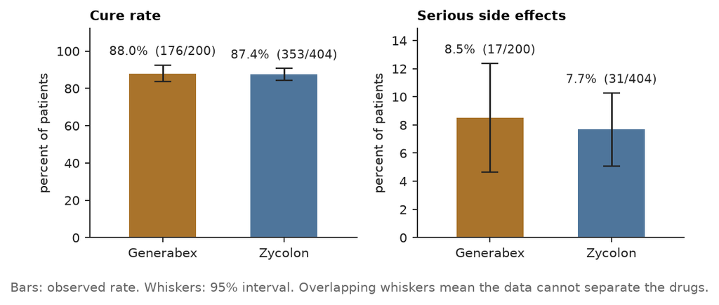

3. **Larger sample.** Zycolon's rates come from twice as many patients, so they are the more reliable estimates (Derry p. 103: small samples are unreliable).

4. **Forced choice: Zycolon.** It cures as well and has slightly fewer serious side effects. The choice rests on a weak signal, and the answer should say so.

5. **Why "neither" is reasonable.** The table has no control group. A cold goes away on its own, and some colds would end within two days with no drug at all. Without a placebo group, randomization and blinding, nobody knows whether *either* drug cures anything. Also, about 1 patient in 12 or 13 had a serious side effect, which is a very high price for treating a mild illness that clears up anyway. Unless a controlled trial showed a real benefit, the sensible choice is to take neither.

Note*Beyond the course formulas: the p-values are two-sided Fisher exact tests (Unit 10 explains what a p-value means but does not give the formula).*

Note*Outside the readings: the common cold is a self-limiting illness that usually clears without treatment within about a week to ten days.*

### Learning objective questions6

U10-OBJ01Objective

discuss some of the ways that mathematics is used in science and describe some forms of mathematical thinking.

Source Unit 10 Overview objective 1

**Ways mathematics is used in science** (Unit 10 Overview, Discussion 10.1):

1. **As the language of theory.** In the physical sciences every theory is expressed mathematically. Laws are equations, and causes such as forces appear as terms in them (F = ma).

2. **As models and simulations.** In population biology, genetics and ecology, mathematical and simulation models give insight into how biological systems behave. Economic forecasting depends on them too. In the social and human sciences mathematics plays a smaller role, often only statistics to find correlations between variables, because those sciences lack theories developed enough to be put in mathematical form.

3. **As the theory of measurement and error.** Every measurement has an error. Means, standard deviations and the normal distribution say how far a measured value can be trusted, and p-values say whether a result could easily be chance.

**Forms of mathematical thinking:**

4. **Axiomatic and deductive thinking.** Start from definitions and axioms and deduce theorems that are certain relative to them. Then ask how well the axioms correspond to the world (Newtonian mechanics and its (v/c)² limit). Related to this is *idealization*: treat a planet as a point mass to make the problem solvable.

5. **Probabilistic and statistical thinking.** Reason about expectations (probability) and compare them with observed frequencies. Distrust a number until you know its sample, its denominator and its uncertainty. Derry recommends attaching probabilities to ideas rather than treating them as simply true or false, because scientific results are provisional (Derry p. 95).

U10-OBJ02Objective

describe the elements composing a mathematical system, in particular the system of Newtonian mechanics and gravitational theory.

Source Unit 10 Overview objective 2

1. **Elements of any mathematical system.** These are definitions, a finite, independent and consistent set of axioms, and the theorems deducible from them. To describe the world, the axioms must also correspond to the facts within an error margin, and the continuity assumption must hold (Discussion 10.1).

2. **The axioms of Newtonian mechanics.** These are: the axioms of differential and integral calculus; space is a three-dimensional Euclidean manifold (homogeneous and isotropic) with all motion referred to a universal time; Newton's three laws (inertia; acceleration = applied force ÷ mass; action and reaction); and the simplifying assumption that solid bodies are point masses.

3. **What the axioms say about nature.** Space and time are independent; space does not affect bodies and bodies do not affect space; the natural, force-free motion is a straight line at constant speed; a force is anything that produces a deviation from that motion; and motion is smooth enough for velocity and acceleration (first and second derivatives) to exist.

4. **Theorems.** Calculus defines velocity as the time derivative of position and acceleration as the second derivative. F = ma then becomes a second-order differential equation. Its solutions give the orbits of point masses (the course calls this kinematics) or their position and velocity as functions of time (dynamics).

5. **Gravitational theory.** Add one force law: universal gravitation, a mutual attraction between all bodies that decreases as the inverse square of distance. Newton showed that his laws of motion with this force predict all three of Kepler's laws: elliptical orbits, equal areas in equal times, and period squared proportional to distance cubed (Derry pp. 63-64). **Limits.** The "truth" of the system is relative to its axioms. They fit the facts until the mid-19th century, but precise measurements show they are accurate only when terms of order (v/c)² can be neglected. The theorems are truths of reason. The theory as a whole is a truth of experience for an observer who cannot detect those terms.

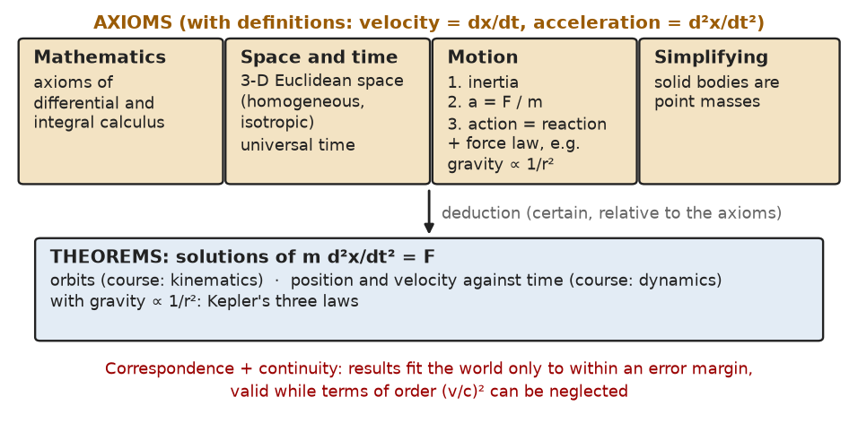

Note*Outside Discussion 10.1: the inverse-square law is written F = G m₁m₂/r², where G is the gravitational constant.*

U10-OBJ03Objective

describe some of the advantages of being able to formulate a mathematical theory for some field of science.

Source Unit 10 Overview objective 3

The course lists four advantages (Discussion 10.1), and the history adds more:

1. **Simplicity.** One equation, F = ma with acceleration as the second derivative of position, replaces long verbal descriptions of moving bodies and lets us predict future positions.

2. **Economy of effort.** Once a hypothesis is written mathematically, the whole toolkit of mathematics, such as calculus, algebra and statistics, can analyze it. There is no need to reason everything out from scratch.

3. **Generality.** The same law covers falling apples, projectiles and planetary orbits. With the law of gravitation, it also explains all three of Kepler's laws (Derry p. 64).

4. **Precision.** Mathematical predictions are numbers that can be compared with measurements. Statistical and probabilistic methods then estimate exactly how accurate a result can be expected to be, so a disagreement can be clearly detected.

5. **Further advantages.** *Unexpected consequences:* mathematics "commands" science, because a theorem derived in the system must be interpreted. Either it is a new prediction of the theory, or it shows that the framework is wrong. *Stability:* the mathematically proven parts of a theory survive when the theory is replaced (Cabeo). *Testability:* sharp predictions make the theory falsifiable, and the theory earns acceptance through "the continual fulfillment of predictions."

U10-OBJ04Objective

discuss the history of how mathematics became important in science during the 17th century, and in particular give the justification provided by Newton for mixing mathematics and science.

Source Unit 10 Overview objective 4

1. **Before the 17th century.** "Science" meant Aristotelian natural philosophy: syllogistic deduction from speculative premises supported by common knowledge or authority, aiming at certainty. Mathematics was a tool for calculation. Fields that measured, such as mechanics, optics and astronomy, were only "opinion." Contrived experiments were thought to distort nature (Discussion 10.1).

2. **The debate.** At Padua (1592-1610), Galileo took part in debates on whether a mathematical description could replace a causal explanation in a real science. Fabri (1646) objected that "only doubtful hypotheses can be drawn from doubtful experiences ... and doubtfulness is not science."

3. **The shift.** Cabeo (1629) used mathematics while insisting he was doing physics. He admitted his results were uncertain, kept the parts that rested on mathematical proof, and justified accepting laws by the continual fulfillment of their predictions. Barrow argued that every science needs mathematics because every science involves quantity. Mersenne spread the "mixed mathematical sciences" as models for understanding nature, and by the mid-17th century "physico-mathematics" meant mathematics used to gain real physical knowledge. The direction of reasoning also changed. Tycho deduced circular orbits from the perfection of the heavens, while Kepler inferred ellipses from Tycho's own data.

4. **Newton's justification.** In his 1672 letter on light and colour, Newton used contrived prism experiments and claimed mathematical certainty for his theory. Hooke objected that other hypotheses could explain the results. Newton replied (through Oldenburg) that "the absolute certainty of a science cannot exceed the certainty of its principles." His principles came from experiments, so they were "physical" principles. But if a mathematician can derive from them "all the phenomena of colours," the science is "as certain as any part of optics." In short, everything derived is mathematically certain. The principles are inductive and not absolutely certain, but theories whose results keep agreeing with experiment can be held with a high degree of certainty. This required accepting induction from finite cases to universal equations as legitimate.

5. **The outcome.** Newton's *Principia* sealed the change. The Royal Society linked its experimental practice to Newton's physico-mathematical justification, and the mathematical sciences "achieved their final triumph over scholastic natural philosophy," becoming explicitly experimental. Newton and Huygens were among the first to abandon absolute certainty as science's goal.

U10-OBJ05Objective

outline some of the basic principles of probability and use them in the computation of simple probabilities.

Source Unit 10 Overview objective 5

1. **Probability versus frequency.** Probability is the most reasonable expectation. With no reason to favour one outcome, equally possible outcomes get equal probabilities, so P = favourable cases ÷ possible cases. Frequency is what is observed in a large ensemble of trials. The Law of Large Numbers says the frequency converges to the probability as the number of trials grows. Example: P(ace) = 4/52 = 1/13 ≈ 7.7%, about 77 aces per 1,000 draws with replacement.

2. **Independence (product rule).** If A and B are independent, P(A and B) = P(A) × P(B). Example: two sixes on two dice: 1/6 × 1/6 = 1/36.

3. **Either-or (addition rule).** P(A or B) = P(A) + P(B) − P(A and B). The overlap is subtracted so it is not counted twice. Example: a heart or a king: 13/52 + 4/52 − 1/52 = 16/52 = 4/13. If A and B are mutually exclusive, P(A and B) = 0 and the rule reduces to a simple sum.

4. **Conditional probability.** P(A | B) = P(A and B) ÷ P(B). Example: a king, given that the card is a heart: (1/52) ÷ (13/52) = 1/13.

5. **Complement.** P(not A) = 1 − P(A). This is often the easier route. P(at least one six in two rolls) = 1 − (5/6)² = 11/36. In the birthday problem, the chance that none of N people share a birthday is P*(N) = (364/365)(363/365) ... ((366 − N)/365). For 23 people, the chance of a shared birthday is 1 − P*(23) ≈ 50.7%.

U10-OBJ06Objective

discuss some basic ideas of statistics, including the importance of having unbiased samples, the use of the standard deviation to measure the spread of a sample about its average, and the meaning of “statistically significant result.”

Source Unit 10 Overview objective 6

1. **Unbiased samples.** A statistic describes the population only if the sample is random. A survey of Sierra Club members misrepresents national opinion. People who return a survey, or who volunteer for a drug trial, may differ from those who do not (a nonrandom response rate). Small samples are unreliable, and the wording of survey questions also biases answers (Derry pp. 102-103).

2. **The mean.** The mean μ = (1/N)Σxᵢ is the best estimate of the true value when errors are random and unbiased.

3. **Spread: variance and standard deviation.** The standard deviation σ is the square root of the average squared deviation from the mean, and the variance is σ². The best estimate from a sample uses N − 1 in the denominator, and the uncertainty of the mean itself is Δμ = σ_est/√N (Discussion 10.2, equations 3-5). Roughly two-thirds of repeated measurements fall within ±1σ of the mean, which is why scientists quote results as "value ± uncertainty" (Derry p. 113).

4. **The normal distribution.** Gauss (1809) showed that requiring the mean to be the best estimate leads to the Gaussian, or normal, error distribution. The Central Limit Theorem explains why sums and averages of many independent errors are approximately normal. The model fails when errors are correlated. Complex systems often follow power laws instead, with more extreme deviations.

5. **"Statistically significant result."** Assume a null hypothesis H₀, such as "no effect." The p-value is the probability, if H₀ is true, of a result at least as extreme as the one observed. A result is statistically significant when p is at or below a threshold chosen in advance, usually 0.05. Rejecting a true H₀ is a Type I error, and failing to reject a false H₀ is a Type II error. Science sets a strict threshold to keep Type I errors rare. Significance means "unlikely to be chance alone." It does not mean "large" or "important."

Note*Course slip: Discussion 10.2 defines the p-value as the probability of "the outcome μ" given H₀. The standard definition is the probability of an outcome at least as extreme as μ.*

### Lists and concept recall7

U10-R01Recall

Explain this topic from the assigned readings: the components of a mathematical system. Give an example or explain its significance in this unit.

Source The components of a mathematical system (Discussion 10.1)

1. **Three components.** Discussion 10.1 opens with the definition: "A mathematical system consists of a set of definitions; a set of initial assumptions, called axioms; and all statements that can be logically deduced from these axioms and definitions."

| Component | What it is |
| --- | --- |
| **Definitions** | a set of definitions of the terms used in the system |
| **Axioms** | a set of initial assumptions |
| **Theorems** | all statements that can be logically deduced from the axioms and definitions |

2. **Three conditions on the axiom set.** The axioms must be mutually independent, the set must be finite, and it must be consistent (Discussion 10.1).

[output not shown]

3. **Truth relative to the axioms.** As Discussion 6.1 stated, the theorems of a mathematical system are true relative to the set of axioms that define the system; within the system they are truths of reason, not yet claims about the world (Discussion 10.1).

4. **Describing the world.** To use a mathematical system as a framework for describing or modelling some aspect of the real world, two more things are needed (Discussion 10.1). First, the axioms must satisfy the **correspondence criterion of truth**, at least within an acceptable margin of error, so the truth of the model becomes relative to the "facts" the axioms purport to describe. Second, a **continuity assumption**: "if the axioms fit the world to within a set error margin, then results derived from those axioms will also fit within a similar (but perhaps not identical) error margin."

5. **Example.** Surveyors normally use Euclidean geometry for plots of land, although it cannot apply exactly because the earth is not flat (Discussion 10.1, footnote 197). The flat-plane axioms fit a small plot within an acceptable error, and the continuity assumption lets the distances and areas derived from them be trusted to a similar error.

6. **Significance.** This structure frames the unit's treatment of Newtonian mechanics: its theorems are truths of reason relative to its axioms, while the theory as a description of nature holds only within a margin of error. In the course's constructive viewpoint a scientific theory is "a rational mental construct that is posited to stand in analogy to some aspect of the world", and the error margins tell us "just how far the analogy can be pushed" (Discussion 10.1).

U10-R02Recall

Explain this topic from the assigned readings: Newtonian mechanics as a mathematical system. Give an example or explain its significance in this unit.

Source Newtonian mechanics as a mathematical system (Discussion 10.1)

1. **The axioms.** Discussion 10.1 uses Newtonian mechanics as its example of a mathematical system and lists its axioms in four groups.

[output not shown]

2. **What the axioms assert.** The axioms of space and time say that space and time are independent, that objects in space do not influence space itself, and that space exerts no influence on the objects it contains. Newton's laws state the ideal of natural motion (straight lines) and define a force as any influence that produces a deviation from this natural motion (Discussion 10.1).

3. **Kinematics and dynamics.** With velocity and acceleration defined by calculus, one writes second-order differential equations whose solutions represent the positions of point masses subjected to specific forces. The solutions give either the orbits of the particles (**kinematics**) or their position and velocity as functions of time (**dynamics**) (Discussion 10.1).

4. **Five conditions.** By inspection of the axioms, the "truth" of Newtonian mechanics is relative to five conditions (Discussion 10.1).

| Condition | Statement |
| --- | --- |
| 1 | Space and time are independent, and there is a universal absolute time parameter |
| 2 | Space is not influenced by the bodies it contains, nor does it influence those bodies |
| 3 | Extended solid bodies may be considered as point masses |
| 4 | The natural (force-free) motion of a body in space is in a straight line at a constant speed |
| 5 | Except in isolated cases such as collisions (two point masses colliding), motion is smooth enough that at least the first and second time derivatives of position exist |

5. **Limits.** These conditions corresponded to the "facts" as they were known until about the middle of the 19th century. With more accurate measurement, results showed that they hold only to the extent that terms of the order of (v/c)<sup>2</sup> or higher can be neglected, where v measures the maximum speeds in an experimental situation and c is the speed of light, about 300,000 km per second (Discussion 10.1).

6. **Example.** In an experiment whose fastest body moves at 3 km per second, v/c = 3/300,000 = 10<sup>-5</sup> and (v/c)<sup>2</sup> = 10<sup>-10</sup>, so the neglected terms are about one part in ten billion and Newtonian mechanics fits within any ordinary error margin. As v approaches c the neglected terms grow and the fit fails.

7. **Significance.** The theorems of Newtonian mechanics are truths of reason relative to its axioms, and the theory is a truth of experience "relative to an experiencer whose perceptual capacities are limited to the extent that terms of second order and higher in the ratio (v/c) are not distinguishable" (Discussion 10.1). Its limits of accuracy show how far its analogy with the world can be pushed.

U10-R03Recall

Explain this topic from the assigned readings: the four advantages of stating a theory mathematically. Give an example or explain its significance in this unit.

Source Four advantages of stating a theory mathematically (Discussion 10.1)

1. **Four advantages.** "A number of advantages are gained when a theory can be stated in mathematical form. Among these are simplicity, economy of effort, generality and precision" (Discussion 10.1).

[output not shown]

2. **Mathematics "commands" science.** Mathematics is not only the primary tool of much scientific work: a theorem derived in a mathematical system accepted as the frame for a scientific theory must be interpreted in terms of the theory, and the conclusion accepted either as a consequence of the theory or as a sign that the framework is wrong, that is, that the mathematical system is not an appropriate framework (Discussion 10.1).

3. **Queen and servant.** The mathematician E. T. Bell captured this dual role with the saying that "Mathematics is the queen and servant of science" (Discussion 10.1), the idea in the title of his book *Mathematics: Queen and Servant of Science*.

4. **Where mathematics is used.** In the physical sciences all theories are expressed in mathematical language; in population biology, genetics and ecology, mathematical models and simulation models give deep insights; mathematical models are essential in economic forecasting. The human and social sciences use mathematics less, often only statistics to find correlations, because they lack general theories developed enough to be cast into mathematical form (Unit 10 Overview).

5. **Example.** Precision in practice: Discussion 10.2 reports a measured value as μ ± Δμ, where Δμ is the error of the mean, so a theoretical prediction can be checked against a stated error range rather than a vague agreement.

6. **Significance.** These advantages explain the "premier role" of mathematics in modern science (Unit 10 Overview), and why Discussion 10.1 urges every science student to work through many examples and problems and "develop a strong mathematical background".

U10-R04Recall

Explain this topic from the assigned readings: how mathematics entered science in the 17th century, through physico-mathematics and the mixed mathematical sciences. Give an example or explain its significance in this unit.

Source How mathematics entered science: the 17th century (Discussion 10.1)

1. **Before the 17th century.** Science today rests on experiment, and Karl Popper even insisted that a theory that could not be falsified could not be scientific, but "Before the 17th century this was not the way that science was done" (Discussion 10.1). Pythagoras valued mathematics, and Plato's geometrical theory of the four elements in the *Timaeus* makes him "the grandfather of mathematical physics"; but medieval natural philosophy followed Aristotle, who "had little use for mathematics", and the mathematical sciences came into being, as sciences, only during the scientific revolution of the 17th century (Unit 10 Overview).

2. **Who argued what.** Discussion 10.1 traces how mathematics was admitted into the study of nature.

[output not shown]

3. **A change of direction.** Medieval philosophers fitted observations into pre-assumed forms, deducing phenomena from first principles such as the primacy of circular motion; with the new experimental method, scientists inferred first principles inductively from empirical data, without relying on an a priori metaphysical order (Discussion 10.1). The word hypothesis changed with it, from a speculative assumption that starts a syllogism to an inductively generated conjecture, the background to Newton's "I do not feign hypothesis".

4. **Example.** Tycho and Kepler worked from the same observations of Mars: Tycho's first principle demanded circles, while Kepler let the data suggest ellipses, the inductive move that physico-mathematics required (Discussion 10.1).

5. **Significance.** In modern physics and chemistry, mathematical description and causal explanation go hand in hand, because causal entities such as forces are terms in equations that are supposed to describe laws of nature; this link arose only in the 17th century, and justifying the application of mathematics to nature was one of the major issues the scientific revolution had to resolve (Discussion 10.1).

U10-R05Recall

Explain this topic from the assigned readings: Newton's justification for mixing mathematics and science. Give an example or explain its significance in this unit.

Source Newton's justification for mixing mathematics and science (Discussion 10.1)

1. **The argument.** Newton "finalized the marriage between mathematical description and causation" by grounding universal propositions, in the form of mathematically described laws, in finite physical observations: "if there were laws of nature that could be given mathematical form, then an equation that was obeyed in every known case of empirical observation could be taken as an expression of the underlying universal law, even though it arose from empirical induction" (Discussion 10.1). The equation came from finite cases, yet it expresses the law.

2. **A radical step.** This required accepting inductive generalizations from finite cases to mathematical equations as legitimate, and accepting those equations as expressing a truth about nature, that is, as truths about nature rather than useful summaries (Discussion 10.1).

3. **The 1672 letter.** Newton's "famous and, at the time, highly controversial" 1672 letter to the Royal Society on light and colour gave the final synthesis of the modern method: he used **contrived experiments** with prisms to validate his physico-mathematical theorizing and claimed mathematical certainty for his results. **Robert Hooke** (1635-1703) objected that Newton's assumption that a prism splits white light into a spectrum of colours was not the only hypothesis explaining the results (other hypotheses fit them), and doubted that the conclusions could be mathematically certain (Discussion 10.1).

4. **Reply to Oldenburg.** Writing to **Henry Oldenburg**, secretary of the Royal Society, Newton argued that "the absolute certainty of a science cannot exceed the certainty of its principles." His propositions of colour come from experiments, "and so but physical", so they are physical principles; but "if these principles be such that on them a mathematician may determine all the phenomena of colours that can be caused by refractions", then "the science of colour will be granted mathematical and as certain as any part of optics" (Discussion 10.1).

5. **The result.** Anything derived from the mathematical definitions and propositions of a mathematical science is mathematically certain, but those propositions are derived by induction from experiment, so the science is **not certain in the Aristotelian sense**. If its results agree continually with experiment, it has a high degree of certainty: Newton believed he had found a way of producing knowledge "as secure as was humanly possible" (Discussion 10.1). Newton and Huygens were apparently the first natural philosophers to abandon completely the idea that science ought to seek absolute certainty.

6. **The final seal.** Newton's *Principia* gave the new method its final seal of approval: the Royal Society began to associate its experimental practice with his physico-mathematical justifications, and "When the Fellows adopted Newton as their champion, the mathematical sciences achieved their final triumph over scholastic natural philosophy. But in the process, those sciences had themselves mutated into something new, becoming explicitly experimental" (Discussion 10.1, quoting Peter Dear). The mathematical sciences, now experimental, triumphed.

7. **Example.** Newton's prisms: a contrived experiment, which Aristotelian science would reject as distorting nature into an abnormal state, supplied the physical principles of colour; once a mathematician could derive all the colour phenomena of refraction from those principles, the science of colour counted as being as certain as any part of optics (Discussion 10.1).

8. **Significance.** This is the modern view of scientific knowledge: laws are mathematical, inductively grounded in finite observations and tested by contrived experiments, and their certainty is high but never absolute. It also explains Newton's "I do not feign hypothesis": in his time a hypothesis meant a speculative assumption used to start a syllogistic argument, not an inductively generated conjecture (Discussion 10.1).

U10-R06Recall

Explain this topic from the assigned readings: the probability rules, conditional probability and the Law of Large Numbers. Give an example or explain its significance in this unit.

Source Probability rules (Discussion 10.2)

1. **Probability versus frequency.** The probability of an event is the most reasonable expectation: with 4 aces in a 52-card deck, P(ace) = 4/52 = 1/13 ≈ 0.0769, about 7.7%, so drawing one card at a time with replacement we expect about 1,000/13 ≈ 77 aces per 1,000 draws. The **frequency** of an event is defined only for an "ensemble", a very large number of identical cases; it is what experiments measure, and it is then taken as an estimate of the probability (Discussion 10.2).

2. **Law of Large Numbers.** Repeating the 1,000-draw experiment 100 times would not give exactly 77 aces each time but a variety of numbers averaging about 77, and statistics can estimate how close that average is to 1/13 and how the averages are distributed around it. The **Law of Large Numbers** is the theorem that in a process of random trials the frequency of a result converges to the theoretically predicted probability as the number of trials grows large (Discussion 10.2).

3. **The rules.** For two cases A and B, Discussion 10.2 gives these rules; the examples are computed here for a 52-card deck and fair coins.

| Rule | Formula | Example |
| --- | --- | --- |
| **Probability** (a reasonable expectation) | P(ace) = 4/52 = 1/13 ≈ 0.0769 | about 77 aces per 1,000 draws with replacement |
| **Independent events** (A and B) | P(A∧B) = P(A)P(B) | two coins both heads: 1/2 × 1/2 = 1/4 |
| **A, B or both** (A or B) | P(A∨B) = P(A) + P(B) - P(A∧B) | ace or heart: 4/52 + 13/52 - 1/52 = 16/52 = 4/13 ≈ 0.308 (the ace of hearts is counted once) |
| **Conditional probability** (A given B) | P(A\|B) = P(A∧B)/P(B) | P(ace, given a face card or ace) = (4/52)/(16/52) = 1/4 (12 face cards and 4 aces make 16 cards, 4 of them aces) |
| **Mutually exclusive** events | P(A∧B) = 0, so P(A∨B) = P(A) + P(B) | one card cannot be both a king and a queen: P(king or queen) = 4/52 + 4/52 = 8/52 = 2/13 ≈ 0.154 |
| **Complement** (not-A) | P(not-A) = 1 - P(A) | the birthday problem: compute the chance of no shared birthday, then subtract it from 1 |

4. **Setting up experiments.** It is often desirable to make the set of possible outcomes consist of events that are independent and mutually exclusive, and it is often easier to work with the probability that something does not occur than with the probability that it does (Discussion 10.2).

5. **Birthday problem.** For N people chosen at random (ignoring twins and leap years, with independent birthdays), the chance that no two share a birthday is P*(N) = 1 · (364/365)(363/365) ... ((366 - N)/365): P*(1) = 1, P*(2) = 364/365, and each new person must miss every earlier birthday. The chance of a shared birthday is 1 - P*(N), recomputed below in percent (Discussion 10.2).

| N | 10 | 20 | 22 | 23 | 30 | 50 | 95 | 100 |
| --- | --- | --- | --- | --- | --- | --- | --- | --- |
| Shared birthday (%) | 11.7 | 41.1 | 47.6 | 50.7 | 70.6 | 97.0 | 99.99986 | 99.99997 |

6. **Example.** The chance of a shared birthday first passes 1/2 at N = 23 (50.7%, against 47.6% at N = 22); it is 70.6% at N = 30 and 97.0% at N = 50. This is far higher than intuition suggests, because 23 people already form 23 × 22/2 = 253 pairs, each a chance of a match.

7. **Significance.** Experimental results determine frequencies, while theoretical analysis often uses probabilities; part of analyzing empirical results is deciding how close the measured frequencies come to the predicted probabilities, which leads into error analysis and statistics (Discussion 10.2).

U10-R07Recall

Explain this topic from the assigned readings: statistics and error analysis, from the standard deviation to a statistically significant result. Give an example or explain its significance in this unit.

Source Statistics and error analysis (Discussion 10.2; Derry, pp. 102-103)

1. **Accuracy and precision.** Measurements of continuous variables are never exact. **Accuracy** is how close a measurement is to the actual value; **precision** is how well an instrument distinguishes values. A bathroom scale marked in pounds is precise to about a pound, but inaccurate if it is biased (Discussion 10.2).

2. **The error model.** Each measurement is x<sub>i</sub> = x + e<sub>i</sub>, the true value plus an error (instrument precision, human mistakes, random environmental factors). With no bias and independent error sources, the errors are assumed randomly distributed, as equal a priori probabilities require (Discussion 10.2).

3. **Mean, standard deviation and error of the mean.** Discussion 10.2 gives these formulas (sums run over the N measurements).

| Quantity | Formula | Meaning |
| --- | --- | --- |
| **Mean** | μ = (1/N) Σ x<sub>i</sub> | the best estimate of x; the average error (1/N) Σ e<sub>i</sub> is the **first moment** and tends to 0 as N grows |
| **Standard deviation** | σ = [(1/N) Σ (μ - x<sub>i</sub>)<sup>2</sup>]<sup>1/2</sup> | the spread of the measurements about the mean; σ<sup>2</sup> is the **variance**, the **second moment** |
| **Best estimate of σ** | σ<sub>est</sub> = [Σ (μ - x<sub>i</sub>)<sup>2</sup>/(N - 1)]<sup>1/2</sup> | N - 1, because μ is itself only an estimate |
| **Error of the mean** | Δμ = σ<sub>est</sub>/√N = [Σ (μ - x<sub>i</sub>)<sup>2</sup>/(N(N - 1))]<sup>1/2</sup> | report the result as μ ± Δμ |

4. **Example.** Five readings 9.8, 10.1, 10.0, 9.9 and 10.2 give μ = 10.0; the squared deviations sum to 0.04 + 0.01 + 0 + 0.01 + 0.04 = 0.10, so σ = (0.10/5)<sup>1/2</sup> ≈ 0.141, σ<sub>est</sub> = (0.10/4)<sup>1/2</sup> ≈ 0.158 and Δμ = 0.158/√5 ≈ 0.071. The result is reported as 10.00 ± 0.07.

5. **The normal distribution.** Karl Friedrich Gauss (1777-1855) proved in 1809 that requiring the maximum-likelihood estimate to equal the arithmetic mean determines a unique error distribution, the Gaussian or **Normal distribution** (one form: f(x) = (1/√(2π)) exp(-x<sup>2</sup>/2)). It is **stable** (linear combinations of normal variables are normal), and the **Central Limit Theorem** makes it the limit for many independent, identically distributed variables with finite variance (Discussion 10.2). About 68.3% of results lie within 1σ of the mean and 95.4% within 2σ; Derry's rough reading of an uncertainty is that about two-thirds of many determinations fall within it (Derry, p. 113).

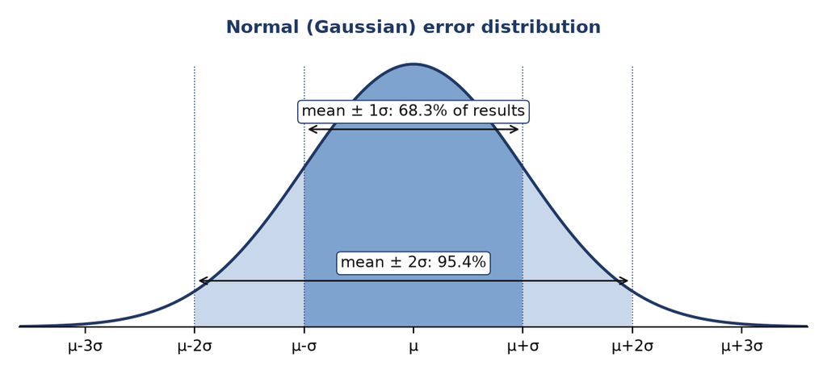

6. **Limits of the Gaussian.** It assumes that the variables are independent; correlations can distort it substantially, and in studies of complex systems **power-law** error distributions often fit better and make extreme deviations much more likely (Discussion 10.2).

7. **Hypothesis testing.** If the predicted x lies in [μ - Δμ, μ + Δμ] we have some confidence in it; if not, check for procedural errors or outside influences before revising the hypothesis. The tested hypothesis is the **null hypothesis** H<sub>0</sub>; the **p-value** P(μ|H<sub>0</sub>) is the probability of the outcome given that H<sub>0</sub> is correct. H<sub>0</sub> is generally rejected if **p ≤ .05**, a statistically significant result (Unit 10 Overview); a large difference short of that calls for more experiments (Discussion 10.2).

8. **Two forms of test.** Discussion 10.2 contrasts testing a theory's prediction with hoping to reject a hypothesis of no effect.

[output not shown]

9. **Type I and type II errors.** A **type I error** (error of the first kind) rejects a null hypothesis that is true, like convicting an innocent person; a **type II error** accepts a null hypothesis that is false. Science is conservative and minimizes type I errors, hence the stringent rule p ≤ .05 (Discussion 10.2).

10. **Derry's warnings.** Statistics offers extra ways to mislead (Derry, pp. 102-103).

| Problem | Derry's example |
| --- | --- |
| **Selective citation** | statistical facts cited selectively, another version of suppressed evidence (only part of the truth) |
| **Small samples** | "Conclusions based on small samples tend to be quite unreliable" |
| **Nonrandom samples** | a sample "must be chosen randomly": a survey of Sierra Club members misrepresents American opinion on environmental issues |
| **Nonrandom response rate** | the people who choose to send back a survey may not reflect the whole initial sample |
| **Volunteers** | people who volunteer for an experimental heart disease drug may already take extra measures, such as proper diet and exercise |
| **Question wording** | many favour helping prevent children from starving, few support wasting money on welfare cheats, though both may describe the identical policy |
| **Official statistics** | crime rates count crimes reported, not committed (rapes and crimes against poor ethnic minorities are often underreported) |
| **Inappropriate comparisons** | a 1.2 percent increase with 4.5 percent inflation is a substantial cut; "For a statistical comparison to mean anything, the quantities we compare must be appropriate" |

11. **Significance.** Every reported measurement carries an error estimate (Discussion 10.2). Hypothesis tests, p-values and the type I versus type II trade-off decide when data support or refute a theory, while Derry's warnings show that exact-sounding statistics are only as good as the sample, wording and comparison behind them.

### Key term questions17

U10-T01Term

Define or distinguish Axiom. Give an example and explain its role in this unit.

1. **Definition.** An axiom is an initial assumption of a mathematical system. It is accepted without proof, and the system's theorems are deduced from it (Discussion 10.1).

2. **Example.** Newton's second law, an object acted on by a force accelerates at the force divided by its mass, is one of the axioms of Newtonian mechanics. Another is that space is three-dimensional and Euclidean.

3. **Role in this unit.** Axioms are where both the certainty and the uncertainty of a mathematical science come from. Everything deduced from them is certain relative to them, but in a physical theory the axioms themselves must correspond to the facts within an error margin.

4. **Distinction.** An axiom is assumed, a theorem is derived, and a definition fixes the meaning of a term without asserting anything about the world.

5. **Significance.** As Newton put it, "the absolute certainty of a science cannot exceed the certainty of its principles." Testing a physical theory is ultimately a test of its axioms.

U10-T02Term

Define or distinguish Theorem. Give an example and explain its role in this unit.

1. **Definition.** A theorem is any statement that can be logically deduced from the axioms and definitions of a mathematical system.

2. **Example.** In Euclidean geometry, "the angles of a triangle add up to 180°" is a theorem. In Newtonian mechanics, the elliptical orbit of a planet attracted by an inverse-square force is a theorem (Derry p. 64).

3. **Role in this unit.** Theorems are *truths of reason*, true relative to the axioms (Discussion 6.1). In a physical theory they are the predictions that get tested.

4. **Distinction.** A theorem is proven from the axioms, while an axiom is assumed. A theorem's truth is relative to its system: in non-Euclidean geometry the angle-sum theorem is false.

5. **Significance.** Mathematics "commands" science through its theorems. A theorem derived in the framework must be accepted either as a consequence of the theory or as a sign that the framework is inappropriate.

Note*Outside Discussion 10.1: non-Euclidean geometry, where a triangle's angles do not add up to 180°, is a standard example.*

U10-T03Term

Define or distinguish Independence, finiteness, consistency. Give an example and explain its role in this unit.

1. **Definition.** These are the three conditions on a set of axioms (Discussion 10.1). *Independence:* no axiom can be deduced from the others. *Finiteness:* there are finitely many axioms. *Consistency:* no contradiction can be derived from them.

2. **Example.** Euclid's parallel postulate is independent of his other axioms. Geometries that replace it are still consistent, so it cannot be derived from the rest.

3. **Role in this unit.** Independence is an efficiency condition: the axiom set should be minimal, with no "reinventing the wheel" (footnote 195). Finiteness keeps every assumption available for use in deductions; an infinite set would always leave unknown assumptions (footnote 196). Consistency is needed because if the axioms contradict one another, the theorems cannot satisfy the coherence criterion of truth.

4. **Distinction.** Consistency is essential, because without it the system is useless. Independence is only a matter of economy: a redundant axiom does no harm to truth.

5. **Significance.** These conditions concern the system's *internal* truth (coherence). A physical theory must also meet the external test of correspondence with the facts.

Note*Outside Discussion 10.1: the independence of the parallel postulate, shown by non-Euclidean geometry in the 19th century, is a standard example.*

U10-T04Term

Define or distinguish Continuity assumption. Give an example and explain its role in this unit.

1. **Definition.** The continuity assumption says that if the axioms of a mathematical system fit the world within a set error margin, then the results derived from them also fit within a similar, though perhaps not identical, error margin (Discussion 10.1).

2. **Example.** Surveyors use Euclidean (flat) geometry for plots of land even though the Earth is not flat (footnote 197). The flat-plane axioms fit a small plot almost perfectly, so the areas computed from them fit too.

3. **Role in this unit.** It is the bridge that lets exact mathematics describe an inexact world. Without it, a tiny error in the axioms could grow into a huge error in a prediction, and approximate correspondence would justify nothing.

4. **Distinction.** Correspondence concerns how well the *axioms* fit the facts. Continuity concerns whether that fit carries over to the *theorems*.

5. **Significance.** It is an assumption, not a guarantee. Margins can grow along a deduction, and in some systems small differences grow rapidly. That is why predictions are reported with their own error estimates.

U10-T05Term

Define or distinguish Kinematics / dynamics. Give an example and explain its role in this unit.

1. **Definition (course usage).** The equations of Newtonian mechanics are differential equations. Their solutions give either the *orbits* of the particles (kinematics) or their *position and velocity as functions of time* (dynamics) (Discussion 10.1).

2. **Example.** Kinematics, in this sense, gives the elliptical shape of a planet's orbit. Dynamics gives where the planet is, and how fast it is moving, on a particular date.

3. **Role in this unit.** They are the two kinds of theorem Newtonian mechanics delivers, showing how axioms plus calculus produce testable results.

4. **Standard distinction.** In most physics textbooks, *kinematics* describes motion (position, velocity, acceleration) without asking what causes it. *Dynamics* explains motion in terms of the forces that cause it (F = ma). Galileo's relations among position, time, velocity and acceleration are kinematics (Derry p. 62), and Newton's force law is dynamics.

5. **Significance.** Either way, the distinction is between *describing* a motion and *explaining or predicting* it from causes. That is exactly the line the Aristotelians drew when they denied that mathematical description could be causal science.

Note*Course usage differs from the standard textbook meaning; both are given here so the answer is right under either reading.*

U10-T06Term

Define or distinguish Physico-mathematics / mixed mathematical sciences. Give an example and explain its role in this unit.

1. **Definition.** Physico-mathematics, or the mixed mathematical sciences, is the 17th-century term for using mathematics as a tool to gain real physical knowledge of nature (Discussion 10.1).

2. **Example.** Newton's theory of colour combined prism experiments with mathematical demonstration. Optics, astronomy and mechanics were the classic mixed sciences.

3. **Role in this unit.** It is the bridge between Aristotelian natural philosophy, which was certain but speculative, and modern experimental science. Barrow judged it superior to the Aristotelian method, Mersenne spread it, and Newton justified it.

4. **Distinction.** Aristotelian "science" was certain deduction from first causes, with no mathematics. The mixed sciences rested on measurement, so Aristotelians classed them as mere "opinion." Physico-mathematics claimed they could yield genuine causal understanding.

5. **Significance.** When the Royal Society adopted Newton's physico-mathematical justification, the mathematical sciences "achieved their final triumph over scholastic natural philosophy." In the process they became explicitly experimental.

U10-T07Term

Define or distinguish Probability / frequency. Give an example and explain its role in this unit.

1. **Definition.** A *probability* is the most reasonable expectation that an event will occur, computed from theory. A *frequency* is the fraction of times the event actually occurs in a large ensemble of trials (Discussion 10.2).

2. **Example.** The probability of drawing an ace is 4/52 = 1/13 ≈ 0.077, so we expect about 77 aces per 1,000 draws with replacement. A real run of 1,000 draws might give 71 or 83 aces. That is a frequency.

3. **Role in this unit.** Experiments measure frequencies, while theories predict probabilities. Analyzing results means asking how close the measured frequency is to the predicted probability.

4. **Distinction.** A probability is fixed by the model. A frequency varies from one run of trials to the next and scatters around the probability.

5. **Significance.** The Law of Large Numbers links them, so a frequency from many trials can be used to estimate an unknown probability.

Note*Course slip: Discussion 10.2 writes 1/13 ≈ .007692; the correct value is 0.076923 (its "7.7%" and "77 aces per thousand" are right).*

U10-T08Term

Define or distinguish Ensemble. Give an example and explain its role in this unit.

1. **Definition.** An ensemble is a very large number of identical cases, or repeated trials, with respect to which a frequency is defined (Discussion 10.2).

2. **Example.** Draw a card from a full deck, note whether it is an ace, replace it, and repeat 1,000 times. The 1,000 draws form the ensemble.

3. **Role in this unit.** Frequencies exist only relative to an ensemble, and the Law of Large Numbers is a statement about larger and larger ensembles.

4. **Distinction.** An ensemble is a collection of trials. A single trial has an outcome but no frequency. The cases must be *identical*, meaning the same conditions each time, or the frequency mixes different probabilities.

5. **Significance.** Repeating the 1,000-draw experiment 100 times gives an ensemble of ensembles. The 100 counts vary, but they cluster around 77, and statistics can describe that spread.

U10-T09Term

Define or distinguish Law of Large Numbers. Give an example and explain its role in this unit.

1. **Definition.** The Law of Large Numbers is a theorem: in a process of random, independent trials, the frequency of a result converges to its theoretical probability as the number of trials grows (Discussion 10.2).

2. **Example.** The fraction of aces in repeated draws with replacement settles towards 1/13 ≈ 7.7% as the number of draws grows.

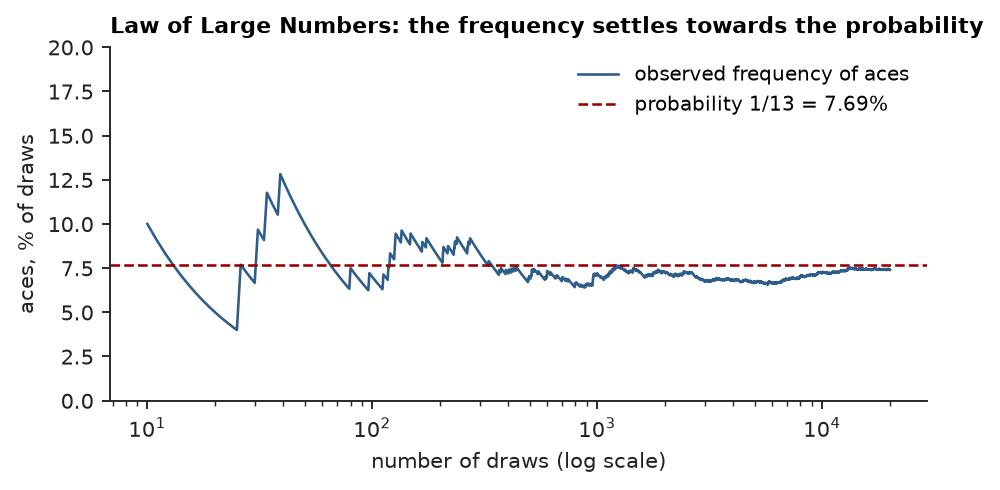

3. **Role in this unit.** It is the formal link between probability (theory) and frequency (experiment). It also explains why averaging many measurements helps: random errors of each sign cancel, so the average error tends to 0.

4. **Distinction.** It does *not* say that outcomes "even out" in the short run. After five red spins at roulette, black is no more likely. Instead, the early excess is diluted by many later trials. Believing otherwise is the gambler's fallacy.

5. **Significance.** It is why large samples are trusted more than small ones. It does not fix bias, though: if every trial is biased the same way, the frequency converges to the wrong value.

Note*The figure is a simulation (seeded random draws), produced to illustrate convergence; its exact path changes with the seed.*

U10-T10Term

Define or distinguish Independent events; mutually exclusive events; conditional probability. Give an example and explain its role in this unit.

1. **Definitions.** Events are *independent* if one occurring does not change the probability of the other, so P(A and B) = P(A)P(B). Events are *mutually exclusive* if they cannot both occur, so P(A and B) = 0. The *conditional probability* of A given B is P(A | B) = P(A and B)/P(B) (Discussion 10.2).

2. **Examples.** Two dice rolls are independent: P(two sixes) = 1/36. "Heart" and "spade" for one card are mutually exclusive. P(king | heart) = (1/52)/(13/52) = 1/13.

3. **Role in this unit.** These are the basic rules for computing probabilities. Independence underlies the birthday-problem product, and the conditional probability is what a p-value is: P(result | H₀).

4. **Distinction.** Mutually exclusive events with nonzero probabilities are *never* independent. If one happens, the other's probability drops to 0. Conditional probability is not symmetric: P(A | B) generally differs from P(B | A).

5. **Significance.** Confusing P(positive | disease) with P(disease | positive), or P(data | H₀) with P(H₀ | data), is one of the most common errors in reading test results and statistics.

Note*Course slip: Discussion 10.2 says experimental outcomes should be "independent and mutually exclusive"; read this as mutually exclusive outcomes within one trial and independent repeated trials, because two events with nonzero probability cannot be both.*

U10-T11Term

Define or distinguish Accuracy / precision. Give an example and explain its role in this unit.

1. **Definition.** *Accuracy* is how close a measurement is to the actual value. *Precision* is how finely the instrument distinguishes values (Discussion 10.2), or how closely repeated measurements agree with each other (Derry p. 114).

2. **Example.** A bathroom scale marked in pounds is precise to about 1 lb. If it is biased, or you weigh yourself in heavy boots, every reading is too high: precise but not accurate (Derry p. 114).

3. **Role in this unit.** Every measurement has limited accuracy and precision, so results must carry error estimates. Statistics handles random scatter, which is a matter of precision.

4. **Distinction.** Poor precision comes from *random* error, which averaging reduces. Poor accuracy comes from *systematic* error (bias), which averaging cannot remove.

5. **Significance.** "High precision is no guarantee of correctness" (Derry p. 114). Many decimal places can hide a biased method.

U10-T12Term

Define or distinguish Mean, standard deviation, variance. Give an example and explain its role in this unit.

1. **Definitions.** The *mean* μ is the average of the measurements, (1/N)Σxᵢ. The *variance* σ² is the average squared deviation from the mean, and the *standard deviation* σ is its square root (Discussion 10.2, equations 1 and 3).

2. **Example.** For 2, 4, 4 and 6, the mean is 4 and the squared deviations sum to 8. Using the best estimate with N − 1 = 3 (equation 4), the variance is 8/3 ≈ 2.67 and the standard deviation is ≈ 1.63.

3. **Role in this unit.** They are the first two "moments" that describe a set of measurements: where the measurements centre and how widely they spread. The uncertainty of the mean itself is Δμ = σ_est/√N, which here is ≈ 0.82.

4. **Distinction.** The standard deviation describes the spread of the *individual measurements* and does not shrink with more data. The standard error Δμ describes the uncertainty of the *mean* and shrinks as 1/√N.

5. **Significance.** Results are reported as μ ± Δμ. In the natural sciences the quoted uncertainty is usually the standard deviation, and about two-thirds of repeated measurements fall within ±1σ (Derry p. 113).

U10-T13Term

Define or distinguish Normal (Gaussian) distribution. Give an example and explain its role in this unit.

1. **Definition.** The normal, or Gaussian, distribution is the bell-shaped error distribution. In standard form it is f(x) = e^(−x²/2)/√(2π) (Discussion 10.2, equation 6).

2. **Example.** Measurement errors from many small independent sources follow it. About 68.3% of values fall within ±1σ of the mean, 95.4% within ±2σ and 99.7% within ±3σ.

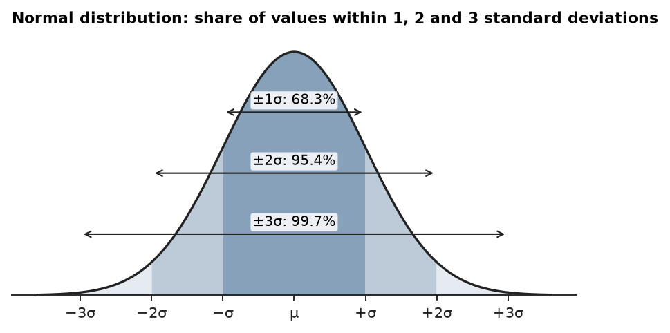

3. **Role in this unit.** Gauss (1809) proved that it is the unique error distribution for which the arithmetic mean is the maximum-likelihood estimate. It is "stable": linear combinations of normal variables are normal.

4. **Distinction.** It assumes independent errors. With correlated variables, as in complex systems, power-law distributions often fit better and make extreme deviations much more likely than the normal curve allows.

5. **Significance.** It turns a standard deviation into a probability statement. That is the basis of error bars and of p-values.

U10-T14Term

Define or distinguish Central Limit Theorem. Give an example and explain its role in this unit.

1. **Definition.** The Central Limit Theorem says that the sum, or average, of many independent, identically distributed variables with finite variance has a distribution that approaches the normal distribution as their number increases (Discussion 10.2).

2. **Example.** A single die roll is uniform over 1-6, not bell-shaped at all. But the average of 30 rolls is very close to normally distributed around 3.5.

3. **Role in this unit.** It explains why the normal distribution is the natural model for measurement error: an error is the sum of many small independent effects.

4. **Distinction.** The theorem is about *sums and averages*. Individual values need not be normal. It also needs independence and finite variance. Correlated variables or heavy-tailed (power-law) data break it.

5. **Significance.** It justifies using normal-based error bars and tests for averages even when the underlying measurements are not normal.

Note*Course wording: Discussion 10.2 says "the limit as the number of variables increases approaches a normal distribution"; precisely, it is the standardized sum or average whose distribution approaches the normal.*

U10-T15Term

Define or distinguish Null hypothesis; p-value; statistically significant. Give an example and explain its role in this unit.

1. **Definitions.** The *null hypothesis* H₀ is the hypothesis being tested, often "no effect" or "no correlation." The *p-value* is the probability, assuming H₀ is true, of getting a result at least as extreme as the one observed. A result is *statistically significant* when p is at or below a threshold chosen in advance, usually 0.05 (Discussion 10.2).

2. **Example.** A sociologist tests H₀: "income has no influence on political belief." If the survey shows a correlation with p = 0.04, the result is significant at the 0.05 level and H₀ is rejected.

3. **Role in this unit.** This is how a hypothesis-testing study decides whether an observed effect could easily be chance.

4. **Distinction.** p is P(data at least this extreme | H₀), *not* P(H₀ | data). It is also not the size or importance of an effect: a tiny effect in a huge sample can give a very small p.

5. **Significance.** The strict 0.05 rule reflects science's conservatism, keeping false claims (Type I errors) rare. But even when nothing is going on, about 1 test in 20 will reach p ≤ 0.05.

Note*Course wording: "p = .04 says that the results ... have only a 4% chance of arising at random" is loose. Strictly, if there were no correlation, results at least this strong would arise 4% of the time.*

U10-T16Term

Define or distinguish Type I / Type II error. Give an example and explain its role in this unit.

1. **Definition.** A *Type I error* is rejecting the null hypothesis when it is actually true. A *Type II error* is failing to reject it when it is actually false; the course says "accepting" it (Discussion 10.2).

2. **Example.** In a trial, a Type I error convicts an innocent person, and a Type II error acquits a guilty one. In a drug test with H₀ "the drug does nothing," a Type I error approves a useless drug, and a Type II error discards a useful one.

3. **Role in this unit.** Any significance test risks both. The threshold (p ≤ 0.05) sets the Type I risk at 5% when H₀ is true.

4. **Distinction.** Lowering the threshold reduces Type I errors but, for the same data, increases Type II errors. Only more data or a better design reduces both.

5. **Significance.** Science deliberately minimizes Type I errors, which reflects its conservative nature. A non-significant result therefore often calls for more experiments rather than proving there is no effect.

U10-T17Term

Define or distinguish Random sample; nonrandom response rate. Give an example and explain its role in this unit.

1. **Definitions.** In a *random sample*, every member of the population has an equal chance of being chosen, so the sample represents the population. A *nonrandom response rate* means the people who choose to respond differ systematically from those who do not (Derry pp. 102-103).

2. **Examples.** Surveying Sierra Club members misrepresents national opinion on the environment. Volunteers for a heart-drug trial may already eat well and exercise. Diet-book letters come mainly from people with dramatic results (Study Question 6).

3. **Role in this unit.** An unbiased sample is the first condition for any statistic to mean something. The standard deviation and p-value assume random sampling.

4. **Distinction.** Sample *size* fights random error, and *randomness* fights bias. A huge but self-selected sample is still biased, while a small random sample is merely imprecise.

5. **Significance.** Before trusting a percentage, ask who was asked, who answered, and out of how many.

### Applied written questions16

U10-A01Applied5 marks

Distinguish definitions, axioms and theorems using a simple mathematical system. Explain consistency and why applying the system to nature adds an empirical obligation.

Source Discussion 10.1

**System used: plane (Euclidean) geometry.**

1. **Definitions** fix the meaning of terms and assert nothing about the world. For example, "a triangle is a figure bounded by three straight lines," and "parallel lines are lines in a plane that never meet."

2. **Axioms** are assumptions accepted without proof. For example, "through a point not on a given line, exactly one line can be drawn parallel to it."

3. **Theorems** are deduced from the axioms and definitions. For example, "the angles of any triangle add up to 180°." The theorem is certain *relative to* the axioms; it is a truth of reason (Discussion 10.1).

4. **Consistency** means that no contradiction can be derived from the axioms: we must never be able to prove both a statement and its negation. If the axioms were inconsistent, the theorems could not satisfy the coherence criterion of truth, and the system would be useless. (The axioms should also be finite and independent.)

5. **The empirical obligation.** Inside mathematics, the 180° theorem needs no measurement. As soon as we claim that real triangles, such as those marked out by surveyors' sight lines, obey it, the axioms must satisfy the *correspondence* criterion: they must fit measured facts within an error margin. We also need the *continuity assumption*: if the axioms fit within that margin, the theorems do too. Deductive validity does not discharge that obligation. Only measurement does, and the fit can fail. Euclidean geometry only approximates the Earth's curved surface (footnote 197).

U10-A02Applied5 marks

A geometrically exact result describes a measured field only approximately. Explain coherence, correspondence, measurement error and the course continuity assumption in this application.

Source Discussion 10.1

**Example: a surveyed rectangular field.** Euclidean geometry says that its area is exactly length × width. The measured sides are 100.0 ± 0.1 m and 50.0 ± 0.1 m.

1. **Coherence.** "Area = length × width" is a theorem of Euclidean geometry. It follows validly from the axioms, so within the system it is exactly true. This is coherence: agreement with the rest of the system.

2. **Correspondence.** Whether it describes the *field* depends on whether the axioms fit the real ground. The field's corners are not perfect right angles, its edges are not perfect lines, and the Earth is curved rather than flat (footnote 197). The axioms fit only approximately, so correspondence holds only within a margin of error.

3. **Measurement error.** The inputs are uncertain. With sides between 99.9 and 100.1 m and between 49.9 and 50.1 m, the area lies between 4,985.01 and 5,015.01 m², so it is 5,000 ± 15 m² at worst. The exact formula is applied to inexact numbers.

4. **The continuity assumption.** The course assumes that if the axioms fit the world within a margin, the derived results fit within a *similar but not identical* margin. Here the side errors of 0.1% and 0.2% became an area error of up to 0.3%: similar, but larger. The assumption is what justifies trusting the computed area at all.

5. **Conclusion.** The result is exact as mathematics and approximate as a description of the field. The answer should be reported as 5,000 ± 15 m², not 5,000 m². When better measurement reveals a misfit larger than the stated margin, the problem lies with the axioms' fit to the world, not with the deduction. That is how Newtonian mechanics proved accurate only up to terms of order (v/c)².

U10-A03Applied10 marks

Compare the Aristotelian demand for certainty with Newton's defence of experimentally grounded mathematical science. Explain what can be certain and what remains conditional.

Source Discussion 10.1

**The Aristotelian position:**

1. **Science means certainty.** Real science (natural philosophy) was syllogistic deduction from premises that were obvious, agreed upon, or backed by authority. A valid deduction from such premises was taken to give certain conclusions, and only certainty counted as "scientific knowledge" (Discussion 10.1).

2. **Science versus opinion.** Fields that rely on measurement, such as mechanics, optics, astronomy and medicine, could apply to the world but could never be certain, so they were "opinion."

3. **Against mathematics.** Sense data are imprecise, so they cannot support exact mathematical ratios: "only doubtful hypotheses can be drawn from doubtful experiences ... and doubtfulness is not science" (Fabri, 1646).

4. **Against experiment.** A contrived experiment puts nature in an abnormal state, so it cannot reveal what normally happens.

5. **The price of certainty.** Medieval philosophers reasoned about "possible worlds" with little regard for whether they matched the actual world. Their conclusions were certain *given* the premises, but they might describe nothing real.

**Newton's position:**

6. **Principles from experiment.** In his 1672 paper on light and colour, Newton used contrived prism experiments to establish his principles and claimed mathematical certainty for the theory. When Hooke objected that other hypotheses could explain the results, Newton replied that "the absolute certainty of a science cannot exceed the certainty of its principles." His principles came "from experiments, and so but physical."

7. **Mathematics as the certain link.** If a mathematician can derive "all the phenomena of colours" from those principles, the science is "as certain as any part of optics." The derivation is mathematical, so it is certain.

8. **Induction legitimized.** Newton accepted that an equation obeyed in every known case could be taken to express a universal law, even though it came from induction over finitely many cases.

**What is certain and what is conditional:**

9. **Certain:** the deductions. Each theorem follows with mathematical certainty from the principles: it is a truth of reason, relative to its axioms. **Conditional:** the principles themselves, which are inductive (a new case can always overturn an induction); their correspondence to the world, which holds only within error margins; and the continuity assumption that carries the fit from axioms to results. Newtonian mechanics shows this. Its theorems remain valid, but its axioms fit the world only when terms of order (v/c)² can be neglected.

10. **Judgement.** The Aristotelian approach bought certainty at the price of relevance. Newton's approach gives up absolute certainty (Newton and Huygens were among the first to abandon it, footnote 206) in exchange for knowledge that is testable and self-correcting. Its confidence grows with "the continual fulfillment of predictions" (Cabeo). Such knowledge is "as secure as was humanly possible," and it is the basis of modern experimental science.

U10-A04Applied5 marks

Explain simplicity, economy, generality and precision as advantages of mathematical theorizing. Show two of these advantages using F = ma.

Source Discussion 10.1

1. **Simplicity.** One short equation replaces a long verbal account. F = ma, with a the second time derivative of position, describes how *any* body moves under *any* force and lets us predict its future positions (Discussion 10.1).

2. **Economy.** Once a hypothesis is an equation, the existing tools of mathematics, such as calculus and algebra, do the reasoning. Nothing has to be worked out from scratch.

3. **Generality.** The same law covers a falling apple, a thrown ball and a planet's orbit. With the inverse-square law of gravity, it even yields all three of Kepler's laws (Derry p. 64).

4. **Precision.** The theory gives definite numbers, which can be checked against measurements to a stated accuracy, and statistics can estimate how accurate the result should be.

5. **Two advantages shown with F = ma.**

**Precision and economy.** A constant force of 10 N acts on a 2 kg cart at rest. Then a = F/m = 10 ÷ 2 = 5 m/s². Integrating twice (economy: the calculus does the work) gives v = at = 15 m/s and x = ½at² = ½ × 5 × 3² = 22.5 m after 3 s. These are exact predictions that a stopwatch and tape measure can test.

**Generality.** The *same* equation, with F = the weight mg, says every falling body near the Earth has a = g whatever its mass (ignoring air resistance). With F = the Sun's inverse-square gravity, it gives the planets' elliptical orbits. One law covers both cases.

U10-A05Applied5 marks

A fair six-sided dice is rolled twice independently. Find the probability of two sixes and of at least one six. Explain the role of independence and the complement rule.

Source Discussion 10.2

1. **Sample space.** Each roll has 6 equally likely outcomes. Because the rolls are independent, the pair has 6 × 6 = 36 equally likely outcomes.

2. **Two sixes (product rule).** Independence means the first roll does not change the probabilities for the second, so P(A and B) = P(A)P(B). P(6 and 6) = 1/6 × 1/6 = **1/36 ≈ 2.8%**. Only one of the 36 outcomes, (6, 6), qualifies.

3. **At least one six (complement rule).** "At least one six" is the opposite of "no sixes." P(no six) = 5/6 × 5/6 = 25/36, again by independence. So P(at least one six) = 1 − 25/36 = **11/36 ≈ 30.6%**.

4. **Check with the addition rule.** P(first six or second six) = 1/6 + 1/6 − 1/36 = 11/36. Simply adding 1/6 + 1/6 = 12/36 is wrong, because (6, 6) would be counted twice. The two events are *not* mutually exclusive.

5. **Why each rule matters.** Independence lets the probabilities multiply. The complement turns an awkward "at least one" question into a single product, which is the same trick used in the birthday problem. Both rules assume a fair die and independent rolls. A loaded die, or rolls that influence each other, would change both answers.

U10-A06Applied5 marks

One card is drawn from a standard 52-card deck. Find the probability that it is a heart or a king, counting overlap correctly. Then find the probability of a king given that the card is a heart.

Source Discussion 10.2

1. **Count the events.** In a 52-card deck there are 13 hearts and 4 kings. The overlap is one card, the king of hearts, which is in both groups.

2. **Addition rule.** P(heart or king) = P(heart) + P(king) − P(heart and king) = 13/52 + 4/52 − 1/52 = 16/52 = **4/13 ≈ 30.8%**.

3. **Why subtract the overlap.** Adding 13 + 4 = 17 cards counts the king of hearts twice. "Heart" and "king" are *not* mutually exclusive, so the overlap must be removed. A direct count of the 16 distinct cards agrees.

4. **Conditional probability.** P(king | heart) = P(king and heart) ÷ P(heart) = (1/52) ÷ (13/52) = **1/13 ≈ 7.7%**. Equivalently, among the 13 hearts exactly one is a king.

5. **Interpretation.** P(king | heart) = 1/13 = P(king). Knowing the suit tells us nothing about the rank, so "heart" and "king" are *independent* events, even though they overlap. Independence and mutual exclusivity are different properties.

U10-A07Applied5 marks

A bag contains three red and two blue balls. Find the probability of two red draws without replacement and compare it with the probability when the first ball is replaced.

Source Discussion 10.2

1. **Without replacement.** P(first red) = 3/5. After a red ball is removed, 2 of the remaining 4 are red, so P(second red | first red) = 2/4. P(two red) = 3/5 × 2/4 = 6/20 = **3/10 = 30%**.

2. **With replacement.** The bag is restored before the second draw, so the draws are independent: 3/5 × 3/5 = **9/25 = 36%**.

3. **Why they differ.** Without replacement the second draw *depends* on the first, so the conditional probability (2/4) must be used, not 3/5. Replacing the ball makes the draws independent, so the simple product rule applies.

4. **The rule behind both.** In general, P(A and B) = P(A) × P(B | A). With replacement, P(B | A) = P(B), and the formula reduces to the independent case.

5. **Significance.** Sampling without replacement from a small population changes the odds with each draw. From a very large population, the two answers become almost identical, which is why large surveys can treat draws as independent.

Note*A quick check by listing all 20 ordered pairs of different balls gives 6 red-red pairs (6/20); with replacement, 9 of 25 pairs are red-red.*

U10-A08Applied5 marks

In a hypothetical screening exercise, 10 of 1000 samples truly contain a target. The test detects 9 of those 10 and gives 90 false positives among the other samples. What fraction of positive results are genuine? Explain why the base rate matters.

Source Discussion 10.2 conditional probability

|  | **Test positive** | **Test negative** | **Total** |
| --- | --- | --- | --- |
| Target present | 9 | 1 | 10 |
| Target absent | 90 | 900 | 990 |
| Total | 99 | 901 | 1000 |

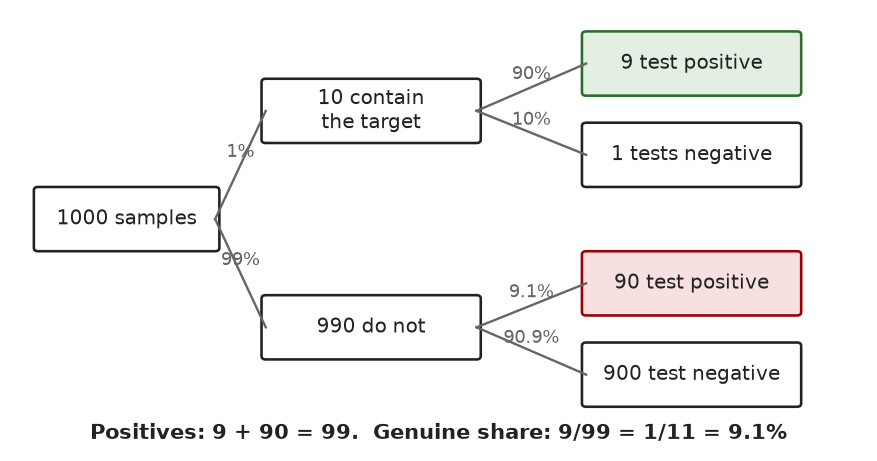

1. **Count the positives.** There are 9 true positives and 90 false positives, so 99 positive results in all.

2. **Fraction genuine.** P(target | positive) = 9/99 = **1/11 ≈ 9.1%**. Fewer than 1 positive in 10 is real.

3. **The test is not bad.** It detects 90% of real targets (9 of 10), and it wrongly flags only 90 of 990 clean samples (about 9.1%), so it is correct for 90.9% of clean samples.

4. **Why the base rate matters.** Only 1% of samples (10 of 1000) contain the target. A small error rate applied to the large clean group (990) produces many more false alarms (90) than the few real cases can supply (9). The rarer the target, the lower the share of positives that are genuine.

5. **The logical lesson.** P(positive | target) = 90% is not the same as P(target | positive) = 9.1%. Mixing them up is the probabilistic version of confusing a statement with its converse. A positive screening result is a reason for a confirmatory test, not a conclusion.

U10-A09Applied5 marks

A lottery chooses five distinct numbers from 40 without regard to order. Derive the probability that one ticket matches all five and explain why permutations would overcount.

Source Discussion 10.2; variation on Study Question 5

1. **Set up.** Five distinct numbers are drawn from 40, and order does not matter. Every set of five is assumed to be equally likely.

2. **Ordered count (permutations).** There are 40 × 39 × 38 × 37 × 36 = 78,960,960 ordered sequences of five different numbers.

3. **Remove the order (combinations).** Each set of five appears in 5! = 120 orders. The number of distinct sets is 78,960,960 ÷ 120 = **658,008** = C(40, 5) = 40!/(5! × 35!).

4. **Probability.** One set wins, so P(match all five) = **1/658,008 ≈ 0.0000015**, about 1.5 in a million.

5. **Why permutations overcount.** A ticket {3, 11, 19, 27, 38} wins however the balls come out of the machine. Counting permutations treats its 120 orderings as 120 different outcomes, which overcounts by a factor of 120. Using permutations consistently still works: 120 winning orders ÷ 78,960,960 ordered outcomes gives the same 1/658,008. The error is mixing an ordered count of outcomes with one unordered ticket. This is SG05's method with 40 and 5 in place of 49 and 6.

U10-A10Applied5 marks

Assuming independent equally likely birthdays and ignoring leap years, write the probability that none of 20 people share a birthday. Explain how to obtain the probability of at least one shared birthday.

Source Discussion 10.2

1. **Assumptions.** There are 365 equally likely birthdays (no leap years), people's birthdays are independent, and twins are ignored (Discussion 10.2).

2. **Build the product.** The first person can have any birthday. The second must avoid one day (364/365), the third two days (363/365), and so on. The 20th must avoid 19 days, (366 − 20)/365 = 346/365. So the chance that nobody shares is P*(20) = (364/365) × (363/365) × ... × (346/365) = 365!/(345! × 365²⁰) ≈ **0.5886**.

3. **Complement.** "At least one shared birthday" is the opposite of "no shared birthday," so P(shared) = 1 − P*(20) ≈ 1 − 0.5886 = **0.4114 ≈ 41.1%**. This matches the course's table.

4. **Why the complement is easier.** A direct count would have to handle every possible pair (there are 190 pairs among 20 people) and every way that two or more pairs could match. The complement needs only one chain of factors.

5. **The surprise.** With only 20 people the chance is already about 41%, and it passes 50% at 23 people (50.7%). Intuition fails because the number of *pairs* grows much faster than the number of people.

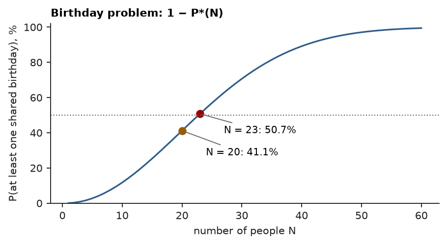

U10-A11Applied5 marks

For measurements 2, 4, 4 and 6, calculate the mean, sample variance, sample standard deviation and estimated standard error of the mean. State the denominator used for each.

Source Discussion 10.2

|  | **x** | **x − μ** | **(x − μ)²** |
| --- | --- | --- | --- |
| 1 | 2 | −2 | 4 |
| 2 | 4 | 0 | 0 |
| 3 | 4 | 0 | 0 |
| 4 | 6 | 2 | 4 |
| Sum | 16 | 0 | 8 |

1. **Mean (denominator N = 4).** μ = (2 + 4 + 4 + 6)/4 = 16/4 = **4**.

2. **Sample variance (denominator N − 1 = 3).** s² = 8/3 ≈ **2.67**. The N − 1 corrects for the fact that the deviations are measured from the estimated mean μ, not the true value (Discussion 10.2, equation 4).

3. **Sample standard deviation (square root of the N − 1 variance).** s = √(8/3) ≈ **1.63**. This is the typical spread of a single measurement about the mean.

4. **Standard error of the mean (denominator √N, that is N(N − 1) = 12 inside the root).** Δμ = s/√N = 1.63/√4 ≈ **0.82**, or √(8/12) by equation 5. This is the uncertainty of the *mean*, so the result is reported as 4.0 ± 0.8.

5. **The N version.** Equation 3 divides by N instead, giving a variance of 8/4 = 2 and σ ≈ 1.41. That describes the spread of these four numbers as a complete set, but it underestimates the population spread, which is why the best estimate uses N − 1.

U10-A12Applied5 marks

An instrument produces tightly clustered results that all exceed a reference value by the same amount. Distinguish precision, accuracy, random error and systematic error. Explain why repetition alone does not solve the problem.

Source Discussion 10.2

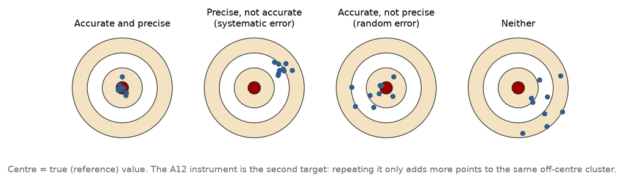

1. **Precision.** Precision is how closely repeated readings agree, or how finely the instrument resolves values. Tight clustering means high precision.

2. **Accuracy.** Accuracy is how close the readings are to the true (reference) value. Readings that are all offset from it are inaccurate, however tightly they cluster (Derry p. 114: "High precision is no guarantee of correctness").

3. **Random error.** Random error is unpredictable scatter of either sign. It limits precision, and this instrument has little of it.

4. **Systematic error.** Systematic error is a bias that pushes every reading the same way by the same amount, such as a miscalibrated zero, or a scale read while wearing heavy boots. That is exactly what the identical offset here shows.

5. **Why repetition does not help.** Averaging N readings shrinks *random* error: the average error tends to 0 by the Law of Large Numbers, and the standard error falls as 1/√N. But the bias is the same in every reading, so it survives averaging untouched. A thousand readings give a very precise estimate of the *wrong* value. The fix is to calibrate against a reference standard, or to cross-check with an independent method, and then correct for the offset.

U10-A13Applied5 marks

Interpret a p-value of 0.03 at a preselected 0.05 threshold. Explain why it is neither the probability that the null hypothesis is true nor a measure of the size of the effect.

Source Discussion 10.2

1. **Decision.** p = 0.03 ≤ 0.05, so the result is statistically significant at the preselected level, and the null hypothesis is rejected.

2. **Meaning.** *If the null hypothesis were true*, a result at least as extreme as the one observed would occur only about 3% of the time. The data would be unusual under H₀, which is the reason to doubt it. The p-value is a conditional probability, P(data at least this extreme | H₀) (Discussion 10.2).

3. **Not the probability that H₀ is true.** That would be P(H₀ | data), the conditional probability turned around. The two can be very different, just as P(positive | target) = 90% sat beside P(target | positive) = 9.1% in the screening example. P(H₀ | data) also depends on how plausible H₀ was before the study, which the p-value ignores.

4. **Not the size of the effect.** The p-value mixes effect size with sample size. A trivial difference measured on a huge sample can give p = 0.03, and so can a large difference on a small sample. Importance must be judged from the estimated effect and its uncertainty (μ ± Δμ), not from p.

5. **Caution.** Significance at 0.05 still allows a 5% Type I error rate when H₀ is true, so about 1 in 20 tests of a true null hypothesis will reach significance. A single p = 0.03 is evidence, not proof. Replication is the real test.

U10-A14Applied5 marks

For a null hypothesis of no difference, describe a Type I error and a Type II error. Explain why failing to reject the null is different from proving it true.

Source Discussion 10.2

**Null hypothesis H₀:** "There is no difference between the two treatments."

1. **Type I error.** This means rejecting H₀ when it is true: concluding that the treatments differ when they do not. It is a false positive, like convicting an innocent person. Example: a useless drug is declared better than placebo.

2. **Type II error.** This means failing to reject H₀ when it is false: missing a real difference. It is a false negative, like acquitting a guilty person. Example: a drug that really works is dismissed because the trial was too small to show it.

3. **The trade-off.** Science sets a strict rejection threshold (p ≤ 0.05) to keep Type I errors rare. With the same data, that makes Type II errors more likely. Only larger samples or better designs reduce both.

4. **Failing to reject is not proof.** "No significant difference" means the data are *compatible* with H₀. They may also be compatible with a real but small difference that the study could not detect. Absence of evidence is not evidence of absence.

5. **Why.** A test can only show that data are improbable under H₀. It never shows that H₀ is true, just as a theory can be falsified but never proven (Derry p. 200). The course says a Type II error is to "accept" a false H₀. The more careful wording is "fail to reject," which is why a non-significant result usually calls for more experiments.

U10-A15Applied5 marks

A voluntary questionnaire receives 80 favourable and 20 unfavourable replies from 2000 purchasers. Explain what the observed 80 percent describes and why it cannot automatically estimate success among all purchasers.

Source Discussion 10.2; Derry Chapter 7

1. **What the 80% describes.** 80 of the 100 people who *replied* were favourable. The 80% describes the respondents only.

2. **The response rate.** Only 100 of 2000 purchasers replied, a response rate of 5%. The other 95% are unknown.

3. **Nonrandom response.** The people who choose to answer a voluntary questionnaire are not a random sample. Satisfied customers, or very unhappy ones, may be the most likely to reply, so the respondents may differ systematically from the silent majority (Derry p. 103).

4. **How wide the uncertainty is.** If all 1900 non-respondents were unfavourable, success among all purchasers would be 80/2000 = 4%. If all were favourable, it would be 1980/2000 = 99%. The data alone allow anything from 4% to 99%, so 80% cannot be automatically taken as the population figure.

5. **What would fix it.** Survey a *random* sample of purchasers and follow up the non-respondents, or compare respondents with non-respondents on known characteristics. Only then can the sample percentage estimate the population percentage, with an uncertainty attached. A large count of replies does not cure bias.

U10-A16Applied10 marks

Two hypothetical interventions have response counts 45 of 50 and 180 of 200, with adverse-event counts 5 and 8 respectively. Compare rates using proper denominators, identify missing control information, and give a qualified interpretation of this table.

Source Discussion 10.2; variation on Study Question 7

|  | **Treated** | **Responded** | **Response rate** | **Adverse events** | **Adverse-event rate** |
| --- | --- | --- | --- | --- | --- |
| Intervention 1 | 50 | 45 | 90% | 5 | 10% |
| Intervention 2 | 200 | 180 | 90% | 8 | 4% |

1. **Use rates, not counts.** Intervention 2 has four times as many responders (180 vs 45), but it was also given to four times as many people. Each count must be divided by its own number treated.

2. **Response rates are identical.** 45/50 = 90% and 180/200 = 90%. The table shows no difference in effectiveness at all.

3. **Adverse-event rates differ.** 5/50 = 10% versus 8/200 = 4%. Intervention 1's rate is 2.5 times as high, but its count is very small (5 events).

4. **Uncertainty from small samples.** With 50 people, the 95% interval for the response rate is roughly 82% to 98%, while with 200 people it is about 86% to 94%. The adverse-event difference (10% vs 4%) is *not* statistically significant (Fisher exact test, p ≈ 0.14). A few events either way could change the picture.

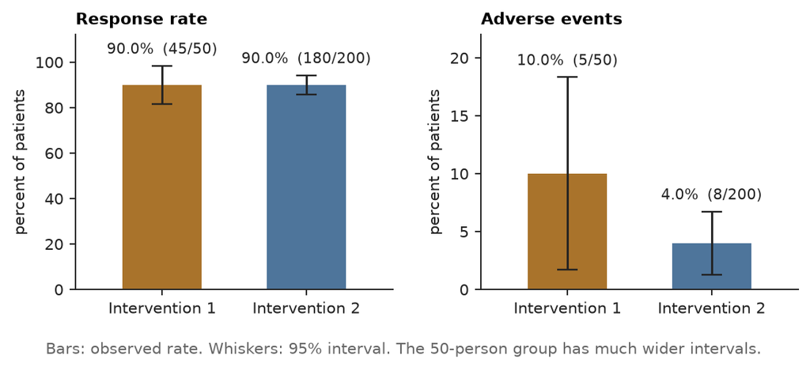

5. **Missing: a control group.** The table has no untreated or placebo group. If 90% of people recover without treatment, neither intervention does anything. A response rate means little without the comparison rate.

6. **Missing: randomization and comparability.** The table does not say whether patients were randomly assigned or whether the two groups were alike in age, severity and other treatments. Healthier or more motivated patients in one group could produce an apparent difference (Derry p. 103 on volunteers).

7. **Missing: blinding and definitions.** We are not told how "response" and "adverse event" were defined, who judged them, or whether patients and assessors knew which intervention was given. Unblinded judgments can be biased.

8. **Missing: the background adverse-event rate.** Some adverse events happen anyway. A control group would show how many are caused by the interventions, and over what follow-up period.

9. **Qualified interpretation.** On these data, the two interventions appear *equally effective*. Intervention 2 *may* be safer, but that difference is not statistically established. Neither intervention has been shown to work at all, because there is no control.

10. **What to do next.** Run a randomized, blinded, controlled trial with a placebo arm, large enough to detect a realistic difference in adverse events, with outcomes defined in advance. Until then, a forced choice would lean slightly towards Intervention 2 (same response, lower observed harm, larger sample), while recognizing that this could be a Type II or chance result.

Note*Beyond the course formulas: the intervals are standard 95% normal-approximation intervals and the p-value is a two-sided Fisher exact test; a two-proportion z-test gives p ≈ 0.09, also above 0.05.*

### People and attributions20

U10-P01Person

Identify Plato (427-347 BCE) and the idea or contribution the assigned readings ascribe to this person. Explain its significance in this unit.

Source Discussion 10.1 epigraph; Unit 10 Overview

1. **Who.** Plato (427-347 BCE) was an ancient Greek philosopher (Unit 3 Overview). Discussion 10.1 opens with an epigraph from him.

2. **Quotation.** "I have hardly ever known a mathematician who was capable of reasoning" (Discussion 10.1 epigraph).

3. **Contribution.** In his dialogue *Timaeus* Plato published a geometrical theory of the four elements (earth, air, fire and water), so he "can be considered the grandfather of mathematical physics" (Unit 10 Overview).

4. **Meaning.** The epigraph is ironic, coming from the grandfather of mathematical physics. The discussion does not explain it, but read with Unit 8 its point is that deduction inside a mathematical system is not the whole of reasoning: theorems are true only relative to their axioms, and a system used to describe the world needs axioms that also satisfy the correspondence criterion of truth (Discussion 10.1).

5. **Significance.** Unit 10 traces how mathematics became the language of science. Ancient science did not develop in any systematic way, mathematics fell into disrepute with the rise of Rome, and the mathematical sciences we know today came into being, as sciences, only during the scientific revolution of the 17th century (Unit 10 Overview).

U10-P02Person

Identify Sir James Jeans (1877-1946) and the idea or contribution the assigned readings ascribe to this person. Explain its significance in this unit.

Source Unit 10 Overview epigraph

1. **Who.** Sir James Jeans (1877-1946) was a British physicist and astronomer. The first epigraph of the Unit 10 Overview comes from his book *The Mysterious Universe* (1933) (Unit 10 Overview).

2. **Quotation.** "From the intrinsic evidence of his creation, the Great Architect of the Universe now begins to appear as a pure mathematician" (Unit 10 Overview).

3. **Meaning.** Judged only by the evidence of the world itself, its maker seems to think mathematically: the deepest regularities of nature are best written as mathematics. The word "now" marks this as a modern view, since the mathematical sciences came into being as sciences only in the 17th century (Unit 10 Overview).

4. **Significance.** The epigraph introduces the unit's claim that "Mathematics has a premier role in modern science" (Unit 10 Overview). In the physical sciences all theories are expressed in mathematical language; mathematical and simulation models give deep insights in population biology, genetics and ecology; and models are essential in economic forecasting. The social and human sciences lack general theories developed enough to be cast into mathematical form, so they often use only statistics to find correlations between variables.

U10-P03Person

Identify Richard Feynman (1918-1988) and the idea or contribution the assigned readings ascribe to this person. Explain its significance in this unit.

Source Unit 10 Overview epigraph

1. **Who.** Richard Feynman (1918-1988) was a Nobel Prize winning physicist (Discussion 5.1). The second epigraph of the Unit 10 Overview comes from his book *The Character of Physical Law* (1965) (Unit 10 Overview).

2. **Quotation.** "To those who do not know mathematics it is difficult to get across a real feeling as to the beauty, the deepest beauty, of nature" (Unit 10 Overview).

3. **Meaning.** Without mathematics it is hard to convey the deepest beauty of nature, because the laws that show it are mathematical. Discussion 10.1 names what mathematical form gives a theory: simplicity, economy of effort, generality and precision. Newton's force law F = ma, for example, applies to "a tremendous variety of cases from falling apples to projectile motions to planetary orbits" (Discussion 10.1).

4. **Significance.** For Unit 10, mathematics is part of understanding nature, not only a tool for calculation. Mathematics has the reputation of being a hard subject, but it is an essential one for science, and "every science student needs to develop a strong mathematical background" (Discussion 10.1).

U10-P04Person

Identify Werner Heisenberg (1901-1976) and the idea or contribution the assigned readings ascribe to this person. Explain its significance in this unit.

Source Unit 10 Overview footnote

1. **Who.** Werner Heisenberg (1901-1976) was a physicist (Unit 10 Overview); his dates are given where Discussion 12.1 quotes him (Discussion 12.1).

2. **Idea.** A footnote of the Unit 10 Overview reports his judgement that the *Timaeus* and Newton's *Principia Mathematica* "are the two most influential works of science ever published" (Unit 10 Overview). The course adds that we might put Darwin's *Origin of Species* on the list.

3. **Context.** The *Timaeus* is Plato's dialogue containing a geometrical theory of the four elements, which makes Plato the grandfather of mathematical physics (Unit 10 Overview). Newton's *Principia* gave "the final seal of approval" to the physico-mathematical method of science (Discussion 10.1).

4. **Significance.** The two works Heisenberg ranks highest are both mathematical theories of nature, written some two thousand years apart. They mark the two ends of the story Unit 10 tells: recognition of the value of mathematics for understanding the world in ancient Greece, and the creation of the mathematical sciences, as sciences, during the scientific revolution of the 17th century (Unit 10 Overview).

U10-P05Person

Identify E. T. Bell and the idea or contribution the assigned readings ascribe to this person. Explain its significance in this unit.

Source Discussion 10.1

1. **Who.** E. T. Bell was a mathematician, author of *Mathematics: Queen and Servant of Science* (Discussion 10.1).

2. **Quotation.** "Mathematics is the queen and servant of science" (Discussion 10.1).

3. **Meaning.** The saying captures a dual role. As servant, mathematics is "the primary tool of much scientific work." As queen, it "commands" science: a theorem derived in a mathematical system accepted as the frame for a scientific theory must be interpreted in terms of the theory, and its conclusion accepted either as a consequence of the theory or as an indication that the mathematical system is not an appropriate framework (Discussion 10.1).

4. **Example.** Newtonian mechanics rests on the axioms of calculus, of Euclidean space and universal time, Newton's three laws of motion and the point-mass assumption. Its theorems held until measurements in the 19th century showed they were accurate only when terms of order (v/c)<sup>2</sup> could be neglected (Discussion 10.1).

5. **Significance.** Stating a theory mathematically brings simplicity, economy of effort, generality and precision (Discussion 10.1), but it also binds the theory to whatever its mathematics entails.

U10-P06Person

Identify G. Spencer-Brown and the idea or contribution the assigned readings ascribe to this person. Explain its significance in this unit.

Source Discussion 10.1

1. **Who.** G. Spencer-Brown was a logician, author of *Laws of Form* (Discussion 9.2). Discussion 10.1 quotes him at the end of its account of mathematical systems.

2. **Quotation.** "A mathematical text is ... not an end in itself, but a key to a world beyond the compass of ordinary description" (Discussion 10.1).

3. **Meaning.** A mathematical text is a key to a world beyond ordinary description: its symbols are a means, not a goal, and they open parts of nature that ordinary language cannot describe precisely, such as the orbits and motions that Newton's equations of motion give (Discussion 10.1).

4. **Context.** The quotation follows the advice that "To acquire facility in mathematical reasoning, it is necessary to work through many examples and problems" (Discussion 10.1). A key helps only someone who can use it, which is why every science student needs a strong mathematical background.

5. **Significance.** Mathematics is "the primary tool of much scientific work" (Discussion 10.1), and Unit 10 shows that the ability to read and work with mathematical texts is what gives access to the content of modern physical theories. In Unit 9 the course quotes the same book, *Laws of Form*, on the mental process by which a class is defined (Discussion 9.2).

U10-P07Person

Identify Karl Popper (1902-1994) and the idea or contribution the assigned readings ascribe to this person. Explain its significance in this unit.

Source Discussion 10.1

1. **Who.** Karl Popper (1902-1994) was a philosopher of science (Discussion 3.2; Discussion 10.1).

2. **Idea.** Popper "went so far as to insist that a theory that could not be falsified could not be scientific" (Discussion 10.1). No amount of empirical evidence can definitively establish the truth of a theory, but a single counter-instance can show it is false. So a scientifically acceptable theory must have the possibility to be shown false; if no counter-instances are possible, even in principle, the theory cannot be accepted (Discussion 10.1).

3. **Context.** Derry calls this the criterion of falsifiability, which as a formal doctrine is "closely associated with the philosophy of Karl Popper" (Derry, p. 200). Discussion 10.1 uses it to show what science means for us today: science based on experiment, with all theoretical conclusions or hypotheses experimentally or observationally tested.

4. **Significance.** "Before the 17th century this was not the way that science was done" (Discussion 10.1). Medieval and Renaissance science was Aristotelian natural philosophy, syllogistic deduction from speculative initial hypotheses, and a contrived experiment was thought to distort nature. Popper's criterion shows how far the 17th-century rise of the mathematical and experimental sciences moved from that ideal.

U10-P08Person

Identify Galileo Galilei (1564-1642) and the idea or contribution the assigned readings ascribe to this person. Explain its significance in this unit.

Source Discussion 10.1

1. **Who.** Galileo Galilei (1564-1642) (Discussion 11.3) taught mathematics at Padua (1592-1610) (Discussion 10.1).

2. **Contribution.** At Padua he took part in vigorous debates on whether a quantitative mathematical description could be acceptable in a real science in place of a causal explanation. "Real science" then meant Aristotelian science, which did not use mathematics and required certainty: syllogistic deduction from premises taken as obvious to all or supported by "weighty authority" (Discussion 10.1).

3. **Transitional figure.** Galileo kept a version of the Aristotelian idea of common experience as the basis for conclusions. In his writings on falling bodies he did not describe specific experiments; he described the apparatus and asserted that he had done the experiments "many" times, always with the same results, appealing to the Aristotelian condition of memory of many instances of the same thing (Discussion 10.1).

4. **Significance.** The Padua debates raised one of the major issues the scientific revolution had to resolve: how to justify applying mathematics to studies of nature. Discussion 10.1 calls Galileo a transitional figure, because the full marriage of mathematical description and causation came only later in the 17th century.

U10-P09Person

Identify Honoré Fabri (1607-1688) and the idea or contribution the assigned readings ascribe to this person. Explain its significance in this unit.

Source Discussion 10.1

1. **Who.** Honoré Fabri (1607-1688) was a French Jesuit theologian and natural philosopher (Discussion 10.1).

2. **Idea.** He argued that physical hypotheses and mathematics could not be combined in science, because sense data, being imprecise, could never provide support for exact mathematical conclusions (Discussion 10.1).

3. **Quotation.** Criticizing Galileo's work on inclined planes and falling bodies, he wrote in 1646 that "sensory experience cannot vindicate mathematically precise ratios ... only doubtful hypotheses can be drawn from doubtful experiences ... and doubtfulness is not science" (Discussion 10.1).

4. **Context.** For Aristotelians, mathematics was a useful tool for calculation but had little or no place in "real" science, which required certainty. Fields such as mechanics, optics, astronomy and medicine relied on measurements that could never be exact, so they were not certain (Discussion 10.1).

5. **Significance.** Fabri states the objection the 17th century had to answer before mathematics could be applied to nature. It was answered by accepting that a mixed mathematical science, built on principles drawn from experiment, can be as secure as is humanly possible without being absolutely certain (Discussion 10.1).

U10-P10Person

Identify Niccolò Cabeo (1586-1650) and the idea or contribution the assigned readings ascribe to this person. Explain its significance in this unit.

Source Discussion 10.1

1. **Who.** Niccolò Cabeo (1586-1650) was a Jesuit teacher of natural philosophy and mathematics who published *Philosophia magnetica* in 1629 (Discussion 10.1).

2. **Idea.** He insisted he was doing physics (that is, natural philosophy), not mathematics, even while using mathematical methods. He admitted his results were not certain and said he would accept a better physical theory over his own, except for the parts of his theory based on mathematical proof (Discussion 10.1).

3. **Stability.** With this Cabeo moved toward recognizing "the stability of mathematical theories": any new theory must incorporate, or in some way explain, the mathematically certain aspects of the theory it replaces (Discussion 10.1).

4. **Predictive power.** He also appealed directly to a theory's predictive power as evidence for its underlying assumptions. Some astronomical events occur on a long time scale, so observing them requires a synthesis of many observers over thousands of years; the resulting laws of celestial motion give an excellent fit to the data, and their acceptance "arises from the continual fulfillment of predictions" (Discussion 10.1).

5. **Significance.** Cabeo shows natural philosophers beginning to accept mathematics as an appropriate language for describing nature, with predictive success, not certain deduction, as the ground for accepting a theory.

U10-P11Person

Identify Isaac Barrow (1630-1677) and the idea or contribution the assigned readings ascribe to this person. Explain its significance in this unit.

Source Discussion 10.1

1. **Who.** Isaac Barrow (1630-1677) was Newton's immediate predecessor as Lucasian professor of mathematics at Cambridge (Discussion 10.1).

2. **Idea.** In Barrow's view, what was coming to be called the physico-mathematical approach was superior to the Aristotelian method. He argued that all science requires mathematics in one degree or another, since all sciences involve quantitative considerations (Discussion 10.1).

3. **Meaning.** This is directly opposed to the Aristotelian idea of what a science is. Aristotelian "scientific knowledge" was certain syllogistic deduction from initial hypotheses, while fields that needed measurement, such as mechanics, optics, astronomy and medicine, could only be "opinion." Barrow admitted many such areas of study as sciences (Discussion 10.1).

4. **Significance.** Barrow was an important figure in promoting the use of mathematics in science. By the mid-17th century the term "physico-mathematics" described mathematics as a tool for gaining genuine physical knowledge, and the belief that the "mixed mathematical disciplines" could produce genuine causal understanding of nature soon became commonplace (Discussion 10.1).

U10-P12Person

Identify Marin Mersenne (1588-1648) and the idea or contribution the assigned readings ascribe to this person. Explain its significance in this unit.

Source Discussion 10.1

1. **Who.** Marin Mersenne (1588-1648) was a French monk (Discussion 10.1).

2. **Contribution.** He used the mixed mathematical sciences as paradigmatic models for understanding nature and promoted them through extensive correspondence with the major figures of the age, playing a major role in the development of 17th-century science along mixed mathematical lines (Discussion 10.1).

3. **Motive.** Much of his attraction to these physico-mathematical models was that they were not Aristotelian and did not claim absolute certainty. In an echo of medieval concern over the possibility of absolutely certain demonstration, he feared that such certainty could pose a threat to religion (Discussion 10.1).

4. **Context.** The mixed mathematical sciences rely on empirically derived physical principles as well as on mathematical demonstrations. While Aristotelians fought this incursion of mathematics into natural philosophy, it kept gaining credence as a new way to obtain knowledge of nature (Discussion 10.1).

5. **Significance.** Mersenne shows that the new sciences spread through networks of letters, and that giving up the claim to absolute certainty could be a strength: knowledge as secure as is humanly possible, though not absolutely certain, became the standard of the mathematical sciences (Discussion 10.1).

U10-P13Person

Identify Tycho Brahe (1546-1601) and the idea or contribution the assigned readings ascribe to this person. Explain its significance in this unit.

Source Discussion 10.1

1. **Who.** Tycho Brahe (1546-1601) was a wealthy Danish nobleman (Discussion 3.3) and a Danish astronomer who collected masses of data on the orbit of Mars (Discussion 10.1).

2. **Idea.** Tycho rejected the Copernican system and argued that the planetary orbits must be circular, because the perfection of the heavens could only arise if the planetary orbits could "return upon themselves," which required circular orbits (Discussion 10.1).

3. **Observational objection.** If the Copernican theory were correct, stellar parallax should be observable, but with the instruments of the time no such effect was seen. Tycho therefore proposed a hybrid theory in which the planets orbit the sun in circles while the sun circles the earth (Discussion 3.3). Unit 10 Study Question 4 asks for both his observational and his theoretical objections (Unit 10 Study Questions).

4. **Significance.** Discussion 10.1 uses Tycho to illustrate the medieval point of view. Medieval natural philosophers fitted observations into pre-assumed forms based on metaphysical speculation about the divine order, deducing phenomena from first principles such as the primacy of circular motion. The new experimental method went the opposite way, inductively inferring first principles from empirical data (Discussion 10.1).

U10-P14Person

Identify Johannes Kepler (1571-1630) and the idea or contribution the assigned readings ascribe to this person. Explain its significance in this unit.

Source Discussion 10.1

1. **Who.** Johannes Kepler (1571-1630), the poor son of a German soldier, became Tycho's assistant in Prague (Discussion 3.3).

2. **Contribution.** Kepler accepted Copernican theory and, using the masses of data Tycho had collected on the orbit of Mars, produced the inductive hypothesis that the orbit of Mars (and of the other planets) was better modeled as ellipses (Discussion 10.1). He tried circular schemes for years, but Tycho's observations were so precise that "close was not good enough," and an ellipse gave a perfect fit: Kepler's first law (Derry, p. 59).

3. **Transitional figure.** Kepler believed that the planets were held in their orbits by some sort of "magnetic" force, but he could not connect this force with the shape of the orbits, and he believed the orbits were as they were because they fit within nested Platonic solids (Discussion 10.1).

4. **Significance.** Kepler's inductive hypothesis illustrates the new direction of the 17th century: inferring first principles from empirical data instead of fitting observations into pre-assumed forms. As Derry puts it, "No one before Kepler would have given up their metaphysical presuppositions just because the data didn't fit" (Derry, p. 60).

U10-P15Person

Identify Isaac Newton and the idea or contribution the assigned readings ascribe to this person. Explain its significance in this unit.

Source Discussion 10.1

1. **Who.** Isaac Newton definitively formulated the idea of scientific explanation in terms of mathematical law, finalizing the marriage between mathematical description and causation (Discussion 10.1).

2. **Method.** If laws of nature have mathematical form, an equation obeyed in every known case of empirical observation can be taken to express the underlying universal law, even though it arose from empirical induction. His controversial 1672 letter to the Royal Society on light and colour used contrived experiments with prisms to validate this theorizing and claimed mathematical certainty (Discussion 10.1).

3. **Quotation.** Replying to criticism, he wrote to Henry Oldenburg, secretary of the Royal Society: "the absolute certainty of a science cannot exceed the certainty of its principles" (Discussion 10.1). His principles came from experiments, "and so but physical"; mixed mathematical sciences can never give absolute certainty, only knowledge as secure as humanly possible.

4. **Footnote.** This is the background of his statement "I do not feign hypothesis": then, a hypothesis meant a speculative assumption used to start a syllogistic argument; today it means an inductively generated conjecture (Discussion 10.1).

5. **Significance.** After the *Principia*, the Royal Society associated its experimental practice with Newton's physico-mathematical justifications, and the mathematical sciences triumphed over scholastic natural philosophy (Discussion 10.1).

U10-P16Person

Identify Robert Hooke (1635-1703) and the idea or contribution the assigned readings ascribe to this person. Explain its significance in this unit.

Source Discussion 10.1

1. **Who.** Robert Hooke (1635-1703) was the critic who challenged Newton's 1672 letter to the Royal Society on light and colour, in which Newton used contrived experiments with prisms and claimed mathematical certainty for his results (Discussion 10.1).

2. **Objection.** Hooke objected to Newton's prism conclusions. He argued that Newton's assumption that a prism split white light into a spectrum of colours was not the only hypothesis explaining his experimental results, and he doubted that Newton's conclusions could be mathematically certain (Discussion 10.1).

3. **Reply.** Newton answered in a letter to Henry Oldenburg, secretary of the Royal Society, that "the absolute certainty of a science cannot exceed the certainty of its principles." His principles came from experiments and so were only physical, but if a mathematician could derive all the phenomena of colours from them, the science of colour would be "granted mathematical and as certain as any part of optics" (Discussion 10.1).

4. **Significance.** Newton's bold move "did not go unchallenged" (Discussion 10.1). Hooke's challenge drew out the key point of the new method: mixed mathematical sciences, resting on empirically derived principles, can never provide absolute certainty, only knowledge as secure as is humanly possible.

U10-P17Person

Identify Peter Dear and the idea or contribution the assigned readings ascribe to this person. Explain its significance in this unit.

Source Discussion 10.1

1. **Who.** Peter Dear is a historian of science, author of *Discipline and Experience* (1995), which Discussion 10.1 quotes at its close (Discussion 10.1).

2. **Quotation.** "After [this] the [Royal] Society began to associate its experimental practice with Newton's physico-mathematical justifications. Only then ... did it begin to appear as an original mover of a new kind of natural philosophy" (Discussion 10.1).

3. **Idea.** "When the Fellows adopted Newton as their champion, the mathematical sciences achieved their final triumph over scholastic natural philosophy. But in the process, those sciences had themselves mutated into something new, becoming explicitly experimental" (Discussion 10.1). The mathematical sciences triumphed over scholastic natural philosophy, but became explicitly experimental.

4. **Significance.** Dear's verdict sums up the history in Unit 10. The Aristotelian ideal of certain deduction from speculative hypotheses gave way to mathematical laws grounded in experiment, with the publication of the *Principia* as "the final seal of approval" for the new method (Discussion 10.1). That is why science, for us, is based on experiment, with all theoretical conclusions tested.

U10-P18Person

Identify Benjamin Disraeli (1804-1881) and the idea or contribution the assigned readings ascribe to this person. Explain its significance in this unit.

Source Discussion 10.2 epigraph

1. **Who.** Benjamin Disraeli (1804-1881) was a British prime minister. Discussion 10.2 opens with an epigraph "attributed to" him, so the readings ascribe the saying to him without claiming that he said it (Discussion 10.2).

2. **Quotation.** "There are three kinds of lies: lies, damn lies, and statistics" (Discussion 10.2).

3. **Meaning.** Numbers can mislead while sounding exact. Derry shows how: statistical facts may be cited selectively, samples may be too small or not random, and "the major intentional use of statistics to mislead people employs accurate numbers that are then incorrectly interpreted" (Derry, p. 103).

4. **Significance.** The epigraph opens Unit 10's study of probability and statistics, and the unit's answer to the cynic is to understand the tools: the difference between probability and frequency (Discussion 10.2), the importance of unbiased samples, the standard deviation as a measure of spread about the average, and the meaning of a statistically significant result (Unit 10 Overview).

U10-P19Person

Identify Karl Friedrich Gauss (1777-1855) and the idea or contribution the assigned readings ascribe to this person. Explain its significance in this unit.

Source Discussion 10.2

1. **Who.** Karl Friedrich Gauss (1777-1855) was a German mathematician (Discussion 10.2).

2. **Contribution.** The errors in a data set are described by the first two moments of the error distribution function, which raises the question of its best mathematical form. Gauss answered it in 1809 and so derived the normal distribution: he proved that if the maximum likelihood estimate from a series of measured values of a parameter must equal their arithmetic mean, this determines a unique error distribution, "now called the Gaussian, or Normal distribution" (Discussion 10.2).

3. **Properties.** Besides arising from a very natural criterion, the Normal distribution is stable: any linear combination of normally distributed random variables is also normally distributed. The Central Limit Theorem formalizes this: for independent, identically distributed variables with finite variance, the limit as the number of variables increases approaches a normal distribution (Discussion 10.2).

4. **Limits.** It assumes the variables are independent; correlations can introduce substantial deviations, and in complex systems power law error distributions often fit better and greatly increase the probability of extreme deviations (Discussion 10.2).

5. **Significance.** The Normal distribution underlies the error estimates of Discussion 10.2, the standard deviation and the error of the mean, and so the judgement of whether a measured result agrees with a hypothesis.

U10-P20Person

Identify Gregory N. Derry and the idea or contribution the assigned readings ascribe to this person. Explain its significance in this unit.

Source Derry, pp. 102-103

1. **Who.** Gregory N. Derry is the author of the course text *What Science Is and How It Works* (Unit 1 Overview). Unit 10 assigns his section on statistics, pp. 102-103 (Unit 10 Overview).

2. **Idea.** Derry warns that "the use of statistics presents some extra opportunities to mislead" (Derry, p. 102). Facts may be cited selectively, another version of suppressed evidence, and reliability depends on the size and quality of the sample: "Conclusions based on small samples tend to be quite unreliable" (Derry, p. 103).

3. **Random samples.** "To tell us something unambiguously, a statistical sample must be chosen randomly" (Derry, p. 103); a survey of Sierra Club members will not show American opinion on environmental issues. A nonrandom response rate also biases results: people who return a survey, or volunteer for a heart disease drug trial, may differ from the whole sample (Derry, p. 103).

4. **Other traps.** Question wording sways opinion surveys, crime statistics count crimes reported, not committed, and accurate numbers can be misread: a 1.2 percent increase is a substantial cut when inflation is 4.5 percent (Derry, p. 103).

5. **Significance.** Unit 10 asks students to discuss "the importance of having unbiased samples" (Unit 10 Overview). In Study Question 6, 246 of 342 letters (72%) praise a diet, but only self-selected readers wrote (Unit 10 Study Questions).

Unit 11

## Symmetry Classification and Models

Approach State the purpose, equivalence convention and mutation-rate convention before classifying or calculating. References to model construction in Discussion 10.3 point to Discussion 11.3.

### Official study guide questions11

U11-SG01Study guide

Write a short essay (300-500 words) on the relationship between symmetries, distinctions and the principle of the identity of indiscernibles.

Source Unit 11 Study Questions question 1

**Thesis.** Symmetry and distinction are two sides of one act. Drawing a distinction breaks some symmetries and highlights the ones that remain. The principle of the identity of indiscernibles then lets us treat everything that is still symmetric as "the same" and give it one name.

**Symmetry.** A symmetry is invariance under a transformation. A square looks the same after a quarter turn, and a species keeps its form from one generation to the next. Two things are similar when a transformation carries one into the other without changing what we care about. The word comes from the root *me*, "to measure": symmetric things are of like measure (Discussion 11.1).

**Distinction.** Spencer-Brown wrote that "distinction is perfect continence." A boundary has two sides, and a point on one side cannot reach the other without crossing it. A distinction is drawn for a motive, because the two sides differ in value, and each side can then be named. Every distinction breaks a symmetry. A baseball is the same ball wherever it is, but home plate turns its position into "ball" or "strike," which breaks translation symmetry.

**Why they are complementary.** They look like opposites. Things that are symmetric cannot be told apart, and to tell two things apart we must find some respect in which they differ. But every distinction also assumes symmetry: all points on one side get the same value, or else more distinctions would be present. Distinguishing a disk from its background breaks the background's uniformity and, at the same moment, highlights the disk's circular symmetry. That symmetry can then define the class of all disk-like things.

**The identity of indiscernibles.** Leibniz's principle says that things that cannot be distinguished are to be considered identical (Discussion 9.1). Classification uses it in a weaker form: things that do not differ on the relevant variables get the same name. Fritz is tabby and Felix is black, but colour is not a "difference that makes a difference" to cathood, so both are cats. They share a typological identity, not an individual identity (Discussion 11.2).

**Level of discourse.** What counts as indiscernible depends on the purpose. Colour is irrelevant to biology but decisive at a cat show. Lions and tigers are the same at the level of genus and different at the level of species. A classic error is to assume that two things with the same name for one purpose are the same for another.

**Conclusion.** Classification works by choosing which distinctions to draw. Each distinction breaks some symmetries and leaves others. The symmetries that remain define a class, and the identity of indiscernibles justifies one generic name for its members. This is what lets science speak about all cats rather than only about Fritz.

U11-SG02Study guide

Many organic compounds in nature come in both right-handed (*dextro*) and left-handed (*levo*) forms, yet all life is based only on the left-handed form. When organic compounds are found in nature, they are almost always of the left-handed form, but when they are prepared in the laboratory, half are left-handed and half are right-handed. Furthermore, the difference between the two forms can be determined by the way that solutions containing them refract light. Based on this information, suggest a solution for the following problem facing Sherlock Holmes.

Martha Weatherby died after eating a soup containing some mushrooms that may have been poisonous. Holmes suspects, however, that the soup was artificially doped with a synthetic mushroom poison concocted by her husband, the fiendish chemist Walter Willingdon Weatherby. How is he to determine whether his suspicion is correct?

Source Unit 11 Study Questions question 2

1. **The key fact.** A compound made by a living organism is almost always of one handedness only. The same compound made in a laboratory comes out as a 50:50 mixture of left- and right-handed molecules (a racemic mixture). The two forms are almost indistinguishable chemically, so ordinary chemical tests cannot tell natural poison from synthetic poison. But the two forms affect light differently (Derry p. 268).

2. **The test.** Holmes should isolate the poison from the leftover soup (or from the stomach contents) and shine polarized light through a solution of it. A solution of a single-handed compound turns the plane of polarization. In a 50:50 mixture the two forms turn it equally in opposite directions, so there is no net turning.

3. **The control.** He should extract the same poison from wild mushrooms of the same species and measure it in the same way. This shows how a natural sample behaves, and how much turning to expect for a given amount of poison. It also checks the method. He must isolate the poison first, because other ingredients of the soup may affect light too.

4. **Reading the result.** If the soup's poison turns the light as much as the natural sample does, for the same amount of poison, the poison came from mushrooms. That supports an accident. If it shows no turning, the poison is synthetic. If it shows less turning than its amount predicts, some synthetic poison was added. Either of the last two results supports Holmes's suspicion that the soup was doped.

5. **Limits.** The test shows only *whether* synthetic poison is present, not *who* put it there. Holmes still needs evidence that ties Walter to the soup: access to it, the poison in his laboratory, and a motive. The reasoning also depends on the simplified premise that a synthetic poison is always a 50:50 mixture. A skilled chemist might be able to separate the two forms. So a natural-looking result would not clear Walter completely.

Note*Course wording: the question says the two forms differ in how they "refract" light. The measurable difference is optical rotation: a solution of one form turns the plane of polarized light. Derry says only that they "have different effects on light shining through them" (p. 268).*

Note*Course wording: "all life is based only on the left-handed form" is too strong. Derry notes that our bodies contain right-handed glucose but left-handed fructose (p. 268). What matters for Holmes is that living things make only one form of a given compound.*

Note*Outside the readings: the instrument that measures optical rotation is a polarimeter, and the two forms of one compound can in principle be separated by a skilled chemist.*

U11-SG03Study guide

Mathematically speaking, a “necklace” consists of some number of “beads” strung in a circle. Thus, it has a rational symmetry about the centre of the circle-it does not matter which bead is at the top. It may or may not matter if one moves clockwise or counter-clockwise about the circle.

a. For five beads that can be either black or white, construct an example of a necklace other than one with all black or all white beads.

b. Construct a classification of all necklaces that can be made with three beads that can be red, blue or yellow. Put all necklaces that are related by a symmetry into the same category.

Source Unit 11 Study Questions question 3

**a. A five-bead necklace in black and white.** Black, black, white, black, white, read clockwise from the top. Turning the necklace gives five different readings of the same necklace. Reading it counter-clockwise gives one of those five readings, so for this necklace the direction does not matter.

Note*For reference, five beads in two colours make 8 different necklaces (the 2 one-colour necklaces and 6 others), whether or not the necklace may be flipped over. All counts here were found by listing every arrangement and checking them by computer.*

**b. Classification of three-bead necklaces in red (R), blue (B) and yellow (Y).**

1. **Convention.** Two arrangements are the same necklace if turning one gives the other, as the question says ("it does not matter which bead is at the top"). Each class below is named by one arrangement, read clockwise from the top.

2. **One colour: 3 classes.** RRR, BBB and YYY. Turning changes nothing, so each class holds just one arrangement.

3. **Two of one colour and one of another: 6 classes.** RRB, RRY, BBR, BBY, YYR and YYB (3 choices for the doubled colour times 2 for the single bead). Each class holds 3 arrangements; for example RRB, RBR and BRR are one necklace.

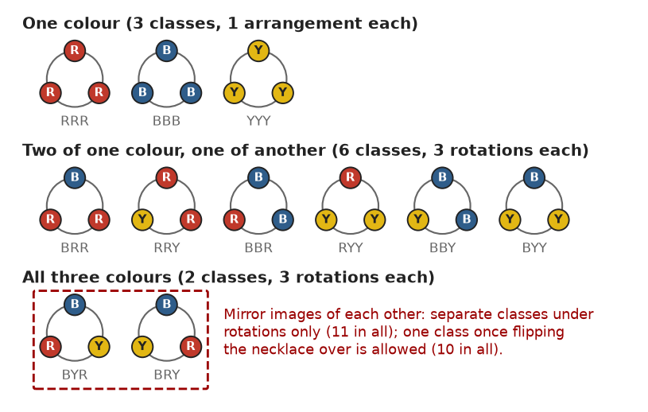

4. **All three colours: 2 classes.** RBY and RYB. Going clockwise, one meets red, blue, yellow on the first and red, yellow, blue on the second. No turn changes one order into the other, so they are different necklaces, and they are mirror images of each other.

5. **Check and the effect of direction.** There are 3 + 6 + 2 = 11 classes. They hold 3 × 1 + 6 × 3 + 2 × 3 = 27 arrangements, which is every way to colour three beads (3 × 3 × 3 = 27), so nothing is missed or counted twice. If clockwise and counter-clockwise do not matter (the necklace can be flipped over), RBY and RYB become one class, and there are 10 classes.

U11-SG04Study guide

Listed below are three different categories of psychological traits on which individuals can be measured. People who score high on one trait will tend to score high on other traits in the same category, suggesting that all traits in a category are related to a single, underlying variable. By considering the traits in each category, suggest possible type names for the three categories. Make these names as descriptive as possible of what you think might be the underlying variable.

Category 1: visualization; speed of recognition; spatial scanning; recognition of embedded figures; spatial relations; memory for designs; associative memory

Category 2: deduction; induction; number recognition; syllogistic reasoning; verbal comprehension

Category 3: use of synonyms; associational fluency; expressional fluency; facility with words; originality

Source Unit 11 Study Questions question 4

1. **Category 1: spatial-visual ability.** Every trait involves forming, scanning, holding or comparing visual images and spatial arrangements: visualization, spatial scanning, spatial relations, finding embedded figures and remembering designs. The underlying variable is the capacity to represent and manipulate information in visual and spatial form. In this list, "associative memory" most likely means memory for images and their locations.

2. **Category 2: logical-analytical reasoning.** Deduction, induction, syllogistic reasoning and number recognition all involve finding rules and drawing valid inferences from symbols. "Verbal comprehension" fits because it means *understanding* the meaning of statements. The underlying variable is the ability to grasp abstract relations and reason from them.

3. **Category 3: verbal fluency (creative expression).** Using synonyms, associational fluency, expressional fluency, facility with words and originality all involve *producing* many words, associations or new expressions quickly. The underlying variable is the ease and inventiveness of language production.

4. **Why these names.** Each name describes the shared underlying variable, not any single trait. Discussion 11.2 says a type name should indicate the type's function within the purpose of the typology. The name will also influence which new traits are later placed in the type, so it should be chosen with care.

5. **Cautions.** These are statistical types. No single trait is essential; the traits only tend to go together. Language appears in both Category 2 and Category 3, so "verbal" alone would not separate them; the difference is understanding versus producing. The names are hypotheses: they predict which other traits should correlate with each group (SG05).

Note*Outside the readings: these clusters resemble the "primary mental abilities" proposed by the psychologist L. L. Thurstone in the 1930s (for example spatial visualization, reasoning and word fluency).*

U11-SG05Study guide

On the basis of the type names you made up in Question 3, think of three or more other traits for each type that might correlate with the traits listed.

Source Unit 11 Study Questions question 5

Note*The question refers to "the type names you made up in Question 3"; the names were made up in Question 4 (SG04).*

1. **Spatial-visual ability.** Mentally rotating a three-dimensional object; reading a map and finding a route; assembling a jigsaw puzzle or following an assembly diagram; judging distances; drawing a scene from memory.

2. **Logical-analytical reasoning.** Solving arithmetic word problems; completing number or letter series ("what comes next?"); solving analogies (A is to B as C is to ?); spotting a fallacy in an argument; solving logic puzzles.

3. **Verbal fluency.** Naming as many words as possible that start with a given letter in one minute; rhyming and making puns; inventing and telling stories; listing many different uses for a common object such as a brick; writing slogans or verse.

4. **Why they should correlate.** Each new trait draws on the same underlying variable as its group. Map reading needs the same spatial imagery as spatial scanning, series completion needs the same rule-finding as induction, and naming words quickly needs the same word production as associational fluency.

5. **How to test the prediction.** Measure a sample of people on the old and the new traits and compute the correlations. A new trait belongs to a type if it correlates more strongly with that type's traits than with the other two groups. If it does not, the type name, or the placement of the trait, should be revised. This is the interplay between choosing variables and analysing data that Discussion 11.2 describes.

U11-SG06Study guide

Suppose that a collection of plants is to be classified in terms of four distinct characteristics. The classification is based on whether a plant has a particular characteristic or not. Thus, each plant can be represented by a four digit binary number. The number 1011, for example, would label plants having the first, third and fourth characteristics, but lacking the second. A total of seven four-digit binary numbers end up as labels for the categories of plants: 1111, 1110, 1011, 1010, 0110, 0011, 0010.

Assuming that all of the plants have evolved from the original species labeled 0010; that any given mutation will result in the presence of only one new characteristic; and that once a given characteristic is present, it remains, construct a phylogenetic tree for these plants.

**Note:** It may not be possible to determine all links uniquely; for those that cannot be so determined, use question marks.

Source Unit 11 Study Questions question 6

1. **Rules.** A plant gains one new characteristic per step (a 0 becomes 1) and never loses one. So a parent has exactly one fewer 1 than its child, and every 1 in the parent is also a 1 in the child. All seven labels contain the third characteristic, which is the one the original species 0010 already has.

2. **Links that are certain.** 1010, 0110 and 0011 each have only one possible parent, 0010. The only other way to reach them would be from 1000, 0100 or 0001, and none of those carries the original characteristic, so none can descend from 0010.

3. **Links that are uncertain (marked "?").** 1110 could come from 0110 or from 1010. 1011 could come from 0011 or from 1010. 1111 could come from 1011 or from 1110.

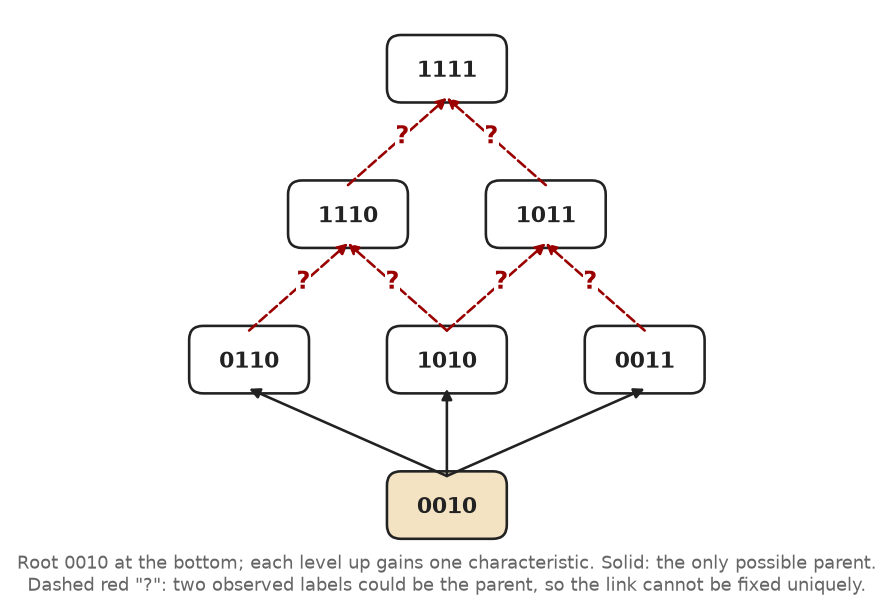

4. **How many histories fit.** Each of the three uncertain plants has 2 possible parents, so 2 × 2 × 2 = 8 different trees fit the data. Every one of them uses exactly six single-step mutations, so counting steps cannot decide between them. That is why the question marks are needed: the data do not fix a unique history.

5. **Assumptions and what would settle the question.** The tree assumes that each ancestor is one of the seven observed categories. If an unobserved or extinct form 0111 had existed, it could also be the parent of 1111. More characteristics, fossil or dating evidence, or the geographical distribution of the plants could resolve the uncertain links.

U11-SG07Study guide

An anthropological expedition discovers two civilizations living on different planets in the same solar system. On the basis of similarities in the languages spoken by the two peoples, it is hypothesized that both planets were settled by members of the same colonization expedition, and that they subsequently lost contact with each other. By making some estimates about rates of phoneme substitution and comparing the two existing languages, the linguists hope to work out an estimate of how long ago the separation took place.

Suppose that each planet has a language in which the vocabulary consists of eight four-digit binary numbers. Matching up words with similar meanings yields the lists shown below.

| **Language 1** | **Language 2** |
| --- | --- |
| 0001 | 0101 |
| 0101 | 1100 |
| 1001 | 0011 |
| 0110 | 0110 |
| 0111 | 1110 |
| 1011 | 0111 |
| 1101 | 1111 |
| 0011 | 0011 |

Assume that a mutation in a word of the original language consists of a flip of any single digit of that word, and that once a mutation has occurred, the new word does not mutate. Assume also that the average mutation rate is one word every 100 years. Estimate how long ago the two civilizations were separated.

Source Unit 11 Study Questions question 7

**Method.** Each word mutates at most once, by flipping one digit, so compare each pair digit by digit. If the two words are identical, the simplest reading is that neither changed. If they differ in one digit, one language changed and the other kept the original word. If they differ in two digits, both languages changed, each from a proto-word that lies one flip from each.

| **Pair** | **Language 1** | **Language 2** | **Digits that differ** | **Possible proto-words** | **Mutations** |
| --- | --- | --- | --- | --- | --- |
| 1 | 0001 | 0101 | 1 | 0001 or 0101 | 1 |
| 2 | 0101 | 1100 | 2 | 0100 or 1101 | 2 |
| 3 | 1001 | 0011 | 2 | 0001 or 1011 | 2 |
| 4 | 0110 | 0110 | 0 | 0110 (unchanged) | 0 |
| 5 | 0111 | 1110 | 2 | 0110 or 1111 | 2 |
| 6 | 1011 | 0111 | 2 | 0011 or 1111 | 2 |
| 7 | 1101 | 1111 | 1 | 1101 or 1111 | 1 |
| 8 | 0011 | 0011 | 0 | 0011 (unchanged) | 0 |

1. **Count.** 1 + 2 + 2 + 0 + 2 + 2 + 1 + 0 = 10 mutations since the two peoples separated.

2. **Rate.** The question gives "one word every 100 years." The worked example in Discussion 11.2 applies its rate to the whole system: it multiplies its 10 mutations by 75 years to get 750 years. Using the same convention, 10 mutations × 100 years = **about 1,000 years**.

3. **The other reading of the rate.** If each planet's language changes one word every 100 years, the two languages together change two words per century. Then 10 mutations take about 500 years. The answer depends on this convention, so it must be stated.

4. **Why it is only an estimate.** The rate is an average, and 10 events are very few, so the true time could easily be several centuries more or less. The rules also assume that no word changed twice and that no word was borrowed. A real study would use many words, the probabilities of different sound changes, and the means and variances of the results (Discussion 11.2).

5. **A minimum count.** An identical pair could hide two mutations if both languages happened to flip the same digit of the same proto-word. With two identical pairs, the count could be as high as 14, or about 1,400 years. Ten mutations, and so about 1,000 years, is the simplest (most parsimonious) reading.

Note*Course slip: the worked example in Discussion 11.2 says that for (0101, 1100) "the only possible original word is 0100." In fact 1101 is also one flip from both words. Every pair that differs in two digits has two possible proto-words, as in the table. The number of mutations is the same either way.*

Note*The study question's word lists match the worked example in Discussion 11.2 except for the last pair (0011/0011 here, 0111/0111 there). Both pairs are identical, so both lists give 10 mutations.*

U11-SG08Study guide

a. What three properties or structural criteria are necessary for a typology?

b. What a criteria of definition and interpretation must a typology satisfy?

c. What criteria must be satisfied by the variables of a typology?

d. On what four different scales are the variables of a typology usually evaluated?

Source Unit 11 Study Questions question 8

1. **a. Three structural criteria** (Discussion 11.2). *Clear boundaries*: it must be clear what is to be sorted and what is not, usually stated in the typology's name. *Completeness*: every entity inside the boundaries must fit some type; often there is a catch-all "none of the above" type, and room to add new types. *Exclusive types*: each entity fits only one type. These follow Aristotle's laws: identity (X is an A), non-contradiction (if X is an A it is not a B) and the excluded middle (X must fall into some type).

2. **b. Four criteria of definition and interpretation.** *Consistency*: every type is defined by the same criteria of identity (not "large," "small" or "green"). *Equivalence*: all types are of equal importance. *Equidistance*: all types are equally distinct from one another. *Independence*: whether one type is present in a sample does not depend on whether another is. The last two are questionable (cats are closer to lynxes than to iguanas, and parasites appear only with their hosts), which is why taxonomies are built.

3. **c. Criteria for the variables.** First, *relevance* to the typology's purpose: the variables must be dimensions on which "a difference makes a difference." In addition: *universality*, meaning every variable is relevant to every type, and even an absence is significant (fish have no legs); *qualitative difference*, meaning the variables are distinct dimensions of variation; and *logical independence*, meaning each variable can be chosen independently, even if it happens to be correlated with another (x and y can be independent coordinates even when y = f(x)).

4. **d. Four scales.** *Nominal*: attributes differ only in quality, such as colours. *Ordinal*: attributes are ranked, as in lining people up by height. *Interval*: attributes lie on a uniform number scale with a defined interval, as with the 100 Celsius degrees between the freezing and boiling points of water. *Ratio*: attributes lie on a uniform scale defined by a standard unit, such as the kilogram.

5. **Why they matter.** Together, the variables and their scales define a parameter space. Each entity is a point in it, and the types are clusters of points. If the variables are poorly chosen, clusters merge or split, and sorting becomes ambiguous.

U11-SG09Study guide

Write a short essay (300-500 words) comparing the process of model construction described at the end of Discussion 10.3 and the general application of the principles and polarities of reason introduced in Discussion 9.1.

Source Unit 11 Study Questions question 9

Note*The study question refers to "Discussion 10.3"; the model-construction process is at the end of Discussion 11.3, and that is the process discussed here.*

**Thesis.** The nine-stage modeling process at the end of Discussion 11.3 is the principles and polarities of Discussion 9.1 put to work on one concrete question. The course says as much: the process gives "a good description of the bottom-up/top-down cycle."

**The process.** The stages are (1) posing the question, (2) choosing variables and parameters, (3) existing empirical and theoretical resources, (4) analytical tools, (5) a descriptive outline of the model, (6) preliminary testing, (7) formalization, simplification and enrichment, and (8) conjectures and hypotheses. All of these are framed by (9) the conceptual framework and paradigm. The order is not linear: stage 4 mediates the move from 1 to 2, stages 4 and 8 meet in stage 5, and stage 8 leads back to new questions.

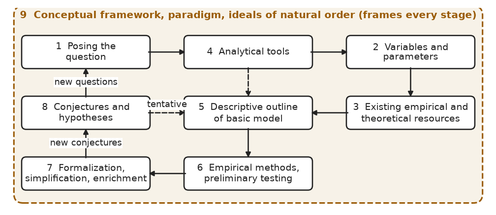

**Top-down and bottom-up.** Posing a question inside a paradigm and choosing which variables count is top-down. The framework decides what data are relevant, so the data are "theory-laden." Known results (stage 3) and preliminary tests (stage 6) bring in the bottom-up side: observations constrain the model. The model is built where the two directions meet.

**Induction, abduction and deduction.** Conjectures in stage 8 come from induction from data, or from abduction to the best explanation. In stages 5 to 7 the modeler reasons deductively, drawing out consequences and testing them. This is the hypothetico-deductive cycle of Discussion 9.1: data, hypothesis, deduction, test, revision.

**Analysis and synthesis.** Choosing variables and parameters is analysis: breaking the system into the parts that matter. The descriptive outline and its formalization are synthesis: putting those parts together as a working whole. In stage 7, simplification prunes the model and enrichment extends it.

**Structure and function.** The question fixes a function: what the model must do. A strategic model works upward from structure toward a theory, and a tactical model works downward from a theory to one case. The same nine stages serve both.

**The three principles.** *Non-contradiction*: a clash between prediction and test means that an assumption must be revised or its limits found. *Sufficient reason*: models explain deviations from an ideal of natural order, which stage 9 supplies. *Identity of indiscernibles*: choosing variables decides which differences make a difference; the billiard-ball gas model treats all molecules as identical points.

**The difference.** Discussion 9.1 describes general modes of reasoning. The modeling process is a procedure for building one artifact, and it adds what 9.1 lacks: attention to analytical tools, explicit simplification, and criteria for judging the result. It also warns against mistaking the map for the territory.

U11-SG10Study guide

Consider an example of a specific model used in science (a model with which you are familiar, or one of the models from your readings in this course).

a. Describe the uses of this model in advancing scientific understanding.

b. Describe potential or actual misapplications of this model.

Source Unit 11 Study Questions question 10

**Model: the Bohr model of the hydrogen atom** (Discussion 11.3). The atom is pictured as a tiny solar system: the proton is the "sun," the electron a "planet," and gravity is replaced by the inverse-square electric force. Bohr added an ad hoc rule: the electron can only have orbits whose angular momentum is L = nh/2π, and it radiates only when it jumps from one such orbit to another.

**a. Uses in advancing understanding**

1. **Quantitative prediction.** The model predicted the frequencies of light emitted by hydrogen, and they matched experiment. Unlike the vague Freudian steam-engine model, it could be quantified and so compared with measurements. It also helped settle a dispute: the plum-pudding model had been discredited by Rutherford's experiments, and Bohr's model succeeded where it had failed.

2. **A route to theory (a strategic model).** Its success motivated a search for a reason behind the angular-momentum rule. The reason came about a decade later with quantum mechanics: the Schrödinger equation gives angular momentum in whole-number multiples of h/2π. The model was a stepping stone from data to a new theory.

3. **Showing what was essential.** The model survived when circular orbits were replaced by elliptical ones, but any change to the angular-momentum rule destroyed its predictions. This showed that the rule carried the model's essential new information (Morris's criterion of robustness).

**b. Misapplications**

4. **Taking the orbits literally.** In quantum mechanics an electron does not have a definite position and momentum at the same time, so it does not follow a definite orbit. Picturing electrons as little planets circling the nucleus mistakes the map for the territory, even though the picture is still widely used.

5. **Stretching the model past its basis.** The model contradicts classical electromagnetism: an orbiting charge should radiate energy and spiral into the nucleus. Bohr simply imposed the quantum rule. Treating the model as a general theory of atoms, rather than a successful model of hydrogen, overextends it, much as some ecologists overextended the Lotka-Volterra model.

Note*Outside the readings: the Bohr model fails quantitatively for atoms with more than one electron, such as helium.*

U11-SG11Study guide

Choose one of the models described in Chapter 6 of *What Science Is*, and write a short essay discussing this model in terms of the process of model construction described at the end of Discussion 10.3.

Source Unit 11 Study Questions question 11

Note*The study question refers to "Discussion 10.3"; the model-construction process is at the end of Discussion 11.3.*

**Model chosen.** Maria Goeppert Mayer's nuclear shell model (Derry pp. 76-78) passes through almost every stage of the modeling process in Discussion 11.3.

**Stage 9: the framework.** In the 1930s and 1940s, physicists preferred the liquid drop model, in which protons and neutrons lose their individual identities. Electron shells exist because the nucleus is a single source of force, and no such single source was known inside a nucleus, so a shell model of the nucleus looked implausible. The prevailing framework shaped which ideas seemed worth trying.

**Stage 1: the question.** Mayer found a pattern in the data on the stability and abundance of isotopes. Nuclei with 2, 8, 20, 28, 50, 82 or 126 neutrons or protons are unusually stable. Why these "magic numbers"?

**Stage 3: resources.** Besides the data, there was an analogy. Atoms with certain numbers of electrons, the inert gases, are especially stable because their shells are closed.

**Stages 4 and 2: tools, variables and parameters.** The tools were the quantum mechanics of particles in a potential. The variables were the numbers of protons and neutrons and their energy levels. The nuclear forces were unknown, so she chose the simplest potential: a "square well," in which the particles move freely but cannot escape.

**Stages 8 and 5: conjecture and outline.** The conjecture was that protons and neutrons keep their identities and fill shells, and that the magic numbers mark closed shells. The descriptive outline was independent particles in a square well.

**Stage 6: preliminary test.** The model predicted 2, 8 and 20 but failed above 20. It was on the right track, but something important was missing.

**Stage 7: enrichment.** Several modifications failed. Then Mayer added a spin-orbit term: protons and neutrons behave somewhat like small compass needles, with energies that depend on their orientation. This effect was well known for electrons in atoms, but it is small there, so nobody had thought of including it for the nucleus. In the nucleus it is large. With it, the model predicted all of the magic numbers. The model stayed simple: it kept only the essential features, the well and the spin-orbit term.

**Back to stages 8 and 9.** Shell models became an accepted part of nuclear physics in 1949. Later, more refined models kept the shell structure as their framework, and Mayer shared the Nobel Prize. The framework itself had changed: particles in a nucleus could keep their individual identities.

**Evaluation.** The model scores well on Morris's criteria. It is accurate (all the magic numbers), related to known theory (atomic shells), transparent, fertile, and easy to enrich into later models. It shows that the process is a cycle, not a straight line, and that a crude but basically correct model can be decisive.

### Learning objective questions12

U11-OBJ01Objective

define “symmetry,” and explain the difference between internal, external and dynamic symmetries.

Source Unit 11 Overview objective 1

1. **Definition.** A symmetry is invariance under a transformation: if you do something to an object (move it, turn it, flip it) and it still looks the same, it has a symmetry (Discussion 11.1; Derry p. 252). The kind of transformation defines the kind of symmetry: geometric, temporal, permutation, colour or dynamic. Group theory is the mathematical language for all of them.

2. **External symmetries.** These belong to space itself, not to the object. In Euclidean space, an object's geometric properties do not change when it is moved (translation), turned through any angle (rotation), mirrored (reflection) or magnified or shrunk (dilation). Equivalently, a coordinate system may put its origin anywhere, point its axes in any direction, and use any scale.

3. **Internal symmetries.** These belong to the object and define its kind. A square is unchanged by rotations of 90°, 180°, 270° and 360° about its centre, and by reflections in its two diagonals and in the two lines through its centre parallel to its sides. A closed figure made of four straight segments is a square if and only if it has these symmetries. Classification uses internal symmetries, because an object's category should not depend on where it happens to be.

4. **Dynamic symmetries.** These show up not in a system's structure but in its motion, as an invariance of its equations of motion. Newton's F = ma keeps its form when we switch to a coordinate system moving at constant velocity (y = x - vt), because the second time derivative of vt is zero. Dynamic symmetries are only usable in sciences developed enough to write equations of motion.

5. **Why dynamic symmetry matters.** Emmy Noether proved that each dynamic symmetry corresponds to a conserved quantity. Symmetry under translation in space gives conservation of momentum, symmetry under rotation gives conservation of angular momentum, and symmetry under displacement in time gives conservation of energy (Discussion 11.1; Derry p. 271).

U11-OBJ02Objective

explain the difference between natural and artificial classifications.

Source Unit 11 Overview objective 2

1. **Natural classification.** The names of its categories are meant to indicate something that really exists in the world: the categories "carve nature at the joints." Biological species and the families of the periodic table are examples (Discussion 11.2).

2. **Artificial classification.** Categories are set up by a rule for convenient reference, and they become useful only with an index. A library classification and the archaeologists' pottery type "Tsegi polychrome" are examples. To the maker of a Tsegi polychrome bowl it was simply a kitchen utensil for mixing cornmeal mush.

3. **Purpose decides.** Every classification is made for a purpose. How hard we try for a natural classification depends on that purpose. The biological classification of species and a library catalogue serve different purposes. If a classification is only artificial, arbitrary labels or numbers are enough; if it is meant to be natural, the type names matter.

4. **Two poles.** Discussion 11.2 links natural types with bottom-up work, induction or abduction, discovery, intuition and essence. It links artificial types with top-down work, deduction, invention, rational construction and instrumental purposes. We discover natural types by recognizing their essential features, and we invent artificial types for a use.

5. **Most schemes are both.** Real classifications mix natural and artificial aspects. The best case is a theory whose "artificial," deduced typology matches and extends a "natural," inductively found one. Ne'eman and Gell-Mann showed that symmetry principles generate the observed families of elementary particles, and their typology predicted new particles.

U11-OBJ03Objective

describe the role of top-down and bottom-up approaches in the construction of classification schemes, and construct classifications of simple collections of objects.

Source Unit 11 Overview objective 3

1. **Bottom-up.** Start with a collection of samples. Ask which differences are significant and which can be ignored, and group the samples into classes by their similarities. This can suggest inductive or abductive principles of organization. The symmetries of one object suggest the class of all objects with those symmetries (Discussions 11.1 and 11.2).

2. **Top-down.** Start from requirements given by theory or function, and look for, or deduce, the objects that meet them. A fair die must have congruent regular faces, so it must be one of the five Platonic solids. In particle physics, symmetry principles told experimenters which new particles to look for.

3. **The cycle.** Building a classification uses both directions in turn: induce principles from the collection, impose them on the collection and on new objects, then revise. In a taxonomy, bottom-up work groups types into higher-level types, and top-down work splits a type into subtypes.

4. **A simple classification (top-down, by symmetry).** Purpose: sort the capital letters A, B, F, H, N, S, drawn in plain block style, by their symmetries. The types are: mirror line vertical only; mirror line horizontal only; both mirror lines; half-turn only; no symmetry.

| **Type** | **Symmetry of the letter** | **Letters** |
| --- | --- | --- |
| 1 | vertical mirror line only | A |
| 2 | horizontal mirror line only | B |
| 3 | both mirror lines (and so also a half turn) | H |
| 4 | half turn only | N, S |
| 5 | none | F |

5. **Testing it.** Every letter fits exactly one type. A letter with both mirror lines automatically has the half-turn symmetry, and a letter with one mirror line and a half turn automatically has the other mirror line, so the five types cannot overlap. A bottom-up approach would instead start from the letters, notice shared visual features, and refine the groups. Either way, the result has to be checked against new cases: in some fonts a letter's symmetry changes.

U11-OBJ04Objective

describe the three aspects of the type concept, and explain the difference between a typology and a taxonomy.

Source Unit 11 Overview objective 4

1. **First aspect: the material or sensory basis.** These are the actual exemplars and the characteristics we perceive in them: the particular bowls an archaeologist has in the tray (Discussion 11.2).

2. **Second aspect: the abstract concept.** This is the general idea of the category to which an object is assigned: the concept "Tsegi polychrome" or the concept "tree." How the mind grasps such a concept from finitely many examples is a deep question. It is something people do easily, and computer-generated statistical types are often bizarre unless watched over by someone who knows the material.

3. **Third aspect: the linguistic label.** This is the name of the category. A good name indicates the type's relevance within the purpose of the typology, and it influences which entities are later placed in the type. Every classification also has a goal, a teleological element: categories are always defined for some reason.

4. **Typology.** A typology is a classification made for sorting: it divides everything within its boundaries into non-overlapping types. It needs clear boundaries, completeness and mutually exclusive types, and its types are treated as equivalent, equidistant and independent. An example is the "North Western Arizona American Indian Pottery" typology.

5. **Taxonomy.** A taxonomy is a hierarchically ordered classification in which every level is a typology. It is needed because types are not really equidistant or independent: cats are closer to lynxes than to iguanas. The types at one level are treated as individuals and grouped into higher-level types (bottom-up), or split into subtypes (top-down), as in species, genus and family.

U11-OBJ05Objective

identify the conditions that must be satisfied by typological variables and describe the four different scales on which these variables may be evaluated.

Source Unit 11 Overview objective 5

1. **Relevance.** Each variable must be relevant to the typology's purpose: a dimension on which a difference makes a difference. Colour is irrelevant for telling cats from dogs, but it is essential for telling red giants, white dwarfs and blue giants apart (Discussion 11.2).

2. **Universality.** Each variable must be relevant to every type. Even the absence of an attribute is significant: fish lack the variable "legs," and that matters in biological classification.

3. **Qualitative difference.** Different variables must be qualitatively distinct dimensions of variation.

4. **Logical independence.** Variables must be choosable independently, even if they happen to be correlated. The x and y coordinates are logically independent even when a function y = f(x) relates them.

5. **The four scales for a variable's attributes.** *Nominal*: qualitative differences only, such as colours. *Ordinal*: a rank order, as when lining people up by height. *Interval*: a uniform number scale with a defined interval, such as degrees Celsius. *Ratio*: a uniform scale defined by a standard unit, such as the kilogram. The chosen variables and scales make up the parameter space in which the types appear as clusters.

Note*Outside the course: in standard measurement theory, an interval scale has an arbitrary zero, so differences are meaningful but ratios are not (20 °C is not "twice as hot" as 10 °C). A ratio scale has a true zero, so ratios are meaningful (4 kg is twice 2 kg).*

U11-OBJ06Objective

describe the method of comparison and discuss its use in science.

Source Unit 11 Overview objective 6

1. **What it is.** The method of comparison studies the similarities and differences between entities thought to be related. We use it every day, for example when we compare five or six cars on price, performance, style, reliability and options (Discussion 11.2).

2. **Its conditions.** There must be a goal (a reason for comparing), tools suited to the goal, and dimensions of comparison that are both relevant and measurable with those tools. If the tools are missing, we must change the goal, find new dimensions, or invent new tools. This is one place where creativity enters experimental work.

3. **Its uses in science.** Its main uses are classification, historical reconstruction, the search for generalizations, and hypothesis testing. Scientists also compare equipment and methods, competing hypotheses, sets of data, and rival theories. Its largest use is in classification.

4. **Comparing deviant and normal states.** Science explains deviations from an ideal of natural order, so comparing deviations with the normal state can suggest causes. Newton's force law explained deviations from uniform motion in falling apples, cannon balls and planetary orbits. In lesion studies, rats are tested, a different brain region is removed from each group, and their performance before and after is compared. Similar studies of stroke patients helped map the human brain.

5. **A caution.** Interpreting comparisons can be hard. A rat trained to press a bar when a bell rings stops pressing if it can no longer hear the bell, but the hearing area of the brain does not control bar-pressing. A difference between groups shows that something matters, not exactly how it matters.

U11-OBJ07Objective

explain how phylogenetic taxonomies are constructed, and how they can be used to estimate evolution times.

Source Unit 11 Overview objective 7

1. **Phylogenetic classification.** Phylogenetic classification is a family tree: the members of a type are assumed to descend from an earlier type, and similarity is read as common descent. Because it records relationships, it is a hierarchical taxonomy, not a flat typology (Discussion 11.2).

2. **Construction.** Describe each type by its attributes, such as binary characteristics or words. Then, under stated rules about how change happens (for example, one new characteristic per step with no reversals), link each type to its possible parents. Similar types are grouped bottom-up under a common ancestor, or a type is split top-down into lines of descent. Where the data allow more than one parent, the link is marked with "?" rather than invented (SG06).

3. **Estimating times.** If we can count the differences that have built up between two related types, and we know the average rate at which differences build up, then elapsed time = differences ÷ rate. In the course's language example, 10 mutations at one every 75 years give about 750 years since the tribes separated.

4. **Real uses.** Comparisons of mitochondrial DNA among living humans have been used to estimate that all people share a female ancestor who lived in Africa about 200,000 years ago. The same method estimates when proto-Indo-European was last spoken (the course says 6,000 to 8,000 years ago). Phylogenetic methods are used in evolutionary biology, demography, epidemiology and linguistics.

5. **Limits.** Real cases need many characters, different probabilities for different changes, allowance for repeated changes and reversals, and borrowing between lineages. They also need the means and variances of the resulting distributions. The convention for the rate (per lineage or for the pair) must also be stated, because it changes the answer by a factor of 2 (A12).

Note*The course places the mitochondrial ancestor in northern Africa and proto-Indo-European in Central Asia. Outside the readings, most genetic studies place this ancestor in sub-Saharan Africa, and most linguists place the Indo-European homeland in the steppes north of the Black and Caspian Seas.*

U11-OBJ08Objective

discuss the value of models in science and describe some of the dangers to be avoided when using models.

Source Unit 11 Overview objective 8

**Value.** Discussion 11.3 says modeling can:

1. **Suggest principles and directions.** It can suggest general principles and new directions for empirical research. Robert May's ecological models aim to be "mathematical metaphors" that suggest experiments and sharpen discussion.

2. **Organize and extend data.** It can reach conclusions that observation alone cannot, highlight relationships in large quantities of data, and provide an overview for organizing and interpreting data. A good model strips away detail to expose the central issue: the billiard-ball model explains gas pressure while ignoring chemistry (Derry pp. 69-70).

**Dangers**

3. **Mistaking the map for the territory.** People can come to focus on the model instead of the reality it represents: "the map is not the territory" (Korzybski), and "the menu is not the meal" (Watts).

4. **Abstract arguments cut off from the real questions.** Some ecologists over-extended the Lotka-Volterra model and deduced that certain ecosystems must contain an even number of species. This led to much speculation about why nature would arrange things that way.

5. **The bed of Procrustes, and false confidence.** A model can force data into an inappropriate form and hide data of significance. A model with many adjustable parameters can fit limited data while being wrong in concept, as Ptolemy's epicycles did (Derry p. 86). The remedy is a detached, critical attitude toward one's own models.

U11-OBJ09Objective

describe the different types of models that can be used in science.

Source Unit 11 Overview objective 9

1. **Mechanical or theoretical.** A mechanical model is a physical object, such as a scale model of a new aircraft tested in a wind tunnel. A theoretical model is a construct of ideas, such as Freud's model of the mind as a steam engine (Discussion 11.3).

2. **Mathematical or not.** Mathematical models allow precise numerical computation. The course's three examples range from barely mathematical to fully mathematical. The Freudian "PV = kT" model captures only vague relationships. The Bohr model can be quantified and compared with experiment. The Schrödinger equation for hydrogen is mathematical "through and through."

3. **Strategic, tactical or simulation.** A strategic model is built to find a theory (the Bohr atom). A tactical model is deduced from a theory as an exemplar (the Schrödinger equation for hydrogen). A simulation model, which can be used either way, imitates a system on a computer when experiments are impossible, as in weather forecasting.

4. **For understanding or for answers (Derry, Chapter 6).** Some models seek insight into how a system works: the ideal gas, the nuclear shell model, the successive models of heredity. Others answer limited practical questions without explaining mechanisms: the traffic-light model and the drug-uptake model.

5. **Models built on analogies.** Many models start from an analogy: the solar-system atom, the steam-engine mind, the "tree of life" in biology. An analogy suggests what to include, but in science it has to be made precise. Bohr had to change his analogy because, unlike a planet, an accelerating charge radiates.

U11-OBJ10Objective

define “strategic” and “tactical” models and describe the role of each.

Source Unit 11 Overview objective 10

1. **Strategic model: definition.** A strategic model is used in an attempt to discover a theory. It is built bottom-up, often to fit experimental results, in the hope that a theory can be abduced from it or suggested by thinking about it (Discussion 11.3).

2. **Strategic model: example and role.** The Bohr atom was fitted to the hydrogen spectrum with an ad hoc angular-momentum rule. Its success sent physicists looking for the reason behind the rule, and quantum mechanics supplied it. Strategic models matter most where no developed theory exists yet.

3. **Tactical model: definition.** A tactical model is deduced from an existing theory and applied to a specific situation. It works top-down, and it serves as an exemplar of how the theory is applied.

4. **Tactical model: example and role.** The Schrödinger equation for the hydrogen atom is a tactical model of quantum mechanics. Tactical models make the predictions that test a theory, and they show students and researchers how the paradigm is used. A paradigm can be seen as a set of canonical models together with the theory that justifies them.

5. **How they fit together.** Together they form the bottom-up/top-down cycle. Strategic models lead to a theory; the theory yields tactical models; misfits send us back to revise models or theory. A simulation model can play either role, and the same nine stages of model construction apply to both kinds.

U11-OBJ11Objective

describe the relation between theories, models, hypotheses, experiments and data.

Source Unit 11 Overview objective 11

1. **Framework and paradigm.** All scientific work is done within a conceptual framework of basic, often metaphysical, assumptions, including ideals of natural order. The framework shapes the paradigm, which gives it back an image of nature (Discussion 11.3, Figure 11.3.1).

2. **What the paradigm controls.** The paradigm decides which theories are considered (unification), what counts as a valid experiment (empirical criteria), which data are relevant, and which models are exemplars.

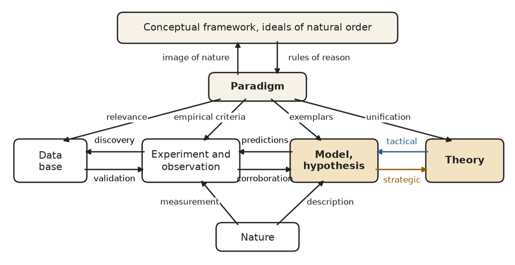

3. **Theories and models.** Applying a theory to a specific situation yields tactical models, which describe the world and serve as exemplars. Where no developed theory exists, strategic models are fitted to experimental results in the hope of reaching a theory. The line between theory and model is not sharp: the same formal system may be called a theory by some scientists and a model by others.

4. **Hypotheses, experiments and data.** Models and hypotheses make predictions. Experiments and observations test them by measuring nature, and they either corroborate the model or fail to. After analysis, the results enter the database. Data then validate new experiments and lead to discoveries, and the data are interpreted within the paradigm, so they are theory-laden.

5. **When they disagree.** If a model and the data do not fit, scientists reinterpret the data, change the model, or modify the theory. Only in extreme cases does the paradigm itself change. Bohr's model was accepted although classical electromagnetism said it could not be stable, and physicists concluded that classical electromagnetism does not apply inside atoms.

U11-OBJ12Objective

state and describe six criteria for the evaluation of models.

Source Unit 11 Overview objective 12

Morris's six criteria for evaluating models (Discussion 11.3), illustrated with the Bohr model:

1. **Accuracy.** How closely does the model fit the empirical data? The Bohr model predicted the frequencies of hydrogen's spectrum.

2. **Relatedness.** How closely is it connected to known theories and results? Bohr's model was built from Newtonian mechanics and a modified electromagnetism, and it drew on Planck's and Einstein's use of the constant h.

3. **Transparency.** Is it easy to understand, and does it appeal to intuition? A tiny solar system is very easy to picture.

4. **Robustness.** How sensitive is the model to changes in its basic assumptions? We need to know which assumptions are essential and which can be changed. Bohr's model survived the change from circular to elliptical orbits, but any change to its angular-momentum rule destroyed its predictions, so that rule carried its essential information. A model with no essential assumptions guides intuition but tells us little.

5. **Fertility and ease of enrichment.** *Fertility*: can a rich variety of consequences be deduced from it? Bohr's model led to a search that ended in quantum mechanics. *Ease of enrichment*: can it be developed into more comprehensive models, or has it reached its limits? The Bohr model was extended (elliptical orbits) but was finally replaced, not enriched.

### Lists and concept recall8

U11-R01Recall

Explain this topic from the assigned readings: symmetry and distinction, and the identity of indiscernibles that links them. Give an example or explain its significance in this unit.

Source Symmetry and distinction (Discussion 11.1)

1. **Symmetry.** "The general idea of symmetry relates to invariance under a transformation" (Discussion 11.1): something is symmetric if it is unchanged by some operation (move it, spin it, flip it). The word comes from the proto-Indo-European root *me*, "to measure", so symmetry is a "likeness of measure"; *similar* comes from *sem* (one, same). Two things are similar if they are in some way the same and come under a single name (Discussion 11.1).

2. **Distinction.** "To distinguish" comes from the root *steig*, meaning "to stick, pointed, to pierce": distinct things are indicated by pointing (Discussion 11.1). G. Spencer-Brown's formulation is "Distinction is perfect continence": a distinction is drawn by a boundary with separate sides, so that a point on one side cannot reach the other side without crossing it, as a circle does in a plane. There is no distinction without motive, and a name can be taken to indicate the value of a content (Discussion 11.1).

3. **Complementary ideas.** In appearance they are opposites: things that are alike cannot be distinguished, and any distinction must rest on some way the things differ, hence lack symmetry. But "Every distinction involves the breaking of some symmetry and the highlighting of those symmetries that remain", so every scientific classification is based on both the symmetries of the objects and the distinctions between them (Discussion 11.1).

4. **Generic names.** Why may uniquely individual cats such as Fritz and Felix be called by the generic name "cat"? By ignoring some differences as irrelevant we notice shared characteristics, and assign an identity to the class by the principle of the **identity of indiscernibles** (Discussion 11.1). We want the most informative distinctions, the "differences that make a difference"; Bateson: "Information consists of differences that make a difference." Tabby versus black makes no difference to cathood (though it matters at a cat show), but lone hunting of birds and mice versus pack hunting of deer (Rover the dog) does make a scientific difference (Discussion 11.1).

5. **Weyl's rule.** According to the mathematician Hermann Weyl, "the way to begin studying a structure is to determine the transformations that leave it invariant", that is, its symmetries (Discussion 11.1). Distinguishing a disk against a uniform background breaks the background's homogeneity and highlights the disk's circular symmetries, which can then group all other disk-like things into an equivalence class. The same holds for qualities: red versus not-red breaks a colour symmetry; six-legged, eight-legged and many-legged bugs break the symmetry of "has legs".

6. **Top-down and bottom-up use.** Top-down: impose symmetry requirements from theory or function and look for objects that satisfy them. Martin Gardner pointed out that a fair, simple die must be a regular polyhedron, and only five exist (the Platonic solids), so any fair die anywhere must have one of those shapes; particle physicists predict new particles from symmetry conditions, and Feynman describes working with an approximate symmetry as if it were perfect. Bottom-up: group distinct objects into equivalence classes by shared similarities (symmetries), deciding which differences can be ignored, then name the classes; the class name carries the symmetries used to define it (Discussion 11.1).

7. **Example.** A baseball is the same ball wherever it is (symmetric under spatial translation), but when pitched it is a "ball" or a "strike" depending on its position relative to home plate: the distinction is defined by breaking translation symmetry (Discussion 11.1). In biology, species are defined by invariance of form under reproduction, and each column of the periodic table holds elements whose chemical properties are preserved as atomic weight increases.

8. **Significance.** Classification in science always groups objects by features preserved under some set of transformations, so symmetry and distinction are the starting point for the unit's treatment of classification, typologies and taxonomies (Discussion 11.1).

U11-R02Recall

Explain this topic from the assigned readings: the kinds of symmetry, from external and internal symmetry to dynamic symmetry. Give an example or explain its significance in this unit.

Source Kinds of symmetry (Discussion 11.1; Derry ch. 18)

1. **The kind of transformation sets the kind of symmetry.** "Symmetry is defined in terms of invariance under transformations. The kind of transformation determines the kind of symmetry" (Discussion 11.1). There are geometric, algebraic, permutation, topological, dynamical and colour transformations, and even metaphorical ones such as those in an analogy; the mathematical language for many of them is group theory.

[output not shown]

2. **Which symmetries classify.** For classification it is the **internal** symmetries that matter, because we do not want an object's category to depend on its location in space (Discussion 11.1).

3. **Symmetry versus information.** Table 11.1.1 describes a square ever more abstractly: S1 (definite size, orientation and centre location), S2 (size and orientation), S3 (size), S4 ("squareness"). Each step adds symmetries (any translation of the centre, then all rotations, then any magnification). "As the level of description becomes more abstract, the symmetry increases": the set of things indicated grows, but the information conveyed falls, because fewer distinctions have been made (Discussion 11.1).

4. **Dynamic symmetry worked through.** In one dimension F = m x'', where x'' is the second time derivative of position. In a frame moving at constant velocity v, y = x - vt, so x = y + vt and x'' = y'' + (vt)'' = y'', because the second derivative of vt is 0. Hence F = m y'': the equation has the same form in both frames (Discussion 11.1).

5. **Noether's theorem.** Emmy Noether proved that every dynamic symmetry of a system corresponds to a conserved quantity: translation symmetry gives conservation of momentum, rotational symmetry angular momentum, and time-displacement symmetry energy (Discussion 11.1). Derry dates this to 1918 and adds that electric charge and other abstract quantities are conserved because of abstract symmetries (Derry, p. 271).

6. **Example.** The four seasons are a classification of the year produced by the temporal (periodic) symmetry of the solar year, and a space-probe image is unchanged by any permutation of pixels of the same colour (Discussion 11.1).

7. **Significance.** Naming the transformation tells a scientist exactly which features a category preserves, and dynamic symmetries tie classification to the deepest laws of physics through conservation laws (Discussion 11.1; Derry ch. 18). A related idea is analogy, which presents similarities between two things as grounds for conclusions about one of them (Discussion 11.1).

U11-R03Recall

Explain this topic from the assigned readings: the essentials of Derry's Chapter 18 on symmetry in science, art and mathematics: geometric symmetry, the Platonic solids, broken symmetry and the symmetry group. Give an example or explain its significance in this unit.

Source Derry ch. 18 essentials

1. **Geometric symmetry.** Derry's definition: "If you do something to a geometric figure (move it, spin it, flip it over, etc.), and it still looks the same, then we say that the figure has a symmetry" (Derry, p. 252). The three basic operations are **rotation** (n-fold rotational symmetry; the circle is the ultimate case), **reflection** (bilateral or mirror symmetry) and **translation** (moving every point the same distance in the same direction, repeated forever) (Derry, pp. 253-255).

2. **Three dimensions.** Rotation is about an axis; the sphere is symmetric for every axis through its centre. While there are infinitely many regular polygons, there are only **five regular polyhedra**, the Platonic solids (Derry, pp. 256-257):

| Platonic solid | Faces |
| --- | --- |
| Tetrahedron | 4 triangles |
| Cube | 6 squares |
| Octahedron | 8 triangles |
| Dodecahedron | 12 pentagons |
| Icosahedron | 20 triangles |

3. **Molecules and crystals.** Methane is tetrahedral; the iron in hemoglobin and the magnesium in chlorophyll sit in octahedral bonding sites; diamond, graphite and buckminsterfullerene are all pure carbon with different structures (Derry, pp. 258-259). The defining characteristic of **crystals** is translational symmetry, which allows only 2-, 3-, 4- and 6-fold rotations (no crystal has pentagonal symmetry). There are 32 symmetry classes, grouped into 6 crystal systems, 14 lattices (Derry spells them "Brevais", usually Bravais) and 230 possible space groups (Derry, pp. 261-262, 266). **Quasicrystals** have 5-fold rotational symmetry and almost, but not quite, long-range order (Derry, p. 261).

4. **Broken symmetry.** A broken symmetry is the introduction of a lower-symmetry element into a high-symmetry figure: a sphere with a hole drilled in it keeps only circular symmetry; a line of ants meeting a barrier mostly goes one way round; a missing atom (a defect) or the crystal's surface breaks its translational symmetry, though approximate symmetry remains for most properties (Derry, pp. 264-265).

5. **Group.** A **group** is a collection of transformations that includes the identity (no change), has an inverse for every member, and is closed: combining any two gives another member (Derry, pp. 265-266). The equilateral triangle has 6 symmetry operations (three rotations, one of them the identity, and three reflections), its symmetry group; the icosahedron's group has 120 transformations, and Euclidean space is characterized by its group of rotations, reflections and translations (Derry, p. 266).

6. **Handedness in biology.** Pasteur made tartaric acid for the first time in 1848 and obtained equal amounts of right- and left-handed forms, yet living organisms almost always produce only one form; our bodies contain only right-handed glucose but left-handed fructose, and almost all species of snail have right-handed shells, for no known reason (Derry, p. 268). Animal bilateral symmetry is only approximate (the heart is on the left), and DNA's lack of translational symmetry is what lets it encode information (Derry, pp. 266-267).

7. **Deep applications.** Maxwell made the equations of electricity and magnetism symmetric and predicted waves travelling at the known speed of light, so light is an electromagnetic wave and optics and electromagnetism are unified; Einstein's relativity removed an asymmetry between observers in relative motion; electroweak unification showed the electromagnetic and weak interactions to be one interaction that appears as two after a spontaneous symmetry breaking; Noether (1918) showed every conservation law comes from a symmetry (Derry, pp. 270-271). Permutation symmetry of identical particles gives the Pauli exclusion principle, which explains the periodic table, and in 1832 Galois, who invented the group concept, coined the term "group" for the permutations of the solutions of polynomial equations (Derry, pp. 271-272).

8. **Example.** Ornamental art: the Moorish artisans of the Alhambra exploited every available symmetry (17 symmetry groups are possible in two dimensions), and balancing a car tire restores its circular rotational symmetry about the axle (Derry, pp. 264, 269).

9. **Significance.** Derry shows symmetry as a unifying principle across science, art and mathematics, and the group concept gives the precise language for the invariances Discussion 11.1 uses to classify (Derry ch. 18).

U11-R04Recall

Explain this topic from the assigned readings: the basics of comparison and classification: the method of comparison and the science of systematics. Give an example or explain its significance in this unit.

Source Comparison and classification basics (Discussion 11.2)

1. **Method of comparison.** It involves comparing similarities and differences between entities thought to be related in some way, something we do every day, as when comparing five or six cars on price, performance, style, reliability and options (Discussion 11.2). In science we compare equipment or experimental methods, rival hypotheses, sets of data, or theories. Three conditions always apply: a **goal**, **tools** appropriate to the goal, and **dimensions of comparison** relevant to the goal and accessible with the tools; if the tools are lacking, change the goals, find new dimensions or invent new tools.

2. **Four primary reasons.** The comparative method is used for **classification**, **historical reconstruction**, **a search for generalizations** and **hypothesis testing** (Discussion 11.2). Often deviant states are compared with normal ones: Newton's force law explained deviations from uniform motion (falling apples, cannon projectiles, planetary orbits); selective lesioning of rat brains and studies of stroke and brain-injured patients mapped brain function. The major use, however, is classification.

3. **Systematics.** "Classification and measurement are the two basic requirements for doing science" (Discussion 11.2): we must "name all of the animals", grouping them first so that each group can be named. **Systematics** is the science of classification; its pedigree begins with Aristotle, but classification is as old as language (Sumerian teaching tablets list kinds of sheep under the word sheep).

4. **The threefold nature of types.** Identifying an object as a member of a category has three aspects: (1) the **material or sensory basis**, the actually perceived characteristics (the exemplars); (2) the **abstract concept** of the category; (3) the **linguistic label**, its name (Discussion 11.2). Every classification is also **teleological**: made for a purpose (a biological classification of species serves a different purpose than a library classification).

5. **Natural and artificial.** In a **natural classification** the category names indicate something that exists in the world; an **artificial classification** sets categories by a rule and is useful only with an index (Discussion 11.2). Most schemes mix both, and building one cycles between bottom-up grouping of samples into categories and top-down application of the resulting principles to new objects.

6. **Example.** The 1937 typology of North Western Arizona American Indian Pottery includes the type Tsegi polychrome, useful to archaeologists for tracing trade with the Tsegi Canyon culture; to its maker the bowl was a kitchen utensil for mixing cornmeal mush, and the maker's own name for it would be more natural (Discussion 11.2).

| Term | Meaning (Discussion 11.2) |
| --- | --- |
| **Classification** (noun) | a system of categories and labels built for some purpose; natural or artificial |
| **Typology** | a classification for **sorting** all entities into non-overlapping groups called **types** |
| **Taxonomy** | a hierarchically ordered classification in which **each level is a typology** |
| **To classify** | to distinguish categories: **definition** |
| **To sort** | to put things into categories already distinguished: **attribution** |

7. **Significance.** Science is impossible if we cannot agree on what we are talking about, so identifying the objects of study is the first step in any scientific endeavour; these distinctions let us say precisely what is indicated when a type is named (Discussion 11.2).

U11-R05Recall

Explain this topic from the assigned readings: the criteria for a typology, including its variables and the measurement scales of their attributes. Give an example or explain its significance in this unit.

Source Criteria for a typology (Discussion 11.2)

1. **Why a typology needs criteria.** A typology is a classification designed for sorting, so it must have properties other classification schemes do not need (Discussion 11.2).

[output not shown]

2. **Variables and attributes.** Variables are the dimensions on which entities may be distinguished and sorted, chosen as relevant to the typology's purpose. The attributes of a variable are its possible values, and each entity shows exactly one attribute (possibly "not present") on each variable: the variable "legs" can be none, two, four, six, eight or many (Discussion 11.2).

3. **Aristotelian logic.** A typology's structure follows Aristotle's laws: identity (if X is identified as Type A, X is an A: Felix is a cat); contradiction (exclusive types: X cannot be A and not-A, so it cannot be Type B); excluded middle (completeness: X must fall into one of the types) (Discussion 11.2).

4. **Example.** Equidistance and independence are questionable: cats are not equally distant from lynxes and from iguanas, and a parasite species is unlikely to be found where its host is absent (Discussion 11.2). Taking such relationships into account requires a higher level of discourse, a **taxonomy**, in which types are grouped into higher-level types until a single top type is reached or the data run out (Figure 11.2.1).

5. **Significance.** The criteria make sorting unambiguous and repeatable, and the scale chosen for each attribute decides what comparisons and measurements are meaningful (Discussion 11.2).

U11-R06Recall

Explain this topic from the assigned readings: building and naming types: types as clusters in a parameter space, the empirical type and the ideal type. Give an example or explain its significance in this unit.

Source Building and naming types (Discussion 11.2)

1. **Building a typology.** (1) Set the **boundaries**: what is to be classified (arrowheads, pottery, chemical elements, stars). (2) Choose the significant **variables**, "the dimensions on which a difference makes a difference" (colour matters for types of star, not for telling cats from dogs), and set their **attributes** on a scale. (3) Plot the entities as points in the resulting **parameter space**; with well-chosen variables they fall into clusters, one per type; if not, new variables may be needed (Figure 11.2.2 shows two clusters merging into one when a dimension is omitted). (4) **Name** the types. (5) Look for regularities between the types, which may redefine the typology from theory (Discussion 11.2).

2. **Naming.** For an artificial typology arbitrary labels or numbers suffice; for a natural one the name matters, because it influences what is later classified under it. Ideally a type name indicates the type's relevance or function, so the full set of names becomes a linguistic map of the parameter space (Discussion 11.2).

3. **Identity and meaning.** Types have two basic properties: **identity**, their location as a region of parameter space (their attributes), and **meaning**, the variables that define the space, the information gained from knowing an entity's type, and how the type concept fits our other concepts (Discussion 11.2).

4. **Empirical and ideal types.** An **empirical type** is determined from observation and comparison (dog breeds from pedigrees); an **ideal type** is posited for theoretical purposes (a dog-show judge rates each dog against the ideal of its breed). Ideal types are sometimes polar opposites, absolute (positive and negative charge) or the ends of a spectrum (red and violet), with actual cases in between (Discussion 11.2).

| Greek cross (Table 11.2.1) | Wet | Dry |
| --- | --- | --- |
| **Hot** | Air | Fire |
| **Cold** | Water | Earth |

5. **Polar types in use.** Things were classed as relatively fiery, airy, watery or earthy; in a modern version, Carl Jung's polar types underlie the Myers-Briggs inventory, which sorts people into 16 categories from their scores on four dimensions (Discussion 11.2).

6. **Three ways of defining types.** **Aristotelian**: a few variables thought essential, each possessed by every member (but what is essential to a cat versus a lynx?); **statistical**: many relevant variables, none essential, grouped by statistical similarity on large computers; **phylogenetic**: a family tree of descent from an earlier type (Discussion 11.2).

7. **Polarities.** Table 11.2.2 pairs bottom-up, induction/abduction, discovery, natural, intuitive and essential against top-down, deduction, invention, artificial, rational and instrumental: we discover natural types intuitively and invent artificial ones rationally, and real typologies use both (Discussion 11.2).

8. **Example.** Early particle physics had a phenomenological typology of elementary particles; Yuval Ne'eman and Murray Gell-Mann independently found that it could be generated from symmetry principles and used to predict new particles (Discussion 11.2).

9. **Significance.** A sign of a good theory is that it predicts an artificial typology that matches and extends an inductively generated natural one, and research on base-level types shows the mind classifies at the most inclusive level that still fits perceived attributes (Discussion 11.2).

U11-R07Recall

Explain this topic from the assigned readings: the phylogenetic taxonomy and estimating evolution times from it, by diachronic or synchronic reconstruction. Give an example or explain its significance in this unit.

Source Phylogenetic taxonomies and evolution times (Discussion 11.2)

1. **Phylogenetic taxonomy.** Phylogenetic classification is basically a family tree: similarity between types is treated as **descent from a common ancestor**, and the hierarchy is built bottom-up (grouping similar types into higher-level types) or top-down (making distinctions within a type to define lower-level types), as in Figure 11.2.3 (Discussion 11.2). It is used in evolutionary biology, demography, epidemiology and linguistics.

2. **Timelines.** If the **distance** between types with a common ancestor and the **rate of divergence** after separation can be estimated, a timeline follows: elapsed time = number of changes x average time per change (Discussion 11.2). Mitochondrial DNA differences put a common female ancestor of all living humans, a woman who lived in northern Africa about 200,000 years ago; proto-Indo-European was spoken in Central Asia until about 6000 to 8000 years ago (Figure 11.2.5).

3. **Worked example.** Two tribes on either side of a wide desert have eight four-digit words of 0s and 1s. A word mutates only by flipping one digit, a mutated word does not mutate again, and a mutation occurs on average every three generations, about 75 years (Discussion 11.2). The number of mutations in a pair is the number of digits that differ:

| Language 1 | Language 2 | Possible originals | Mutations |
| --- | --- | --- | --- |
| 0001 | 0101 | 0001 or 0101 | 1 |
| 0101 | 1100 | 0100 or 1101 | 2 |
| 1001 | 0011 | 0001 or 1011 | 2 |
| 0110 | 0110 | 0110 (no change) | 0 |
| 0111 | 1110 | 0110 or 1111 | 2 |
| 1011 | 0111 | 1111 or 0011 | 2 |
| 1101 | 1111 | 1101 or 1111 | 1 |
| 0111 | 0111 | 0111 (no change) | 0 |
| **Total** |  |  | **10** |

4. **Result.** 10 mutations x 75 years = about 750 years since the clan divided (Discussion 11.2). The course names a single original for the 2-mutation pairs, but each has two (for example 0101 and 1100 come from 0100 or from 1101); either way two mutations occurred, so the count of 10 stands. A real case would need many words, probabilities for many phonemes, back-mutations, borrowed or invented words, and means and variances of the distributions.

5. **Diachronic and synchronic.** A **diachronic** reconstruction is a historically generated family tree (the Indo-European languages); a **synchronic** one traces spatial spread over a short time, such as the chain of transmission of an epidemic, revealing its source, carriers and mode of transmission, as in Snow's study of cholera (Discussion 11.2).

6. **Significance.** Turning a typology into a phylogenetic taxonomy answers the equidistance problem (cats are closer to lynxes than to iguanas) and lets a classification date historical events that cannot be observed directly (Discussion 11.2).

U11-R08Recall

Explain this topic from the assigned readings: the scientific model: strategic and tactical models, the nine stages of model construction, and how models are evaluated and improved. Give an example or explain its significance in this unit.

Source Models (Discussion 11.3; Derry ch. 6)

1. **Definition.** A model is "a mechanical or theoretical construct designed to study a particular real world situation or phenomenon" (Discussion 11.3). For Derry, models are "imaginary simulations of the real natural systems we are trying to understand" that keep only the properties and relationships we need and leave out the rest: gas atoms as tiny billiard balls, or a street map (Derry, p. 69).

2. **Kinds.** Mechanical (a wind-tunnel aircraft) or theoretical (Freud's mind as a steam engine: id as fire, superego as boiler, ego as control; read through PV = kT it shows relationships but is too vague to quantify); mathematical or non-mathematical (Discussion 11.3). **Strategic** models are bottom-up, built to discover a theory (the Bohr atom); **tactical** models are top-down, deduced from a theory as exemplars (the Schrödinger equation for hydrogen). **Simulation** models, strategic or tactical, run on computers where experiment is impossible (North American weather), but a good match to known data does not validate their assumptions, which need other validation.

3. **Values and dangers.** Models can suggest general principles, indicate new directions for empirical research, suggest conclusions not reachable by observation alone, highlight relationships in large quantities of data, and give an overview for organizing and interpreting data (Discussion 11.3). Dangers: "mistaking the map for the territory"; abstract arguments unrelated to the field's significant questions (the Lotka-Volterra model over-extended to require an even number of species); and forcing data into an inappropriate form, the **bed of Procrustes**.

4. **Nine stages.** The modelling process runs through nine stages (Discussion 11.3):

| Stage | Name |
| --- | --- |
| 1 | Posing the question |
| 2 | Selecting variables and parameters |
| 3 | Existing empirical and theoretical resources |
| 4 | Analytical tools (conceptual, mathematical, etc.) |
| 5 | Descriptive outline of basic model |
| 6 | Empirical and observational methods, preliminary testing |
| 7 | Formalization, simplification, enrichment |
| 8 | Conjectures and hypotheses |
| 9 | Conceptual framework, paradigm, ideals of natural order |

5. **How the stages connect.** The move from 1 to 2 is mediated by 4; 3 brings in known results, and 4 and 8 resolve in 5; then 6 and 7; the enriched model returns to 8 and to 1, and results are assimilated into 9 unless the paradigm must change (Discussion 11.3). The cycle is the same for strategic and tactical models.

| Morris's criterion | Question |
| --- | --- |
| **Accuracy** | How closely does the model fit the empirical data? |
| **Relatedness** | How closely is it connected to known theories and results? |
| **Transparency** | Is it easy to understand and intuitive? |
| **Robustness** | How sensitive is it to changes in its basic assumptions? |
| **Fertility** | Can a rich variety of consequences be deduced from it? |
| **Ease of enrichment** | Can it lead to more comprehensive models? |

6. **Robustness example.** The Bohr model survived the change from circular to elliptical orbits, but any change to its angular momentum rule (L = nh/2π) destroyed its predictive power: that assumption held the model's essential new information (Discussion 11.3).

7. **Improving models.** Derry's systematic correction adds ever-smaller terms, like long division: 527/32 = 10 + 6 + 0.4 + 0.06 + 0.008 + ... = 16.46875; Saturn's orbit is computed from the sun, then corrected for Jupiter as a perturbation (Derry, pp. 83-84). Iteration reworks the model until input and output agree, "a condition known as self-consistency" (Derry, p. 85). Parameter fitting adjusts parameters to the data (a least-squares line for water use against population), but many adjustable parameters can fit a wrong model, as Ptolemy's epicycles did (Derry, pp. 85-86).

8. **Significance.** Models link theory to experiment and data within a paradigm (Figure 11.3.1), so a scientist must keep a detached, critical attitude toward them: "The map is not the territory" (Discussion 11.3).

### Key term questions18

U11-T01Term

Define or distinguish Symmetry. Give an example and explain its role in this unit.

1. **Definition.** A symmetry is invariance under a transformation. If an object or system is changed in some definite way and is still the same in the respects that matter, it has a symmetry (Discussion 11.1; Derry p. 252).

2. **Example.** A square has 8 symmetries: 4 rotations (90°, 180°, 270°, 360°) and 4 reflections. A biological species shows symmetry under reproduction: its form is preserved from one generation to the next.

3. **Role in this unit.** Symmetry is what makes things similar, and similarity is what lets us group them. Every classification groups things by features that stay invariant under some set of transformations.

4. **Distinction.** Symmetry is the complement of distinction. Symmetric things cannot be told apart, and a distinction is drawn wherever symmetry is broken. Internal symmetries belong to the object; external symmetries belong to space; dynamic symmetries belong to equations of motion.

5. **Significance.** Symmetry restricts possibilities: a fair die must be a Platonic solid. It also predicts new particles, and it gives conservation laws through Noether's theorem.

U11-T02Term

Define or distinguish Distinction. Give an example and explain its role in this unit.

1. **Definition.** A distinction is a boundary with separate sides, arranged so that a point on one side cannot reach the other side without crossing it: "distinction is perfect continence" (Spencer-Brown, Discussion 11.1).

2. **Example.** A circle drawn on a plane distinguishes inside from outside. Home plate distinguishes a "ball" from a "strike."

3. **Role in this unit.** Classification begins with distinctions. Once a distinction is drawn, each side can be indicated and named. There is no distinction without a motive: the contents of the two sides must differ in value.

4. **Distinction versus indication.** *Distinguishing* draws the boundary; *indicating* points to one side and names it. The verb "to distinguish" comes from a root meaning "to stick, pointed, to pierce," and distinct things are indicated by pointing. Every distinction breaks some symmetry and highlights the symmetries that remain.

5. **Significance.** Useful distinctions are "differences that make a difference," Bateson's definition of information. Which differences matter depends on the purpose: a cat's colour is irrelevant to biology but decisive at a cat show.

U11-T03Term

Define or distinguish Broken symmetry. Give an example and explain its role in this unit.

1. **Definition.** A broken symmetry is the introduction of a lower-symmetry element into a highly symmetric figure or system (Derry p. 264).

2. **Example.** Drilling a hole in a sphere destroys its spherical symmetry but leaves circular symmetry about the axis through the hole. A missing atom (a defect) breaks the translational symmetry of a crystal locally, while the rest of the crystal keeps approximate symmetry.

3. **Role in this unit.** Every distinction is a symmetry breaking: drawing a boundary on a uniform background breaks its homogeneity and highlights the symmetries of the enclosed shape (Discussion 11.1).

4. **Distinction.** Broken symmetry differs from approximate symmetry. A face is approximately symmetric everywhere; a broken symmetry has a definite lower-symmetry element. Breaking can also be spontaneous: ants meeting a barrier mostly go around one side, although the setup is symmetric.

5. **Significance.** Most of what is interesting comes from broken symmetry: the handedness of biological molecules, the development of an embryo from a nearly symmetric cell, artistic composition, and the splitting of a unified electroweak interaction into two forces (Derry pp. 267-271).

U11-T04Term

Define or distinguish Group. Give an example and explain its role in this unit.

1. **Definition.** A group is a collection of transformations that includes the identity (the "do nothing" transformation), contains the inverse of each of its transformations, and is closed: combining any two of them gives another one in the collection (Derry pp. 265-266).

2. **Example.** The symmetry group of an equilateral triangle has 6 transformations: rotations by one third, two thirds and a full turn (the identity), and reflections in its three lines of symmetry. A square's group has 8.

3. **Role in this unit.** Group theory is the mathematical language of symmetry. The symmetry of any shape is specified exactly by its group, which also covers non-geometric symmetries such as permutations (Discussion 11.1).

4. **Distinction.** A group is the whole closed set of symmetries, not a single symmetry operation. The permutations of three objects form the same group as the symmetries of the triangle, even though one is algebraic and the other geometric (Derry p. 271).

5. **Significance.** Groups restrict what is possible: a crystal must have one of 230 space groups. Galois invented the concept to study the solutions of polynomial equations, and groups now organize particle physics.

Note*Outside the readings: the standard definition of a group also requires associativity, which combining transformations satisfies automatically.*

U11-T05Term

Define or distinguish Analogy. Give an example and explain its role in this unit.

1. **Definition.** An analogy presents similarities between two distinct things as support for conclusions about one of them, drawn from what is known about the other. It is closely related to symmetry: a kind of metaphorical transformation that keeps some features invariant (Discussion 11.1).

2. **Example.** The Bohr atom treats the hydrogen atom as a miniature solar system. The "tree of life" pictures all living things as branches from one primitive organism.

3. **Role in this unit.** Many models begin as analogies (the solar-system atom, Freud's steam-engine mind), and the shell model of the nucleus began with an analogy to electron shells (Derry p. 77).

4. **Distinction.** An analogy asserts likeness in some respects, not identity. In science it must be precise about which respects. The solar-system analogy failed where electrons differ from planets: an accelerating charge radiates.

5. **Significance.** Analogies are powerful for discovery, but they must not be taken further than they hold. Treating a loose analogy as a law is a way of mistaking the map for the territory.

U11-T06Term

Define or distinguish Nominalism. Give an example and explain its role in this unit.

1. **Definition.** Nominalism is the philosophical position that no higher-level categories exist. Only individuals exist, and names like "cat" are merely linguistic conveniences (Discussion 11.1, footnote 212).

2. **Example.** For a nominalist, there are Fritz, Felix and many other individual animals, and "cat" is only a label we find handy for them.

3. **Role in this unit.** It sharpens the unit's question: what justifies grouping unique individuals under one generic name? The course answers with shared symmetries and the identity of indiscernibles: things that do not differ in the relevant respects may share a name.

4. **Distinction.** The opposing view holds that categories are real. Natural classifications aim at categories that exist in the world, and Aristotelian typologies assume real essences. An artificial classification is closest to the nominalist view: its labels are conveniences that work only with an index.

5. **Significance.** The question links to the problem of induction (generalizing from finitely many cases) and to how we recognize something we have never seen before, such as a tree, as a member of a familiar kind.

Note*Outside the readings: the opposing position is usually called realism about universals.*

U11-T07Term

Define or distinguish Systematics. Give an example and explain its role in this unit.

1. **Definition.** Systematics is the science of classification. It collects entities into categories, labels the categories, and searches for structural relations between them (Unit 11 Overview; Discussion 11.2).

2. **Example.** Biological systematics, which arranges species into higher groups, and the periodic table of elements. Teaching tablets from ancient Sumer list a general word such as "sheep" followed by categories of sheep.

3. **Role in this unit.** Identifying the objects of study is the first step in any science: "classification and measurement are the two basic requirements for doing science." Its intellectual pedigree begins with Aristotle.

4. **Distinction.** Systematics is the science. A classification is any system of categories and labels; a typology is a classification used for sorting; a taxonomy is a hierarchical classification. In everyday use these words are often interchanged.

5. **Significance.** "The fundamental problem of each science is the establishment of the identity of its phenomena" (Malinowski). We cannot discuss what we have no name for.

U11-T08Term

Define or distinguish Classify / sort. Give an example and explain its role in this unit.

1. **Definition.** To *classify* is to distinguish and define categories. To *sort* is to put things into categories that have already been distinguished (Discussion 11.2).

2. **Example.** Setting up the types of the Arizona pottery typology, and defining what "Tsegi polychrome" means, is classifying. Deciding that a newly excavated piece of pottery is Tsegi polychrome is sorting.

3. **Role in this unit.** A typology is a classification built for sorting, which is why it needs boundaries, completeness and exclusive types.

4. **Distinction.** Classification involves *definition*; sorting involves *attribution*. A classification can be good and the sorting still be wrong (a piece of pottery misidentified), or the sorting can be careful while the classification is poor (vague types).

5. **Significance.** Keeping the two apart tells us where an error lies: in the scheme or in its use. Sorting also tests a classification: objects that fit no type or several types show that the scheme needs revising.

U11-T09Term

Define or distinguish Typology / taxonomy. Give an example and explain its role in this unit.

1. **Definition.** A *typology* is a classification used for sorting all entities within its boundaries into non-overlapping types. A *taxonomy* is a hierarchically ordered classification in which each level is a typology (Discussion 11.2).

2. **Example.** A flat list of pottery types is a typology. The biological hierarchy of species, genus and family is a taxonomy.

3. **Role in this unit.** A typology must satisfy the structural criteria (boundaries, completeness, exclusive types) and the criteria of consistency, equivalence, equidistance and independence. A taxonomy is built when equidistance and independence fail.

4. **Distinction.** A typology treats all types as equally distinct. A taxonomy expresses closeness: cats and lynxes share a higher-level type that iguanas do not. A taxonomy is built bottom-up by grouping types into supra-types, or top-down by splitting types into subtypes.

5. **Significance.** The hierarchy carries information a typology cannot. In a phylogenetic taxonomy the hierarchy represents descent, which allows evolution times to be estimated.

U11-T10Term

Define or distinguish Variable / attribute / parameter space. Give an example and explain its role in this unit.

1. **Definition.** A *variable* is a dimension of variability on which entities can be distinguished. An *attribute* is one of the values a variable can take. A *parameter space* is the space whose dimensions are the chosen variables; each entity is a point in it (Discussion 11.2).

2. **Example.** For animals, the variable "legs" has the attributes none, two, four, six, eight or many.

3. **Role in this unit.** If the variables are well chosen, the points form clusters, and each cluster is a type. A type's identity is its region of parameter space, and its meaning comes from the variables that define the space.

4. **Distinction.** A variable is the dimension, and an attribute is a value on it. Each entity shows exactly one attribute per variable, including "not present." Variables must be relevant, universal, qualitatively different and logically independent.

5. **Significance.** The choice of variables decides what types can be seen. In Figure 11.2.2, two clusters merge into one when a dimension is left out. If no clear clusters appear, new variables may be needed.

U11-T11Term

Define or distinguish Empirical type / ideal type. Give an example and explain its role in this unit.

1. **Definition.** An *empirical type* is found by observation and comparison. An *ideal type* is posited for theoretical purposes, as a standard to compare cases against (Discussion 11.2).

2. **Example.** Classifying dogs into breeds by their pedigrees is empirical. A dog-show judge scores each dog by how closely it matches the ideal of its breed.

3. **Role in this unit.** Ideal types are often stated as polar opposites. The ancient Greeks crossed two polarities, hot/cold and wet/dry, into four elements: hot and wet = air, hot and dry = fire, cold and wet = water, cold and dry = earth.

4. **Distinction.** Polar ideal types can be absolute opposites, such as positive and negative charge, or the ends of a spectrum, such as red and violet light. With a spectrum, real cases fall somewhere between the poles.

5. **Significance.** Empirical types describe what has been found; ideal types organize thinking and measure how far real cases depart from a standard. A good theory can generate types that match the empirical ones.

U11-T12Term

Define or distinguish Base-level typology. Give an example and explain its role in this unit.

1. **Definition.** A base-level typology is the level of categories the mind uses most easily: the most inclusive level at which types still fit the structure of attributes we perceive in the world (Discussion 11.2, citing research by Rosch).

2. **Example.** Most people first see "a chair" or "a dog," rather than "furniture" or "an animal" (too general) or "a kitchen chair" or "a beagle" (too specific). Figure 11.2.4 illustrates the idea with fruit.

3. **Role in this unit.** Thought starts at the base level and moves from it as needed, abstracting higher-level types or making finer distinctions below it. This is the cognitive version of building a taxonomy bottom-up and top-down.

4. **Distinction.** The base level is defined by perception and ease of use, not by logic. A logically complete taxonomy has many levels; the base level is the one that is psychologically privileged.

5. **Significance.** It explains why some categories feel "natural," and why classification usually starts in the middle of a hierarchy and moves up and down from there.

Note*Outside the readings: the chair and dog examples are the standard ones from Eleanor Rosch's research on basic-level categories.*

U11-T13Term

Define or distinguish Diachronic / synchronic reconstruction. Give an example and explain its role in this unit.

1. **Definition.** A *diachronic* reconstruction traces a historically generated family tree through time. A *synchronic* reconstruction maps relationships across space over a short time (Discussion 11.2).

2. **Example.** The tree of the Indo-European languages descending from proto-Indo-European is diachronic. Reconstructing the spread of an epidemic, to find its source, its carriers and its mode of transmission, is synchronic; Snow's study of cholera was work of this kind.

3. **Role in this unit.** Both are uses of the method of comparison, and both are kinds of historical reconstruction.

4. **Distinction.** Diachronic work asks how types descended from ancestors over long periods. Synchronic work asks how cases are connected now, as a chain of transmission, not a family tree.

5. **Significance.** Diachronic reconstruction, together with rates of change, can estimate how long ago lineages separated. Synchronic reconstruction can identify the source of an outbreak, so that action can be taken while it is still under way.

U11-T14Term

Define or distinguish Model. Give an example and explain its role in this unit.

1. **Definition.** A model is a mechanical or theoretical construct designed to study a particular real-world situation or phenomenon (Discussion 11.3). Derry calls models imaginary simulations that include only the properties and relationships needed for the question at hand (p. 69).

2. **Example.** The billiard-ball (ideal gas) model of a gas explains pressure. A street map models the relative positions and intersections of streets, but not the people on the sidewalks (Derry pp. 69-70).

3. **Role in this unit.** Models are among the most useful tools of science. Once the basic elements of a system are classified, models are used to study how they interact.

4. **Distinction.** A model differs from a theory, although the line is not sharp: theories are general, and models apply them to particular situations or are built to find them. A model also differs from reality: "the map is not the territory."

5. **Significance.** A model's worth depends on its purpose. The billiard-ball model is good for gas pressure and poor for condensation (Derry p. 70). Models are judged by Morris's six criteria.

U11-T15Term

Define or distinguish Strategic / tactical / simulation model. Give an example and explain its role in this unit.

1. **Definitions.** A *strategic* model is used in an attempt to discover a theory (bottom-up). A *tactical* model is deduced from a theory as an exemplar (top-down). A *simulation* model reproduces a system's behaviour on a computer, and it can be used either way (Discussion 11.3).

2. **Examples.** The Bohr atom is strategic. The Schrödinger equation for the hydrogen atom is tactical. A computer model of North American weather, used to ask how a change in the jet stream would affect rainfall, is a simulation.

3. **Role in this unit.** Together they show the bottom-up/top-down cycle at work in modeling.

4. **Distinction.** Strategic and tactical models differ in the direction of reasoning. Simulations are especially useful when experiments are impossible, but output that looks like known data does not prove the simulation's assumptions are right; those need other sources of validation.

5. **Significance.** Knowing which kind of model one has tells us what its success means. A strategic model's success suggests a theory worth seeking; a tactical model's success supports the theory it came from; a simulation's success is only as good as its validation.

U11-T16Term

Define or distinguish Bed of Procrustes. Give an example and explain its role in this unit.

1. **Definition.** The bed of Procrustes is the danger of forcing data into an inappropriate form to fit a model, and so hiding data of significance (Discussion 11.3).

2. **Example.** Suppose water use in a city is modelled as proportional to population, but the true relationship is slightly curved. If the scatter is large, the curve can be dismissed as noise and the model announced as correct (Derry p. 86).

3. **Role in this unit.** It is one of the three dangers of modeling in Discussion 11.3, alongside mistaking the map for the territory and abstract arguments cut off from the questions that matter.

4. **Distinction.** Mistaking the map for the territory means confusing the model with reality. The bed of Procrustes is what that confusion does to the evidence: the data are trimmed or stretched until they fit.

5. **Significance.** It is why a scientist must keep a detached, critical attitude toward models, and treat misfits as information rather than as noise to remove.

Note*Outside the course text: in Greek myth, Procrustes made every guest fit his bed, stretching those who were too short and cutting off the legs of those who were too tall.*

U11-T17Term

Define or distinguish Parameter fitting. Give an example and explain its role in this unit.

1. **Definition.** Parameter fitting means adjusting the parameters of a model until its predictions match measured data (Derry pp. 79, 85-87).

2. **Example.** In the drug-uptake model, the exchange rates between blood, fat and organs cannot be measured directly. Instead, the drug concentration in the blood is measured over time, and the rates are chosen to make the model agree with it. Finding the best-fit straight line (a least-squares fit) for water use against population is another example.

3. **Role in this unit.** It is one of the main ways to improve a model while keeping its basic concepts, alongside systematic correction and iteration.

4. **Distinction.** Fitted parameters differ from directly measured ones: the traffic model's flow rates are measured with a stopwatch. A fitted parameter is only as meaningful as the model it is fitted to.

5. **Significance.** A good fit does not prove a model is correct, especially with many parameters. Ptolemy's epicycles fit the planetary positions with a wrong conception. A model is much better supported when its fitted values agree with values calculated or measured independently.

U11-T18Term

Define or distinguish Successive approximation. Give an example and explain its role in this unit.

1. **Definition.** Successive approximation is the method of starting with a crude model and improving it step by step until it does what is needed (Derry pp. 70, 83-85).

2. **Example.** A sketchy map is improved by adding the details of a freeway exit. The billiard-ball gas model is improved by giving the molecules a weak mutual attraction and a short-range repulsion. Saturn's orbit is calculated first from the Sun alone, and then corrected for Jupiter.

3. **Role in this unit.** It is how models are improved. Systematic correction adds smaller and smaller terms, as in 527/32 = 10 + 6 + 0.4 + 0.06 + 0.008 + ... = 16.46875. Iteration repeats a calculation until input and output agree (self-consistency).

4. **Distinction.** Small corrections within one concept are different from radical change. The simple gas model needs only small corrections, while the simple blood-flow model must be changed radically. Some behaviour, such as hydrogen and oxygen turning into water, needs a completely new model.

5. **Significance.** Science seldom has an exact model. It works with approximations that are good enough for the purpose, and it knows where they fail, as in the joke whose physicist begins: "First, assume that the horse is a sphere."

### Applied written questions16

U11-A01Applied5 marks

List the rotations and reflections that preserve a square. Distinguish identity, internal symmetry and a change of external position.

Source Discussion 11.1; Derry Chapter 18

1. **The symmetries.** A square has 8 symmetries (Discussion 11.1, Table 11.1.1). There are 4 rotations about its centre, by 90°, 180°, 270° and 360°, and 4 reflections: in the two diagonals and in the two lines through the centre parallel to the sides. Listing every rearrangement of the corners that keeps the sides as sides gives exactly these 8.

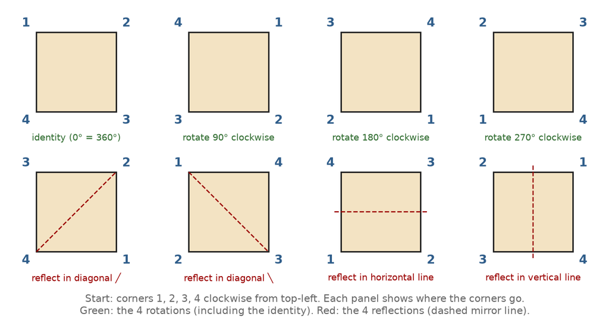

2. **The identity.** The rotation by 360° (equivalently 0°) leaves every point where it was. It is the "do nothing" transformation, which every group of symmetries must contain (Derry p. 265). Every figure has it, so it is counted, but it tells us nothing special about squares.

3. **Internal symmetries.** The other 7 are internal symmetries: they belong to the square itself and define it. A closed figure made of four straight segments is a square if and only if it has all 8. A rectangle that is not a square has only 4 (the 180° turn, the two mid-lines and the identity), and so does a rhombus (the 180° turn, the two diagonals and the identity).

4. **External changes of position.** Moving the square to another place, turning it by 30°, or enlarging it does *not* bring the square back onto itself. The square ends up in a new location, orientation or size. These are symmetries of Euclidean space, not of the square: the figure stays a square, so "squareness" is preserved, but its position has changed. Table 11.1.1 shows that the less a description fixes (location, orientation, size), the more such transformations it allows.

5. **Why the difference matters.** Classification uses internal symmetries, because a square should be a square wherever it lies and however it is turned. External symmetries describe the freedom of space. Confusing the two would make an object's category depend on where it happens to be.

U11-A02Applied5 marks

Explain how drawing a boundary breaks some symmetries while preserving others. Use an example to connect distinction, information and a generic name.

Source Discussion 11.1

1. **What a boundary does.** A boundary divides a uniform space into sides that cannot be joined without crossing it (Spencer-Brown). Before the boundary is drawn, every point is like every other point: the space has translation symmetry. After it is drawn, points inside and outside are no longer interchangeable, so that symmetry is broken (Discussion 11.1).

2. **What it preserves.** Draw a circle on a blank sheet. The background loses its uniformity, but the disk gains a highlighted symmetry: it is unchanged by every rotation about its centre and every reflection in a line through its centre. Each side is also uniform inside: all its points get the same value, or more distinctions would be present.

3. **Information.** The boundary carries information because it marks a difference that makes a difference (Bateson). Inside versus outside, or "strike" versus "ball," is information. More distinctions mean less symmetry, a narrower description and more information. Fewer distinctions mean more symmetry and a broader but vaguer description.

4. **The generic name.** The symmetry that survives defines a class: everything with the disk's circular symmetry is "a disk." The identity of indiscernibles lets us give one generic name to everything that does not differ in the relevant respect. Coins, plates and wheels differ in many ways, but as shapes they fall under one name.

5. **A second example.** A baseball is the same object wherever it is: it is symmetric under translation. Home plate draws a boundary that turns its position into "ball" or "strike." The distinction breaks translation symmetry for the purpose of the game, but the ball's identity as a baseball is unchanged.

U11-A03Applied5 marks

A classification treats two objects as identical for one purpose but different for another. Explain the level of discourse and the identity of indiscernibles without claiming they are the same physical object.

Source Discussions 11.1 and 11.2

1. **The principle.** The identity of indiscernibles says that things that cannot be distinguished are to be considered identical (Discussion 9.1). Classification uses a weaker form: things that do not differ in any essential respect may share a name.

2. **Typological, not individual, identity.** Two white cue balls are "identical" for the game of billiards: neither has any relevant feature that the other lacks. But we know they are two different balls. Saying they are identical assigns them to the same category; it does not claim they are one physical object (Discussion 9.1). In the same way, Fritz and Felix have the same typological identity as cats, not the same individual identity (Discussion 11.2).

3. **The level of discourse.** Whether two things count as "the same" depends on the level of the hierarchy we are speaking at. Lions and tigers are the same at the level of genus (both are big cats) and different at the level of species. A classification must state its level and its criteria of identity.

4. **Purpose sets the criteria.** Fritz's tabby coat and Felix's black coat make no difference to cathood but matter at a cat show. For a study of income by field of study, race may be irrelevant; for a study of income by race, it is the key distinction. The same two objects are identical for one purpose and different for another, without contradiction, because each purpose uses different variables.

5. **The error to avoid, and the opportunity.** A classic error is to assume that things with the same name under one purpose are the same under another. Creativity is the reverse: seeing the thing rather than its name. "I never knew what a good doorstop I would make," said the dictionary.

U11-A04Applied10 marks

Classify three-bead necklaces using three colours. State whether rotations alone, or rotations and reflections, identify necklaces; enumerate the classes under each convention and explain the difference.

Source Discussion 11.1; Study Question 3

1. **Set-up.** Three beads on a circle, each red (R), blue (B) or yellow (Y). Reading clockwise from the top gives 3 × 3 × 3 = 27 arrangements. The question is which arrangements count as the same necklace (Discussion 11.1).

2. **Convention 1: rotations only.** Two arrangements are the same necklace if turning one gives the other. This fits a necklace that cannot be turned over, for example beads fixed on a disk, or a case where the clockwise order matters.

3. **Convention 2: rotations and reflections.** Two arrangements are also the same if one is the mirror image of the other. This fits a loose necklace that can be flipped over, so that clockwise and counter-clockwise do not matter.

| **Kind of necklace** | **Classes (one arrangement named for each)** | **Classes, rotations only** | **Classes, with reflections** |
| --- | --- | --- | --- |
| One colour | RRR, BBB, YYY | 3 | 3 |
| Two of one colour, one of another | RRB, RRY, BBR, BBY, YYR, YYB | 6 | 6 |
| All three colours | RBY, RYB | 2 | 1 |
| Total |  | 11 | 10 |

4. **One colour.** RRR, BBB and YYY. Turning changes nothing, so each class holds a single arrangement.

5. **Two colours.** There are 3 choices for the colour that appears twice and 2 for the single bead, so 6 classes. Each holds 3 arrangements: RRB, RBR and BRR are one necklace. The mirror image of RRB, read the other way round, is BRR, which is already a rotation of it, so reflections add nothing here.

6. **Three colours.** Clockwise, RBY meets red, blue, yellow, and RYB meets red, yellow, blue. No rotation changes one cyclic order into the other, so under convention 1 they are 2 different classes of 3 arrangements each.

7. **Total under convention 1.** 3 + 6 + 2 = 11 classes. As a check, 3 × 1 + 6 × 3 + 2 × 3 = 27, so every arrangement is counted exactly once.

8. **Total under convention 2.** Flipping RBY gives the reverse order, which is a rotation of RYB. So the two three-colour classes merge into one class of 6 arrangements, and there are 3 + 6 + 1 = 10 classes (3 + 18 + 6 = 27).

9. **Why the conventions differ.** Only a necklace with no mirror symmetry can differ from its mirror image. Every one-colour or two-colour necklace already looks the same when flipped, so it is unaffected. Only the three-colour necklaces are "handed," like left and right hands. Flipping a flat necklace over is a rotation in three dimensions, so whether it is allowed depends on whether the necklace is treated as a figure in the plane (Derry pp. 257-258).

10. **Independent check.** A counting rule from group theory gives the same result. Average, over the symmetries allowed, the number of arrangements each one leaves unchanged. Rotations only: (27 + 3 + 3) ÷ 3 = 11. With the three reflections, each of which leaves 9 arrangements unchanged: (27 + 3 + 3 + 9 + 9 + 9) ÷ 6 = 10. A computer listing of all 27 arrangements confirms both totals.

Note*Outside the course: the counting rule in point 10 is Burnside's lemma. A necklace that may be flipped over is often called a "bracelet" in mathematics.*

U11-A05Applied5 marks

Under the simplified assumptions in the mushroom-poison problem, compare a pure natural enantiomer with a racemic synthetic mixture. Explain optical rotation, the value of a control sample and why this evidence alone does not establish a person's guilt.

Source Study Question 2; Derry Chapter 18

1. **The simplified assumptions.** A poison made by a living mushroom is a pure natural enantiomer, a single handed form. The same poison made in a laboratory is a racemic mixture: equal amounts of the left- and right-handed forms. Chemically the two forms are almost indistinguishable (Study Question 2; Derry p. 268).

2. **Optical rotation.** Polarized light passed through a solution of a single handed form has its plane of polarization turned, by an amount that grows with the concentration. The two mirror-image forms turn it by equal amounts in opposite directions. In a racemic mixture the effects cancel, so there is no net turning. A pure natural sample gives the full turning; a racemic sample gives none; a mixture gives a reduced turning, in proportion to the share of natural poison.

3. **The comparison.** Isolate the poison from the soup and measure how much of it there is and how much it turns the light. Compare with the turning expected for that amount of pure natural poison. Full turning points to mushrooms. No turning points to a synthetic poison. Partial turning points to synthetic poison added to natural poison.

4. **The control sample.** Extract the same poison from wild mushrooms of the same species, ideally cooked the same way, and measure it in the same apparatus. This gives the expected turning per amount of poison and its direction, checks the instrument, and shows whether cooking changes the result. A blank soup made without mushrooms shows whether other ingredients affect the light, which is why the poison must be isolated first.

5. **Why this does not establish guilt.** At most the test shows that synthetic poison was present. It does not show who added it, when, or why. Walter's chemistry laboratory makes him a suspect, but that is not proof. Holmes also needs access, opportunity, evidence that the poison came from Walter's laboratory, and a motive. The inference also rests on the simplified premise: a skilled chemist might separate the two forms, so a natural-looking result would not prove Walter innocent either.

Note*Outside the readings: optical rotation is measured with a polarimeter, and heating can slowly convert some compounds from one handed form toward a mixture. This is a further reason for a cooked control sample.*

U11-A06Applied5 marks

Compare a typology and a taxonomy using an original collection. Show how the hierarchy changes the relationships between types at different levels.

Source Discussion 11.2

1. **Collection and purpose.** Every vehicle that parks in a town-centre car park on one day: cars, vans, pickup trucks, buses, motorcycles, scooters and bicycles. The purpose is to plan the space and fees.

2. **A typology.** The types are car, van, pickup truck, bus, motorcycle, scooter, bicycle, and "other" for anything unusual such as a horse-drawn cart. Each vehicle is sorted into exactly one type. The typology is flat: every type is treated as equally important and equally distinct, so a motorcycle is as different from a scooter as it is from a bus.

3. **A taxonomy.** Level 1: motorized or not motorized. Level 2, within motorized: two-wheeled (motorcycle, scooter) or four or more wheels (car, van, pickup truck, bus). The original types form level 3. Each level is itself a typology.

4. **How the relationships change.** In the taxonomy, motorcycles and scooters are "siblings": closer to each other than to cars, because they share a higher-level type. A bicycle and a bus differ at the very first level. Equidistance no longer holds, and the hierarchy now carries information that the flat list could not. This is the reason taxonomies are built (Discussion 11.2).

5. **The hierarchy depends on purpose.** If the purpose were parking *space*, the first split might be by size instead (small: bicycle, scooter, motorcycle; large: the rest). Then bicycles and motorcycles would be siblings, and motorcycles and cars would be distant. The same types sit in different relationships depending on which variable is used at each level.

U11-A07Applied10 marks

Design a typology for a small collection of laboratory containers. Specify its purpose, boundaries, variables and categories, and test completeness and mutual exclusivity.

Source Discussion 11.2

1. **Purpose.** The purpose is to sort the containers in a teaching laboratory, so that each is stored with its kind and used correctly. In particular, students should know which containers measure volume accurately and which can be closed (Discussion 11.2).

2. **Boundaries.** The boundaries are rigid, reusable glass or plastic vessels that hold a sample. Excluded are dispensing and transfer devices (pipettes, burettes, funnels), tubing, and waste bins. The name "Teaching laboratory containers" states the boundary.

3. **Variables and attributes.** *Volume marking*: none, approximate graduations, accurate graduations, or a single calibration mark. *Opening*: wide (the mouth is about as wide as the body) or narrow (a neck narrower than the body). *Closure*: open, or designed to take a stopper, cap or lid. All three are nominal variables.

4. **Checking the variables.** They are *relevant*: marking determines measuring use, and opening and closure determine pouring, swirling and storage. They are *universal*: every container has some marking (even "none"), some opening and some closure. They are *qualitatively different* dimensions, and *logically independent*: each can be chosen separately, even though narrow necks and stoppers often go together.

| **Type** | **Volume marking** | **Opening** | **Closure** |
| --- | --- | --- | --- |
| Beaker | approximate graduations | wide | open |
| Erlenmeyer flask | approximate graduations | narrow | open |
| Graduated cylinder | accurate graduations | wide | open |
| Volumetric flask | single calibration mark | narrow | stopper, cap or lid |
| Test tube | none | wide | open |
| Reagent bottle | none | narrow | stopper, cap or lid |
| Covered dish | none | wide | stopper, cap or lid |
| Other | any other combination |  |  |

5. **Categories.** Seven named types and a catch-all "Other," as in the table.

6. **Completeness.** The three variables allow 4 × 2 × 2 = 16 combinations of attributes. The seven named types use 7 of them, and "Other" covers the remaining 9. So every container within the boundaries has a place, and a new named type can be split off from "Other" when one becomes common.

7. **Mutual exclusivity.** Each named type is a different combination of attributes, and every container has exactly one attribute for each variable. So every container has exactly one combination and falls into exactly one type.

8. **Testing on real items.** A 250 mL beaker, a 100 mL graduated cylinder, a 125 mL Erlenmeyer flask, a 100 mL volumetric flask, a glass test tube, a stoppered reagent bottle and a Petri dish with its lid each sort cleanly into one type.

9. **Problems the test reveals.** A screw-cap sample vial raises the question of whether its mouth is "wide" or "narrow," so the attribute needs an operational definition, for example a neck less than two thirds of the body's diameter. A graduated test tube would sort as a "beaker" (approximate graduations, wide, open). To fix this, add a fourth variable, such as body shape (cylindrical or flared). Testing exclusivity in practice means testing whether the definitions are clear enough.

10. **Definition and interpretation criteria.** The typology is *consistent*, because every type is defined by the same three variables. But it is not truly *equidistant*: a beaker is closer to an Erlenmeyer flask than to a reagent bottle. If those relationships matter, the typology should become a taxonomy (for example, measuring versus holding containers at the top level).

U11-A08Applied5 marks

A typology mixes colour, price and a vague label such as useful. Evaluate its variables for relevance, universality, qualitative difference and logical independence. Propose clearer operational definitions.

Source Discussion 11.2

1. **Relevance.** Relevance depends on the purpose, which must be stated first. Suppose the purpose is deciding which kitchen tools to keep in a small kitchen. Price matters for replacement, and "useful" is close to the purpose, but colour is irrelevant unless it codes something, such as red handles for raw meat (Discussion 11.2).

2. **Universality.** Colour and price apply to every item. "Useful" does not apply in any definite way until we say useful *for what*. As it stands it is a judgment, not an attribute that every item displays.

3. **Qualitative difference.** Colour and price are distinct dimensions. "Useful" is not a separate dimension: it mixes many things, and it overlaps with price, since people tend to pay more for things they find useful.

4. **Logical independence, and the mixed list.** Colour and price can be chosen independently. Usefulness, as people judge it, is partly influenced by the other attributes. Worse, types such as "red items," "expensive items" and "useful items" break consistency (types defined by different criteria) and exclusivity (a red, expensive, useful whisk fits three types). This is the error the Borges "Chinese encyclopedia" caricatures.

5. **Clearer operational definitions.** *Colour*: the dominant colour, matched against a fixed chart of 8 named colours, plus "multicoloured" (nominal). *Price*: the purchase price in dollars (ratio), grouped into the bands "under $10," "$10 to $49.99" and "$50 or more" (ordinal) with no gaps or overlaps. *Usefulness*: replace it with something measurable, such as "number of days used in the last 30 days" (ratio), or "needed for a listed recipe: yes or no" (nominal). Types are then combinations of these attributes, and each item falls into exactly one.

U11-A09Applied5 marks

Distinguish nominal, ordinal, interval and ratio variables in a classification of rocks. Give one example of each and identify which numerical comparisons are justified.

Source Discussion 11.2

| **Scale** | **Rock variable** | **Example values** | **Comparisons that are justified** |
| --- | --- | --- | --- |
| Nominal | rock class by origin | igneous, sedimentary, metamorphic | same or different; counting how many of each |
| Ordinal | grain size class | fine < medium < coarse | also greater or less (rank) |
| Interval | temperature in °C (for example of a lava when collected) | 1,000 °C, 1,200 °C | also differences ("200 degrees hotter") and averages |
| Ratio | mass of a sample in kg | 2 kg, 4 kg | also ratios ("twice the mass") |

1. **Nominal.** Classifying rocks as igneous, sedimentary or metamorphic only names qualitatively different kinds. We can say two rocks are the same or different and count each kind, but "metamorphic is greater than igneous" means nothing (Discussion 11.2).

2. **Ordinal.** Grain size classes are ranked: coarse is coarser than medium. But the steps need not be equal, so we cannot say that coarse is "twice" medium, or that the step from fine to medium equals the step from medium to coarse.

3. **Interval.** Temperature in degrees Celsius is a uniform scale defined by a fixed interval (100 degrees between the freezing and boiling points of water). Differences and averages are meaningful: lava at 1,200 °C is 200 degrees hotter than lava at 1,000 °C. Ratios are not meaningful, because zero on this scale is arbitrary: 1,200 °C is not "1.2 times as hot."

4. **Ratio.** Mass in kilograms is defined by a standard unit and has a true zero. Ratios are meaningful: a 4 kg sample has twice the mass of a 2 kg sample. Age in years and density are also ratio variables.

5. **The rule.** Each scale allows all the comparisons of the scales above it in the table, plus one more. Using a stronger comparison than a scale allows, for example averaging grain-size ranks as if they were measurements, gives numbers that look precise but mean nothing.

Note*Outside the course: the course defines interval and ratio scales by "a specific interval" versus "a standard unit." The standard distinction (Stevens) is that a ratio scale has a true zero, so ratios are meaningful, while an interval scale's zero is arbitrary. The example values in the table are illustrative, not measurements.*

U11-A10Applied5 marks

Compare essential, statistical and phylogenetic definitions of a type. Explain when a cluster of correlated traits might be useful even without one defining trait.

Source Discussion 11.2

1. **Essential (Aristotelian) definition.** A type is defined by a few variables believed to capture its essential characteristics, and every member must have all of them. A triangle is a closed figure with three straight sides. The difficulty is that essential characteristics are often hard or impossible to find: what are the essential features that separate a cat from a lynx (Discussion 11.2)?

2. **Statistical definition.** A type is defined by many variables, each relevant and none essential. Members share most of the attributes but need not share all of them, and clusters are found by statistical measures of similarity, usually with computers. The results can be bizarre unless someone who knows the material oversees them.

3. **Phylogenetic definition.** A type is defined by descent: its members come from a common ancestor. Similarity is read as relatedness, the types form a family tree (a taxonomy), and differences can be used to estimate when lineages separated.

4. **When a cluster without a defining trait is useful.** A cluster is useful when its attributes reliably occur together, so that knowing some of them lets us predict the rest. The psychological traits in Study Question 4 have no single essential trait, but people who score high on some traits in a group tend to score high on the others. A type name such as "verbal fluency" predicts performance on traits not yet measured (SG05).

5. **Conditions for trusting it.** The cluster should hold up in new samples, its variables should be relevant to the purpose, and its name should be tested by the new correlations it predicts. A cluster that appears in only one data set may come from the method rather than the world. The best sign is when a theory explains the cluster, as symmetry principles explained the particle families.

U11-A11Applied5 marks

Construct a possible ancestry tree for 000, 100, 010, 110 and 111, starting at 000. Allow one new 1 per step and no reversals. Mark ambiguous parentage instead of inventing a unique history.

Source Discussion 11.2

1. **Rules.** Each step adds one new 1 and nothing is ever lost. So a parent has exactly one fewer 1 than its child, and every 1 in the parent is also in the child. The tree starts at 000.

2. **Certain links.** 100 and 010 can each come only from 000, which is their only possible parent.

3. **An uncertain link.** 110 could come from 100 (by gaining the second digit) or from 010 (by gaining the first). Both are one step away, and nothing in the data favours either one, so the link is marked "?".

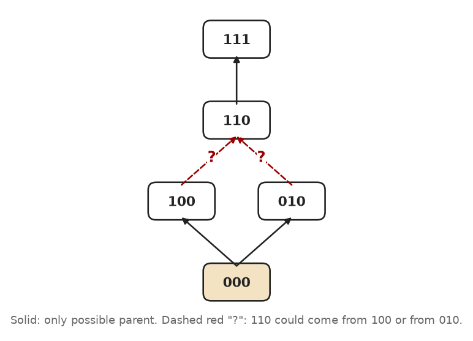

4. **The last link.** Among the observed forms, 111 can come only from 110, because 011 and 101 were not observed. If unobserved (extinct or unsampled) forms are allowed, 111 could also have come from 011 or 101. The tree should state which assumption it uses.

5. **Why not invent a unique history.** Two trees fit the data equally well, and each uses four single-step gains, so counting steps cannot decide between them. Choosing one without evidence would present a guess as a finding. The question mark records exactly what the data support. More characteristics or dating evidence could resolve it.

U11-A12Applied5 marks

Two lineages show 12 accumulated observable changes. Each lineage changes at one change per 100 years, with no reversals or repeated changes. Estimate separation time and explain how the answer changes if the quoted rate applies to the pair jointly.

Source Discussion 11.2

1. **What the 12 changes mean.** After the split, both lineages change, and each change is visible as a difference between them. So the 12 observed changes are the sum of the changes in the two lineages, assuming no reversals and no repeated changes.

2. **Rate per lineage.** If each lineage changes once per 100 years, the pair builds up differences at 2 per 100 years. Time = 12 ÷ 2 × 100 = **600 years** (about 6 changes in each lineage).

3. **Rate for the pair jointly.** If the quoted rate of one change per 100 years applies to the pair as a whole, time = 12 × 100 = **1,200 years**. This is the convention of the course's worked example, which multiplies the total number of mutations in both languages by one interval (10 × 75 years = 750 years, Discussion 11.2).

4. **State the convention.** The two readings differ by a factor of 2, and the data cannot tell which is right; only the meaning of the quoted rate can. A rate must always be stated per lineage or per pair.

5. **Uncertainty.** The rate is an average, so 12 changes is a small, random count, and the true time could differ considerably. If reversals or repeated changes did occur, some changes would be hidden, and the estimate would be a minimum.

Note*Outside the course: if changes occur at random (a Poisson process), a count of 12 has a relative standard error of about 1/√12 ≈ 29%. The estimate, 600 or 1,200 years depending on the convention, is uncertain by roughly that fraction.*

U11-A13Applied5 marks

Compare a strategic and a tactical model of the same system. Explain the different direction of reasoning and how each could influence a theory.

Source Discussion 11.3

1. **The system.** The system is the hydrogen atom, modelled in two ways (Discussion 11.3).

2. **Strategic model: the Bohr atom.** It was built bottom-up from data (the spectrum of hydrogen) and an analogy (a solar system), plus an ad hoc rule that angular momentum is L = nh/2π. Its aim was to find out what a correct theory would have to contain.

3. **Tactical model: the Schrödinger equation for hydrogen.** It was deduced top-down from quantum mechanics and applied to the case of one electron and one proton. It is an exemplar of how the theory is used.

4. **The direction of reasoning.** A strategic model reasons from data and models toward a theory, by induction and abduction. A tactical model reasons from a theory to a particular case, by deduction. This is the bottom-up/top-down cycle of Discussion 9.1.

5. **How each influences theory.** The Bohr model's success motivated the search that produced quantum mechanics. It showed that any new theory must yield the angular-momentum rule. The Schrödinger model tests quantum mechanics: its prediction of whole-number multiples of h/2π confirms the theory, and a misfit would have forced a revision. The tactical model also undercut the strategic one, since quantum mechanics allows no definite orbits. Each kind of model checks the other.

U11-A14Applied10 marks

A simulation closely fits the data used to tune its parameters but fails on new observations. Evaluate it using accuracy, relatedness, transparency, robustness, fertility and ease of enrichment.

Source Discussion 11.3

1. **The diagnosis.** A good fit to the very data used to tune the parameters is not an independent test. With enough adjustable parameters, a model can fit a limited set of data while being far from right (Derry p. 86). Failure on new observations is the real test, and the model has failed it.

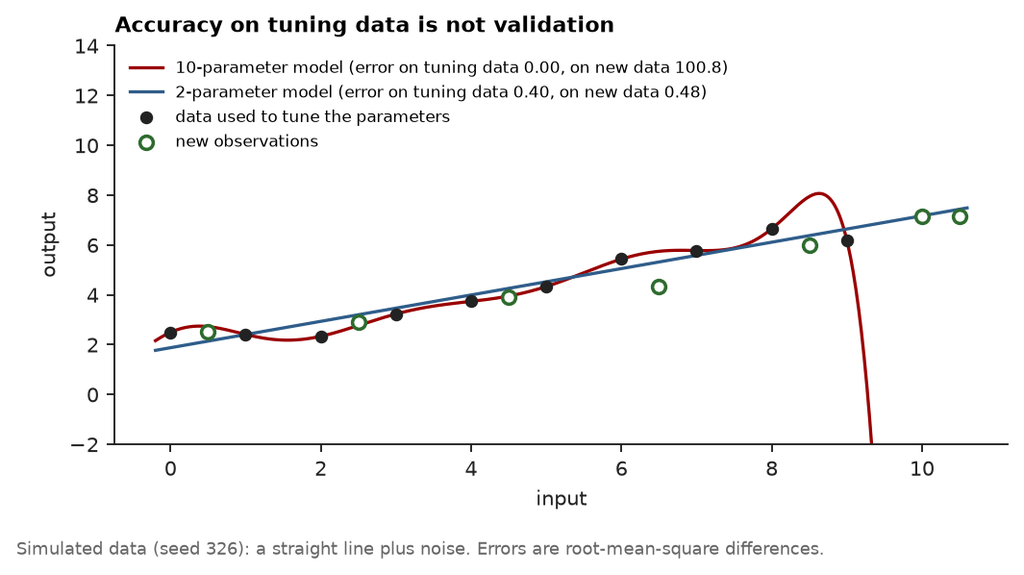

2. **Accuracy.** Accuracy asks how closely the model fits the empirical data (Discussion 11.3). On the tuning data the fit is high, but that measures the flexibility of the fit, not the model. On new observations, which are the meaningful test, the fit is poor. Its accuracy is low.

3. **Relatedness.** How closely is the model connected to known theory? If its equations come from established theory and its fitted parameters agree with values calculated or measured independently, relatedness is high (Derry p. 87). If the parameters are just "knobs" with no physical meaning, or take implausible values, relatedness is low, and that would help explain the failure.

4. **Transparency.** Large simulations are hard to understand. If nobody can say *why* the model fits the old data or fails on the new data, transparency is low, and finding the faulty assumption is difficult.

5. **Robustness.** How sensitive is the model to changes in its assumptions? Retuning on a slightly different data set, or nudging one parameter, would probably change its predictions a great deal. A model whose output swings with small changes in tuning is fragile. The essential assumptions must be separated from those that can be changed.

6. **Fertility.** Can a rich variety of consequences be deduced from it? Consequences are only worth deducing if the model is trustworthy. A model that fails on new cases yields consequences nobody can rely on, so its fertility is low until it is repaired.

7. **Ease of enrichment.** It could easily be "enriched" by adding more parameters, and that would restore the fit to the old data. That is the trap: patching with more adjustable parameters makes it fit better without understanding more, as Ptolemy's epicycles did. Real enrichment would extend its scope by improving its basic assumptions.

8. **Validation.** Discussion 11.3 warns that output resembling known data does not show that the assumptions behind a simulation describe reality; those assumptions need other sources of validation. Here the new observations are exactly such a source, and they count against the model.

9. **Remedies.** Hold back part of the data for testing and never tune on it. Reduce the number of free parameters. Measure parameters independently where possible. Check that the model reproduces known limiting cases. Test it in conditions it was not tuned for.

10. **Verdict.** As it stands, the simulation is not valid for prediction. It might serve as a description of the data it was tuned on, but treating it as reliable would be mistaking the map for the territory, and forcing new data to fit it would be the bed of Procrustes. Keep a detached, critical attitude: it is a starting point for successive approximation, not a result.

Note*The figure is a simulated illustration (seeded random data), not data from any real study.*

U11-A15Applied5 marks

Compare systematic correction, iteration and parameter fitting as ways to improve a model. Explain how improved fit can coexist with a mistaken underlying account.

Source Derry Chapter 6

1. **Systematic correction.** A model's result is written as a sum of terms, each smaller than the last, and more terms give a closer approximation. Derry's illustration is long division: 527/32 = 10 + 6 + 0.4 + 0.06 + 0.008 + ..., which is 16.46875 exactly; stopping at 16.468 is close enough for most purposes (p. 84). In science, Saturn's orbit is calculated first from the Sun alone, then corrected for Jupiter's pull (a perturbation series).

2. **Iteration.** When all the terms are large, there is nothing small to add as a correction. Instead we guess, calculate, use the results to make a better guess, and repeat until what goes in equals what comes out. That condition is called self-consistency (Derry p. 85).

3. **Parameter fitting.** The model's form is kept, and its parameters are adjusted until its predictions match data. Examples are the drug-uptake model's exchange rates, fitted to measured blood concentrations, and a least-squares line for water use against population (Derry pp. 79, 85-86).

4. **How a better fit can hide a wrong account.** All three methods keep the model's basic concept and only improve its numbers. Ptolemy's geocentric model fit the planetary positions well because each epicycle's parameters could be adjusted, yet it was wrong in concept. With many adjustable parameters, a model can match limited data while being far from right. A small curve in water use can also hide in scattered data, making a straight-line model look correct (Derry p. 86).

5. **Derry's own example, and the remedy.** Derry fitted a model potential with two adjustable parameters to five measured atom-surface binding energies and got a very good fit. But one parameter was affected only by very small binding energies that the experiments could not measure, so the fit did not show the results were meaningful (p. 86). The remedy is to compare fitted parameters with independently calculated values. A concept that is wrong cannot be repaired by correction terms: no tinkering with the ideal-gas model explains hydrogen and oxygen turning into water (Derry p. 75).

U11-A16Applied10 marks

Outline a model of a reservoir supplying a town. State the question, variables, parameters, assumptions, data, validation procedure and a situation in which using the model would be inappropriate.

Source Discussion 11.3

1. **The question.** Will the town's reservoir supply its demand through the coming dry season (June to September) without the stored volume falling below a safe minimum? If not, when should water restrictions start? Stating the question first decides which variables matter (stage 1 of Discussion 11.3).

2. **Variables.** The stored volume V (cubic metres), followed day by day over time t, is the main variable. The model's output is the number of days until V reaches the safe minimum.

3. **Parameters.** Daily inflow I from the river and rain, which changes with the season. Daily demand D, equal to water use per person times the population. Daily evaporation E, which depends on the water's surface area and the weather. A required release R to keep the river below the dam alive. The capacity Vmax, above which water spills, and the safe minimum Vmin.

4. **The model.** Each day: new V = old V + I - D - E - R, capped at Vmax. Run it forward from today's level. This is a simple water-balance (difference-equation) model, chosen because the available analytical tools and data are daily (stage 4 mediating stage 2).

5. **Assumptions.** Inflow follows the pattern of past years. Demand is proportional to population, at a constant use per person, as in Derry's water-consumption example (p. 85). Evaporation is proportional to surface area. Leakage and seepage are negligible or constant. Water quality is ignored: the model tracks quantity only.

6. **Data.** Records of past inflow and rainfall; daily reservoir levels and the reservoir's level-volume table; the town's metered water use and population; and local evaporation measurements.

7. **Estimating the parameters.** Measure them directly wherever possible, such as demand from water meters and release from the dam's records, as in Derry's traffic model. Fit only what cannot be measured, such as seepage, to past reservoir levels, and keep the number of fitted parameters small.

8. **Validation.** Tune the model on some past years, then test it on other years it has never seen: does it predict how the reservoir level actually fell? Check robustness by varying inflow and demand by realistic amounts. Judge the result by accuracy, relatedness and transparency, and compare any fitted values with independent estimates.

9. **Using it.** Run scenarios: a repeat of the driest year on record, a growing population, or restrictions that cut use per person by a given fraction. The model then answers the question asked: whether and when restrictions are needed.

10. **When not to use it.** Do not use it for conditions outside the range it was tested on: a drought far worse than any on record, a sudden climate shift, or a flood, where daily steps and a simple spill rule are too crude. Do not use it for a contamination event, because it has no water-quality variables. And do not use it to announce the exact day the town runs dry, since that would mistake the map for the territory. Whenever new observations disagree with it, revise the model rather than forcing the data to fit (the bed of Procrustes).

### People and attributions22

U11-P01Person

Identify William Blake (1757-1827) and the idea or contribution the assigned readings ascribe to this person. Explain its significance in this unit.

Source Discussion 11.1 epigraph; Derry ch. 18

1. **Who.** William Blake (1757-1827) was an English poet. Discussion 11.1 opens with the first two stanzas of his poem "The Tyger," from *Songs of Experience* (Discussion 11.1). Derry's Chapter 18 takes its title from the same poem: "Riding Blake's Tiger: Symmetry in Science, Art, and Mathematics" (Derry, p. 252).

2. **Quotation.** The poem asks the tiger "What immortal hand or eye" could "Dare frame thy fearful symmetry" (Discussion 11.1).

3. **Meaning.** The discussion does not comment on the epigraph. Read as an epigraph, it marvels at the symmetry of the tiger's form and asks what maker could have "framed" it: symmetry is both beautiful and awe-inspiring, and it seems to call for an explanation.

4. **Significance.** The poem sets the theme of the unit. Similarities are established through the concept of symmetry, a "likeness of measure" (Discussion 11.1), and classification groups things by the features that stay invariant under some set of transformations. Derry adds that symmetry plays an important role in all of the natural sciences, "a particularly fundamental role in physics," and is "central to aesthetics and the arts" (Derry, p. 252).

U11-P02Person

Identify Gregory Bateson (1904-1980) and the idea or contribution the assigned readings ascribe to this person. Explain its significance in this unit.

Source Discussion 11.1 epigraph

1. **Who.** Gregory Bateson (1904-1980) was a British anthropologist; his dates are given with his epigraph in Discussion 4.1. The second epigraph of Discussion 11.1 comes from his book *Mind and Nature* (Discussion 11.1).

2. **Quotation.** "Information consists of differences that make a difference" (Discussion 11.1).

3. **Meaning.** To make a distinction we must ignore many other potential distinctions, so in defining general categories we look for "the most informative distinctions" (Discussion 11.1). Which differences count depends on "the conceptual framework within which we frame our questions." That Fritz is tabby while Felix is black with a white nose and paws makes no difference to the scientific concept of cathood, but may matter at a cat show; that both cats are lone hunters of birds and mice, while Rover hunts deer in packs, does make a scientific difference (Discussion 11.1).

4. **Significance.** Classification works by ignoring irrelevant differences and keeping the informative ones. Discussion 11.2 returns to the phrase: "There is an inherent purposefulness in naming, and only variables that are relevant to this purpose need to be considered" (Discussion 11.2).

U11-P03Person

Identify G. Spencer-Brown and the idea or contribution the assigned readings ascribe to this person. Explain its significance in this unit.

Source Discussion 11.1; Discussion 11.2 epigraph

1. **Who.** G. Spencer-Brown is the logician whose book *Laws of Form* was first quoted in Unit 9 (Discussion 9.2). Discussion 11.1 quotes the passage again as an "elegant formulation," and Discussion 11.2 opens with a line from the same page (Discussion 11.1).

2. **Quotation.** "Distinction is perfect continence" ... "There can be no distinction without motive, and there can be no motive unless contents are seen to differ in value" (Discussion 11.1). The epigraph of Discussion 11.2 adds: "we cannot make an indication without drawing a distinction" (Discussion 11.2).

3. **Meaning.** A distinction is drawn by a boundary with separate sides, so that a point on one side cannot reach the other without crossing it; in a plane, a circle draws one. The contents on each side can then be indicated, and a name can stand for their value. Similarity and distinction are "inextricably connected": giving each side a single value assumes that all its points are alike (Discussion 11.1).

4. **Significance.** Similarities let us group individuals into categories, and differences yield distinct categories, so every classification rests on both. Because no distinction is drawn without motive, classification always serves a purpose, and the useful distinctions are the ones that make a difference (Discussion 11.1).

U11-P04Person

Identify Hermann Weyl (1885-1955) and the idea or contribution the assigned readings ascribe to this person. Explain its significance in this unit.

Source Discussion 11.1; Derry ch. 18

1. **Who.** Hermann Weyl (1885-1955) was a mathematician and the author of *Symmetry* (1952), which Discussion 11.1 cites (Discussion 11.1). Derry quotes him in an epigraph to Chapter 18: "Symmetry is a vast subject, significant in art and nature" (Derry, p. 252).

2. **Idea.** According to Weyl, "the way to begin studying a structure is to determine the transformations that leave it invariant; that is, to determine its symmetries" (Discussion 11.1).

3. **Example.** Distinguishing a disk against a uniform background breaks the homogeneity of the background and at the same time highlights the circular symmetries of the disk, which can then be used to group together all other disk-like things. The idea applies to qualities too: red versus not-red breaks a colour symmetry, and sorting bugs by six, eight or many legs breaks the symmetry of the classifying term "has legs" (Discussion 11.1). Derry also takes from Weyl the phrase "the art of ornament" for symmetric tiles, wallpaper and cloth prints (Derry, p. 269).

4. **Significance.** Symmetry is invariance under a transformation, and every distinction breaks some symmetry while highlighting those that remain. Weyl's rule makes symmetries the starting point of classification: the highlighted symmetries define the equivalence class of all things that share them (Discussion 11.1).

U11-P05Person

Identify Martin Gardner and the idea or contribution the assigned readings ascribe to this person. Explain its significance in this unit.

Source Discussion 11.1

1. **Who.** Martin Gardner was a "well-known science writer" (Discussion 11.1). The course cites "The Five Platonic Solids," the first chapter of his *More Mathematical Puzzles and Diversions* (Discussion 11.1).

2. **Contribution.** In a fair game of dice each face must have an equal chance of coming up, and the object tossed should be as simple as possible. Gardner pointed out that these functional requirements "impose a symmetry restriction on the die that is cast: it must be a regular polyhedron," a volume with congruent faces that are regular polygons and with congruent internal angles (Discussion 11.1).

3. **Platonic solids.** It has been known since the Pythagoreans that only five regular polyhedra exist, the platonic solids, so "Any fair die, anywhere in the universe, must have the shape of one of the platonic solids" (Discussion 11.1). Derry lists them: the tetrahedron, cube, octahedron, dodecahedron and icosahedron (Derry, pp. 256-257).

4. **Significance.** The die is a top-down use of symmetry: a function required of a system limits the symmetries it may have, and so restricts its possible forms. Particle physics works the same way when experimenters search for new particles whose properties were predicted from symmetry considerations (Discussion 11.1).

U11-P06Person

Identify Richard Feynman and the idea or contribution the assigned readings ascribe to this person. Explain its significance in this unit.

Source Discussion 11.1

1. **Who.** Richard Feynman was a "Nobel prize-winning physicist" (Discussion 11.1). Discussion 11.1 quotes his book *The Character of Physical Law* to describe the top-down use of approximate symmetries.

2. **Quotation.** "You have an approximate symmetry, so you calculate a set of consequences supposing it to be perfect. When compared with experiment it does not agree" (Discussion 11.1). If the agreement is pretty good you say "Nice!"; if it is very poor you say that "this particular thing must be especially sensitive to the failure of the symmetry" (Discussion 11.1). In other words, a poor fit is blamed on that phenomenon's sensitivity to the symmetry's failure.

3. **Meaning.** Feynman admits that "you may laugh, but we have to make progress in this way": when a subject is new, this jockeying around and guessing at results "is the beginning of any science" (Discussion 11.1). In the top-down approach, symmetry transformations are chosen on theoretical grounds, their consequences are worked out as if the symmetry were perfect, and the results are compared with experiment and observation.

4. **Significance.** Symmetries found in nature are often only approximate, yet assuming a perfect symmetry still gives a usable first account, and a poor fit points to where the symmetry fails. Elementary particle physics works this way, searching for new particles whose properties were predicted from abstract symmetry considerations (Discussion 11.1).

U11-P07Person

Identify Emmy Noether and the idea or contribution the assigned readings ascribe to this person. Explain its significance in this unit.

Source Discussion 11.1; Derry ch. 18, p. 271

1. **Who.** Emmy Noether was a German mathematician (Discussion 11.1). Derry dates her result to 1918 (Derry, p. 271).

2. **Theorem.** "The German mathematician Emmy Noether proved that every dynamic symmetry of a system corresponds to a conserved quantity of that system" (Discussion 11.1). Derry puts it the other way round: "every conservation law is due to some underlying symmetry" (Derry, p. 271).

3. **Examples.** Translation symmetry corresponds to conservation of momentum, rotational symmetry to conservation of angular momentum, and time displacement symmetry to conservation of energy (Discussion 11.1). Derry adds that electric charge and several more abstract quantities are conserved because of abstract symmetries (Derry, p. 271).

4. **Significance.** Dynamic symmetries do not show in a system's structure but in its motion: the equations of motion keep their form under certain transformations, as Newton's F = ma does for coordinate systems moving at constant velocity relative to each other. One of their major values is that they are "directly related to conservation laws" (Discussion 11.1), so a symmetry of the laws tells us what must stay constant.

U11-P08Person

Identify Plato and Anthony Zee and the ideas or contributions the assigned readings ascribe to them. Explain their significance in this unit.

Source Discussion 11.1 epigraphs; Unit 11 Overview

1. **Who.** Plato was an ancient Greek philosopher, and Anthony Zee is a physicist, the author of *Fearful Symmetry: The Search for Beauty in Modern Physics*. Their words are the two epigraphs of the section "Different Kinds of Symmetries": Plato's from his dialogue *Philebus* (Discussion 11.1).

2. **Plato.** "[T]he qualities of measure and proportion invariably, I imagine, constitute beauty and excellence" (Discussion 11.1). The Overview begins the unit with Plato's injunction to "carve at the joints": we gather together collections of similar things and give each distinct collection a name (Unit 11 Overview).

3. **Zee.** "Given two theories, physicists feel that the more symmetrical one, generally, is the more beautiful" (Discussion 11.1).

4. **Significance.** Both link beauty to symmetry, and symmetry to measure: the word derives from the root me, "to measure," and two similar things share a "likeness of measure" (Discussion 11.1). The section that follows defines symmetry as invariance under transformations, the kind of transformation fixing the kind of symmetry. Carving at the joints means classifying by the similarities and distinctions that the subject itself presents, which is where every scientific study begins (Unit 11 Overview).

U11-P09Person

Identify Bronislaw Malinowski (1884-1942) and the idea or contribution the assigned readings ascribe to this person. Explain its significance in this unit.

Source Discussion 11.2 epigraph

1. **Who.** Bronislaw Malinowski (1884-1942) was a Polish-born British anthropologist. The second epigraph of Discussion 11.2 comes from his book *A Scientific Theory of Culture* (Discussion 11.2).

2. **Quotation.** "The fundamental problem of each science is the establishment of the identity of its phenomena" (Discussion 11.2).

3. **Meaning.** "It should be obvious that science is not possible if we cannot agree on what we are talking about. Therefore, identification of the objects of study is the first step in any scientific endeavour" (Discussion 11.2). Before naming things, we collect them into similar groups and name each group: we classify.

4. **Significance.** "Classification and measurement are the two basic requirements for doing science" (Discussion 11.2). The identity of a type is its location as a region of a parameter space, defined by its attributes; the Overview adds that "it would be difficult to do science if the identity of the object of study was undefined or kept changing" (Unit 11 Overview).

U11-P10Person

Identify Jorge Luis Borges (1899-1986) and the idea or contribution the assigned readings ascribe to this person. Explain its significance in this unit.

Source Discussion 11.2 epigraph

1. **Who.** Jorge Luis Borges (1899-1986) was an Argentine writer. The third epigraph of Discussion 11.2 comes from his essay "The Analytical Language of John Wilkins," in *Other Inquisitions 1937-1952* (Discussion 11.2).

2. **Quotation.** Borges describes a "Chinese encyclopedia" entitled "Celestial Empire of Benevolent Knowledge," in which the animals are divided into "(a) belonging to the emperor, (b) embalmed, (c) tame, (d) sucking pigs" ... "(h) included in the present classification" ... "(l) et cetera" ... "(n) that from a long way off look like flies" (Discussion 11.2).

3. **Meaning.** The classification is absurd. Measured against the criteria Discussion 11.2 sets for a typology, its types are not defined by the same criteria of identity (consistency), and one animal could be tame, stray and belong to the emperor at once, so the types are not mutually exclusive.

4. **Significance.** A typology is a classification for sorting, so it needs clear boundaries, completeness and exclusive types, and its variables must be relevant to its purpose: "They are the dimensions on which a difference makes a difference" (Discussion 11.2). Borges shows what a classification looks like without these rules.

U11-P11Person

Identify Yuval Ne'eman and Murray Gell-Mann and the ideas or contributions the assigned readings ascribe to them. Explain their significance in this unit.

Source Discussion 11.2

1. **Who.** Yuval Ne'eman and Murray Gell-Mann were physicists (Discussion 11.2), Israeli and American respectively, who worked on the classification of elementary particles.

2. **Contribution.** In the early days of particle physics only certain types of particles seemed to exist, and they seemed to fall into specific families, so a phenomenological classification was built from this information. Ne'eman and Gell-Mann "independently discovered that this phenomenological typology could be theoretically generated on the basis of certain symmetry principles, and furthermore, that the resulting typology could be used to predict the existence of new types of particles" (Discussion 11.2).

3. **Context.** Once types are named, looking for regularities and relationships between them "may lead to a redefinition of the typology in terms of inductively derived theoretical principles" (Discussion 11.2). Discussion 11.1 gives the same case as top-down use of symmetry: experimental workers are instructed to "search for new particles having properties predicted from abstract symmetry considerations" (Discussion 11.1). Derry adds that quark interactions can be described by "a small number of fundamental symmetry operations" (Derry, p. 271).

4. **Significance.** An empirical, bottom-up typology (these particles seem to fit together) became a theoretical, top-down one, and the theory could then predict entities not yet observed. This is the bottom-up/top-down cycle of classification, with symmetry supplying the principles.

U11-P12Person

Identify Carl Jung and the idea or contribution the assigned readings ascribe to this person, as used in the Myers-Briggs personality inventory. Explain its significance in this unit.

Source Discussion 11.2

1. **Who.** Carl Jung was a psychologist (Discussion 11.2), the Swiss founder of analytical psychology. His idea appears in Discussion 11.2 as a modern case of classification by ideal polar types.

2. **Idea.** "[T]he psychologist Carl Jung defined the ideal polar types of thinking/sensing and reasoning/intuiting. These polarities are used in the widely used Myers-Briggs personality inventory to classify people into one of 16 categories based on their scores on each of the four dimensions" (Discussion 11.2). Four two-pole dimensions give 2 x 2 x 2 x 2 = 16 categories. (Jung's own pairs are usually given as thinking/feeling and sensation/intuition.)

3. **Context.** Ideal types are posited for theoretical purposes, unlike empirical types determined from observation, and are sometimes stated as polar opposites, absolute (positive and negative charge) or the ends of a spectrum (red and violet), with any actual instance falling between the poles. The ancient Greeks crossed two polarities, wet/dry and hot/cold, into a 2 x 2 array of air, fire, water and earth, the "Greek cross" (Discussion 11.2).

4. **Significance.** Polar types turn a continuous range of variation into a sorting scheme: each person is placed by a score on every dimension. Like any typology, the result depends on the variables chosen for its purpose.

U11-P13Person

Identify Lao Tzu and the idea or contribution the assigned readings ascribe to this person. Explain its significance in this unit.

Source Discussion 11.2

1. **Who.** Lao Tzu was an ancient Chinese philosopher, the traditional author of the *Tao Te Ching*, which Discussion 11.2 quotes in its closing paragraph (Discussion 11.2).

2. **Quotation.** "The name that can be named is not the enduring and unchanging name" (Discussion 11.2).

3. **Context.** "One of the classic errors in thinking is to assume that, because two things have the same name in a typology constructed with regard to one purpose, they will still be the same in a typology constructed for some entirely different purpose" (Discussion 11.2). A hallmark of creative thought is "the ability to see the thing rather than the thing named," and so to see possibilities hidden by its ordinary typological identity. The discussion ends with a joke: "I never knew what a good doorstop I would make," said the dictionary (Discussion 11.2).

4. **Significance.** A name records a typological identity fixed by one purpose and a chosen set of variables, not the whole individual. Things with the same typological identity do not share the same individual identity, so a scientist must not let the name stand in for the thing.

U11-P14Person

Identify Galileo Galilei (1564-1642) and the idea or contribution the assigned readings ascribe to this person. Explain its significance in this unit.

Source Discussion 11.3 epigraph

1. **Who.** Galileo Galilei (1564-1642) was an Italian astronomer and physicist. The first epigraph of Discussion 11.3 comes from *Discoveries and Opinions of Galileo*, translated by Stillman Drake (Discussion 11.3).

2. **Quotation.** "Philosophy is written in that great book which ever is before our eyes" ... "but we cannot understand it if we do not first learn the language and grasp the symbols in which it is written. This book is written in the mathematical language, and the symbols are triangles, circles, and other geometric figures, without whose help it is impossible to comprehend a single word of it" (Discussion 11.3).

3. **Meaning.** The book of nature, the universe, is written in the language of mathematics, so we can read it only by learning that language.

4. **Significance.** Discussion 11.3 treats mathematical models as "often the most useful sort of model, because they allow precise numerical computations" (Discussion 11.3). The unit's examples climb Galileo's ladder: the Freudian steam-engine model captures only vague relationships, the Bohr model can be quantified and compared with experiment, and the Schrödinger equation for hydrogen is "mathematical through and through" (Discussion 11.3).

U11-P15Person

Identify Alfred Korzybski (1879-1950) and Alan Watts (1915-1973) and the ideas or contributions the assigned readings ascribe to them. Explain their significance in this unit.

Source Discussion 11.3 epigraphs

1. **Who.** Alfred Korzybski (1879-1950) was the founder of general semantics; the course cites his *General Semantics*. Alan Watts (1915-1973) was a British-born writer on Eastern philosophy. Their aphorisms are the second and third epigraphs of Discussion 11.3 (Discussion 11.3).

2. **Quotations.** Korzybski: "The map is not the territory." Watts: "The menu is not the meal" (Discussion 11.3).

3. **Meaning.** A model, like a map or a menu, is a representation built for a purpose, not the reality it stands for. Modeling can lead to mistaking the map for the territory, "focusing on the model rather than the reality it claims to model"; it can also produce abstract arguments unrelated to the field's real questions (some researchers deduced from the Lotka-Volterra model that certain ecological systems had to have an even number of species), and force data into an inappropriate form, like the "bed of Procrustes" (Discussion 11.3).

4. **Significance.** Models are an important tool for science, but a scientist must "maintain a detached and critical attitude toward the models being used. As the aphorisms at the beginning of this discussion have it, the map is not the territory and the menu is not the meal" (Discussion 11.3).

U11-P16Person

Identify Robert May and the idea or contribution the assigned readings ascribe to this person. Explain its significance in this unit.

Source Discussion 11.3

1. **Who.** Robert May was an ecologist (Discussion 11.3). Discussion 11.3 quotes the preface of his book *Stability and Complexity in Model Ecosystems* to show the value of mathematical models in science.

2. **Quotation.** "This work seeks to gain general ecological insights with the help of general mathematical models. That is to say, the models aim not at realism in detail, but rather at providing mathematical metaphors for broad classes of phenomena. Such models can be useful in suggesting interesting experiments or data collecting enterprises, or just in sharpening discussion" (Discussion 11.3).

3. **Meaning.** A model is "a mechanical or theoretical construct designed to study a particular real world situation or phenomenon" (Discussion 11.3). May's models do not copy every detail of an ecosystem; like a metaphor, they capture a pattern shared by many cases, and even a mathematical model may be used only in a heuristic way. Derry makes the same point: a model needs the essential features "but not all of the details" (Derry, p. 78).

4. **Significance.** This is why modeling is useful: it can suggest general principles, indicate new directions for empirical research, suggest conclusions not reachable through observation alone, highlight relationships in large quantities of data, and provide an overview for organizing and interpreting data (Discussion 11.3).

U11-P17Person

Identify Niels Bohr (1885-1962) and Ernest Rutherford (1871-1937) and the ideas or contributions the assigned readings ascribe to them. Explain their significance in this unit.

Source Discussion 11.3; Discussion 15.1

1. **Who.** Niels Bohr (1885-1962) was "A young Danish physicist visiting Rutherford's laboratory" when he produced his model of the hydrogen atom in 1913 (Discussion 15.1). Ernest Rutherford (1871-1937) was a physicist (Discussion 11.3).

2. **Rutherford.** Rutherford "carried out a series of experiments at the Cavendish Laboratory that discredited the plum pudding model" (Discussion 11.3). Discussion 15.1 adds that these alpha-particle scattering experiments were carried out by his collaborators, and that from them Rutherford concluded that an atom's positive charge is concentrated in a tiny central region, the nucleus (Discussion 15.1).

3. **Bohr.** Bohr's model treats the hydrogen atom as a miniature solar system: the proton is the sun, the electron a planet, and the inverse square electromagnetic force replaces gravity. Classically an orbiting electron radiates energy and spirals into the proton, so Bohr added an ad hoc assumption: electrons occupy only orbits with angular momentum L = nh/2π and radiate only when jumping between them. The model predicted the frequencies of radiation emitted by hydrogen (Discussion 11.3).

4. **Model type.** The Bohr atom is a strategic model, built bottom-up to fit experiment; it was robust when circular orbits became elliptical, but any change in the angular momentum assumption would destroy its predictive power, because that assumption "contained the essential new information of the model" (Discussion 11.3).

5. **Significance.** A model built on an analogy can succeed while contradicting accepted theory. Its success led physicists to suppose that classical electromagnetism did not apply at the atomic level, and quantum mechanics justified Bohr's assumption about a decade later (Discussion 11.3).

U11-P18Person

Identify William T. Morris and the idea or contribution the assigned readings ascribe to this person. Explain its significance in this unit.

Source Discussion 11.3

1. **Who.** William T. Morris is the author of "On the Art of Modeling," published in *Management Science* in 1967, from which Discussion 11.3 takes "six criteria for evaluation of models" (Discussion 11.3).

2. **The six criteria.** **Accuracy**: how closely does the model fit the empirical data? **Relatedness**: how closely is it connected to known theories and results? **Transparency**: is it easy to understand, and does it appeal to our intuition? **Robustness**: how sensitive is it to changes in its basic assumptions? **Fertility**: can a rich variety of consequences be deduced from it? **Ease of enrichment**: has it reached the limits of its possible development, or can it lead to more comprehensive models (Discussion 11.3)?

3. **Robustness.** A model whose very specific assumptions cannot be changed cannot easily be enriched, while one without such assumptions guides intuition but gives little information. So we distinguish essential assumptions from modifiable ones: the Bohr atom survived a change from circular to elliptical orbits, but not any change to its angular momentum assumption (Discussion 11.3).

4. **Significance.** The criteria give a checklist for evaluating any model, strategic or tactical. Objective 12 of Unit 11 asks you to "state and describe six criteria for the evaluation of models" (Unit 11 Overview).

U11-P19Person

Identify Maria Goeppert Mayer and J. H. D. Jensen and the ideas or contributions the assigned readings ascribe to them. Explain their significance in this unit.

Source Derry ch. 6, pp. 77-78

1. **Who.** Maria Goeppert Mayer was "a physicist" who "was not paid a salary for much of her career due mostly to gender discrimination" and "later shared the Nobel Prize for this work" (Derry, pp. 77-78). J. H. D. Jensen "also independently devised the shell model at about the same time" (Derry, p. 77).

2. **Magic numbers.** Nuclear physicists favoured the liquid drop model, because no single source was known for the forces on particles in the nucleus. Examining data on the stability and abundances of isotopes, Mayer found that nuclei with 2, 8, 20, 28, 50, 82 or 126 neutrons or protons were unusually stable. She reasoned that these "magic numbers" might be explained by closed shells, as for the electrons of the inert gases (Derry, p. 77).

3. **The model.** A square well, in which the particles move freely inside the nucleus but cannot escape, predicts only 2, 8 and 20. Adding the spin-orbit interaction, a term analogous to the magnetic energy of little compass needles, small for electrons in atoms but large in the nucleus, gave a model that "correctly predicted all of the magic numbers!" (Derry, p. 78). Shell models were accepted from 1949.

4. **Significance.** "[T]he use of a relatively crude model made a decisive and fertile contribution to our knowledge" (Derry, p. 78). A model needs the essential features, not all the details: start with an inadequate but basically correct model and look for the missing ingredient.

U11-P20Person

Identify John von Neumann and the idea or contribution the assigned readings ascribe to this person. Explain its significance in this unit.

Source Derry ch. 6, p. 82

1. **Who.** "Game theory was invented in 1928 by the mathematician John von Neumann" (Derry, p. 82). Derry's Chapter 6 uses it as "one simple model of social interactions": conflicts, modeled as participants in a contest that has winners and losers (Derry, p. 81).

2. **Matching pennies.** Von Neumann started with a game in which two players lay down pennies heads up or heads down; if they match one player wins, if not the other does. No choice guarantees a win, and any pattern can be discerned by the opponent, but laying down half heads and half tails at random ensures that you will not lose more than half the time. Since this minimizes the losses of both players, von Neumann considered it a stable solution (Derry, p. 82).

3. **Zero-sum games.** His insight was to apply the same reasoning to more complicated games, showing "that for any zero-sum game (i.e., one player's loss equals the other player's gain) with two players and some random choices, there is always a strategy that minimizes the losses of both players" (Derry, p. 82).

4. **Significance.** The model rests on two major simplifying assumptions, two players and a zero-sum game; non-zero-sum games such as the Prisoner's Dilemma are far more complex. Game theory made the messy characteristics of human affairs "amenable to mathematical treatment," even though "the simplifying approximations of the models are very severe," and it has proven a fertile method in the social sciences (Derry, p. 83).

U11-P21Person

Identify Louis Pasteur, James Clerk Maxwell, Albert Einstein and Evariste Galois and the ideas or contributions the assigned readings ascribe to them. Explain their significance in this unit.

Source Derry ch. 18, pp. 268-272

1. **Who.** Louis Pasteur was a French chemist, James Clerk Maxwell and Albert Einstein were physicists, and Evariste Galois was a mathematician who did his work at 21. Derry's Chapter 18 uses them as cases of symmetry in chemistry and biology, physics and algebra (Derry ch. 18).

2. **Pasteur.** "Pasteur discovered the existence of such substances when he made tartaric acid for the first time in 1848, and he obtained equal amounts of the right-handed and left-handed forms" (Derry, p. 268). The right-handed form was already known from fermenting grapes; the left-handed one was new. Living organisms almost always produce only one of the mirror-image forms: "No one knows the reason for this broken symmetry" (Derry, p. 268).

3. **Maxwell and Einstein.** Maxwell noticed that a changing magnetic field causes an electric field but not the reverse, rewrote the equations to make them symmetric, and found that they predicted electromagnetic waves moving at the speed of light, unifying optics and electromagnetism: "the first of a series of unifications grounded in symmetry" (Derry, p. 270). Einstein removed an asymmetry between observers in relative motion; relativity welded space and time into one space-time continuum and unified mass and energy (Derry, p. 270).

4. **Galois.** In 1832 Galois discovered that the permutations of the solutions of polynomial equations formed a group, coined the term group, and proved that no general solution can be written for equations of the fifth power or higher (Derry, p. 272).

5. **Significance.** Symmetry unifies science: broken symmetry in living molecules, symmetric laws that join separate sciences, and the group concept that gives symmetry its mathematical language, group theory (Discussion 11.1).

U11-P22Person

Identify Abu Hamid al Ghazali (1058-1111) and the idea or contribution the assigned readings ascribe to this person. Explain its significance in this unit.

Source Unit 11 Overview epigraph

1. **Who.** Abu Hamid al Ghazali (1058-1111) was a "medieval Islamic theologian" (Discussion 6.1). The epigraph of the Unit 11 Overview comes from his *Confessions, or Deliverance from Error*, written about 1100 CE (Unit 11 Overview).

2. **Quotation.** "[I]n order to discover where the professors of any branch of knowledge have erred, one must make a profound study [and] must equal and even surpass those who know most of it" (Unit 11 Overview).

3. **Meaning.** You cannot find where experts have gone wrong from outside their field: you must first master it as well as they do. Discussion 1.2 opens with the same epigraph.

4. **Significance.** The Overview asks how a scientist begins to study an unknown system, and answers that "there is always a background of theory and/or practice that limits the possible approaches that can be taken" (Unit 11 Overview). Classifications and models are built and judged within that background, so improving them, or showing that a typology or model is wrong, requires first mastering the field that produced them.

Unit 12

## Measurement and Scientific Facts

Approach Separate observed results from interpretations. Preserve uncertainty, identify scale type and state missing data rather than supplying an unlabelled assumption.

### Official study guide questions10

U12-SG01Study guide

The philosopher W. T. Stace has claimed that potential energy is nothing but a fiction invented as a means of saving the law of conservation of energy. He supports this claim by arguing that if an object is thrown into the air and lands on a roof, then there is no evidence that it has anything like “potential energy.” Can you find the flaw in this argument?

**Hint:** In physics, energy is defined as the capacity to perform work.

Source Unit 12 Study Questions question 1

1. **Stace's argument.** An object thrown up onto a roof shows no visible change while it rests there. Stace concludes that there is no evidence it has "potential energy," so the term is a fiction invented to save the law of conservation of energy.

2. **The flaw: he looks for the wrong kind of evidence.** In physics, energy is defined as the *capacity* to perform work. A capacity is not a visible property like colour. It shows itself only when the conditions for using it are met. So "nothing visible happens while it sits on the roof" is exactly what the definition predicts, and it cannot count against it.

3. **The capacity can be tested.** Nudge the object off the roof and it does work: it can lift a weight over a pulley, drive a nail or dent the ground. An object at ground level, otherwise identical, cannot do this. The difference between the two objects is real and observable, and it is what potential energy names.

4. **The amount is fixed in advance, so the claim is not just a rescue.** The potential energy is calculated from the weight and the height before anything happens. The kinetic energy at the bottom, and the work the object can do, are then measured and found to match. A fiction invented after the fact could be given any value. This one makes a definite prediction that could fail and does not, which is how a scientific fact is checked (Discussion 12.2).

5. **The deeper mistake.** Stace treats only what is directly visible in the object as real. By that standard germs were fictions before the microscope (Discussion 12.2), and kinetic energy too is known only through its effects. Potential energy also belongs to the arrangement of object and Earth, not to the object alone, so looking at the object alone cannot reveal it. Being a theoretical term, measured indirectly, does not make it a fiction.

Note*Outside the readings: gravitational potential energy near the Earth's surface is calculated as weight × height (mgh).*

U12-SG02Study guide

In the study of heat, the calorie theory was eventually discarded in favour of the kinetic theory. Thus, the theoretical entity known as “caloric” must now be considered as a mere fiction. Can you think of a reason that the theoretical term “potential energy” is believed to refer to something real, while the theoretical term “caloric” is not?

**Hint:** Energy is defined in terms of a capacity to do work while calorie was defined as a material substance.

Source Unit 12 Study Questions question 2

1. **Different kinds of definition.** Potential energy is defined by what a system can *do*: a capacity to perform work, measured by work actually done. Caloric was defined as what heat *is*: a weightless, invisible fluid that flowed from hot bodies into cold ones and was conserved (Discussion 12.2 calls it "a subtle fluid").

2. **A capacity stays tied to measurement.** Whatever the deeper nature of energy turns out to be, the capacity to do work can be measured, and potential energy reliably converts into an equal amount of kinetic energy and work. So the term keeps referring to something that our measurements find, even if the theory around it changes.

3. **A substance makes claims that can fail.** If heat is a conserved fluid, a body can hold only a limited amount and cannot release more than it contains. Friction should not produce an unlimited supply of it. These consequences were tested and failed.

4. **What replaced it.** In the kinetic theory, heat is energy of the random motion of molecules. Work can be turned into heat without limit, and there is no separate heat substance to find. Caloric therefore has no referent: nothing in the world matches the substance the theory described. Potential energy fits into the new theory, since heat became one more form of energy.

5. **The lesson.** Both terms were theoretical and neither was directly visible. The difference is that one was defined operationally and survived every test, while the other made specific claims about a substance that experiment refuted. Being invisible is not what makes a term fictional; failing the tests is (Discussion 12.2).

Note*Course wording: the hint says the "calorie" was defined as a material substance. The calorie is a unit of heat. The substance was called "caloric."*

Note*Outside the readings: Count Rumford's cannon-boring experiments (1798), in which friction kept producing heat with no sign of running out, and Joule's measurements of the work needed to produce a given amount of heat (1840s).*

U12-SG03Study guide

Which of the following statements would count as facts, and which would you be willing to accept as scientific facts? Why?

a. Columbus reached America in 1492.

b. The acceleration due to gravity at the surface of the earth is approximately 9.8m/sec<sup>2</sup>.

c. Dante and Shakespeare are the greatest European writers of all time.

d. A spherical ball bearing 0.51±0.002 centimetres in diameter was dropped into a fluid, and the time it took to fall metres was measured. Over five trials the results in seconds were as follows:

1.0±0.1, 1.2±0.2, 0.9±0.1, and 1.0±0.2.

e. The sphere in part (*d*), above, sinks one metre in one second.

The population of deer on Bowen Island was evaluated over a four-year period. The results are shown in the figure below.

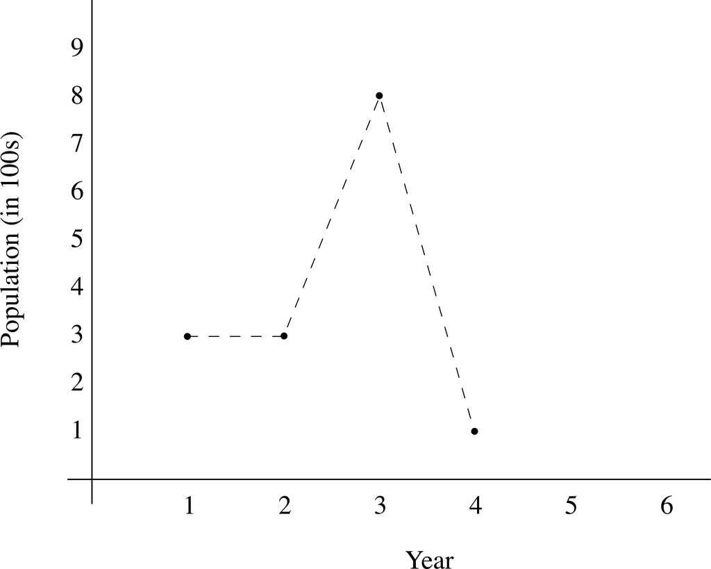

f. The population crash observed in year four is a result of over-grazing limited resources.

g. The population increase in year three followed an intensive effort to eliminate natural predators on the deer population.

h. The product of 3 and 9 is 27.

Source Unit 12 Study Questions question 3

| **Statement** | **A fact?** | **A scientific fact?** | **Kind of statement** |
| --- | --- | --- | --- |
| a. Columbus, 1492 | yes | no | historical fact from records |
| b. g is about 9.8 m/s² | yes | yes | repeatable measurement |
| c. Dante and Shakespeare greatest | no | no | value judgement |
| d. the measured fall times | yes | yes, as data | measurement report |
| e. one metre in one second | approximately | only conditionally | generalization from (d) |
| f. over-grazing caused the crash | not yet | no | interpretation (hypothesis) |
| g. predator removal before year 3 | yes, if recorded | no, by itself | historical record |
| h. 3 × 9 = 27 | yes | no | fact of reason |

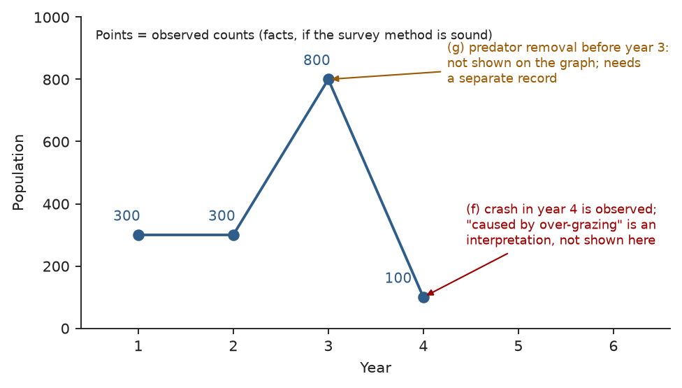

1. **The test applied.** Discussion 12.2 accepts as certain only facts of reason (logic and mathematics, true relative to their axioms) and facts of experience. A scientific fact is an empirical proposition that results from observation, is true as far as we can determine, is interpreted within a theory, and can be checked by others. Each statement in the table is judged against that.

2. **(a), (c) and (h).** Columbus reaching the Americas in 1492 is a well-documented historical fact, but it is a single past event known from records, not an observation that can be repeated, so it is not a scientific fact. Even its wording is theory-laden: "America" was named later. (c) is a value judgement, so it is neither: "greatest" has no agreed measure. (h) is a fact of reason, certain within arithmetic and needing no observation; that is why it is not a *scientific* fact.

3. **(b) and (d).** The acceleration due to gravity is a scientific fact: anyone can measure it, and "approximately" honestly states its precision. (d) reports measured data with uncertainties, so it is a scientific fact in the sense of data. But the report is flawed: it says "five trials" and lists four, and the distance fallen is missing. The diameter, 0.51 ± 0.002 cm, also gives the uncertainty to more decimal places than the value, which should be written 0.510 ± 0.002 cm.

4. **(e).** The four times average 1.025 s (standard deviation 0.13 s, so the uncertainty of the mean is about 0.06 s). Weighting each time by its stated uncertainty gives 0.98 ± 0.06 s. Each listed range includes 1.0 s. So "one metre in one second" is acceptable as an approximate scientific fact *only if* the missing distance was one metre, and it adds an assumption: that the sphere falls at a steady speed, so that the same rate holds for any metre.

5. **(f) and (g), from the graph.** The graph shows 300 deer in years 1 and 2, 800 in year 3 and 100 in year 4. The crash is an observed fact. That over-grazing *caused* it is an interpretation. The graph contains no food data, and disease, hunting or a hard winter could also explain it, so (f) is a hypothesis to test. (g) states only a sequence of events: if records show the predator programme, it is a historical fact. It does not show that removing predators caused the increase, and the graph does not show the programme at all.

Note*Course wording: Discussion 12.2 attributes these levels of certainty to Discussion 6.1, which is where facts of reason and facts of experience are defined.*

Note*Calculations: the mean, standard deviation and weighted mean were computed from the four listed times; the weighted mean uses weights of 1 ÷ (uncertainty)².*

U12-SG04Study guide

One of the first results Galileo reported after he began to study the planets with his telescope was that there were mountains on the moon. This “observation,” however, was not as straightforward as it might seem. The mountains Galileo claimed to have seen were his interpretation of the patterns of light and dark that he actually saw when focusing his telescope on the moon. (In his *Divine Comedy*, Dante interprets the same patterns of light and dark as resulting from differences in density of the lunar material.) Write a short essay (300-500 words) discussing the bottom-up and top-down aspects of this discovery. When do you think that mountains on the moon became a scientific fact?

Source Unit 12 Study Questions question 4

**Thesis.** Mountains on the Moon were not simply seen. Galileo saw patterns of light and dark and built a fact out of them by joining what came up from the eye (bottom-up) with what came down from his theories and training (top-down). The same patterns meant something else to Dante.

**What reached the eye.** Through his telescope, Galileo saw a rough and changing boundary between the lit and unlit parts of the Moon. Bright points appeared in the dark part near the boundary and grew and joined it as the sunlight advanced. Dark patches inside the lit part pointed away from the Sun and shrank as the Sun rose higher over them. These were his sensations and apprehensions, and anyone looking through the same instrument could share them.

**The bottom-up side.** From these particulars Galileo reasoned upward. On Earth, at sunrise, the peaks are lit before the valleys, and shadows are long when the Sun is low and short when it is high. The lunar patterns behaved in just this way, night after night. By induction and analogy he concluded that the Moon has mountains and valleys like the Earth. He even estimated their height from how far into the dark part their lit peaks appeared.

**The top-down side.** The interpretation also came from above. Galileo already doubted the Aristotelian belief that heavenly bodies are perfect, smooth spheres, so he was ready to see an Earth-like Moon (Derry p. 61). He had to trust that the telescope showed the Moon faithfully, which depends on a theory of geometric optics (Discussion 12.2). His training in drawing light and shadow helped him read shading as relief. Dante, working inside a different system of beliefs, saw the same patches as differences in the density of lunar matter. In Hanson's terms, both men may have had the same sensations but they had different perceptions.

**How the two sides met.** The mountain hypothesis made checkable predictions: shadows changing in a definite way through the month, and the same appearance through other telescopes. When these held, evidence and interpretation reinforced each other, the cycle described in Discussion 9.1.

**When did it become a scientific fact?** Not the moment Galileo looked, because then it was one man's interpretation through a new and distrusted instrument. In my view it became a scientific fact once the shadow observations could be repeated by others, once the theory of the telescope was accepted, and once the mountain hypothesis had out-predicted the alternatives, in the decades after 1610. That is when the six criteria of Discussion 12.2 were met: the claim rested on observation, was stated empirically, was confirmed as far as anyone could check, and no longer contradicted other accepted facts. Moon landings later confirmed it directly.

**Conclusion.** The discovery shows that facts are theory-laden without being arbitrary. Theory told Galileo what to look for, but only observation could decide between his reading and Dante's.

Note*Outside the readings: Galileo reported the Moon observations in Sidereus Nuncius (1610), including the bright points beyond the terminator (the boundary between light and dark) and his estimate of mountain heights from their distance beyond it. He had trained in drawing and perspective. His first telescopes magnified about 20 times.*

U12-SG05Study guide

List three cases from your own experience in which beliefs or expectations led you to accept as a fact something that you later found to be false.

Source Unit 12 Study Questions question 5

This question needs real incidents from your own life, so the answer below is a frame: each example is set in a job from your background, written as the kind of thing that happens there. Replace each one with a real memory, keeping the same steps: the belief, the "fact" it produced, and how the error showed up.

1. **Bank computer technician (Vietnam).** *Setting:* a workstation keeps freezing. Past experience says freezes like this usually mean failing hardware, so the technician "sees" a bad memory module and accepts that as the fact of the matter. A replacement does not help; the real cause is a faulty software update. The expectation chose the explanation before the evidence did.

2. **Kitchen helper, newly arrived in Canada (Regina).** *Setting:* a newcomer expects the workplace to work the way the old one did, and takes an instruction given casually as a request rather than a rule. Treating it as optional seems obviously right, until a supervisor explains that it was a food-safety requirement. The belief about how instructions are given decided what the words meant.

3. **Maintaining government applications (Saskatchewan).** *Setting:* a report arrives that an application is giving wrong results the day after a new release. Everyone expects the release to be to blame, so "the new code broke it" is treated as a fact. Testing shows the old code gives the same wrong result: the cause is bad data entered earlier. The timing made the expected cause look like an observation.

4. **The common pattern.** In each case the belief came first and the "fact" was read off from it, which is the theory-ladenness described in Discussion 12.2: "belief and prior knowledge influence what facts will be observed." The raw experience (a freeze, an instruction, wrong output) was real; the interpretation added to it was false.

5. **What corrected it.** In each case a test that could have come out either way exposed the error: swapping the part, asking, rerunning the old code. This is the course's last criterion in action: when facts conflict, we must find which belief or piece of prior knowledge to correct.

Note*The Final bank's own advice applies here: "Personal-example questions require your own experience; do not present an invented event as something that happened to you." The settings come from your background file; the incidents are illustrations, not things you have told me happened.*

U12-SG06Study guide

Identify each of the following measurement scales as nominal, ordinal, interval or ratio:

a. the energy of particles in high-energy particle accelerators is measured in *electron volts*. One electron volt is defined as the amount of energy acquired by an electron falling through a potential difference of one volt.

b. the *Millen Scale* of earthquake intensity defines the strength of earthquakes on the basis of the amount of damage which they do (shaking buildings, breaking glass, cracking ground, etc.).

c. interstellar distances are generally measured in *light-years*, where one light year is the distance travelled by light in empty space in one year.

d. stars are classified according to their *colour*.

Source Unit 12 Study Questions question 6

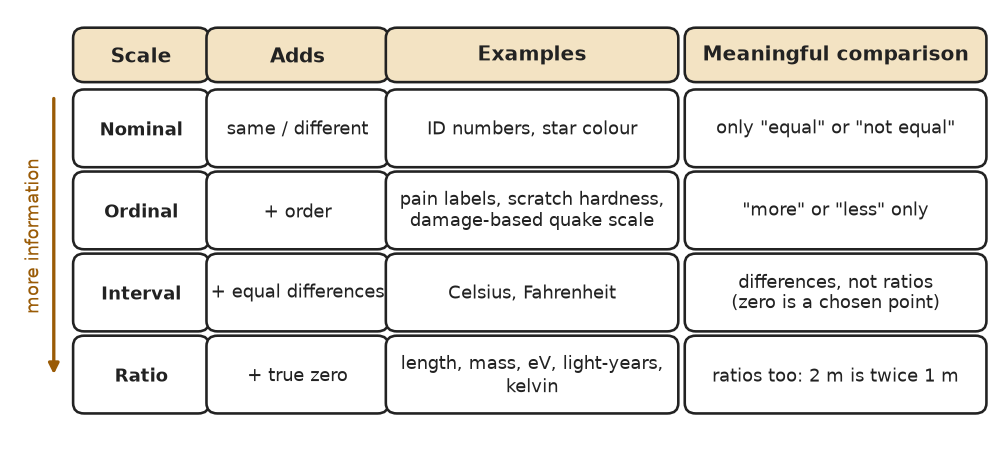

1. **a. Electron volts: ratio scale.** The electron volt is a standard unit of energy, defined by a fixed amount of energy, and zero energy is a true zero. So a 2 GeV particle has twice the energy of a 1 GeV particle, and ratios are meaningful.

2. **b. The damage-based earthquake scale: ordinal.** Earthquakes are ranked by their effects (shaking buildings, breaking glass, cracking ground). We can say one quake was stronger than another, but the steps between levels are not equal units of anything, so differences and ratios have no meaning.

3. **c. Light-years: ratio scale.** A light-year is a standard length (the distance light travels in empty space in a year), and zero distance is a true zero. A star 8 light-years away is twice as far as one 4 light-years away.

4. **d. Stars classified by colour: nominal scale.** Colour classes (red, yellow, white, blue) are categories with no number attached. Discussion 12.1 gives this very case: astronomers "classify stars by colour rather than wavelength of peak energy emission."

5. **Why the distinction matters.** The scale decides which arithmetic is meaningful. Ratio scales allow "twice as much," interval scales allow only differences, ordinal scales only order, and nominal scales only "same" or "different" (Discussions 11.2 and 12.1). If star colours were placed in order of surface temperature, the classification would become ordinal, so the answer depends on how the classes are used.

Note*Course wording: I could not find a "Millen Scale" of earthquake intensity. The standard damage-based scale is the Modified Mercalli intensity scale, which is ordinal for the same reason. The Richter magnitude, mentioned in Discussion 12.1, is a different, logarithmic measure.*

Note*Outside the readings: standard criterion. A ratio scale has a true zero (zero means none of the quantity), and an interval scale does not. The course distinguishes them only by the standard used (a unit or an interval).*

U12-SG07Study guide

The Fahrenheit and Celsius temperature scales share the same empirical basis and have the same standard of measure. They differ in the scaling assumptions which each makes. Explain.

Source Unit 12 Study Questions question 7

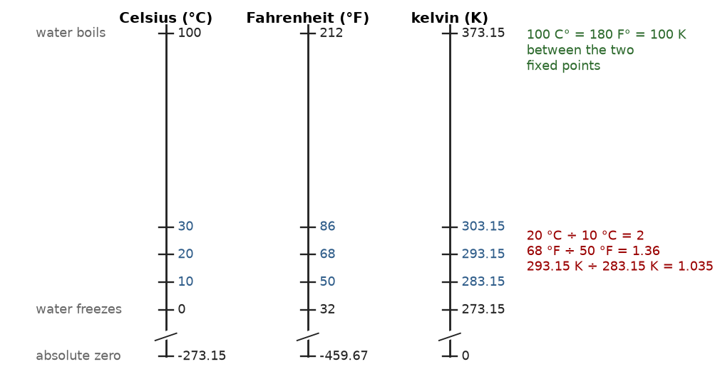

1. **Same empirical basis.** Both scales rest on the same procedure: a liquid-in-glass thermometer whose reading rises steadily with temperature, giving the comparative scale "A is hotter than B" (Discussion 12.1).

2. **Same standard of measure.** Both use the same interval as their standard: the interval between the freezing and boiling points of pure water. Defining a scale by a chosen interval is what makes both of them interval scales.

3. **Different scaling assumptions.** The scaling assumption fixes the form of the function that turns a reading into a number. Both scales assume a linear function, but they choose different constants. Celsius gives the freezing point 0 and the boiling point 100, so the interval holds 100 degrees. Fahrenheit gives them 32 and 212, so the same interval holds 180 degrees.

4. **The conversion.** Because both functions are linear over the same interval, one converts into the other: F = 9C/5 + 32. One Celsius degree equals 1.8 Fahrenheit degrees, and the two zeros sit at different temperatures. The scales agree at -40.

5. **What follows.** Neither zero means "no temperature"; each zero is chosen. So differences convert consistently between the scales, but ratios do not: 20 °C is not twice as hot as 10 °C, and 68 °F is not twice 50 °F either. Only an absolute scale (kelvin) has a true zero.

Note*Outside the readings: Fahrenheit originally fixed his scale with other reference points (a brine mixture and body temperature). Today the Fahrenheit scale is defined from the Celsius scale by this same conversion.*

U12-SG08Study guide

In Equation (1) of Discussion 11.1, the constant coefficients *a* and *b* are both less than or equal to one. Why would it not make sense to allow either of these values to be greater than one?

Source Unit 12 Study Questions question 8

1. **What Equation (1) says.** For a linear scale, the value for two things taken together is f(s ∧ s′) = a·f(s) + b·f(s′), with 0 ≤ a, b ≤ 1 (Discussion 12.1). For mass and length a = b = 1: the masses simply add. For temperature and pressure, a and b are less than 1 and add to 1: the result is a weighted average.

2. **For additive quantities, a > 1 would create something from nothing.** If a = b = 2, then 2 kg and 3 kg put together would weigh 10 kg. Putting things together would increase the quantity, which contradicts the conservation of mass and every balance measurement.

3. **It would also make the scale inconsistent.** With a = b = 2, combining 2 kg, 3 kg and 5 kg gives 30 kg if the first two are combined first, but 36 kg if the last two are combined first. The same collection of objects would have two values. With a = b = 1 the grouping makes no difference, so the measure is well defined.

4. **For equilibrium quantities, a > 1 would put the result outside the starting values.** When a hot and a cold body come into contact, heat flows from the hot one to the cold one until they reach a common temperature between the two. Since a + b = 1, a > 1 would make b negative, and the mixture could end up hotter than the hotter body. For example, a = 1.5 and b = -0.5 would turn water at 80 °C and 20 °C into water at 110 °C. That never happens.

5. **The general point.** The coefficients express how the physical combination works, so they cannot be chosen freely. A scale is only useful if its arithmetic matches what happens when things are actually combined; values greater than one would break that match.

Note*Course reference: the question says Equation (1) is in Discussion 11.1. It is in Discussion 12.1.*

Note*Calculations: the grouping results (30 kg and 36 kg) and the 110 °C example were checked by computer.*

U12-SG09Study guide

“Viscosity is a measure of a fluid’s resistance to flow.” The column below lists fluids from least to greatest on an ordinal scale based on viscosity. (A ball bearing dropped into a fluid with higher viscosity will fall more slowly than it would through a fluid with lower viscosity, and a fluid with higher viscosity will flow more slowly through a tube than a fluid with lower viscosity.) Devise a means of metricating this scale.

**Note:** You will need to come up with an experimental way of getting a numerical measure of viscosity and then construct either an interval or a ratio scale.

gasoline  
water  
salt water  
maple syrup  
crude oil  
tar

Source Unit 12 Study Questions question 9

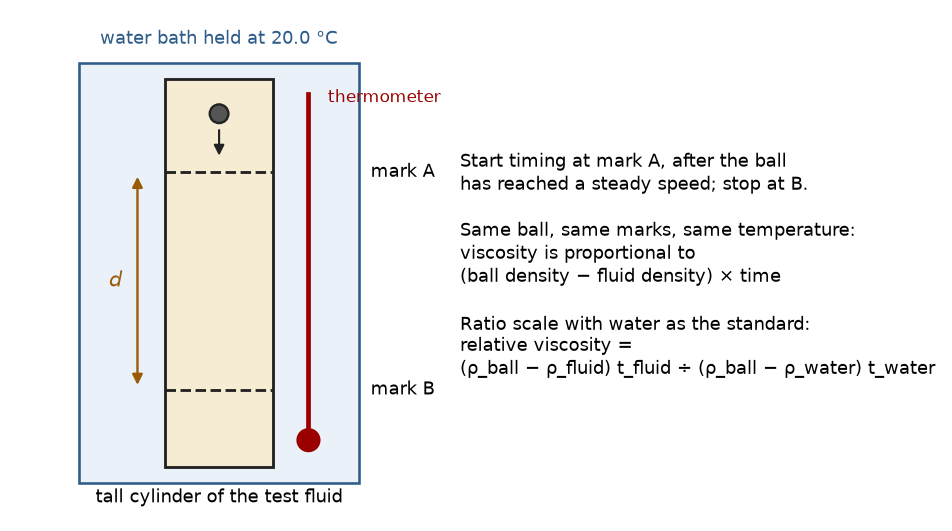

1. **Start from the ordinal scale.** The fluids are already ranked from least to most viscous: gasoline, water, salt water, maple syrup, crude oil, tar. Metrication means assigning numbers that keep this order and also say *by how much* one fluid exceeds another (Discussion 12.1).

2. **An empirical procedure: the falling ball.** Fill a tall cylinder with the fluid and hold it at one fixed temperature, say 20.0 °C, because viscosity changes strongly with temperature. Drop a small steel ball and time it between two marks a distance *d* apart, the upper mark far enough down that the ball is already falling at a steady speed. Repeat several times and average the times.

3. **A scaling assumption.** At a steady speed, a slower fall means more resistance. Assume viscosity is proportional to the time of fall, corrected for buoyancy: viscosity ∝ (ball density − fluid density) × time. This linear form is the scaling assumption, and it can be checked by using balls of different sizes.

4. **A standard of measure.** Take water at 20.0 °C as the standard and give it the value 1, as the course does for the heat capacity of water. Then relative viscosity = (ρ_ball − ρ_fluid) × t_fluid ÷ ((ρ_ball − ρ_water) × t_water). Zero means no resistance to flow at all, so this is a ratio scale: a fluid with value 200 resists flow 200 times as much as water.

5. **Checks and range.** The numbers must reproduce the original order, which tests the method. Tar is far too viscous for a ball to fall through in a reasonable time, and gasoline too thin to time well, so the scale is extended with a heavier or lighter ball (or a tube that the fluid flows through), calibrated on fluids measured both ways. Report each value with its uncertainty from the repeated trials.

Note*Outside the readings: the proportionality in point 3 comes from Stokes' law for a small sphere falling slowly at a steady speed. Water at 20 °C has a viscosity of about 1.0 millipascal-second; maple syrup and crude oils are hundreds or thousands of times more viscous, and crude oils vary so widely that some are thinner than syrup.*

U12-SG10Study guide

In Discussion 12.3 the suggestion was made that Galileo used musical timing to measure his inclined plane experiments. Doing this would provide data in terms of distance traveled in equal units of time. On the other hand, timing his experiments with a water clock would provide ratios of time elapsed for varying units of distance. Write a short essay comparing these two forms of data presentation.

Source Unit 12 Study Questions question 10

**Thesis.** Musical timing and the water clock give two different presentations of the same motion. One fixes the times and measures distances; the other fixes the distances and measures times. Each shows the law in a different light and has different strengths as evidence.

**Distance in equal times (musical timing).** Galileo could set gut strings across the groove and move them until the ball's clicks fell exactly on a steady beat. A trained musician can judge equal beats very accurately (Discussion 12.3). The data are then a list of positions at beat 1, 2, 3, 4: if the law holds, they lie at 1, 4, 9 and 16 units from the start. The gaps between strings are 1, 3, 5 and 7, the odd numbers, and the gaps grow by the same amount, 2, at every beat.

**What this presentation shows.** Equal time steps make the change in speed visible directly. The average speed in each beat is proportional to the gap, so it rises by equal amounts: the acceleration is constant. The method also needs no unit of time: one beat is the unit.

**Time for chosen distances (the water clock).** Galileo let water run from a vessel during each descent and weighed it. The weights gave *ratios* of times, never times in seconds. The data are then a list of chosen distances (the whole groove, a half, a quarter) with the time for each, as a fraction of the time for the whole length. The law predicts that a quarter of the length takes half the time, as Galileo reported, and that half the length takes about 0.707 of the time.

**What this presentation shows.** The water clock tests the law directly in the form Galileo stated it: "the spaces traversed were to each other as the squares of the times." It works for any distances, so it can test many points and many slopes. Ratios are enough because the law is a proportion, and errors common to every run, such as the flow rate of the jet, cancel when weights are compared.

**Comparing them as evidence.** The musical method is more precise but private. It depends on one person's ear, and its record is a set of string positions that others must take on trust. The water clock is less direct but public: weighed water can be shown, repeated and checked by anyone, which is why it suited a published, persuasive account. The musical data favour discovery, seeing a pattern in differences; the water-clock data favour proof, checking a stated law.

**Conclusion.** The two presentations are mathematically equivalent: positions 1, 4, 9, 16 at equal beats and time ratios 1:2 for a quarter-to-whole distance express the same rule, distance proportional to the square of time. Using both, Galileo combined a sensitive way of finding the law with a convincing, public way of presenting it.

Note*Outside the readings: Stillman Drake (cited in Discussion 12.3) argued from Galileo's notebooks that he first found the law using the gut-string method.*

### Learning objective questions7

U12-OBJ01Objective

explain the difference between facts of experience, facts of reason and scientific facts.

Source Unit 12 Overview objective 1

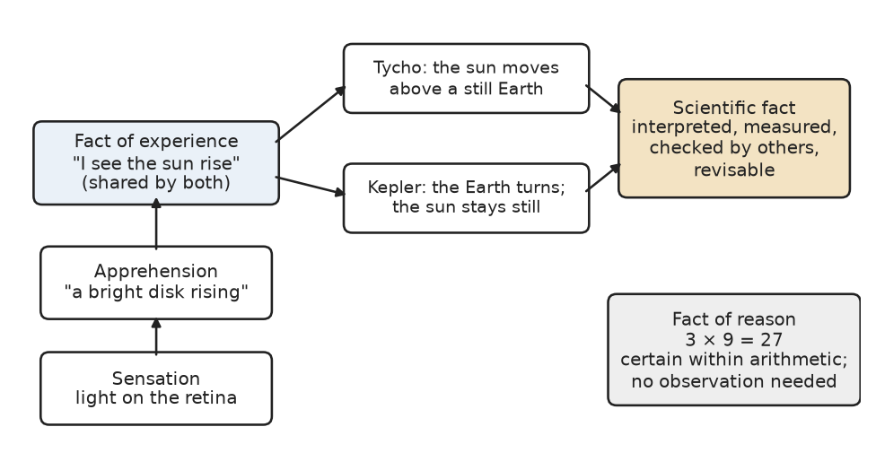

1. **Facts of reason.** These are truths that hold by definition or by valid deduction, such as 3 × 9 = 27 or "a bachelor is unmarried." They are certain, but only relative to the axioms and definitions of their system, and they say nothing about the world by themselves (Discussions 6.1 and 12.2).

2. **Facts of experience.** That I am having an experience at a given moment cannot be doubted, even if its cause can: I cannot deny that I see a bright disk rising. If we assume that healthy people's nervous systems respond alike, others standing beside me share the same immediate fact. Tycho and Kepler watching a sunrise share it.

3. **Scientific facts.** A scientific fact is an empirical proposition produced by observation or experiment, interpreted inside a theory, and checked by others. "The Earth turns, so the Sun appears to rise" is a scientific fact; "the Sun rises" is only an empirical one. Discussion 12.2's example is the law of fall, d = 4.9t² (in metres and seconds), obtained by fitting a curve to measured points.

4. **How they differ in certainty.** Facts of reason are certain within their system, and facts of experience are certain as experiences. Scientific facts are neither: they are relative to assumptions (about instruments, units and theory), they hold within a margin of error, and they can be revised.

5. **How they connect.** Scientific facts are built from facts of experience by interpretation, and they often borrow facts of reason (the mathematics of curve fitting) to state their results. The six criteria of Discussion 12.2 describe the empirical kind: based on observation, stated empirically, true as far as we can tell, free of contradiction with other facts, influenced by prior belief, and corrected when facts conflict.

U12-OBJ02Objective

describe what is meant by the claim that all facts are “theory-laden.”

Source Unit 12 Overview objective 2

1. **Meaning.** To say that facts are "theory-laden" is to say that what we report as a fact already includes interpretation by a conceptual framework. There are no "raw" facts in science; even a simple observation statement uses concepts drawn from theories (Discussion 12.2; Derry p. 199).

2. **Hanson's example.** Tycho and Kepler watch the same sunrise. Tycho sees the Sun move up past a fixed horizon; Kepler sees the horizon turn down away from a fixed Sun. Hanson says they see different things, because "seeing" includes how a sensation fits into a person's worldview. Like the Necker cube, the same input supports different perceptions (Discussions 9.1 and 12.2).

3. **Instruments carry theory.** Galileo's moons of Jupiter were facts only if one accepted the theory of geometric optics on which the telescope depends. Today's facts from electron microscopes and particle colliders rest on far more theory (Discussion 12.2).

4. **Even simple measurements carry theory.** Points on a graph of distance against time assume reliable clocks and metre sticks, a theory of distance and time measurement, and the Cartesian coordinate system. With a different standard of time, such as someone's pulse, the law of fall would not come out the same (Discussion 12.2, footnote 260).

5. **What it does not mean.** Theory-ladenness does not make facts arbitrary or turn science into opinion. Facts remain constrained by observation, and the two observers can test their views against further evidence, as Kepler's view eventually won. It means that facts are valid only within assumptions, and must be held open to revision or reinterpretation.

U12-OBJ03Objective

discuss the way scientific facts are constructed in the interplay of theory and experiment.

Source Unit 12 Overview objective 3

1. **The cycle.** Discussion 12.2 describes facts being built in a loop. From particular observations we obtain, by induction or abduction, a conjectured "fact." Assuming it, we deduce further consequences. If observation or experiment confirms them, our confidence in the fact grows. This is the bottom-up and top-down cycle of Discussion 9.1.

2. **A worked example.** Objects dropped near the Earth are timed at measured distances. Plotted on Cartesian axes, the points follow a curve, and a least-squares fit gives d = 4.9t² (metres, seconds) with small random scatter. The scientific fact combines experimental facts (the points) with a mathematical fact (the fitting procedure) inside a theory of measurement (Figure 12.2.1).

3. **Theory chooses the experiment.** Scientific facts are not any observations at all; they come from experiments done for theoretical reasons. Galileo built an inclined plane and a water clock because he wanted to test whether falling bodies accelerate uniformly (Discussion 12.3).

4. **Instruments and theory grow together.** The thermometer turned "hotter" and "colder" into a comparative scale and then, with the freezing and boiling points as a standard, into an interval scale. Having the scale made the theory of heat possible, and the theory in turn reshaped the scale into the absolute temperature of thermodynamics (Discussion 12.1, footnote 254).

5. **Conflict drives revision.** When two facts contradict each other and we trust both observations, something in our beliefs or prior knowledge must change (the sixth criterion). Theoretical entities posited along the way may prove real (germs, radio waves, Neptune) or not (caloric), so the process keeps facts open to revision.

U12-OBJ04Objective

discuss the relation between relational, metric and linear scales.

Source Unit 12 Overview objective 4

1. **Relational (comparative) scales.** An empirical procedure puts things in order. In the scratch test, mineral A is harder than B if A scratches B but B does not scratch A. The order must be transitive: if A precedes B and B precedes C, then A precedes C. This gives a non-numerical, ordinal ranking (Discussion 12.1).

2. **Metric scales.** Metrication assigns each thing a real number by a function f_v that respects the order: things that are the same on the scale get the same number, and if s precedes s′ then f_v(s) < f_v(s′). Now we can say not only that A precedes B but by how much, and compare that amount with other gaps.

3. **How the metric is fixed.** Three choices define the function: the empirical procedure behind the comparative scale, a scaling assumption that sets the form of the function, and a standard of measure. A chosen interval as standard gives an interval scale; a standard unit gives a ratio scale.

4. **Linear scales.** A linear scale is a metric scale whose function is chosen to be linear. It has a simple combining rule, Equation (1): the value for two things together is a·f(s) + b·f(s′), with a and b between 0 and 1. Mass and temperature are measured on linear scales.

5. **The relation.** Every metric scale starts from a relational one, and every linear scale is a metric scale, but not every metric scale is linear: the Richter scale of earthquake magnitude is logarithmic. The thermometer shows the whole progression, from cold-cool-warm-hot, to "A is hotter than B," to a calibrated linear interval scale.

U12-OBJ05Objective

describe the difference between linear scales for mass and distance on the one hand, and linear scales for temperature and pressure on the other.

Source Unit 12 Overview objective 5

1. **The common form.** On a linear scale, combining two things gives f(s ∧ s′) = a·f(s) + b·f(s′) (Discussion 12.1, Equation 1). The two families differ in their coefficients and in what "combining" means.

2. **Mass and distance: a = b = 1.** Putting two masses on the same pan, or two lengths end to end, simply adds their values: 2 kg and 3 kg make 5 kg. Volume and electric charge behave the same way. These quantities are additive.

3. **Temperature and pressure: a and b less than 1.** "Combining" means bringing two bodies into contact until they reach equilibrium. The result is a weighted average, with a + b = 1, so it lies between the two starting values. Water at 20 °C and 80 °C does not make water at 100 °C. For two identical bodies a = b = 1/2, by the principle of sufficient reason.

4. **The weights depend on the materials.** For different materials the weights are set by their heat capacities: in the course's example, 1 kg of water at 0 °C and 1 kg of mercury at 100 °C settle at about 3 °C, because water's heat capacity is much larger. A second variable, heat capacity, has to be introduced and measured. For gases at one temperature, pressures combine weighted by volume: 2 L at 100 kPa joined to 1 L at 300 kPa give about 167 kPa.

5. **Interval against ratio.** Mass and distance have standard units and a true zero, so "twice as much" is meaningful. The everyday temperature scales are interval scales built on a chosen interval (freezing to boiling), so differences are meaningful but ratios are not, until temperature is measured on the absolute scale.

Note*Outside the readings: the pressure example assumes ideal gases at the same, constant temperature (Boyle's law applied to each sample).*

U12-OBJ06Objective

describe the value of metric measurement scales in science.

Source Unit 12 Overview objective 6

1. **Finer distinctions.** Metric scales allow more refined distinctions than types or rankings. A ranking says that syrup is thicker than water; a metric says how much thicker (Discussion 12.1).

2. **Meaningful relative differences.** Numbers give precise meaning to comparisons such as "twice as heavy" or "ten degrees warmer," and they make comparison clear: Derry notes that "heavy" means nothing until we have a number to compare (Derry pp. 107-108).

3. **Discovery of general laws.** Laws relate measured variables. Galileo's law that distance is proportional to the square of the time could only be found once distance and time were measured (Discussion 12.3).

4. **Mathematical theories and predictions.** Once variables are numbers, mathematical relations among them can be manipulated to predict new behaviour. Quantitative agreement between a predicted and a measured number is much stronger evidence than qualitative agreement; a small quantitative mismatch in black-body radiation started quantum theory (Derry p. 108).

5. **A foundation for abstract concepts.** The temperature of modern thermodynamics is a highly abstract generalization of the reading on a mercury thermometer, and it extends from absolute zero to hundreds of millions of degrees, far beyond any thermometer (Discussion 12.1). Measurement also lets uncertainty be stated, so we know how far to trust a result.

U12-OBJ07Objective

discuss the experimental setup Galileo used to study falling bodies.

Source Unit 12 Overview objective 7

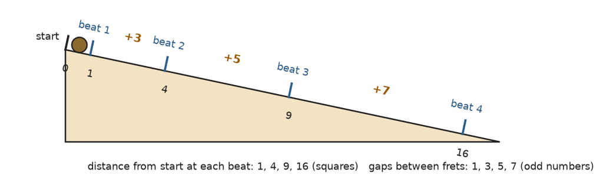

1. **The apparatus.** A wooden board about 12 cubits long had a straight, smooth, polished groove cut along its edge. One end was raised one or two cubits, and a hard, smooth, round bronze ball was rolled down the groove (Discussion 12.3, quoting *Two New Sciences*, 1638).

2. **Why a slope instead of a drop.** Galileo had no accurate clocks. A free fall is too fast to time, but a ball on a gentle slope (inclinations between 12:1 and 6:1) takes long enough to measure. The slope "dilutes" the motion without changing its form.

3. **Timing.** Water ran through a thin pipe from a large raised vessel into a glass during each descent and was weighed on an accurate balance. The weights gave the differences and ratios of the times, not times in seconds. Galileo also probably first timed the ball by ear, placing gut strings so that the ball's clicks fell on equal musical beats.

4. **Procedure and results.** He repeated each run until two timings never differed by more than a tenth of a pulse-beat, then compared the full length with fractions of it. A quarter of the length took exactly half the time. Over a hundred trials, at every inclination, distances were as the squares of the times.

5. **Linking the slope to free fall.** He assumed that motion can be split into horizontal and vertical parts and that the force acts only vertically (on a level plane the ball does not start moving). Because the square law held at every slope, he extended it to the steepest "slope" of all, a vertical drop, concluding that falling bodies accelerate uniformly.

### Lists and concept recall12

U12-R01Recall

Explain this topic from the assigned readings: the three kinds of facts: facts of reason, facts of experience and scientific facts. Give an example or explain its significance in this unit.

Source Three kinds of facts (Discussion 12.2, building on Discussion 6.1)

1. **Two kinds of certain knowledge.** Discussion 12.2, building on Discussion 6.1, says that the only things we can know for certain are "the logical validity of formal reasoning (the truths of reason) and the fact that we are having an experience at a given moment (the truths of experience)" (Discussion 12.2). Scientific facts are a third kind, built on facts of experience but not certain in the same way.

| Kind | What it is | Certainty | Example |
| --- | --- | --- | --- |
| **Facts of reason** (truths of reason) | The logical validity of formal reasoning; true logical and mathematical propositions, necessary by definition and known *a priori* | Certain, but only relative to an axiomatic system: valid deduction from consistent premises gives a valid conclusion, whose truth still depends on the premises | 3 x 9 = 27 (Unit 12 Study Question 3); a bachelor is an unmarried man |
| **Facts of experience** (truths of experience, empirical facts) | That we are having an experience at a given moment; a truth one cannot deny without denying one's own experience, known *a posteriori* | Certain that the experience occurs; its content, what it means and what it says about an external reality stay open to question | Tycho and Kepler both watch the sunrise and experience the same immediate fact |
| **Scientific facts** | Facts of experience located in a conceptual web of theory and paradigmatic assumptions; the results of observations and experiments done for theoretical and philosophical reasons | Relative, theory-laden, valid only within limits and always open to revision | d = (4.9 m/sec<sup>2</sup>) t<sup>2</sup> for a falling body |

2. **Key line.** If all healthy human beings have nervous systems that respond similarly to sensory input, Tycho and Kepler, "experiencing the same input as they watch a sunrise, are experiencing the same immediate fact. But while the sunrise is an empirical fact, it is not a scientific fact" (Discussion 12.2).

3. **Example.** Following Norwood Russell Hanson, Tycho sees the sun rise above the horizon as it moves about a fixed Earth, while Kepler sees a stationary, fixed sun appear to rise as the Earth turns (rotates) beneath it. Both do the same thing and have the same fact of experience, but each locates it in a different conceptual web: they "share the same sensations and apprehensions, but differ in their perceptions" (Discussion 12.2). Only inside such a web does the sunrise become a scientific fact. The falling-body law is a scientific fact in the same way: it rests on measured data plus the theory of distance and time measurement.

4. **Significance.** Absolute knowledge exists, but "it is not the sort of knowledge that can be called scientific knowledge" (Discussion 6.1): a reasoned statement depends on its assumptions, and an experiential statement is relative to the person who reports it. So scientific facts are relative rather than absolute, and the key line separates what we experience from what science claims about it. Explaining this difference is the first objective of Unit 12 (Unit 12 Overview).

U12-R02Recall

Explain this topic from the assigned readings: the dictionary definition of a fact and the three problems of certainty, objective verification and demonstrable existence that it raises. Give an example or explain its significance in this unit.

Source Dictionary definition of "fact" and its three problems (Discussion 12.2)

1. **The definition.** The American Heritage Dictionary defines a fact as "something known with certainty, something that has been objectively verified, something having real, demonstrable existence" (Discussion 12.2).

2. **Three problems.** "On the basis of Discussion 6.1, it should be clear that each of these three definitions has philosophical problems" (Discussion 12.2). Each part raises its own philosophical question.

[output not shown]

3. **Example.** Galileo claimed that his telescope showed four moons circling Jupiter. The claim depended on accepting the telescope and the theory of geometric optics behind it; a skeptic who rejected that theory, or who knew of the illusions magicians produced with lenses, could deny that the moons had been objectively verified or shown to exist (Discussion 12.2).

4. **Significance.** The dictionary sense of fact is too absolute for science. Discussion 12.2 replaces it with relative, theory-laden scientific facts that are constructed in the interplay of theory and experiment, judged by six criteria and "always be considered as subject to further revision or reinterpretation" (Discussion 12.2).

U12-R03Recall

Explain this topic from the assigned readings: theory-laden facts, including Hanson's view of seeing, instrumentalism and the theory behind instruments and the falling-body law. Give an example or explain its significance in this unit.

Source Facts are theory-laden (Discussion 12.2)

1. **The claim.** "It is generally agreed that in science, facts are relative rather than absolute." They are theory-laden "both in their nature and their significance" (Discussion 12.2).

2. **Hanson's seeing.** The philosopher of science Norwood Russell Hanson holds that Tycho and Kepler see different things at sunrise, and denies that the difference is only a matter of interpretation. His "seeing" includes the way sensory awareness is embedded in a person's worldview, so what one sees depends on the worldview one has learned. His example is the **Necker cube**: one two-dimensional image does not carry enough information for a single three-dimensional reading, so it supports two (a cube seen from slightly above or from slightly below) (Discussions 12.2 and 9.1).

3. **Fact and fiction.** The word *fact* comes from the Latin *factum*, the past participle of *facere*, "to produce"; *fiction* comes from *fictum*, the past participle of *fingere*, "to fashion or form" (Discussion 12.2).

4. **Instrumentalism.** On the instrumentalist position, scientific facts are "convenient fictions that we make up in order to explain the sensations that result when we do something" (Discussion 12.2). This view is "useful as far as it goes", but some posited entities turn out real once we extend the limits of our experience: **germs** (seen only after the microscope existed), **radio waves**, the planets **Uranus and Neptune** and a great variety of **elementary particles**. Others turn out not to exist, such as **caloric**, the subtle heat fluid. The successes raise again the question of the "unnatural effectiveness of science in fitting the world" (Discussion 12.2).

5. **Instruments carry theory.** Galileo's claim of four moons of Jupiter depended on accepting the telescope, whose design and operation rest on the theory of geometric optics. Magicians of the day were known for illusions made with lenses, so a skeptic could think Galileo saw an illusion, and the Aristotelian professors refused even to look through his telescope. Today the scanning electron microscope and the CERN collider that discovered the Higgs boson rest on "massive amounts of theorizing"; without that theory there is no basis for accepting their observations (Discussion 12.2).

6. **Example: the falling-body law.** Plotting distance fallen against time and fitting the points by least squares gives d = (4.9 m/sec<sup>2</sup>) t<sup>2</sup>, so about 4.9 m after 1 s, 19.6 m after 2 s and 44.1 m after 3 s. The data already assume distance, time, the fidelity of clocks and metre sticks, and Cartesian coordinates, so the fact is theory-laden (with a pulse beat of the Dalai Lama as the time standard, the equation would not hold). Scientists accept it pragmatically because it works, but facts are valid only within certain limits and stay open to revision (Discussion 12.2).

7. **Significance.** Scientific facts are not the result of arbitrary observation: they come from observations and experiments "undertaken for specific reasons that are theoretically and philosophically based" (Discussion 12.2). This matters before deciding which facts to accept, or judging others by the facts they accept or reject.

U12-R04Recall

Explain this topic from the assigned readings: the six course criteria for scientific facts. Give an example or explain its significance in this unit.

Source Six criteria for scientific facts (Discussion 12.2)

1. **The checklist.** Discussion 12.2 gives "six criteria relating to our statement of what we consider to be scientific (as against rational or mathematical) facts" (Discussion 12.2).

[output not shown]

2. **Example.** Applied to Unit 12 Study Question 3: the statement that the acceleration due to gravity at the surface of the earth is approximately 9.8 m/sec<sup>2</sup> meets the criteria (it comes from measurement, is an empirical proposition and has been checked). "The product of 3 and 9 is 27" is a fact of reason, not a scientific fact, because it does not rest on observation. "Dante and Shakespeare are the greatest European writers of all time" is a judgement of value that cannot be shown to be empirically true (Unit 12 Study Questions).

3. **Example of criterion 6.** Tycho and Kepler share the same observation of the sunrise but hold different beliefs about the relation between sun and Earth. Removing the conflict between their accounts means changing a belief about that relation, not denying what either of them saw (Discussion 12.2).

4. **Significance.** Criteria 1 to 3 tie scientific facts to experience, criterion 4 rests on the principle of non-contradiction (Discussion 9.1), and criteria 5 and 6 build in theory-ladenness and the duty to revise. Together they make scientific facts relative and correctable rather than certain, which is the view of fact that Unit 12 develops.

U12-R05Recall

Explain this topic from the assigned readings: the construction of scientific facts from the polarities of reasoning, in the interplay of theory and experiment. Give an example or explain its significance in this unit.

Source How scientific facts are constructed (Discussion 12.2, using the polarities of 9.1)

1. **The polarities.** Discussion 12.2 says that "the tables of dichotomies given in Discussions 9.1 and 11.2" also relate to the construction of scientific facts. Discussion 9.1 pairs top-down with bottom-up, deduction with induction/abduction, analysis with synthesis, and functional with structural explanation; abduction is "inference to the best explanation" (Discussion 9.1).

2. **Four steps.** Scientific facts are built in a cycle of inference and test (Discussion 12.2).

| Step | What happens | Polarity used |
| --- | --- | --- |
| 1 | By **induction and/or abduction** from particular examples we obtain conjectured facts. | Bottom-up: induction/abduction |
| 2 | Assuming these are indeed facts, we **deduce** certain other consequences for future experience. | Top-down: deduction |
| 3 | If the consequences occur when the appropriate observations or experiments are conducted, our confidence in the facts grows. | Test against experience |
| 4 | The observations and experiments are undertaken for specific, theoretically and philosophically based reasons, so scientific facts are never the result of arbitrary observation. | Theory guides what is observed |

3. **The immediate empirical fact.** "The immediate empirical facts, however, are just that under certain conditions, certain results follow": for example, "if certain measurements are made, certain results will be obtained, within a margin of experimental error", or a set of observed objects can be grouped under a particular taxonomy (Discussion 12.2). What such facts mean is a further question that theory answers.

4. **Example.** Dropping objects and measuring distance against time gives points that a least squares fit matches to d = (4.9 m/sec<sup>2</sup>) t<sup>2</sup>. Taking this as a fact, we deduce that a body falling for 2 s should cover 4.9 x 2<sup>2</sup> = 19.6 m; when new drops agree, within experimental error, confidence grows. "By combining a graphical representation of experimental facts together with a particular mathematical fact we have obtained a scientific fact" (Discussion 12.2). This is the pattern of the hypothetico-deductive method: begin with data, generate a hypothesis by induction or abduction, then deduce consequences that can be tested (Discussion 9.1).

5. **Significance.** The "facts" of immediate sensation "are molded and shaped to yield the facts of science", a process that "involves theory as well as observation and experiment" (Discussion 12.2). Unit 12 asks students to discuss how scientific facts are constructed in this interplay of theory and experiment (Unit 12 Overview), and to remember it before deciding which facts to accept or judging others by the facts they accept or reject.

U12-R06Recall

Explain this topic from the assigned readings: the four measurement scales: nominal, ordinal, interval or ratio. Give an example or explain its significance in this unit.

Source The four scales (Discussion 12.1 and Discussion 11.2)

1. **Four kinds of scale.** Discussion 11.2 introduces four kinds of scale on which the attributes of a variable can be evaluated, and Discussion 12.1 restates them for measurement (Discussions 11.2 and 12.1).

| Scale | Definition | Example |
| --- | --- | --- |
| **Nominal** | Measures only qualitative differences; a classification into categories that are exhaustive and mutually exclusive for the variable | Colours: we do not say a tree is 5200 angstroms, and even astronomers classify stars by colour rather than by wavelength of peak energy emission |
| **Ordinal** | Rank orders a linear sequence: a comparative, non-numeric relational order that must be transitive | Mineral hardness by the scratch test (A is harder than B if A scratches B but B does not scratch A); lining up by height; cold, cool, warm, hot |
| **Interval** | A uniform numerical scale with a standard interval | Celsius temperature: 100 degrees between the freezing and boiling points of pure water |
| **Ratio** | A uniform numerical scale with a standard unit for comparison (so zero means none of the quantity) | Mass in kilograms (10 kg means 10 standard kilograms would balance the object on a fair scale); length in metres |

2. **Measurement proper.** "Measurement, as we are using the term, is based on interval scales or ratio scales" (Discussion 12.1). Nominal scales are classifications, and an ordinal scale gives only a comparative measure. Each scale adds information to the one before it: classification is a tool of qualitative evaluation, measurement of quantitative evaluation.

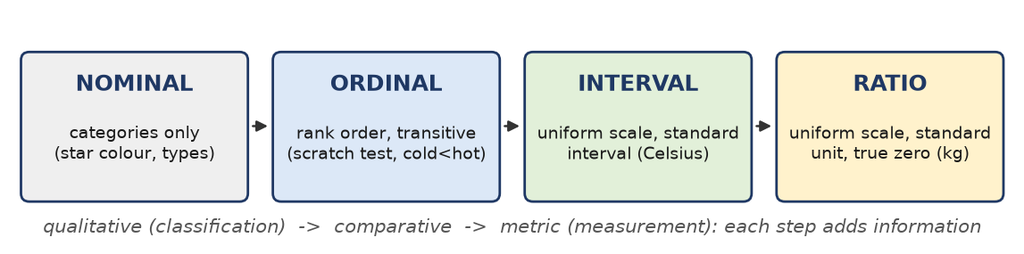

4. **Significance.** Classification and measurement "are the basic conditions for doing science" (Discussion 12.1). To reach a numerical measure we begin with a comparative (ordinal) scale and metricize it; measurement adds precision and "provides a means for evaluating the accuracy of predictions" (Discussion 12.1). Knowing which kind of scale a variable uses tells us which comparisons its numbers support.

U12-R07Recall

Explain this topic from the assigned readings: relational, metric and linear scales, and how metrication turns a relational scale into a metric scale and then a linear scale. Give an example or explain its significance in this unit.

Source From a relational scale to a metric scale to a linear scale (Discussion 12.1)

1. **Relational (comparative, ordinal) scale.** Ranking the entities of a set S on a variable v (for example minerals by hardness) gives a **partial order**: "The order is partial because two entities may have the same value" (Discussion 12.1). The order must be **transitive**: if A precedes B and B precedes C, then A precedes C. A round robin tournament can fail this, since team A may beat B, B beat C and C beat A (Discussion 12.1).

2. **Metric scale (metrication).** Metrication means introducing a numerical measure of distance, so we can say not only that A precedes B but by how much, and compare that amount with the distance by which B precedes C. We define a function f<sub>v</sub> from S to the real numbers R, giving each s its value f<sub>v</sub>(s), such that equal entities get equal values and if s precedes s', then f<sub>v</sub>(s) < f<sub>v</sub>(s') (Discussion 12.1).

3. **What fixes the measuring function.** "In practice, the function f v is defined by the empirical procedure used to define the comparative scale, by a scaling assumption, and by the choice of a standard of measure" (Discussion 12.1).

| Ingredient | What it decides | Examples |
| --- | --- | --- |
| **Empirical procedure** | Defines the comparison itself | Scratch test for hardness; reading an uncalibrated thermometer |
| **Scaling assumption** | The form of f<sub>v</sub>: it must be increasing (positive slope everywhere); beyond that we choose what is convenient | Linear for mass and temperature; logarithmic for the Richter scale of earthquake magnitudes |
| **Standard of measure** | Whether the result is an interval or a ratio scale | A chosen interval (freezing to boiling of water) gives an **interval scale**; a comparative standard (the standard kilogram) gives a **ratio scale** |

4. **Linear scale.** A linear scale has the additive property f<sub>v</sub>(s ∧ s') = a f<sub>v</sub>(s) + b f<sub>v</sub>(s'), with 0 ≤ a, b ≤ 1 (Equation (1)), where s ∧ s' means s and s' "taken together"; for mass that is the sum of the masses, for temperature it is the equilibrium reached when s and s' are brought into contact (Discussion 12.1).

5. **Example.** Temperature runs through all three steps: felt warmth (cold, cool, warm, hot) is ordinal; the uncalibrated thermometer gives comparative judgements; choosing the freezing-to-boiling interval of water as the standard, with a linear scaling assumption, gives an interval scale. Fahrenheit and Celsius share the same empirical basis and standard of measure but differ in their scaling assumptions (Unit 12 Study Questions): Celsius assigns 0 and 100 to the two fixed points and Fahrenheit 32 and 212, so F = 1.8 C + 32 (0 °C = 32 °F, 100 °C = 212 °F).

6. **Significance.** Metrication is what lets science state general laws as functional relations between variables. Unit 12 asks students to discuss the relation between relational, metric and linear scales (Unit 12 Overview); the choices of procedure, scaling assumption and standard show that even a number on a scale is partly a human construction.

U12-R08Recall

Explain this topic from the assigned readings: the two kinds of linear scales, additive and equilibrium, and the heat capacity example. Give an example or explain its significance in this unit.

Source Two kinds of linear scale (Discussion 12.1)

1. **Two kinds.** Linear scales obey f<sub>v</sub>(s ∧ s') = a f<sub>v</sub>(s) + b f<sub>v</sub>(s'), 0 ≤ a, b ≤ 1 (Equation (1)), and fall into two kinds depending on the coefficients (Discussion 12.1).

| Kind | Coefficients | Quantities | What "taken together" means |
| --- | --- | --- | --- |
| **Additive** | a = b = 1 | Mass, length, volume, electric charge | The values simply add: s ∧ s' is the sum of the masses (1 kg + 1 kg = 2 kg) |
| **Equilibrium** | a, b < 1 | Temperature, pressure | Bring s and s' into contact and let them reach an equilibrium value; a and b depend on the specific natures of the entities combined |

2. **Sufficient reason.** If s and s' are identical except for their differing values on v, then a = b = 1/2, from the principle of sufficient reason (Discussion 12.1). For example, 1 kg of water at 0 °C mixed with 1 kg of water at 100 °C ends at 1/2 x 0 + 1/2 x 100 = 50 °C.

4. **A new ratio scale.** Taking C<sub>w</sub> = 1 as the standard "arbitrarily" (Discussion 12.1) creates a ratio scale for heat capacity. Solving for the mercury gives C<sub>m</sub> = (T<sub>e</sub> - T<sub>w</sub>)/(T<sub>m</sub> - T<sub>e</sub>) = 3/97 ≈ 0.031, about 1/32 of water's. (The course prints Equations (2) and (5) with T<sub>w</sub> - T<sub>e</sub> in place of T<sub>e</sub> - T<sub>w</sub>; that sign would make C<sub>m</sub> negative, so the form used here is the one consistent with Equation (3).) Conversely, with mercury's heat capacity about 1/30 of water's, T<sub>e</sub> = (1/30 x 100)/(1 + 1/30) = 100/31 ≈ 3.2 °C, with a ≈ 0.032 and b ≈ 0.968.

5. **Example.** The procedure for measuring the heat capacity of any material is the same: take equal masses of the material and of water, heat them to different temperatures, mix them, measure the equilibrium temperature and solve for C<sub>m</sub> (Discussion 12.1).

6. **Significance.** Additive quantities can be measured by simply counting standard units, but equilibrium quantities like temperature and pressure need a principle for combining values, and that principle introduces new variables such as heat capacity. Describing this difference between linear scales for mass and distance and those for temperature and pressure is a Unit 12 objective (Unit 12 Overview).

U12-R09Recall

Explain this topic from the assigned readings: the reasons scientists seek metric measurement scales. Give an example or explain its significance in this unit.

Source Why scientists seek metric scales (Discussion 12.1)

1. **Five reasons.** Discussion 12.1 lists five reasons why scientists seek metric scales (Discussion 12.1).

| No. | Reason | Illustration |
| --- | --- | --- |
| 1 | They allow **more refined distinctions** than classification into types or comparative scales. | The scratch test only says one mineral is harder than another; a metric scale says by how much. |
| 2 | They give **precise numerical meaning to relative differences**. | The amount by which A precedes B can be compared with the amount by which B precedes C. |
| 3 | They help in the **discovery of general laws**. | Measured distance and time give the falling-body law d = (4.9 m/sec<sup>2</sup>) t<sup>2</sup>. |
| 4 | They facilitate the **development of mathematical theories**. | The temperature scale was instrumental in the theory of heat, heat engines and thermodynamics. |
| 5 | They provide a **foundation for abstract concepts**. | Temperature in modern thermodynamics is a very abstract generalization of temperature as defined by a mercury thermometer. |

2. **Measurement and laws.** Measurement "introduces a numerical scale for significant variables, allowing us to determine functional relations between variables in terms of general mathematical laws"; it also "introduces greater precision and provides a means for evaluating the accuracy of predictions" (Discussion 12.1).

3. **Example.** Derry makes the same case in Chapter 8. Saying an elephant is "heavy" means nothing by itself (it is heavy beside a hummingbird, not beside Mt. Everest), but a mass of 1850 kg can be compared with anything: "Our comparisons are unambiguous now, so we have gained in clarity as well as precision" (Derry, p. 108). Lord Kelvin's epigraph puts it strongly: "When you can measure what you are speaking about and express it in numbers, you know something about it" (Derry, p. 107).

4. **Significance.** Metric scales make theories testable in a sharp way: "Quantitative agreement between a predicted number and a measured number is much less likely to be the result of incorrect thinking" (Derry, p. 108). Derry's example is the small quantitative disagreement over the radiation from a hot hollow body at short wavelengths, which began quantum theory. Describing the value of metric measurement scales in science is a Unit 12 objective (Unit 12 Overview).

U12-R10Recall

Explain this topic from the assigned readings: how temperature scales were built, and the theory of heat from caloric to the kinetic theory and the conservation of energy. Give an example or explain its significance in this unit.

Source The temperature scale and the theory of heat (Discussion 12.1; Derry pp. 231-232)

1. **Four stages of the scale.** The temperature scale grew from felt warmth into a theoretical construct (Discussion 12.1).

[output not shown]

2. **A cooperative construction.** The scale was built cooperatively: building it "involved theoretical and experimental work carried out as a cooperative enterprise by many scientists over a number of years", and having it made possible the theory of heat, heat engines and the science of thermodynamics, which underlie much of modern technology (Discussion 12.1). The theoretical scale is deduced and imposed on the old inductive one.

3. **From fluid to motion.** "Heat had once been pictured as some sort of subtle fluid" (Derry, p. 231), the caloric of Discussion 12.2, a posited entity that turned out not to exist. Count Rumford's classic cannon-boring experiments showed him that heat is a form of motion, and by the middle of the nineteenth century (the mid-1800s) heat was understood as "the microscopic motion of the atoms making up an object" (Derry, p. 231), whose energy of motion is kinetic energy. The history culminated in "the modern kinetic theory of heat" (Unit 12 Overview).

4. **Conservation of energy.** Joule first convincingly demonstrated conservation of energy: "Careful experiments conducted by James Joule were the first convincing demonstration" of the law of conservation of energy, also called the first law of thermodynamics: "energy can be neither created nor destroyed, but only changed from one form into another" (Derry, p. 232).

5. **Example.** Derry's everyday version of Rumford's observation: feel a piece of metal you have just been hacksawing or drilling for a while, and "It's pretty darned hot!" (Derry, p. 231). The ordered motion of the saw or drill becomes the random, invisible motion of atoms, which we feel as heat.

6. **Significance.** The history of heat "gives an excellent illustration of the interplay between experience, experiment and theory in the construction of scientific understanding" (Unit 12 Overview): a measuring instrument, the thermometer, led to long debate over how to interpret experimental facts. It also shows why caloric is now a fiction while energy is real: energy is defined as a capacity to do work, whereas caloric was defined as a material substance (Unit 12 Study Questions).

U12-R11Recall

Explain this topic from the assigned readings: accuracy and precision, uncertainty and order of magnitude in measured numbers. Give an example or explain its significance in this unit.

Source Precision, accuracy and uncertainty (Derry ch. 8 §2, pp. 110-115)

1. **Very few numbers are exact.** "Actually, very few numbers are exact": only purely mathematical numbers, quantities defined by convention (mutual agreement) and integers ("I have exactly 10 fingers"). A number that results from measurement "represents a range of values around the actual written value" (Derry, p. 110), and an unadorned number with no stated precision "doesn't tell you as much as it pretends to" (Derry, p. 110).

2. **Uncertainty.** "The uncertainty of a quantity is the range within which we believe this quantity to lie" (Derry, p. 113). It is written after a ± sign and is also called the error, the experimental error or the error bar (from its graphical representation). In the natural sciences it is usually identified with the **standard deviation**: if a value is measured many times, about two-thirds of the determinations fall within the range. Statistical readings need very large amounts of data, so a quoted uncertainty is safest treated as a rough estimate (Derry, p. 113).

| Reading of your weight | Probable range | Comment |
| --- | --- | --- |
| 153 ± 4 lb (cheap bathroom scale) | 149 to 157 lb | Best value 153 lb, uncertainty 4 lb |
| 151.8 ± 0.1 lb (doctor's scale) | 151.7 to 151.9 lb | Consistent with the first and more precise |
| 160 ± 20 lb (a guess) | 140 to 180 lb | Consistent with both, but much less precise |

3. **Precision versus accuracy.** "Precision tells us the range of a set of measurements, that is, how well they agree with each other. Accuracy, on the other hand, tells us how well these measurements agree with the correct value" (Derry, p. 114). Weighing yourself on a doctor's scale in heavy boots is precise but not accurate, a **systematic error**: "High precision is no guarantee of correctness" (Derry, p. 114).

4. **Order of magnitude.** The closest power of ten to a number is its order of magnitude: 0.15 is of order 0.1 (10<sup>-1</sup>), 889 of order 1000, 114 of order 10<sup>2</sup> and 0.0027 of order 10<sup>-3</sup>. The symbol ~ means "order of magnitude", so the 15% on the cereal box is ~10% (Derry, pp. 111, 115). Often this is all the information a number really carries, and it can settle real questions: the study of laser weapons found they would need at least two orders of magnitude more power than existing lasers (Derry, p. 112).

5. **Two sources of uncertainty.** Uncertainty can come from the **measurement process**, even for a well-defined number such as the speed of light, or from the **natural variability** of the quantity itself, such as the vitamin C content of different oranges, where we want both the average and the range (Derry, p. 115).

6. **Significant figures.** By the standard convention, a result is written with only the digits that are trusted and is no more precise than the least precise measurement that went into it. In Unit 12 Study Question 3(d), a ball bearing's fall times are 1.0 ± 0.1, 1.2 ± 0.2, 0.9 ± 0.1 and 1.0 ± 0.2 s. Their mean is 1.025 s and their standard deviation about 0.13 s, so the result is reported as 1.0 ± 0.1 s, not 1.025 s (Unit 12 Study Questions).

7. **Significance.** Most scientific facts ultimately rest on the results of a measurement (Unit 12 Overview), so a fact is only as good as its uncertainty. Knowing that numbers carry ranges, that precision is not accuracy and that an order of magnitude is often enough lets us judge claims in science, politics, business and the media.

U12-R12Recall

Explain this topic from the assigned readings: the experiment with Galileo's inclined plane, timed by a water clock and probably by musical timing. Give an example or explain its significance in this unit.

Source Galileo's inclined-plane experiment (Discussion 12.3)

1. **Source.** Galileo reported these experiments in *Dialogue Concerning Two New Sciences* (1638). Whether he really dropped weights from the Tower of Pisa is questionable, but he did carry out experiments showing that objects fall with constant acceleration (Discussion 12.3).

2. **Apparatus.** A wooden board (a piece of wood moulding "about twelve cubits long, three cubits wide, and about three finger-breadths thick"), with a channel a little more than one finger wide cut in its edge and made "very straight, smooth, and polished as possible"; a "hard, smooth, and very round bronze ball" was rolled along it. One end was raised one or two cubits above the other, so the slopes ranged between 12:1 and 6:1 (Discussion 12.3), angles of about 4.8 and 9.6 degrees.

3. **Timing (reported): water clock.** A large vessel of water was placed high, with a thin pipe soldered to its bottom; the jet was collected in a small glass during each descent and weighed on a very accurate balance, and "the differences and ratios of these weights gave us the differences and ratios of the times" (Discussion 12.3). Repeat runs agreed so well that "the deviation between two observations never exceeded one-tenth of a pulse-beat" (Discussion 12.3). All times are therefore ratios, not absolute times.

4. **Timing (likely in preparation): musical beats.** There is evidence that Galileo first timed the balls by musical beats and used the water clock later for confirmation and a more publicly acceptable presentation. He was an accomplished lute player, and his father and brother were musicians. Gut strings set across the plane so that the ball's sounds came at equal intervals as it rolled past, which a trained ear judges far more accurately than any clock of the day, would measure the distances travelled in equal times (Discussion 12.3, citing Stillman Drake).

5. **Results.** Rolling the ball one quarter of the length took half the time ("precisely one-half" of the full descent), and in experiments "repeated a full hundred times, we always found that the spaces traversed were to each other as the squares of the times, and this was true for all inclinations of the plane" (Discussion 12.3). Over a hundred trials, at every inclination, distance is proportional to time squared, velocity is proportional to time, and the acceleration is constant.

| Fraction of the length rolled | Fraction of the full time (square root) |
| --- | --- |
| 1/4 | 1/2 = 0.500 |
| 1/2 | 0.707 |
| 2/3 | 0.816 |
| 3/4 | 0.866 |
| 1 | 1.000 |

6. **Example: equal times.** With musical timing the data come the other way round. If d is proportional to t<sup>2</sup>, the distances covered after 1, 2, 3 and 4 equal beats are in the ratio 1 : 4 : 9 : 16, so the strings must be placed at gaps growing as 1 : 3 : 5 : 7.

7. **Why an inclined plane.** Galileo had no accurate clocks: with both the water clock and musical timing he needed longer time intervals, long enough to be measured accurately, and the slope dilutes, that is slows, the fall. The component of gravity along a plane raised 1 or 2 cubits over 12 is only 1/12 to 1/6 of that in free fall (Discussion 12.3).

8. **Why the plane tells us about free fall.** Galileo assumed that the motion of a body could be partitioned, or split, into horizontal and vertical parts, with a hidden secondary assumption that the accelerating force is acting only vertically. A horizontal plane supports this: the ball does not move or, ignoring friction, moves at a constant velocity (an idea that may have influenced Newton). He justified and checked the assumption by varying the inclination of the plane, as well as by theoretical arguments and thought experiments (Discussion 12.3).

9. **Significance.** The experiments show "both the beginning of experimental technique and the creative way that he was able to overcome obstacles arising from the lack of accurate instruments" (Discussion 12.3). Discussing Galileo's experimental setup for falling bodies is a Unit 12 objective (Unit 12 Overview), and it shows a scientific fact being constructed: measurements made for theoretical reasons, under explicit assumptions.

### Key term questions15

U12-T01Term

Define or distinguish Fact of reason / fact of experience / scientific fact. Give an example and explain its role in this unit.

1. **Definition.** A *fact of reason* is true by definition or valid deduction (certain within its axioms). A *fact of experience* is the undeniable fact that one is having a given experience. A *scientific fact* is an empirical proposition, based on observation and interpreted within theory, that is true as far as we can determine (Discussions 6.1 and 12.2).

2. **Example.** Fact of reason: the product of 3 and 9 is 27. Fact of experience: I see a bright disk above the horizon. Scientific fact: the acceleration due to gravity at the Earth's surface is about 9.8 m/s².

3. **Role in this unit.** The distinction sorts claims by the kind of certainty they can have, which is the basis for deciding which statements to accept as scientific facts (Study Question 3).

4. **Distinction.** Only the first two are certain, and only in a limited sense. Scientific facts are relative, theory-laden and revisable; they go beyond experience by interpreting it.

5. **Significance.** Treating a scientific fact as if it had the certainty of arithmetic, or treating an interpretation as if it were raw experience, is a common source of error.

U12-T02Term

Define or distinguish Theory-laden. Give an example and explain its role in this unit.

1. **Definition.** Facts are theory-laden when the concepts used to state them, the instruments used to obtain them and the way they are interpreted all depend on theory. The term was coined by N. R. Hanson (Discussion 12.2; Derry p. 199).

2. **Example.** Tycho and Kepler watch the same sunrise: one perceives a moving Sun, the other a turning Earth.

3. **Role in this unit.** It explains why "fact" is not a simple matter and why scientific facts are said to be constructed, not just found.

4. **Distinction.** A theory-laden fact is not an opinion. The sensations are shared and the interpretations can be tested; what differs is the conceptual web that the sensations are fitted into.

5. **Significance.** It warns us to state our assumptions, to keep facts open to reinterpretation, and to be careful in judging others by the "facts" they accept. It also undermines the positivist idea of proving theories by theory-free observation (Derry p. 199).

Note*Course wording: Derry spells the name "Hansen"; it is Norwood Russell Hanson, as Discussion 12.2 has it.*

U12-T03Term

Define or distinguish Instrumentalism. Give an example and explain its role in this unit.

1. **Definition.** Instrumentalism is the view that scientific theories and their entities are convenient fictions: tools we make up to organize and predict the sensations that result from what we do, without claiming they describe what really exists (Discussion 12.2).

2. **Example.** On this view "germs" were a useful fiction for explaining disease before anyone could see them. The word "fact" comes from *factum*, "made," and "fiction" from *fictum*, "fashioned," which suggests the link.

3. **Role in this unit.** It is one answer to the question of what scientific facts and theoretical terms are. Stace's claim that potential energy is a fiction is instrumentalist (Study Question 1).

4. **Distinction.** Realism holds that well-supported theoretical entities really exist. Instrumentalism is neutral about existence and judges theories only by their usefulness.

5. **Significance.** The course calls it useful "as far as it goes," but notes that many "convenient fictions" later proved real once instruments extended our experience (germs, radio waves, Uranus and Neptune), while others, like caloric, did not.

U12-T04Term

Define or distinguish Caloric. Give an example and explain its role in this unit.

1. **Definition.** Caloric was a hypothetical, invisible, weightless fluid that the caloric theory said was the substance of heat. It was supposed to flow from hot bodies into cold ones and to be conserved (Discussion 12.2).

2. **Example.** A hot iron placed in water cools as caloric flows out of it into the water; the water warms as it takes the caloric in.

3. **Role in this unit.** It is the course's example of a theoretical entity that turned out not to exist, in contrast to germs and to potential energy (Study Question 2).

4. **Distinction.** Caloric was defined as a material substance. Potential energy is defined as a capacity to do work. A substance makes claims (a limited, conserved amount) that can be refuted; a capacity that is measured by work done stays tied to observation.

5. **Significance.** The caloric theory was replaced by the kinetic theory, in which heat is the energy of molecular motion. It shows that a theory can explain many facts and still posit something unreal, so explanatory success alone does not prove existence.

Note*Outside the readings: Rumford's cannon-boring experiments (1798) showed that friction produces heat without limit, which counted against caloric.*

U12-T05Term

Define or distinguish Nominal, ordinal, interval, ratio. Give an example and explain its role in this unit.

1. **Definition.** These are the four kinds of measurement scale. *Nominal*: categories that are only different. *Ordinal*: categories ranked in order. *Interval*: a uniform number scale whose unit is fixed by a chosen interval. *Ratio*: a uniform number scale whose unit is a standard, so that zero means none (Discussions 11.2 and 12.1).

2. **Example.** Nominal: star colours, or ID numbers. Ordinal: mineral hardness by the scratch test, or pain rated mild, moderate, severe. Interval: Celsius temperature. Ratio: mass in kilograms, or length in metres.

3. **Role in this unit.** Measurement, as the course uses the term, means interval or ratio scales, built by metricating an ordinal scale.

4. **Distinction.** Each scale adds something: order, then equal differences, then a true zero. So averaging ID numbers is meaningless, ranks show order but not size, Celsius supports differences but not ratios, and only ratio scales support "twice as much."

5. **Significance.** Knowing the scale tells us which arithmetic and which conclusions are legitimate, and so prevents claims like "20 °C is twice as hot as 10 °C."

Note*Outside the readings: standard criterion. The course separates interval and ratio scales only by the kind of standard; most textbooks add that a ratio scale has a true zero.*

U12-T06Term

Define or distinguish Transitivity. Give an example and explain its role in this unit.

1. **Definition.** A relation is transitive if, whenever A precedes B and B precedes C, A also precedes C (Discussion 12.1).

2. **Example.** If quartz scratches feldspar and feldspar scratches calcite, then quartz scratches calcite, so the scratch test gives a transitive order of hardness.

3. **Role in this unit.** Transitivity is the condition that makes an ordinal (relational) scale possible, and so it is the first step toward a metric scale.

4. **Distinction.** Not every "beats" relation is transitive. In a round-robin tournament, team A may beat B and B beat C while C beats A (Discussion 12.1, footnote 255). Such results cannot be put on a single scale.

5. **Significance.** Before assigning numbers to a property, we must check that comparisons are transitive. Numbers always are, so numbers forced onto a non-transitive relation would misrepresent it.

Note*Outside the readings: the mineral names in the example; on the Mohs scale quartz is 7, feldspar 6 and calcite 3.*

U12-T07Term

Define or distinguish Partial order. Give an example and explain its role in this unit.

1. **Definition.** In the course's usage, a partial order is the comparative ranking that a variable induces on a set of entities, such as ranking minerals by hardness. It is "partial" because two entities may have the same value (Discussion 12.1).

2. **Example.** Ranking a set of fluids by viscosity, where salt water and a different brine might tie.

3. **Role in this unit.** Metrication starts from this order: a function f_v assigns each entity a real number so that ties get equal numbers and the order is preserved.

4. **Distinction.** A partial order ranks without measuring. A metric adds distances between the ranks.

5. **Significance.** Any metric must respect the partial order it starts from; this is the first check on a proposed scale.

Note*Outside the readings: in mathematics, an order that allows ties is usually called a preorder or weak order. A partial order is one in which some pairs cannot be compared at all, such as whole numbers ordered by "divides."*

U12-T08Term

Define or distinguish Metrication. Give an example and explain its role in this unit.

1. **Definition.** Metrication (or metrizing) is turning a comparative scale into a numerical one: establishing a numerical measure of distance between the things ranked, so we can say not only that A precedes B but by how much (Discussion 12.1).

2. **Example.** The thermometer metricated "hotter than": giving the freezing and boiling points of water fixed values and dividing the interval uniformly. Study Question 9 asks for the same for viscosity, for example by timing a falling ball.

3. **Role in this unit.** It is how measurement, in the course's sense, is created. It needs an empirical procedure, a scaling assumption and a standard of measure.

4. **Distinction.** Metrication is different from classification: classification sorts into types, ranking orders them, and metrication measures them.

5. **Significance.** Metric scales give finer distinctions, make relative differences precise, help in finding general laws and allow mathematical theories.

U12-T09Term

Define or distinguish Scaling assumption. Give an example and explain its role in this unit.

1. **Definition.** A scaling assumption is the choice of the form of the function that assigns numbers on a metric scale. Beyond the requirement that the function increase, the form is chosen for convenience (Discussion 12.1).

2. **Example.** For mass and temperature the function is chosen to be linear. For the Richter scale of earthquake magnitudes it is logarithmic.

3. **Role in this unit.** With the empirical procedure and the standard of measure, it is one of the three choices that define a measurement scale. Celsius and Fahrenheit differ only in their scaling assumptions: both are linear, with 0 and 100 against 32 and 212 at the same fixed points.

4. **Distinction.** The standard of measure says what is compared; the scaling assumption says how readings are turned into numbers.

5. **Significance.** Because the form is chosen, some arithmetic on the numbers reflects the choice, not nature. A logarithmic scale makes equal steps mean equal ratios, so a step of one on the Richter scale is not an equal amount of shaking everywhere.

Note*Outside the readings: each step of one in Richter magnitude corresponds to ten times the amplitude of ground motion on a seismograph.*

U12-T10Term

Define or distinguish Standard of measure. Give an example and explain its role in this unit.

1. **Definition.** The standard of measure is the reference against which values are fixed. It determines whether the scale is an interval scale or a ratio scale (Discussion 12.1).

2. **Example.** The interval between the freezing and boiling points of water is the standard for Celsius and Fahrenheit. The standard kilogram is the standard for mass: 10 kg means 10 standard kilograms would balance the object.

3. **Role in this unit.** It is one of the three ingredients of a metric scale, with the empirical procedure and the scaling assumption.

4. **Distinction.** A chosen *interval* gives an interval scale; a *comparative unit* gives a ratio scale. For heat capacity, the course makes water the standard by setting C_w = 1.

5. **Significance.** A shared standard lets different laboratories compare results, and it must be stable. Footnote 260 shows what happens with a bad standard: timed by someone's pulse, the law of fall would not hold.

U12-T11Term

Define or distinguish Heat capacity. Give an example and explain its role in this unit.

1. **Definition.** Heat capacity measures how much heat a body must gain or lose to change its temperature. Equal masses of different materials have different heat capacities (Discussion 12.1).

2. **Example.** 1 kg of water at 0 °C mixed with 1 kg of mercury at 100 °C settles at only about 3 °C, because water's heat capacity is much larger than mercury's. Setting C_w = 1, the course's numbers give mercury a heat capacity of about 3/97, or 0.031.

3. **Role in this unit.** It sets the weights a and b in Equation (1) when bodies at different temperatures are combined: T_e = (C_m·T_m + C_w·T_w) ÷ (C_m + C_w).

4. **Distinction.** Temperature is an equilibrium quantity that averages. Heat capacity adds, and it is a second variable introduced to explain how temperatures combine. Its ratio scale is created by the standard C_w = 1.

5. **Significance.** It shows how measuring one quantity forces new concepts and new measurements, and it explains why "averaging temperatures" is valid only for equal amounts of the same material.

Note*Course equations: Equation (2) should read C_m(T_m − T_e) = C_w(T_e − T_w), heat lost by the mercury equals heat gained by the water. As printed, the two sides have opposite signs. Equation (5) then becomes C_m = (T_e − T_w) ÷ (T_m − T_e), which gives the positive value 3/97. Equation (3) is correct as printed. In Equation (4), a and b are swapped: since s is the water, a = C_w ÷ (C_w + C_m). These were checked symbolically.*

Note*Outside the readings: with standard specific heats (water 4186, mercury 140 J per kg per degree) the mixture settles at 3.2 °C, consistent with the course's "about 3 °C."*

U12-T12Term

Define or distinguish Uncertainty (error bar). Give an example and explain its role in this unit.

1. **Definition.** The uncertainty of a measured quantity is the range within which we believe it lies, usually written after a ± sign. Shown on a graph, it is drawn as an error bar (Derry pp. 113-114).

2. **Example.** A weight of 153 ± 4 lb probably lies between 149 and 157 lb; the best value is 153 and the uncertainty 4. A better scale might give 151.8 ± 0.1 lb, which is consistent with the first and more precise.

3. **Role in this unit.** Every scientific fact based on measurement holds only "within a margin of experimental error" (Discussion 12.2). The fall times in Study Question 3 each carry one.

4. **Distinction.** Uncertainty can come from the measuring process or from natural variation in the thing measured, such as the vitamin C in different oranges (Derry p. 115). In the natural sciences it is often taken as one standard deviation, meaning about two-thirds of repeated measurements fall inside the range.

5. **Significance.** Without the uncertainty, a number "doesn't tell you as much as it pretends to" (Derry p. 110). A 3% difference between two values known only to within ±40% means nothing (Derry p. 121).

U12-T13Term

Define or distinguish Precision / accuracy. Give an example and explain its role in this unit.

1. **Definition.** *Precision* is how closely repeated measurements agree with each other. *Accuracy* is how closely they agree with the correct value (Derry p. 114).

2. **Example.** A doctor's scale gives a precise weight, but if you wear heavy boots the weight is not accurate.

3. **Role in this unit.** The distinction explains why repeating a measurement cannot by itself show that a result is right (Applied Question 13), and why calibration against a standard is needed.

4. **Distinction.** High precision with low accuracy points to a systematic error. Low precision with good accuracy means random scatter around the right value.

5. **Significance.** "High precision is no guarantee of correctness" (Derry p. 114). A result should be reported with precision that matches what the method can deliver, and its accuracy should be checked independently.

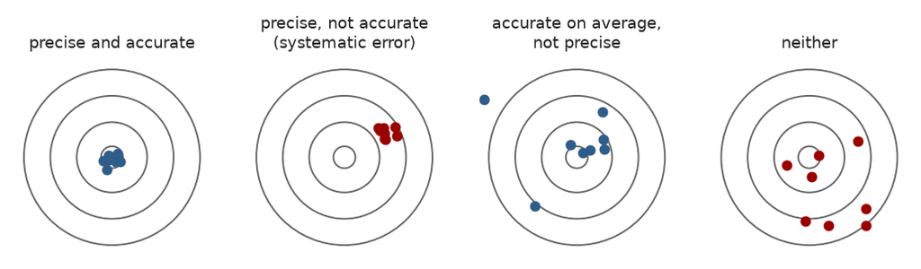

U12-T14Term

Define or distinguish Systematic error. Give an example and explain its role in this unit.

1. **Definition.** A systematic error shifts every measurement in the same direction by a similar amount, so the results can agree with each other and still be wrong (Derry p. 114).

2. **Example.** Weighing yourself in heavy boots, or measuring with a ruler whose zero mark is shifted.

3. **Role in this unit.** It is the reason precision and accuracy differ, and a hidden assumption behind many apparent facts.

4. **Distinction.** Random errors scatter in both directions and shrink when results are averaged. Systematic errors do not: averaging a thousand readings in boots still gives the wrong weight.

5. **Significance.** It can only be found by checking against an independent standard or a different method: calibration, a known test sample, or a second instrument.

Note*Outside the readings: the term "random error" for scatter that averages out.*

U12-T15Term

Define or distinguish Order of magnitude. Give an example and explain its role in this unit.

1. **Definition.** The order of magnitude of a number is the nearest power of ten. It is written with the symbol ∼, as in ∼10% (Derry pp. 111 and 115).

2. **Example.** The order of magnitude of 0.15 is 0.1, and of 889 is 1000. The 15% on the Wonder Flakes box tells us dependably that the cereal supplies ∼10% of our carbohydrate needs.

3. **Role in this unit.** It is the reliable part of an imprecise number, and the basis of quick estimation.

4. **Distinction.** An order of magnitude says nothing about the exact value or the ± range; it says only which power of ten is right.

5. **Significance.** It is often enough to decide a question: chemical bonds and light photons both have energies ∼1 eV, which makes photosynthesis and vision possible, and lasers that were two orders of magnitude too weak ended a weapons plan (Derry pp. 112-113).

### Applied written questions16

U12-A01Applied5 marks

Distinguish the experience of seeing a bright point through a telescope from the claim that it is a satellite. Identify the instrumental and theoretical assumptions connecting them.

Source Discussion 12.2

1. **The experience.** What the observer actually has is a bright point of light in the eyepiece, at a certain place among the stars and at a certain time, perhaps moving. That much is a fact of experience and cannot be denied.

2. **The claim.** "It is a satellite" goes far beyond that. It says the point is sunlight reflected from a human-made object orbiting the Earth at a certain height. This is an interpretation, a candidate scientific fact, and it can be wrong (Discussion 12.2).

3. **Instrumental assumptions.** The telescope shows faithfully where light comes from, which depends on geometric optics, just as Galileo's moons of Jupiter did. The point is not a reflection inside the tube, dust on a lens or a flaw in the eyepiece. The clock and the pointing of the telescope are correct, so the position and time can be trusted.

4. **Theoretical assumptions.** Light travels in straight lines from the object to the eye. The object shines by reflected sunlight, so it should be visible only while it is in sunlight and the observer's sky is dark. It moves according to orbital mechanics, so it should cross the stars at a steady, predictable rate along a definite track. Other explanations (a star, a planet, an aircraft, a meteor) predict different behaviour.

5. **Connecting them.** The claim becomes a scientific fact when its predictions are checked: watching the motion for some minutes, comparing the track and time with a published orbit prediction, and having other observers see the same thing. Each check rests on a theory, so the fact is theory-laden, but it is not arbitrary, because each check could have failed.

Note*Outside the readings: satellites are seen by reflected sunlight, mostly in the hours after sunset or before sunrise, and their passes can be predicted from published orbital elements.*

U12-A02Applied5 marks

Compare a fact of reason, a fact of experience and a scientific fact using three original examples. Explain the kind of certainty available in each case.

Source Discussion 12.2

1. **A fact of reason.** "The angles of a triangle add to 180 degrees" in Euclidean geometry. It follows by deduction from Euclid's axioms, so it is certain, but only relative to those axioms. It does not tell us whether physical space is Euclidean.

2. **A fact of experience.** "I feel warmth on my hand right now." I cannot deny having the experience, even if I could be wrong about its cause (the sun, a heater, or a fever). Its certainty is limited to the experience itself, and it is private until shared through communication (Discussions 6.1 and 12.2).

3. **A scientific fact.** "At sea-level air pressure, pure water boils at about 100 °C." It rests on repeated measurements by many people with calibrated thermometers, it is stated with a margin of error, and it depends on theory: what "pressure" and "temperature" mean and how thermometers work.

4. **The kinds of certainty.** The first is certain by logic; the second is certain as experience; the third has only relative, empirical certainty. It is accepted because it has been tested many times without contradiction, yet it remains open to revision and holds only under stated conditions (a different pressure gives a different boiling point).

5. **Why the distinction matters.** Each kind is checked in a different way: proof, direct awareness, and public testing. Confusing them leads to errors, such as claiming the certainty of mathematics for a measured result, or treating one person's experience as if it were a tested scientific fact.

U12-A03Applied5 marks

A microscope image is interpreted differently before and after learning cell theory. Explain theory-ladenness and why shared testing can still constrain interpretation.

Source Discussion 12.2

1. **The case.** Before cell theory, an observer looking at thin slices of cork or leaf might see a pattern of small walled boxes, and Hooke called them "cells," like small rooms. After cell theory, the same pattern is seen as living units, each one a basic part of the organism, with walls, contents and a nucleus to look for.

2. **Theory-ladenness.** The image on the retina is the same; what changes is the perception. Theory tells the observer which features matter, what to call them and what else to look for, as with Tycho and Kepler at sunrise (Discussion 12.2). Facts are reported in the concepts of a theory, and the instrument itself is trusted because of the theory of optics.

3. **What is shared.** Different observers still share the sensations: the pattern of lines and spaces, their sizes, how many there are. These can be measured, drawn and photographed, so both sides can point to the same features.

4. **How shared testing constrains interpretation.** An interpretation makes predictions others can check: if the boxes are living units, they should be found in every tissue, divide to make new ones, and contain similar parts. Staining, different microscopes and independent observers can test these predictions. An interpretation whose predictions fail must give way, however natural it seemed.

5. **The lesson.** Theory-ladenness means observations are interpreted, not that any interpretation will do. The six criteria still apply: facts must rest on observation, be stated empirically and not contradict other facts, and when they do, the beliefs behind them must be corrected.

Note*Outside the readings: Hooke named cells in Micrographia (1665) after looking at cork (Derry describes the book but not the cork, p. 38). Cell theory was set out by Schleiden and Schwann in 1838-1839.*

U12-A04Applied10 marks

Use the six course criteria for scientific facts to analyse two apparently contradictory laboratory results. Describe what should be checked before changing a theory.

Source Discussion 12.2

Illustration (invented numbers): laboratory A drops a steel ball and finds the acceleration due to gravity is g = 9.81 ± 0.02 m/s². Laboratory B times a ball rolling down an inclined plane, uses a = g × (height ÷ length), and reports g = 7.0 ± 0.1 m/s². The results differ by 2.81 m/s², about 28 times their combined uncertainty of 0.10 m/s², so they really do contradict each other.

1. **Criterion 1: facts are the result of observation.** First check that both values come from actual measurements. Are the raw times and distances available, or did either laboratory fill gaps with assumed values? A "fact" that was partly calculated from an assumption is not purely observational.

2. **Criterion 2: facts are expressed through empirical propositions.** Check that both statements are about the same quantity in the same units. "g" from free fall and "g" calculated from a slope are only the same quantity if the calculation is right; the definitions and units (metres, seconds) must match.

3. **Criterion 3: facts must be empirically true as far as we can tell.** Repeat each measurement and check each laboratory's procedure. Is the scatter within the stated uncertainties? Were the stated uncertainties honest, or too small?

4. **Check for systematic error.** Calibrate the instruments. A slow clock, a stretched tape or a mismeasured slope would shift every result in one direction. Precision does not guarantee accuracy, so close agreement within each laboratory proves nothing about its correctness (Derry p. 114).

5. **Check the conditions.** Were the conditions the same? Altitude and latitude change g slightly, air resistance matters for light objects, and friction matters on a slope. Different conditions can make two facts compatible.

6. **Criterion 4: the unity of reality allows no contradiction between facts.** Since g at one place has one value, both results cannot be right as stated. Something in the measurements or in the assumptions behind them must be wrong, so the contradiction is a signal to investigate, not something to live with.

7. **Criterion 5: belief and prior knowledge influence what is observed.** Ask whether expectations shaped the results: was data that looked "wrong" thrown out, or a model chosen to give the expected answer? Independent repetition, ideally by people who do not know the expected value, guards against this.

8. **Criterion 6: find the belief to correct.** Once we are certain of both observations and both statements are consistent, we look for the assumption to change. Here it is laboratory B's formula. A rolling ball also spins, so part of its energy goes into rotation, and for a solid ball the acceleration is only 5/7 of the sliding value. Correcting it, 9.81 × 5/7 = 7.01 m/s², which is inside laboratory B's range. The contradiction disappears.

9. **Order of suspicion.** Check data, units, calibration, conditions and auxiliary assumptions before the main theory. These are cheaper to test and more often wrong. A well-tested theory, here the law of falling bodies, should be the last thing questioned.

10. **When the theory should change.** Only if the contradiction survives every check, is confirmed independently, and appears in other experiments too, should the theory be revised. Even then, the new theory must also explain all the old facts that the old theory explained.

Note*Outside the readings: a solid ball rolling without slipping accelerates at 5/7 of g × (height ÷ length), because some of its energy turns its rotation. The laboratory values are invented for illustration; the comparison was computed by script.*

U12-A05Applied5 marks

A researcher calls every unobserved theoretical entity a fiction. Compare potential energy and caloric to explain why direct visibility is an inadequate criterion.

Source Discussion 12.2; Study Questions 1 and 2

1. **The researcher's criterion.** "Only what can be seen directly is real; every unobserved theoretical entity is a fiction." This is the instrumentalist position pushed to its limit (Discussion 12.2).

2. **Potential energy passes the real test.** It is defined as a capacity to do work, calculated in advance from weight and height. When the object falls, exactly that amount appears as kinetic energy and work. The term makes definite predictions that could fail, and they succeed, so it refers to something real even though it is never "seen" (Study Question 1).

3. **Caloric fails it.** Caloric was defined as a material fluid of heat, which implied a fixed supply in each body. Friction produced heat without limit, and the kinetic theory explained heat as molecular motion. Its predictions failed and the term was dropped (Study Question 2).

4. **Visibility does not separate them.** Neither potential energy nor caloric was ever directly visible. One is accepted and one rejected because of how their predictions fared, not because of what could be seen. So visibility cannot be the criterion that decides between them.

5. **Visibility is also unreliable in general.** Germs were invisible before the microscope, and radio waves, Neptune and many elementary particles were predicted before they were detected (Discussion 12.2). Even "seeing" a germ depends on trusting the microscope's optics. The better criteria are a clear link to measurement, successful prediction and coherence with other facts.

U12-A06Applied5 marks

Classify identification numbers, ordered pain labels, Celsius temperatures and lengths in metres by scale. Explain why arithmetic on the assigned numbers is not equally meaningful in all four cases.

Source Discussion 12.1

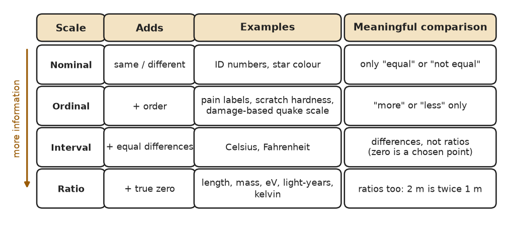

1. **Identification numbers: nominal.** The numbers only label; a different set of labels would do just as well. Only "same" or "different" is meaningful. The average student number in a class means nothing.

2. **Ordered pain labels (none, mild, moderate, severe): ordinal.** The labels are ranked, so "more" and "less" are meaningful. But the steps need not be equal: the jump from moderate to severe may be bigger than from none to mild. Coding them 0, 1, 2, 3 and averaging assumes equal steps that were never measured; a median is safer.

3. **Celsius temperatures: interval.** Equal differences mean equal amounts: 10 to 20 °C is the same rise as 20 to 30 °C, so differences and averages of equal samples make sense. But 0 °C is a chosen point (water freezing), not "no temperature," so ratios mean nothing: 20 °C is not twice as hot as 10 °C.

4. **Lengths in metres: ratio.** A standard unit and a true zero make all arithmetic meaningful, including ratios: 2 m is twice 1 m, and lengths placed end to end add.

5. **Why arithmetic is not equally meaningful.** A calculation is meaningful only if its result survives a change to another acceptable version of the scale. Relabelling IDs changes their average; any order-preserving recoding of pain labels changes the size of differences; converting Celsius to Fahrenheit changes ratios; converting metres to feet changes nothing but the unit (Discussion 12.1).

Note*Outside the readings: the idea that each scale allows certain transformations (relabelling, order-preserving changes, linear changes with a new zero, change of unit) is S. S. Stevens's classification of scales.*

U12-A07Applied5 marks

Why is a body at 20 degrees Celsius not twice as hot in the ratio-scale sense as a body at 10 degrees Celsius? Contrast Celsius with an absolute thermodynamic scale.

Source Discussion 12.1

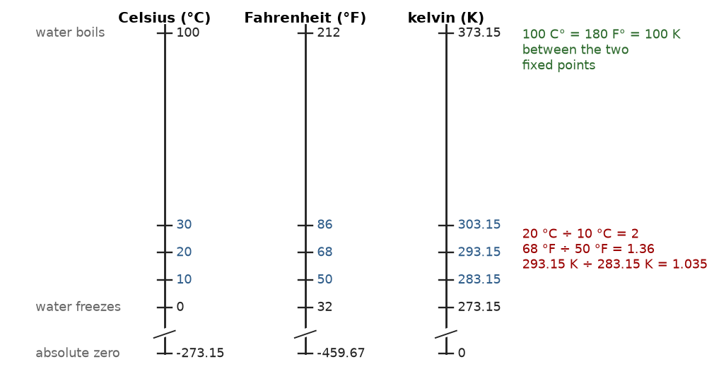

1. **The ratio-scale sense.** "Twice as hot" would mean twice the amount of the measured quantity, which needs a scale whose zero means none of it. Celsius has no such zero: 0 °C is just the freezing point of water, chosen as a convenient end of the standard interval (Discussion 12.1).

2. **The numbers.** On the absolute (kelvin) scale, 10 °C is 283.15 K and 20 °C is 293.15 K. The ratio is 293.15 ÷ 283.15 = 1.035, so the warmer body has only about 3.5% more absolute temperature, not 100% more.

3. **The ratio depends on the arbitrary zero.** In Fahrenheit the same two temperatures are 50 °F and 68 °F, a ratio of 1.36. A real property cannot be "twice" on one scale and 1.36 times on another, so the Celsius ratio of 2 tells us nothing about the bodies.

4. **The absolute scale.** The thermodynamic scale starts from absolute zero, the lowest possible temperature, so it is a ratio scale. A body twice as hot as one at 10 °C, in this sense, would be at 566.30 K, which is 293.15 °C. The course notes that this theoretical scale reaches from absolute zero to hundreds of millions of degrees (Discussion 12.1, footnote 254).

5. **What Celsius does allow.** Differences are meaningful: 20 °C is 10 degrees warmer than 10 °C, and that difference is the same in kelvin. So Celsius is an interval scale, good for differences, while kelvin is a ratio scale, good for both differences and ratios.

Note*Outside the readings: absolute zero is -273.15 °C. The course defines interval and ratio scales by their standards; the true-zero criterion used here is the standard one.*

U12-A08Applied5 marks

Convert 20 and 30 degrees Celsius using F = 9C/5 + 32. Compare the temperature difference in both units and explain why ratios of the readings are not invariant.

Source Discussion 12.1

1. **The conversions.** F = 9C/5 + 32. For 20 °C: 9 × 20 ÷ 5 + 32 = 36 + 32 = 68 °F. For 30 °C: 9 × 30 ÷ 5 + 32 = 54 + 32 = 86 °F.

2. **The difference.** In Celsius the difference is 30 − 20 = 10 Celsius degrees; in Fahrenheit it is 86 − 68 = 18 Fahrenheit degrees. The two describe the same change, since one Celsius degree is 1.8 Fahrenheit degrees. Differences convert consistently by the factor 9/5, because the +32 cancels when one reading is subtracted from another.

3. **The ratios.** In Celsius, 30 ÷ 20 = 1.5. In Fahrenheit, 86 ÷ 68 = 1.26. On the absolute scale, 303.15 ÷ 293.15 = 1.034. The same pair of temperatures gives three different ratios.

4. **Why ratios are not invariant.** The conversion has two parts: a change of unit (× 9/5) and a shift of zero (+ 32). A change of unit alone would leave ratios unchanged, as converting metres to feet does. The shift of zero does not, because each scale's zero is a chosen point, not "no temperature."

5. **What is invariant.** Ratios of differences survive: (30 − 20) ÷ (20 − 10) = 1 in Celsius, and (86 − 68) ÷ (68 − 50) = 18 ÷ 18 = 1 in Fahrenheit. This is the mark of an interval scale: equal differences mean the same on every version of the scale, but ratios of readings do not.

U12-A09Applied10 marks

Outline a reproducible procedure for assigning numerical viscosities to fluids. Specify temperature control, apparatus, comparison standard, an operational relationship and uncertainty.

Source Discussion 12.1; Study Question 9

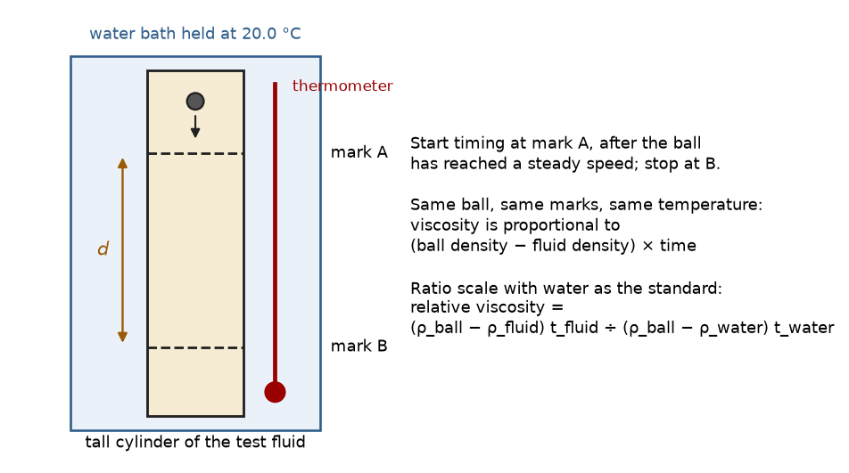

1. **Aim and scale.** To assign each fluid a number that measures its resistance to flow, preserves the known order (gasoline, water, salt water, maple syrup, crude oil, tar) and gives meaningful ratios. Water will be the standard, so the result is a ratio scale (Study Question 9).

2. **Temperature control.** Viscosity changes strongly with temperature, especially for syrup and oil. Hold every sample, and the standard, in a stirred water bath at one stated temperature, such as 20.0 ± 0.1 °C, check it with a calibrated thermometer, and let each sample reach the bath temperature before measuring.

3. **Apparatus.** A tall, clear cylinder of the fluid, wide compared with the ball so the walls do not slow it. Steel balls of known diameter and density. Two marks a measured distance *d* apart, the upper one far enough below the surface that the ball is already falling at a steady speed. A stopwatch or, better, light gates.

4. **Procedure.** Release each ball gently at the centre, time it from mark to mark, recover it, and repeat at least five times per fluid. Measure each fluid's density with a hydrometer or by weighing a known volume. Record every time, not only the average.

5. **Comparison standard.** Measure pure water in the same way, in the same cylinder, at the same temperature, and assign it the value 1, as the course assigns water a heat capacity of 1.

6. **Operational relationship.** For a given ball and distance, the steady speed is lower in a more viscous fluid, and the buoyancy of the fluid must be allowed for. Use: viscosity ∝ (ρ_ball − ρ_fluid) × time. Then relative viscosity = (ρ_ball − ρ_fluid) × t_fluid ÷ ((ρ_ball − ρ_water) × t_water).

7. **Checking the scaling assumption.** The relationship assumes slow, steady motion. Test it: two balls of different sizes in the same fluid should give the same relative viscosity. If they disagree, the ball is falling too fast and a smaller or lighter ball is needed.

8. **Extending the range.** No single ball works for gasoline and tar. Use a dense small ball for thin fluids and a light one for thick ones, or switch to timing flow through a narrow tube. Measure a fluid of middle viscosity both ways so the two methods can be joined on one scale.

9. **Uncertainty.** From the repeated times, report the mean and the standard deviation, so each viscosity is written as value ± uncertainty. Add the uncertainties of distance, density and temperature. Check systematic error by measuring a fluid of known viscosity.

10. **Validation.** The finished numbers must reproduce the original ordinal ranking; if two fluids come out in the wrong order, either the method or the ranking needs a second look. Report the temperature with every value, because a viscosity without its temperature is not a reproducible fact.

Note*Outside the readings: the relationship in point 6 follows from Stokes' law for a small sphere falling slowly at a steady speed. Water at 20 °C has a viscosity of about 1.0 millipascal-second.*

U12-A10Applied5 marks

Explain why combining equal masses adds their mass but combining equally sized samples at different temperatures does not add their temperatures. State assumptions for taking an average temperature.

Source Discussion 12.1

1. **Mass adds.** Mass is measured on a ratio scale whose combining rule has a = b = 1: putting 1 kg and 1 kg on a balance needs 2 standard kilograms to balance them. Combining means simply taking both, and the amount of matter is conserved (Discussion 12.1).

2. **Temperature does not add.** Temperature describes a state of equilibrium, not an amount of stuff. Combining two bodies at different temperatures means letting heat flow from the hotter to the colder until both share one temperature. That temperature lies between the two starting values, so a and b are both less than 1 and add to 1.

3. **The rule for equal samples.** Two samples that are identical except for temperature combine with a = b = 1/2: the final temperature is the average, by the principle of sufficient reason. Water at 20 °C and 80 °C gives 50 °C, not 100 °C.

4. **Assumptions needed to average.** The samples are the same material and have equal masses (equal heat capacities). The system is insulated, so no heat enters or leaves. No phase change or chemical reaction occurs. Heat capacity does not change over the temperature range. The mixture is allowed to reach equilibrium and is stirred evenly.

5. **When the assumptions fail.** Unequal masses or different materials need a weighted average, with heat capacities as weights. Melting ice, for example, absorbs heat without warming, so mixing ice at 0 °C with warm water ends colder than the average. Averaging two thermometer readings that are never brought into contact is a statistic, not a physical temperature.

U12-A11Applied5 marks

Equal masses of the same material at 20 and 80 degrees Celsius are mixed in an insulated system, with constant heat capacity and no phase change. Estimate equilibrium temperature, then explain what fails if the materials differ.

Source Discussion 12.1

1. **Equal masses of the same material.** With equal heat capacities, heat lost by the hot sample equals heat gained by the cold one: C × (80 − T) = C × (T − 20). So T = (20 + 80) ÷ 2 = 50 °C.

2. **Why the average.** This is Equation (1) with a = b = 1/2. The assumptions are the ones stated: insulated, constant heat capacity, no phase change, and equilibrium reached.

3. **What fails if the materials differ.** Equal masses of different materials have different heat capacities, so the same flow of heat changes their temperatures by different amounts. The simple average no longer holds, and the result is weighted toward the material with the larger heat capacity: T = (C₁T₁ + C₂T₂) ÷ (C₁ + C₂) (Discussion 12.1, Equation 3).

4. **An example.** The course's own numbers give mercury a heat capacity of about 0.031 if water's is 1. Mixing 1 kg of water at 20 °C with 1 kg of mercury at 80 °C then gives T = (1 × 20 + 0.031 × 80) ÷ 1.031 = about 21.8 °C, far below 50 °C. The water barely warms because it takes much more heat to change its temperature.

5. **What must be known instead.** We need both heat capacities, measured relative to a standard (water, C_w = 1), by the same mixing method run in reverse. Even then, the result assumes no heat losses, no reaction between the materials and no change of phase.

Note*Calculations: with standard specific heats instead (water 4186, mercury 140 J per kg per degree, outside the readings), the result is 21.9 °C. Both were computed by script.*

U12-A12Applied5 marks

A length is reported as 12.40 ± 0.05 cm. Explain the central value, uncertainty and justified digits. Identify information needed before interpreting the interval as a particular confidence level.

Source Derry Chapter 8

1. **Central value.** 12.40 cm is the best estimate of the length.

2. **Uncertainty.** ± 0.05 cm states the range within which we believe the true length lies: 12.35 cm to 12.45 cm (Derry p. 113). Relative to the length it is 0.4%.

3. **Justified digits.** The uncertainty is in the hundredths place, so the value is reported to the hundredths. The final 0 is a measured digit and must be kept: "12.4 cm" would hide that the hundredths were measured, and "12.400 cm" would claim a precision the measurement does not have.

4. **Information needed for a confidence level.** We must know what the ± means. Is it one standard deviation (so about two-thirds of repeated measurements would fall inside, as Derry describes), two standard deviations, the largest deviation seen, or half the smallest scale division? We also need the number of measurements behind it, and whether it includes systematic errors such as calibration, or only random scatter.

5. **Caution.** Derry warns that statistical meanings need large amounts of data, so without that information the interval should be read only as a rough estimate (Derry p. 113). It tells us nothing about accuracy if the ruler itself is off.

U12-A13Applied5 marks

Measurements 10.1, 10.2 and 10.1 cm come from a ruler later found to have a shifted zero. Explain why close agreement does not ensure accuracy and how calibration would help.

Source Derry Chapter 8

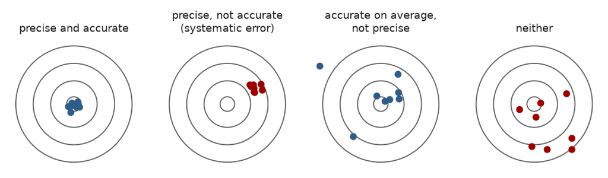

1. **The readings are precise.** 10.1, 10.2 and 10.1 cm agree closely: their mean is 10.13 cm, their spread is only 0.1 cm and their standard deviation about 0.06 cm. Precision means agreement among repeated measurements (Derry p. 114).

2. **Why that does not ensure accuracy.** A shifted zero adds the same error to every reading. All three are wrong by the same amount, so they still agree with each other. Accuracy, agreement with the true value, cannot be seen from the readings alone; this is a systematic error, like weighing yourself in heavy boots.

3. **Why repeating does not help.** Averaging reduces random scatter, but a systematic error is in every reading. A thousand readings with the same ruler would give a very precise wrong answer.

4. **How calibration helps.** Compare the ruler with a standard: measure an object of certified length, or line the ruler up against a reference scale. If it reads too long by an amount δ at every point, subtract δ from each reading. Also check that the error is the same along the whole ruler, not growing with length.

5. **A simple fix.** Measure from a different mark, such as the 1 cm line, and subtract, or use a second, independent instrument. Report the corrected value with an uncertainty that includes the calibration uncertainty, not only the scatter.

U12-A14Applied5 marks

In an idealized inclined-plane experiment, cumulative distances at equal time intervals are 1, 4, 9 and 16 units. Compute the successive interval distances and explain the implication for speed and acceleration.

Source Discussion 12.3

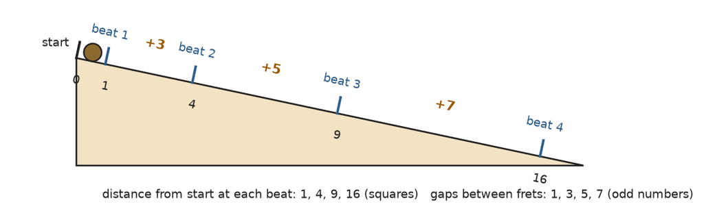

| **Time interval** | **Cumulative distance** | **Distance in this interval** | **Increase over previous interval** |
| --- | --- | --- | --- |
| 1st | 1 | 1 | - |
| 2nd | 4 | 3 | 2 |
| 3rd | 9 | 5 | 2 |
| 4th | 16 | 7 | 2 |

1. **Interval distances.** Subtracting each cumulative distance from the next: 1 − 0 = 1, 4 − 1 = 3, 9 − 4 = 5 and 16 − 9 = 7 units. They are the odd numbers, Galileo's rule.

2. **Speed.** Each interval has the same duration, so the average speed in each interval is proportional to the distance covered in it: 1, 3, 5 and 7 units per interval. The ball speeds up all the time.

3. **Acceleration.** The speed rises by the same amount, 2 units per interval, from each interval to the next. Equal increases in speed in equal times mean constant acceleration.

4. **The law.** The cumulative distances 1, 4, 9 and 16 are the squares of the elapsed times 1, 2, 3 and 4. Distance is proportional to the square of the time, d = t², which corresponds to an acceleration of 2 units per interval squared. Speed itself grows in proportion to time, as Galileo claimed (Discussion 12.3).

5. **Assumptions and limits.** This assumes the ball starts from rest at the first mark, at time zero, and that the intervals are truly equal. Real data would scatter; the idealized numbers show what to look for, and the second differences would be compared within their uncertainties.

U12-A15Applied5 marks

Explain how Galileo's inclined plane made a fast process measurable. Identify the assumptions linking rolling on the slope to a claim about falling bodies, and distinguish observation from extrapolation.

Source Discussion 12.3

1. **Slowing the process.** A free fall over a few metres is over in about a second, too fast for a water clock or a pulse. On a gentle slope the ball covers the same distance much more slowly, because only part of gravity acts along the slope. Galileo's slopes were between 12:1 and 6:1 (Discussion 12.3).

2. **By how much.** For the same distance, the time grows as the square root of the slope ratio: about 3.5 times longer at 12:1 and 2.4 times at 6:1, and about 4.1 and 2.9 times once the ball's rolling is allowed for. Times of several seconds can be measured with a water clock or by musical beats.

3. **The linking assumptions.** Motion can be split into vertical and horizontal parts, and the force producing acceleration acts only vertically, as shown by the ball staying still on a level plane. The slope only reduces the effect of that force; it does not change the form of the motion. Friction and air resistance are small enough to ignore.

4. **What was observed.** On slopes from 12:1 to 6:1, distances were in proportion to the squares of the times, and this held for every inclination tested. That is the observation: a fact about balls rolling in a groove on gentle slopes.

5. **What was extrapolated.** That the same law holds for a vertical drop, which is the steepest possible slope and was never tested this way, and for all falling bodies. The extrapolation is supported by the law holding at every slope tried and by Galileo's arguments, but it remains an inference beyond the data.

Note*Outside the readings: the time factor is the square root of length ÷ height for the same distance; a solid rolling ball adds a further factor of about 1.18 (the square root of 7/5). Computed by script.*

U12-A16Applied5 marks

Design two presentations of inclined-plane data: distance at equal time intervals and elapsed time for selected distances. Explain how each can test the same proposed law.

Source Discussion 12.3

**Presentation 1: distance at equal time intervals (as with musical beats).**

| **Beat** | **Distance from start (predicted)** | **Gap from previous beat** |
| --- | --- | --- |
| 1 | 1 | 1 |
| 2 | 4 | 3 |
| 3 | 9 | 5 |
| 4 | 16 | 7 |

**Presentation 2: elapsed time for selected distances (as with the water clock).**

| **Fraction of full length** | **Time as a fraction of full time (predicted)** |
| --- | --- |
| 1/4 | 0.500 |
| 1/2 | 0.707 |
| 3/4 | 0.866 |
| 1 | 1.000 |

1. **The proposed law.** Distance is proportional to the square of the elapsed time, starting from rest (Discussion 12.3). Both tables state what the law predicts; real data would be placed beside the predictions with their uncertainties.

2. **How presentation 1 tests it.** Fix equal time steps and measure positions. The law predicts positions in the ratio 1:4:9:16 and gaps 1, 3, 5, 7, increasing by a constant amount. A constant second difference is a direct test of constant acceleration.

3. **How presentation 2 tests it.** Fix the distances and measure the times, as ratios of weighed water. The law predicts time ratios equal to the square root of the distance ratios: a quarter of the length in half the time, as Galileo reported.

4. **The same law in both.** Plot distance against time squared from either table: the law predicts a straight line through the origin. The two designs are therefore two tests of one claim, but they put the controlled variable on different sides, which guards against errors in one kind of timing.

5. **Strengths of each.** Equal beats show the pattern of increasing speed at a glance, without any unit of time. Chosen distances can test many points and slopes and give a public record (weighed water) that does not depend on one observer's ear, which made it the better form for publication.

Note*Calculations: the predicted time fractions are square roots of the distance fractions, computed by script.*

### People and attributions13

U12-P01Person

Identify Protagoras (ca. 490-ca. 420 BCE) and the idea or contribution the assigned readings ascribe to this person. Explain its significance in this unit.

Source Discussion 12.1 epigraph

1. **Who.** Protagoras (ca. 490-ca. 420 BCE) was an ancient Greek philosopher. His saying survives in Plato's dialogue *Theaetetus* (152a), from which the first epigraph of Discussion 12.1 is taken (Discussion 12.1).

2. **Quotation.** "Man is the measure of all things" (Discussion 12.1).

3. **Meaning.** Placed at the head of a discussion of measurement, the line points to the human element in every scale. People choose the empirical procedure that defines a comparison, the scaling assumption that fixes the form of the function, and the standard of measure, such as the freezing and boiling points of water or the standard kilogram (Discussion 12.1).

4. **Significance.** Measurement is a basic condition for doing science, yet its numbers are constructed: a scientific fact resting on a measurement is a fact only relative to these human choices. With Heisenberg's companion epigraph, the line prepares Unit 12's claim that facts are relative and theory-laden rather than absolute (Discussions 12.1 and 12.2).

U12-P02Person

Identify Werner Heisenberg (1901-1976) and the idea or contribution the assigned readings ascribe to this person. Explain its significance in this unit.

Source Discussion 12.1 epigraph

1. **Who.** Werner Heisenberg (1901-1976) was a German physicist and one of the founders of quantum mechanics. The second epigraph of Discussion 12.1 comes from his book *Physics and Philosophy* (1958) (Discussion 12.1).

2. **Quotation.** "[S]ince the measuring device has been constructed by the observer ... we have to remember that what we observe is not nature in itself but nature exposed to our method of questioning" (Discussion 12.1).

3. **Meaning.** An instrument is built by people on the basis of theory, so what it records already reflects the questions we chose to ask. Observation is never a pure view of nature in itself.

4. **Significance.** Unit 12 builds on this point. Galileo's moons of Jupiter depended on the telescope and the theory of geometric optics, and instruments such as the scanning electron microscope rest on "massive amounts of theorizing" (Discussion 12.2). Measurement scales likewise depend on chosen procedures and standards, so scientific facts are theory-laden and must stay open to revision.

U12-P03Person

Identify John Tyndall (1820-1893) and the idea or contribution the assigned readings ascribe to this person. Explain its significance in this unit.

Source Unit 12 Overview

1. **Who.** John Tyndall (1820-1893) was an Irish physicist. The first epigraph of the Unit 12 Overview comes from his essay "Scientific Materialism" in *Fragments of Science* (Unit 12 Overview).

2. **Quotation.** "[T]he brightest of flashes in the world of thought are incomplete until they have been proved to have their counterparts in the world of fact" (Unit 12 Overview).

3. **Meaning.** However brilliant an idea or theory is, it is not finished until it has been tested against experience and shown to correspond to facts.

4. **Significance.** Unit 12 is about this "world of fact": what a scientific fact is, how it is related to theory and to experience, and the criteria for accepting or rejecting it. The unit adds a twist to Tyndall's picture: the facts that test theories are themselves theory-laden, constructed in the interplay of theory and experiment (Unit 12 Overview; Discussion 12.2).

U12-P04Person

Identify Louis Agassiz (1807-1873) and the idea or contribution the assigned readings ascribe to this person. Explain its significance in this unit.

Source Unit 12 Overview

1. **Who.** Louis Agassiz (1807-1873) was a Swiss-born naturalist and geologist. The second epigraph of the Unit 12 Overview comes from his essay on the internal structure and progression of glaciers in *Geological Sketches* (1866) (Unit 12 Overview).

2. **Quotation.** "The facts will eventually test all our theories, and they form, after all, the only impartial jury to which we can appeal" (Unit 12 Overview).

3. **Meaning.** Theories are judged by facts, and facts are the neutral judge that settles disputes between theories.

4. **Significance.** The Overview immediately questions how impartial that jury is: "Is there anything to a fact other than the fact that people believe in it?" (Unit 12 Overview). Unit 12 answers that facts are relative and theory-laden, so belief and prior knowledge influence what facts will be observed, yet the six criteria still let facts test theories and force us to change beliefs when facts conflict (Discussion 12.2).

U12-P05Person

Identify Robert A. Heinlein (1907-1988) and the idea or contribution the assigned readings ascribe to this person. Explain its significance in this unit.

Source Discussion 12.2 epigraph

1. **Who.** Robert A. Heinlein (1907-1988) was an American science-fiction writer. The epigraph of Discussion 12.2 comes from his novel *Time Enough for Love* (Discussion 12.2).

2. **Quotation.** "What are the facts? Again and again and again ... what are the facts, and to how many decimal places? You pilot always into an unknown future; facts are your single clue. Get the facts!" (Discussion 12.2). In between, he tells us to shun wishful thinking, divine revelation, astrology, opinion and the "verdict of history".

3. **Meaning.** Decisions should rest on facts, not on hope or authority, and facts are worth only as much as their precision: a number needs its decimal places.

4. **Significance.** The epigraph opens a discussion that complicates it at once: "in science, facts are relative rather than absolute" (Discussion 12.2). Getting the facts means constructing them from observation and theory, and "to how many decimal places" points to measurement, uncertainty and precision, the other topics of Unit 12.

U12-P06Person

Identify Norwood Russell Hanson (1924-1967) and the idea or contribution the assigned readings ascribe to this person. Explain its significance in this unit.

Source Discussion 12.2

1. **Who.** Norwood Russell Hanson (1924-1967) was a philosopher of science. Discussion 12.2 draws on his chapter "Observation" in an anthology of readings in the philosophy of science (Discussion 12.2).

2. **Idea.** Seeing is theory-laden. Hanson asserts that Tycho and Kepler, watching the same sunrise, see different things: Tycho sees the sun rise above the horizon as it moves about the Earth, while Kepler sees a stationary sun appear to rise as the Earth rotates beneath it. Hanson denies that this is only a matter of interpretation, because his "seeing" includes how sensory awareness is embedded in a person's worldview: what one sees is what one has learned to see (Discussion 12.2).

3. **Example.** He illustrates this with the Necker cube, a two-dimensional drawing that can be seen as a cube from above or from below (Discussion 12.2).

4. **Significance.** On the course's constructive reading, Tycho and Kepler "share the same sensations and apprehensions, but differ in their perceptions" (Discussion 12.2). The sunrise is a fact of experience for both, but it becomes a scientific fact only within a conceptual web of paradigmatic assumptions, which is why Unit 12 calls scientific facts theory-laden.

U12-P07Person

Identify the Instrumentalists, the philosophers who take the instrumentalist position, and the view the assigned readings ascribe to them. Explain their significance in this unit.

Source Discussion 12.2

1. **Who.** Discussion 12.2 does not name them: "Some philosophers claim that this is all that there is to the matter. This view is the "instrumentalist" position" (Discussion 12.2).

2. **Idea.** Scientific facts are convenient fictions. The word *fact* comes from *factum*, from *facere*, "to produce", and *fiction* from *fictum*, from *fingere*, "to fashion or form"; so scientific facts can be read as "convenient fictions that we make up in order to explain the sensations that result when we do something" (Discussion 12.2).

3. **Reply.** The course finds the position "useful as far as it goes". But some convenient fictions turn out to be real once we extend the limits of our experience: germs (invisible before the microscope), radio waves, the planets Uranus and Neptune and many elementary particles. Others, like caloric, turn out not to exist (Discussion 12.2).

4. **Significance.** Instrumentalism captures the made, theory-laden side of scientific facts, but not their surprising success in revealing real entities, the "unnatural effectiveness of science in fitting the world" (Discussion 12.2). Unit 12 takes a middle path: facts are constructed, yet tested by experience.

U12-P08Person

Identify W. T. Stace and the idea or contribution the assigned readings ascribe to this person. Explain its significance in this unit.

Source Unit 12 Study Questions

1. **Who.** W. T. Stace is "the philosopher W. T. Stace" of Unit 12 Study Question 1, cited from his chapter *Science and the Physical World* in an anthology of readings in the philosophy of science (Unit 12 Study Questions).

2. **Claim.** Stace "has claimed that potential energy is nothing but a fiction invented as a means of saving the law of conservation of energy" (Unit 12 Study Questions). His argument: if an object is thrown into the air and lands on a roof, there is no evidence that it has anything like potential energy.

3. **The flaw.** The question's hint defines energy as "the capacity to perform work" (Unit 12 Study Questions). The object on the roof has that capacity, and it can be tested: if it is pushed off, it falls and gains the energy of motion it lost on the way up, and it can do work (lift something by a rope, or dent the ground) as it comes down. So its raised position is measurable evidence, not a fiction.

4. **Significance.** Study Question 2 sets potential energy beside caloric, the entity of the discarded calorie theory of heat, which "must now be considered as a mere fiction" (Unit 12 Study Questions). Discussion 12.2 explains the difference: some "convenient fictions" turn out to be real once we can test them, while others, like caloric, do not (Discussion 12.2).

U12-P09Person

Identify Galileo Galilei (1564-1642) and the idea or contribution the assigned readings ascribe to this person. Explain its significance in this unit.

Source Discussions 12.2, 12.3

1. **Who.** Galileo Galilei (1564-1642; Discussion 11.3) "conducted a number of experimental studies of motion" (Discussion 12.3).

2. **Falling bodies.** Whether or not he dropped weights from the Tower of Pisa, he rolled a bronze ball down an inclined plane 12 cubits long, one end raised one or two cubits, and reported the results in *Dialogue Concerning Two New Sciences* (1638). Lacking accurate clocks, he needed long time intervals, timed with a water clock (giving ratios of time) and probably musical beats. He concluded that falling objects undergo constant acceleration: the distance covered is proportional to the square of the time, the velocity to the time (Discussion 12.3).

3. **Telescope.** He claimed four moons circling Jupiter, a "fact" that depended on the telescope and a theory of geometric optics; Aristotelian professors refused even to look (Discussion 12.2). His mountains on the moon were his interpretation of patterns of light and dark, which Dante had read as differences in the density of lunar material (Unit 12 Study Questions).

4. **Significance.** His experiments show "the beginning of experimental technique" and a creative way around the lack of accurate instruments (Discussion 12.3), and his telescope observations show that scientific facts are interpreted, theory-laden observations (Discussion 12.2).

U12-P10Person

Identify Stillman Drake and the idea or contribution the assigned readings ascribe to this person. Explain its significance in this unit.

Source Discussion 12.3, footnote 262

1. **Who.** Stillman Drake is the Galileo scholar cited in a footnote to Discussion 12.3 for his article "The role of music in Galileo's experiments" (*Scientific American*, June 1975); Discussion 11.3 cites his translation *Discoveries and Opinions of Galileo* (Discussions 12.3, 11.3).

2. **Idea.** Drake argued that Galileo used musical timing. There is evidence that "at least in his initial preparations for these experiments he timed the rolling balls using musical beats, later making use of a water clock for confirmation and a more publically acceptable presentation of the results" (Discussion 12.3).

3. **How.** Galileo was an accomplished lute player, and his father and brother were musicians. Gut strings set across the inclined plane so that the notes sounded at equal intervals as the ball rolled past would measure distances travelled in equal times, since a trained ear judges equal beats far more accurately than any clock of Galileo's day (Discussion 12.3).

4. **Significance.** Musical timing gives distances in equal units of time, while a water clock gives ratios of time for varying distances; Study Question 10 asks for a comparison of the two forms of data (Unit 12 Study Questions). The way we measure shapes the form of our facts.

U12-P11Person

Identify Count Rumford and the idea or contribution the assigned readings ascribe to this person. Explain its significance in this unit.

Source Derry ch. 17, p. 231

1. **Who.** Count Rumford was the experimenter whose classic cannon-boring experiments Derry describes at the start of his account of thermodynamics (Derry, p. 231).

2. **Contribution.** Boring a cannon makes the metal very hot, just as a piece of metal gets "pretty darned hot" after hacksawing or drilling. This observation led Rumford "to conclude that heat is a form of motion" (Derry, p. 231).

3. **Context.** "Heat had once been pictured as some sort of subtle fluid" (Derry, p. 231), the caloric of the calorie theory. By the middle of the nineteenth century heat was understood as the random microscopic motion of the atoms of an object, which we feel as heat; this began the theory of thermodynamics developed by Carnot, Joule, Clausius, Kelvin, Helmholtz, Maxwell, Gibbs and Boltzmann (Derry, p. 231).

4. **Significance.** Rumford's experiment is the historical case behind Unit 12's discussion of facts: caloric, a theoretical entity once taken as real, "must now be considered as a mere fiction" (Unit 12 Study Questions), while heat as motion became established fact (Discussion 12.2).

U12-P12Person

Identify James Joule and the idea or contribution the assigned readings ascribe to this person. Explain its significance in this unit.

Source Derry ch. 17, p. 232

1. **Who.** James Joule was a nineteenth-century scientist whom Derry names among the founders of thermodynamics (Derry, p. 231).

2. **Contribution.** "Careful experiments conducted by James Joule were the first convincing demonstration of this law, and no exceptions have ever been discovered since then" (Derry, p. 232). The law is the conservation of energy.

3. **The law.** Energy changes form in myriad ways (motion to heat, heat to motion in a steam engine, sunlight to chemical energy in plants), but "the total amount of the energy is always the same before and after the change" (Derry, p. 232). Also called the first law of thermodynamics, it says energy can be neither created nor destroyed, only changed from one form into another, and it forbids a perpetual motion machine (Derry, p. 232).

4. **Significance.** Careful measurement turned the equivalence of heat and motion into a general law that survived relativity and quantum mechanics (Derry, p. 232). It is the law W. T. Stace says potential energy was invented to save (Unit 12 Study Questions).

U12-P13Person

Identify Lord Kelvin (1824-1907) and the idea or contribution the assigned readings ascribe to this person. Explain its significance in this unit.

Source Derry ch. 8, p. 107

1. **Who.** Lord Kelvin (1824-1907; Discussion 15.1) was a nineteenth-century physicist; Derry names him among the developers of thermodynamics (Derry, p. 231).

2. **Quotation.** Derry opens Chapter 8 on quantitative reasoning with Kelvin: "When you can measure what you are speaking about and express it in numbers, you know something about it, and when you cannot measure it, when you cannot express it in numbers, your knowledge is of a meagre and unsatisfactory kind" (Derry, p. 107).

3. **Meaning.** Measurement turns impressions into numbers that can be compared and checked. The companion epigraph by R. W. Gerard adds a caution: quantification "is useless or worse until the right things are in the field of viewpoint" (Derry, p. 107).

4. **Significance.** Kelvin's maxim states the theme of Unit 12. Measurement introduces greater precision and "provides a means for evaluating the accuracy of predictions"; it gives a numerical scale for significant variables so we can find general mathematical laws (Discussion 12.1).

Unit 13

## Theory Explanation and Cosmology

Approach Classify the intended form of a law or explanation, then identify a flawed empirical premise when relevant. Historical cosmology questions concern the assigned account.

### Official study guide questions9

U13-SG01Study guide

If we focus attention on the forms of scientific theories, in contrast to their content we see that a form of theory valuable in one area of science may be worth little in some other area, and *vice versa*. The Aristotelian idea of a life cycle is a particular form for theorizing, based on the assumptions listed below.

- Entities develop according to a natural progression in an organic way, from birth to death, or completion.

- By various means, the rate of this natural development can be accelerated or retarded, within certain bounds.

This particular form of theory was taken over into alchemy, where it was assumed that metals develop in the earth toward gold; which, being the most noble metal, is their final state of completion. Many alchemists sought to discover a method to speed up this process in the laboratory.

a. Today we know that this form of theory does not fit when applied to the study of metals. Can you think of an area of modern science where this life cycle does appear as an ideal of natural order?

b. Write a short essay (300-500 words) discussing an example from your own experience where the life cycle concept applies.

Source Unit 13 Study Questions question 1

**a. A modern science where the life cycle is an ideal of natural order: stellar evolution.**

1. **The answer: stellar evolution in astronomy.** Astronomers describe every star as passing through a fixed sequence. It forms when a cloud of gas and dust collapses under gravity, spends most of its life fusing hydrogen into helium in its core (the "main sequence"), swells into a giant when the hydrogen in its core runs out, and ends as a white dwarf or, if it is massive enough, in a supernova that leaves a neutron star or a black hole. Astronomers even speak of a star's "birth" and "death."

2. **The first assumption holds: a natural progression to completion.** Every star follows the same ordered stages, and none is skipped. That sequence works as an ideal of natural order. Astronomers do not ask why a star leaves the main sequence when its core hydrogen is used up; they ask why a particular star departs from the expected path, because only deviations from the ideal need explaining (Discussion 13.1). Study Question 3(f) is a law statement of this kind: a supernova is the expected end for a sufficiently massive star.

3. **The second assumption holds: the rate can be speeded up or slowed down, within bounds.** A star's mass sets its pace. Massive stars use up their fuel quickly and live only a few million years, while small red dwarfs will last far longer than the present age of the universe. A star in a close pair that gains mass from its partner has its development accelerated. Only the pace changes, never the order of the stages: these are the "certain bounds" of the life-cycle form.

4. **Other fields where the form fits.** Developmental biology uses it (egg, embryo, juvenile, adult and death, with temperature and hormones speeding up or slowing down development, as in insect metamorphosis), and so does ecological succession (bare ground, pioneer plants, shrubs and finally a mature forest, which fire or grazing can set back).

5. **Why it fails for metals.** A metal is an element, and an element does not ripen: lead does not slowly turn into gold in the earth. Changing one element into another is a nuclear change, not a chemical or organic one, so the alchemists' laboratory methods could not speed up a development that does not happen. A form of theory that is fruitful for stars and living things was the wrong ideal of natural order for chemistry, which is the question's point about form versus content.

**b. Essay: the life cycle of the software I have built and maintained**

The life cycle concept fits the work I know best, building and maintaining software. After studying computer systems technology in Saskatoon, I worked for a small company in Regina that built mobile apps for Android and iOS, and I now maintain computer applications for the Saskatchewan government. In both jobs, the applications I worked on passed through stages that closely resemble the Aristotelian life cycle.

The first assumption, a natural progression from birth to completion, describes software well. An application is born as an idea and a list of requirements. It grows through design, programming and testing, reaches maturity when it is released and people depend on it, spends a long middle age being maintained, and finally reaches the end of its life when it is retired and replaced. Developers even call this the software development life cycle. Nobody needs to explain why a project moves from testing to release, because that is the expected order. What needs explaining is a deviation, such as a project that stays in testing far longer than planned. In the language of Discussion 13.1, the life cycle works as an ideal of natural order.

The second assumption also fits: the pace can be changed, but only within bounds. Automated testing, reusable code and clear requirements speed a project up, while unclear requirements, staff changes and outdated tools slow it down. Mobile apps show the bounds clearly. Android and iOS release new versions every year, so an app that is not updated ages quickly, while a government application with a stable purpose can serve for many years with careful maintenance. Still, no amount of effort lets a team skip testing without paying for it later, just as a seed cannot become a tree overnight.

Knowing the stage also guides decisions. An application in old age, built on technology that is no longer supported, should not be treated like a young one and loaded with major new features. The sensible plan is to keep it stable, protect its data and prepare its replacement. Seeing the whole cycle reminds me that maintenance is a normal stage of life, not a sign of failure.

The alchemists' mistake is a warning, though. Not everything in software ages: a correct algorithm does not wear out, and an old system can sometimes be revived instead of replaced. The life cycle is a useful window on my work, but like any theory it also filters what I see, so I need to notice when a case does not fit the pattern.

Note*Outside the readings: the stages of stellar evolution and the role of a star's mass. Radioactive decay does change some elements into others (Derry pp. 199-200 describes Rutherford's demonstration of this), but it is a nuclear process and does not lead towards gold.*

Note*The essay is built from your background file (mobile apps for Android and iOS at a small Regina company; Saskatchewan government applications). The stages and factors in it are typical of that work, not events you have described to me, so change any detail that does not match your own experience before you rely on it.*

U13-SG02Study guide

Write a short essay (300-500 words) discussing the following quotation, “There is only one way of seeing one’s own spectacles clearly: that is, to take them off. It is impossible to focus both on them and through them at the same time.”

Source Unit 13 Study Questions question 2

Stephen Toulmin's remark is about the theories, paradigms and ideals of natural order through which we see the world. A conceptual framework is like a pair of spectacles: we look through it, so we do not see the framework itself. To examine our own assumptions we must, at least for a while, stop using them.

Discussion 13.1 explains why. Learning a theory builds an internal mental structure that functions as "an information processor and an organizer of perception." Once we reach what Plato called "the fifth," we apply the theory automatically, without thinking about it. That is what it means to look *through* the spectacles: the theory lets us "digest" sensations by placing them in a conceptual system. As Roszak puts it, a person is a scientist "not because of what [they] see, but because of how [they] see it."

The same structure is also a filter. It forces new apprehensions into established categories, so data that do not fit are overlooked or explained away: "to a man with a hammer, everything looks like a nail." Kuhn describes science as refusing data that conflict with the paradigm until the contradiction becomes overwhelming. The Unit 14 Overview uses the same image. A paradigm is like spectacles for a very nearsighted person: without them there is only a blur, but with them some aspects of the world are filtered out. "The very things that allow us to understand also limit the extent of our understanding."

How, then, do scientists take them off? They compare rival theories, take anomalies seriously, study the history of their field and talk with people trained in other frameworks. Yet the quotation also names a cost: we cannot focus on the spectacles and through them at the same time. While examining our assumptions we cannot use them productively, and a scientist who never puts them back on loses contact with the scientific community. Discussion 13.1 calls this a balance: too much filtering restricts creativity, while too little loses the shared foundation for communication.

So the quotation is not a call to abandon theory. It reminds us that every theory is a point of view, and that scientific creativity depends on sometimes taking the spectacles off to see them clearly, then putting them back on to get on with the work.

U13-SG03Study guide

Each of the following statements gives an instance of a scientific law statement. Determine whether the law that describes the instance is a law of coexistence, succession or interaction, or some combination of these.

a. One mole (gram molecular weights) of oxygen combines with two moles of hydrogen to yield one mole of water.

b. A pea plant that produces red flowers is crossed with a pea plant that produces white flowers. The offspring are found to be 25% red flowering, 25% white flowering, and 50% pink flowering.

c. Two electrons cannot simultaneously occupy the same quantum state.

d. If two species compete for the same ecological niche, one of the species will either become extinct or find a new niche.

e. The only constraint on the particles emerging from a high energy elementary particle collision is that energy, momentum and all quantum numbers are conserved.

f. A sufficiently massive star becomes a supernova when the star’s core burns all of its available fuel so that it can no longer support the weight of the outer layers of the star, which then collapse into the core.

Source Unit 13 Study Questions question 3

| **Statement** | **Law type** | **Deterministic or stochastic** |
| --- | --- | --- |
| a. O + 2 H gives water | interaction | deterministic |
| b. red × white pea cross | interaction and succession | stochastic |
| c. Pauli exclusion | coexistence | deterministic |
| d. competing species | interaction and succession | deterministic |
| e. collision products conserved | interaction and coexistence | deterministic constraint |
| f. massive star to supernova | succession | deterministic |

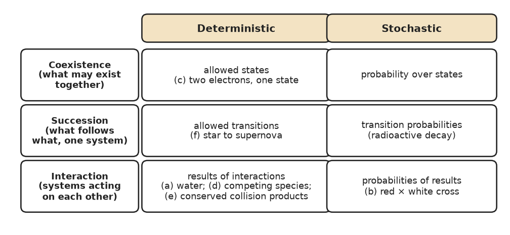

1. **The test (Table 13.1.1).** A law of *coexistence* selects which states or combinations of states are allowed to exist together. A law of *succession* gives the allowed transitions from one state to the next in a system. A law of *interaction* gives the result when two or more systems act on each other. Each kind is deterministic if it gives a definite result and stochastic if it gives probabilities.

2. **(a) and (e) are laws of interaction.** In (a), two systems, oxygen and hydrogen, react, and the law states the definite result. In (e), particles collide and the law states the allowed results. Because (e) works by ruling out every set of products that fails to conserve energy, momentum and quantum numbers, it also acts as a law of coexistence: it selects which final states may exist. It fixes what is allowed, not which allowed outcome happens, so the actual products are a matter of probability.

3. **(b) and (d) combine interaction with succession.** In (b), two plants are crossed (an interaction), and the result is the next generation (a succession from parents to offspring). It is stochastic because it gives proportions, 25%, 25% and 50%, which are probabilities for each seed. In (d), two species interact by competing for one niche, and the law says how the situation must develop over time: one species dies out or moves to a new niche.

4. **(c) is coexistence and (f) is succession.** The exclusion principle in (c) says which combinations of states two electrons may occupy at the same time; nothing changes and nothing interacts. In (f), a single system, a star, passes from one state to the next: fuel exhausted, core no longer supporting the outer layers, collapse, supernova.

5. **Two statements contain errors that do not change their type.** In (a), molecules of oxygen and hydrogen balance as O₂ + 2 H₂ → 2 H₂O, so one mole of oxygen molecules gives 2 moles of water; the statement is right only if it counts moles of atoms (one mole of O atoms and two moles of H atoms make one mole of water). In (b), a pure red plant crossed with a pure white plant gives 100% pink offspring when neither colour is dominant. The 25 : 50 : 25 red : pink : white ratio comes from crossing two pink (hybrid) plants.

Note*Outside the readings: the balanced equation for water, and incomplete dominance in flower colour (the pink hybrid). (c) is the Pauli exclusion principle and (d) is the competitive exclusion principle of ecology.*

U13-SG04Study guide

Determine whether each of the following explanations is formal, causal, statistical or functional, or some mixture of these types.

a. The chameleon’s ability to change colour evolved as a means of protective camouflage.

b. The litmus paper changed colour because the solution it was dipped into is acidic.

c. The neurotic behaviour of thoroughbred horses and of some breeds of dogs is a result of excessive inbreeding.

d. Excessive inbreeding is not recommended because it tends to reinforce negative genetic traits.

e. Play gives young animals the opportunity to practise behaviours, such as stalking, fighting and fleeing, which will be important for them in adult life.

f. HCl is corrosive because it is an acid.

g. If an individual shows a recessive trait, it means that both of that individual’s parents carried that trait.

h. There was a storm yesterday because a low-pressure zone moved into the area, and bad weather usually follows a drop in atmospheric pressure.

Source Unit 13 Study Questions question 4

| **Explanation** | **Type** |
| --- | --- |
| a. chameleon colour change | functional, with an evolutionary (causal) element |
| b. litmus paper | causal |
| c. inbred horses and dogs | causal, with a statistical element |
| d. inbreeding not recommended | statistical and causal |
| e. play in young animals | functional |
| f. HCl is corrosive | formal |
| g. recessive trait | formal and causal |
| h. yesterday's storm | causal and statistical |

1. **The four forms (Discussion 13.1).** A *formal* explanation says a property belongs to the category the thing is in. A *causal* explanation gives initial conditions and the natural laws that make the event follow. A *statistical* explanation shows that the event was highly probable. A *functional* explanation says a thing is as it is because being so serves a function. Signal words help: "because it is a ..." (formal), "because X happened" (causal), "tends to" or "usually" (statistical), "as a means of" or "in order to" (functional).

2. **(a) and (e) are functional.** The chameleon's colour change is explained by what it does for the animal, protective camouflage, which gives it survival value; the word "evolved" adds the causal history behind the function. Play is explained by what it serves: practice for stalking, fighting and fleeing in adult life.

3. **(b) and (c) are causal.** In (b), the initial condition (the solution is acidic) and the law that acids turn litmus red produce the event. In (c), excessive inbreeding is named as the cause of the neurotic behaviour. It has a statistical side because it applies to breeds as a tendency, not to every animal.

4. **(f) is formal and (g) mixes formal with causal.** Corrosiveness is explained as a property of the category "acid" to which HCl belongs; nothing is said about how acids attack materials, which is the danger of formal explanation. In (g), the conclusion follows from what "recessive" means, a trait that shows only when an individual has two copies of the allele, together with the mechanism of inheritance, one copy from each parent. It is not statistical: it holds every time.

5. **(d) and (h) combine causal with statistical.** In (d), inbreeding is the cause, and "tends to" makes the link a probability, not a certainty. In (h), a cause is stated, the low-pressure zone moving in, and it is backed by a regularity that holds only "usually." Note that the drop in pressure is the common cause of the barometer's fall and of the storm (Discussion 13.1), so a falling barometer would not be a cause of the storm.

Note*Outside the readings: acids turn blue litmus paper red.*

U13-SG05Study guide

State which of the four causal principles described in Discussion 13.1 applies in each of the cases outlined below.

a. The British bacteriologist Sir Alexander Fleming (1881-1955) carried out a series of experiments in which dishes of bacteria were cultured. Fleming noticed that some sort of mold had contaminated one of the dishes. He also noticed that there were circles around the spots of mold where the bacteria had died. He recognized that the mold must be producing some anti-bacterial agent, and thus discovered penicillin.

b. In the 19th century the orbits of Mars, Jupiter and Saturn showed irregularities that could not be accounted for using Newton’s theory of gravity. On this basis, it was predicted that there was another planet beyond Saturn. This prediction led to the discovery of Uranus. Later, yet another outer planet was predicted on the basis of further orbital irregularities, leading to the discovery of Neptune.

c. Unexplained irregularities were later observed in the orbit of the planet Mercury, and on this basis some astronomers began to search for a new planet, closer to the sun than Mercury. No planet was ever found, and the irregularities in Mercury’s orbit were only explained by Einstein’s general theory of relativity.

d. There are statistically significant correlations between being good at mathematics, being nearsighted, being left-handed, being susceptible to allergies and autoimmune diseases, and being male. Investigators have hypothesized that all of these phenomena are a result of the effect of testosterone on the developing brain of a fetus.

e. A spray of particle tracks observed in a bubble chamber cannot have been caused by a collision event in which quantum numbers are not conserved.

Source Unit 13 Study Questions question 5

The four principles of causal simplicity (Discussion 13.1): *uniformity* (similar causes have similar effects, and deviations in effects need specific causes); *stability* (no change occurs without a cause); *composition* (a causal explanation must agree with the known behaviour of the components); *common cause* (a constant correlation suggests a shared cause, not that one event causes the other).

1. **(a) Stability, supported by uniformity.** The bacteria died only in circles around the mold. A change, the death of the bacteria, does not happen without a cause, so Fleming inferred one: something produced by the mold. Uniformity supports the inference, because the same effect, a clear circle, appeared around every spot of mold, so the same cause was acting each time.

2. **(b) Uniformity, supported by stability.** Newton's law of gravity applies the same way to every planet, so a planet that deviates from its calculated orbit must be acted on by a specific causal factor, here an unseen planet. The deviation from the expected motion cannot be uncaused, which is the principle of stability. The method worked: the predicted planet was found.

3. **(c) Uniformity and stability again, with a lesson.** Astronomers reasoned exactly as in (b) and looked for a new planet inside Mercury's orbit. None was found. The principles say that a deviation has a cause; they do not say what the cause is. Here it was not an object but a limitation of Newton's theory itself, which Einstein's general theory of relativity corrected. Applying a principle guides the search; it does not replace the evidence.

4. **(d) Common cause.** Several traits are correlated with one another, but the investigators do not claim that one causes another (that being left-handed causes nearsightedness, for example). Instead they propose a single common cause, the effect of testosterone on the developing brain before birth, on which all the traits depend.

5. **(e) Composition.** Any causal account of the tracks must agree with the known behaviour of the particles involved, which always conserve energy, momentum and quantum numbers. An explanation that contradicts those laws is ruled out before any further testing, which is how the principle of composition follows from the principle of contradiction.

Note*Correction to the history in (b): Uranus was not predicted. William Herschel found it in 1781 while surveying the sky, partly by chance and partly thanks to a telescope with very high magnification (Derry p. 48). It was a small discrepancy in the orbit of Uranus, not of Mars, Jupiter and Saturn, that led J. C. Adams and U. LeVerrier to predict a new planet, which J. G. Galle found in 1846: Neptune (Derry pp. 48-50). The principle at work is the same, so the answer does not change.*

Note*Outside the readings: LeVerrier also reported the excess in Mercury's orbit (1859) and the planet sought inside it was nicknamed "Vulcan"; general relativity accounted for the excess in 1915. The testosterone proposal in (d) is the Geschwind-Galaburda hypothesis of the 1980s; later studies have disputed several of the correlations it links.*

U13-SG06Study guide

Give at least one example, other than those already given in the discussion of each of the six types of theories described in Discussion 13.1, part three.

Source Unit 13 Study Questions question 6

| **Type** | **Example** | **Why it is this type** |
| --- | --- | --- |
| Intuitional | Maslow's hierarchy of needs | explains behaviour after the fact, cannot predict what one person will do |
| Historical | giant-impact origin of the Moon | reconstructs a single past collision; predicts traces in Moon rocks |
| Qualitative | ecological succession after a fire | orders qualitative stages to anticipate recovery |
| Taxonomic | Mendeleev's periodic table | classifies elements; predicts properties from a place in the table |
| Statistical | radioactive decay | gives probabilities (half-life) for large numbers of atoms |
| Dynamical | Lotka-Volterra predator-prey equations | a state plus equations of motion fix every later state |

1. **Intuitional and historical.** Maslow's hierarchy says people satisfy basic needs (food, safety) before higher ones (belonging, esteem, self-fulfilment). It makes behaviour intelligible after the fact but cannot predict what a given person will do, like the course's example of Freud. The giant-impact theory says the Moon formed from debris after a Mars-sized body struck the early Earth. The event cannot be repeated, but the theory must match the traces it would leave, such as Moon rocks that resemble the Earth's mantle and a Moon with only a small iron core.

2. **Qualitative and taxonomic.** Ecologists describe how a burned forest recovers in qualitative stages (grasses and herbs, then shrubs, then young trees, then mature forest) and use those stages to anticipate what will grow next. The periodic table classifies elements by their properties; from the place of a gap, Mendeleev predicted unknown elements and their properties, and gallium and germanium were later found to fit.

3. **Statistical and dynamical.** Radioactive decay theory cannot say when one atom will decay, only the probability per unit time, which gives a definite half-life for a large sample: a theory of ensembles, not of single states. The Lotka-Volterra equations take the numbers of predators and prey (the state) and equations of motion (the transition rule) and determine all later states, predicting regular population cycles.

4. **How the types differ in prediction.** They form a range: intuitional theories explain but barely predict, historical theories predict only traces of the past, qualitative and taxonomic theories predict from patterns and class membership, statistical theories predict frequencies, and dynamical theories predict exact future states. All six still have to be judged by Margenau's criteria.

5. **Mixtures are common.** As with the course's examples of plate tectonics and particle physics, real theories often combine types. The periodic table began as a taxonomic theory and was later explained by the quantum theory of the atom, and ecology uses both qualitative succession stages and statistical population models.

Note*Outside the readings: all six examples. Mendeleev published his table in 1869-1871; gallium was found in 1875 and germanium in 1886. The examples avoid the course's own (Freud, the dinosaur impact, weather, biological systematics, population genetics, Newtonian mechanics).*

U13-SG07Study guide

In Discussion 3.2, we considered science as a question-and-answer process, and described the qualities of a good question and the criteria for a valid answer. A scientific theory can be seen both as providing an answer to a general question and as a framework within which answers can be given to more specific questions. With this in mind, write a short essay (300-500 words) comparing the qualities of a good question, the criteria for a valid answer, and the six criteria for a good theory given in Discussion 13.1, part three.

Source Unit 13 Study Questions question 7

Discussion 3.2 describes science as a process of questions and answers. A good question has depth (it goes to the heart of a situation), is tantalizing (it seems to hold out the possibility of an answer), is suggestive (it almost tells one how to look for the answer) and is fruitful (its answer will matter for several areas of science). A valid scientific answer must not violate an established empirical fact unless it explains why the violations have not yet been observed, must be consistent with existing theories or give a good reason for changing them, and must not involve a logical contradiction. Discussion 13.1 adds Henry Margenau's six criteria for a good theory: logical fertility, multiple connection, stability, extensibility, causal connections, and simplicity and elegance. Because a theory is both an answer to a general question and a framework for further questions, the three lists fit together closely.

Seen as an *answer*, a good theory must first pass the tests for a valid answer. Its constructs must be multiply connected, to each other and to observation, which is the positive form of being consistent with existing theories and facts. It must be stable, able to adapt to new data, which is how it avoids violating established facts. Its logical structure and its demand for simplicity rule out contradiction. And by providing causal connections it does more than describe phenomena: it explains them, which is what makes an answer satisfying.

Seen as a *framework*, a good theory must generate good questions. Logical fertility, the power of its constructs to support "fruitful deductions and the construction of hypotheses," is the theory-level version of a suggestive question: it tells us where to look next. Extensibility, application beyond the theory's original area, matches a fruitful question whose answer matters across several sciences. Depth matches causal connections, since both go to the heart of a situation. A tantalizing question promises an answer, and an elegant theory delivers the feeling Discussion 13.1 describes, that something is "very simple." Newton's mechanics shows all of these at once: it answered why the planets move as they do, connected falling bodies, tides and orbits, and raised new questions, such as the irregular orbit of Uranus that led to the discovery of Neptune.

The comparison also shows a difference. The qualities of a good question are about promise, the criteria for a valid answer are minimum standards, and the criteria for a good theory are about long-term value. A question can be good and still unanswered, and an answer can be valid yet narrow. A good theory must be both a valid answer and a source of good questions. As Heinz von Foerster suggested (Discussion 3.2), a field dies not when it fails to answer old questions but when it stops generating new ones, which is why logical fertility and extensibility matter so much.

U13-SG08Study guide

Why, in the Big Bang Theory, would we expect more distant galaxies to be older than nearby ones?

Source Unit 13 Study Questions question 8

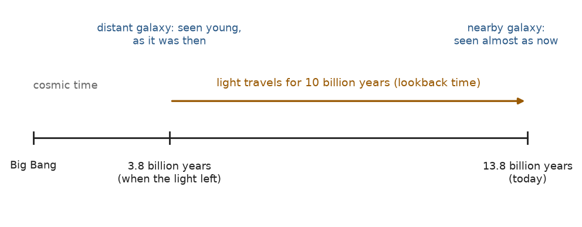

1. **Distance is look-back time.** Light travels at a finite speed, so light from a distant galaxy left it long ago. We see each galaxy as it was when its light set out: a nearby galaxy as it was recently, a very distant one as it was early in the history of the universe.

2. **In the Big Bang theory the universe has a history.** It began in a hot, dense state and has been changing ever since. So the farther out we look, the earlier the stage of that history we see, and the population of galaxies should change systematically with distance. Discussion 13.2 states the expectation as: "In the big bang theory, the more distant galaxies ought to be older than nearby galaxies."

3. **In the Steady State theory it has no history.** The universe has always looked much as it does now, with new matter continually created as it expands, so young and old galaxies should be mixed in the same way at every distance. A link between distance and age therefore tests one theory against the other.

4. **What "older" means here.** What is older is the *light* and the *epoch* we are seeing. The distant galaxies themselves are seen at an earlier stage of their development, closer to the beginning, so in that sense they should look *younger*, not more developed. The prediction the question has in mind is that distant galaxies should belong to an earlier era and look different from nearby ones (Applied question 16).

5. **What the evidence showed.** A 1948 survey seemed to find older galaxies farther away, but a 1954 review showed that the effect came from the measurements, so the test was inconclusive. Ryle's radio survey (published in 1955) claimed evidence that distant sources differ from nearby ones, though Steady State supporters disputed it for years. The background radiation, recognized in 1965, finally decided the question (Discussion 13.2).

Note*Course wording: "older" is ambiguous here. Read it as "seen at an earlier time"; a galaxy seen as it was billions of years ago is seen in its youth.*

U13-SG09Study guide

Write a short essay (300-500 words) analyzing the history of modern cosmology as presented in Discussion 13.2. Focus attention on the different factors contributing to the modern theory and the underlying theoretical assumptions that were involved in the development of this theory.

Source Unit 13 Study Questions question 9

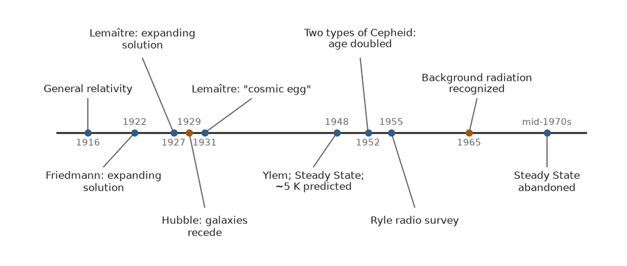

Discussion 13.2 shows that modern Big Bang cosmology was not the product of one discovery. Theory, observation, new technology, a rival theory and even religion interacted over half a century, and the whole development rested on assumptions that were rarely stated.

**Theoretical factors.** Einstein's general theory of relativity (1916) gave cosmology its mathematical foundation. Friedmann (1922) and Lemaître (1927) found solutions describing an expanding universe, but these were treated as mathematical exercises until 1930, when Lemaître's work was compared with Hubble's observations. In 1931 Lemaître proposed the "cosmic egg," the first version of the Big Bang. After the war, Gamow, Alpher and Herman applied new nuclear theory to calculate how the elements were "cooked" from the hot, dense Ylem.

**Observational and technological factors.** With the 100-inch telescope on Mount Wilson and Cepheid variables as distance markers, Hubble showed that the spiral nebulae are galaxies and that they are receding: the universe is expanding (1929). Early electronic computers made the element calculations possible. Radio astronomy, beginning with Ryle's survey, and the Bell Laboratories antenna of Penzias and Wilson supplied the decisive evidence: a uniform background radiation at about 3 K, which Dicke and Peebles recognized in 1965 as the signature of the Big Bang.

**Rival theory and the correction of errors.** Hoyle, Bondi and Gold's Steady State theory was a serious rival. It even seemed to solve a real problem: running the expansion backward gave an age for the universe that was less than the age of the Earth. That problem shrank when astronomers found that Cepheids come in two types, which doubled the estimated age. A promising test, distant galaxies looking older, turned out to be an artifact of measurement. And the Big Bang's failure to explain the heavier elements was answered by Hoyle's own work on nucleosynthesis in stars.

**Social factors.** The Second World War halted progress in the 1940s. Hoyle named the "Big Bang" sarcastically, and when the Pope claimed it affirmed a Creator, Bondi replied that a singularity might be removed by better mathematics.

**Underlying assumptions.** The development assumed that the laws of physics found on Earth hold everywhere and at all times; that general relativity describes the universe as a whole; that the Cepheid period-brightness relation measures distance; that the expansion can be run backward to give an age; and that the elements were made by known nuclear processes. Each side also had its own ideal of natural order: an unchanging universe for the Steady State, which required matter to be continuously created, and an evolving universe for the Big Bang. An error in an auxiliary assumption, one type of Cepheid instead of two, first counted against the Big Bang and later, once corrected, counted for it, which shows that observations test whole networks of assumptions, not single hypotheses.

In short, the modern theory won because an evolving-universe framework, supported by independent lines of evidence and corrected assumptions, made a successful prediction that its rival could not match.

Note*Course dates: the estimate of about 5 K for the leftover radiation was published in 1948 by Alpher and Herman, Gamow's collaborators (the course credits Gamow). Penzias and Wilson made their measurements in 1964 and published in 1965 (the course says 1963). Pope Pius XII's address was given in November 1951 (the course says 1952).*

Note*Outside the readings: the two types of Cepheid were identified by Walter Baade (1952). Doubling the age took Hubble's value of about 2.0 billion years to about 3.9 billion, still a little short of the Earth's 4.5 billion years; further corrections in the late 1950s raised it well above. The ages were computed in stats13.py as 1 ÷ H₀ for 500 and 250 km/s per megaparsec.*

### Learning objective questions12

U13-OBJ01Objective

discuss the differences between the Aristotelian and Baconian views on the uses of scientific theory.

Source Unit 13 Overview objective 1

1. **The Aristotelian view: theory is for contemplation.** In the older Greek view, the purpose of theory was to aid the contemplation of nature, through which a person nourished his or her spiritual growth. The Greek word *theoria* meant "vision," so a theory gave a person a vision of the world (Unit 13 Overview).

2. **Plato's version.** In the *Republic*, the study of science, and especially mathematics, trains the mind to rise from the changing and illusory world of experience to transcendental ideas such as Justice, Truth and Beauty. In the *Symposium* the same ascent is an ever-widening appreciation of beauty. The person who completes it gains the wisdom to govern both themselves and the state.

3. **The Baconian view: theory is for use.** Francis Bacon criticized the "empty" speculations of Aristotelian academics. For him the role of knowledge was to reduce human suffering, so theory is judged by its power to control nature and by its practical applications. This view dominates modern society.

4. **The differences.** The two views differ in their goal (inner understanding against outer control), in their measure of success (wisdom and vision against useful results) and in who benefits (the knower's character against society's welfare). Yet the same theory can serve both: Newton's mechanics gives a vision of an ordered cosmos and also lets engineers launch satellites.

5. **Why the old view may return.** The Overview notes that advances in cognitive science are turning attention to mind, understanding and consciousness, which may bring new appreciation of the Aristotelian view. It also suggests that Plato is relevant when scientific power has outstripped moral development, since the proper use of power over nature is a question of wisdom, not of technique.

Note*Course dates: the Overview places the change in the late 16th century. Bacon's main statements appeared in 1605 (The Advancement of Learning) and 1620 (Novum Organum), so it is usually dated to the early 17th century.*

U13-OBJ02Objective

discuss the importance of experimental tests of the theories, and the condition that must be met if a particular experiment is to provide us with a good test of a theory.

Source Unit 13 Overview objective 2

1. **Why tests matter.** The Overview states that theories "must be both internally coherent and empirically testable, at least in principle." Testing is what ties a theory to appearances. A belief that the world was created in 4004 BCE, but made to look billions of years old, can never be tested, so it must be accepted on faith and is not science.

2. **Tests drive progress both ways.** A theory that passes a bold test gains credibility, as general relativity did when the bending of starlight it predicted (1915) was observed during the 1919 eclipse. A failed test exposes error, as radioactivity did for the belief that elements never change (Derry pp. 199-201).

3. **The condition for a good test.** The theory must make a definite prediction of the form "If A then B" that could turn out false, and the experiment must be able to tell whether B happens. A result that would fit the theory however it came out tests nothing: the invisible substance proposed to keep Galileo's Moon a perfect sphere could not be observed, so the claim could not be falsified (Derry p. 200).

4. **The experiment must really reach the prediction.** Discussion 3.2 gives the practical checks. The procedure must not disturb the system's natural behaviour; the system must be capable of the behaviour; the equipment must be able to detect the expected result (stellar parallax was predicted long before instruments could measure it); the initial state must be properly prepared; and the procedure must not destroy the system in a way that invalidates the result.

5. **Nothing else may explain the result.** A good test also controls other causes, by a control group or a baseline, so that agreement or disagreement can be traced to the theory and not to some other factor. Even then, a failure may lie in an auxiliary assumption, such as the theory of the instruments, rather than in the theory itself (the Quine-Duhem thesis, Derry p. 201).

Note*Synthesis: no Unit 13 page states the condition in one sentence. This answer combines the Overview, Discussion 3.2 and Derry pp. 199-201.*

U13-OBJ03Objective

describe, and discuss the relationship between, confirmation and refutation, as they apply to theories in science.

Source Unit 13 Overview objective 3

1. **Confirmation.** A theory is confirmed when an observation agrees with one of its predictions. Confirmation supports the theory provisionally but never proves it, because induction from past successes is not a proof: the immutability of elements had been confirmed countless times before radioactivity showed it was false (Derry pp. 199-200).

2. **Refutation.** A theory is refuted (falsified) when an observation contradicts one of its predictions. In logic, one genuine contradiction is enough to show that something in the reasoning is false. This is why Popper's falsificationism asks a theory to make statements that observation could show false.

3. **The asymmetry.** "We can never prove a theory is right, only that it's wrong" (Derry p. 200). Many confirmations do not prove a theory; one solid refutation can sink it. Science therefore accepts theories provisionally, for as long as they continue to be confirmed.

4. **In practice the relationship is looser.** Falsification is rarely enforced strictly. Stellar parallax, predicted by Copernicus's theory, was not seen until about 1840, about 300 years later, yet the theory was rightly kept: a good theory with many confirmations is not abandoned over a few discrepancies (Derry p. 200). The Quine-Duhem thesis adds that any observation can be accommodated by adjusting other assumptions, so no single experiment is logically decisive (Derry p. 201).

5. **How they work together.** Both drive science. Bold confirmations, such as the bending of starlight in 1919, give new theories credibility, and refutations of accepted ideas, such as the transmutation of elements, force change (Derry p. 201). In the course's model, confirmation runs up the theory ladder from appearances to theory, while a refutation sends scientists back down it to find which assumption failed.

U13-OBJ04Objective

describe the nature of a controlled experiment, and relate it to the method of comparison described in Discussion 11.2.

Source Unit 13 Overview objective 4

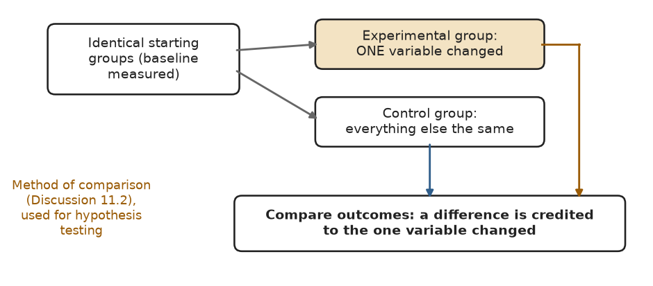

1. **What a controlled experiment is.** The experimenter changes one independent variable at a time while holding everything else constant (Discussion 14.1), then compares a group that receives the change (the experimental group) with a group that is the same in every other way (the control group). Any difference in outcome can then be traced to the variable changed.

2. **The method of comparison (Discussion 11.2).** Comparing similarities and differences between entities thought to be related. It needs a goal, tools suited to the goal, and dimensions of comparison that are relevant to the goal and measurable with the tools. Its uses are classification, historical reconstruction, the search for generalizations and hypothesis testing.

3. **The relationship.** A controlled experiment is the method of comparison used for hypothesis testing, under conditions the experimenter has arranged. Instead of comparing things as nature provides them, the scientist creates two cases that differ in only one dimension, the one the hypothesis is about.

4. **The course's example.** In selective-lesioning studies, rats are tested first to measure their normal behaviour, then different brain segments are removed in different groups, and the groups are compared with the normal measure and with each other (Discussion 11.2). The comparison is deliberate, and every group differs in a known way.

5. **Its limits.** Changing one variable at a time works well in simple systems, but Discussion 14.1 warns that it cannot always be applied to biological, social and psychological systems, where behaviour comes from many interdependent interactions. The lesioning example shows the problem: a rat that stops responding to a bell may simply be unable to hear it (Discussion 11.2).

U13-OBJ05Objective

discuss the need for a control group or a baseline expectation in order to interpret the implications of a controlled experiment.

Source Unit 13 Overview objective 5

1. **An effect needs a reference point.** A result means something only when compared with what would have happened anyway. The control group, or a baseline measurement taken first, supplies that reference, so a difference can be credited to the variable that was changed.

2. **What it rules out.** Without a control, an improvement or decline could be due to time, chance, the season, the experimenter's expectations or the subjects' own expectations. With a control that shares all of these, only the changed variable remains to explain the difference.

3. **Course examples.** Rats are tested before brain lesioning "to establish a measure of their normal behaviour and capacities" (Discussion 11.2). Studies of power lines and health were weakened because few good measures of "dose" were possible, "especially compared to a control group reflecting the general population" (Derry p. 142).

4. **It connects with the course's view of explanation.** Discussion 13.1 says theories explain deviations from an expected ideal of natural order. A baseline is the experimental form of that ideal: it fixes what is "normal," so a deviation can be recognized and explained.

5. **Proving causes.** To show that something is a cause, we must show that it is both a necessary and a sufficient condition for the effect, which "can sometimes be accomplished by a detailed series of carefully controlled experiments" (Derry p. 97). Without a control or baseline neither condition can be shown, because the effect might have occurred without the supposed cause.

U13-OBJ06Objective

explain how theories allow description, prediction and explanation in science.

Source Unit 13 Overview objective 6

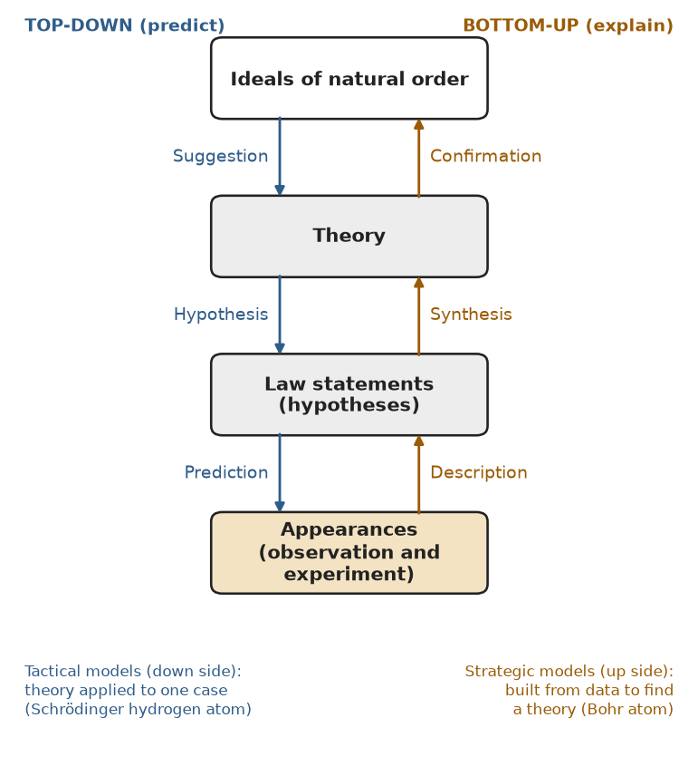

1. **Theories work at the level of empirical thought.** Kant's model distinguishes sensations, apprehensions (sensations located in space and time), perceptions (apprehensions brought under a conceptual scheme) and empirical thought. A theory is a set of relationships among abstract categories, together with rules of construction and inference (Discussion 13.1).

2. **Description.** A theory supplies a conceptual taxonomy: the categories in which observations can be described. Looking out a window, the mind "carves at the joints" and names a tree, a car and a building; a theory does the same for scientific data, so that a measurement becomes "the period of a Cepheid" or "a recessive trait."

3. **Prediction.** The rules of inference turn a hypothetical description into statements of the form "If A then B": if conditions A are produced, event B will occur, or occur with a predicted probability that can be tested statistically. Seeing buds on the limbs of a tree, I can infer that in a few days they will blossom.

4. **Explanation.** We have explained a phenomenon when we can describe it so that it is only what would be expected from our ideals of natural order, and can give the theoretical mechanisms that account for any deviations from those ideals. Explanations can be formal, causal, statistical or functional, and this is a loose form of the covering-law model.

5. **The ladder and understanding.** Going down the ladder (ideals, theory, law statements, predictions) gives prediction; going up (appearances, description, synthesis, confirmation) gives description and explanation. Understanding goes further still: the theory's structures must work inside the person as an organizer of perception (Plato's "fifth").

U13-OBJ07Objective

discuss the relationship between theories and experiments.

Source Unit 13 Overview objective 7

1. **A two-way relationship.** Theories and experiments form a cycle. Top-down, a theory generates hypotheses and predictions that experiments test (tactical modeling). Bottom-up, experimental regularities are described, synthesized into law statements and built into theories, often through strategic models (Discussions 11.3 and 13.1).

2. **Experiments test theories.** Agreement confirms a theory provisionally; disagreement shows that something must change. Theories must be testable, at least in principle, to count as scientific.

3. **Theories guide experiments.** A theory tells scientists which experiments are worth doing and what to look for. Gamow's group predicted leftover radiation from the early universe, and the Big Bang theory told Dicke and Peebles what the background radiation found by Penzias and Wilson meant (Discussion 13.2).

4. **Theories shape how results are read.** Facts are theory-laden (Derry p. 199): theories act as filters on perception and tend to force new results into existing categories. Kuhn describes data that conflict with a paradigm being set aside until the contradictions become overwhelming (Discussion 13.1).

5. **New experiments can overturn theories.** New instruments and observations, such as Hubble's 100-inch telescope or the radio telescopes behind Ryle's survey, can produce results that force theories to change. But because experiments test whole networks of assumptions, a failed result may be traced to an auxiliary assumption first (the Quine-Duhem thesis, Derry p. 201).

U13-OBJ08Objective

discuss the relationships among theories, models, paradigms and ideals of natural order.

Source Unit 13 Overview objective 8

1. **Metaphysical assumptions underlie everything.** Nature is ordered; the order is comprehensible to human reason; and our understanding of it can be communicated (Discussion 13.1).

2. **Paradigms.** On top of these sit paradigmatic assumptions: what kinds of reasoning are scientifically acceptable, what fundamental entities exist, how they interact and what questions may legitimately be asked. A paradigm is the shared framework of a scientific community (Kuhn).

3. **Ideals of natural order.** Some paradigmatic assumptions are ideals of natural order: assumptions about how nature would behave with no interference, accepted without question. Only deviations from them need explaining. Newton's ideal that a body moves in a straight line at constant speed unless a force acts on it is an example.

4. **Theories.** Theories are abstract conceptual structures that mediate between the ideals of natural order and the observed regularities of nature. They explain deviations from the ideals and so give us sufficient reasons to believe we understand why things are as they are and not otherwise.

5. **Models.** Models connect theories to particular cases. A tactical model applies a theory to a specific situation, top-down (the Schrödinger equation for the hydrogen atom); a strategic model is built from observations in the hope of finding a theory, bottom-up (the Bohr atom) (Discussion 11.3). Below them are law statements and the appearances they describe, as in the course's Figure 13.1.3.

Note*Outside the readings: Newton's first law as an ideal of natural order is the standard example from Toulmin, who introduced the term.*

U13-OBJ09Objective

explain what it means to “understand” a scientific theory, and describe the differences between scientific theories and beliefs or opinions.

Source Unit 13 Overview objective 9

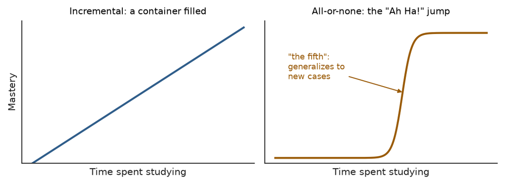

1. **Knowing the statements is not enough.** A physicist must not only learn the statements of quantum mechanics but know how to use them, analytically and by analogy, in a wide range of circumstances (Discussion 13.1). Understanding a theory means grasping its patterns of thought, not just its content.

2. **Understanding is internal.** A person understands a theory when its mental structures have been incorporated so that they function "as an information processor and an organizer of perception." This comes with the all-or-none learning curve, the "Ah Ha!" experience, and lets the learner generalize to analogous cases outside the original area. It corresponds to Plato's "fifth," the stage at which the theory is applied automatically.

3. **Theories are testable; beliefs and opinions need not be.** A scientific theory must be internally coherent and empirically testable, at least in principle. A belief such as the world's creation in 4004 BCE, made to look old, can never be tested and must be taken on faith (Unit 13 Overview).

4. **Theories are judged by the criteria for valid answers.** A scientific answer must not violate established facts, must be consistent with existing theories or give a good reason to change them, and must not be self-contradictory. Answers such as "it is obvious," "it just feels right," "it is the will of God" or "it is morally and ethically correct" may satisfy other areas of life but are inadmissible in science (Discussion 3.2).

5. **Theories are provisional and public.** A theory is held only while it continues to be confirmed and can be shared, checked and criticized by others. An opinion can be held regardless of evidence. A theory also has to meet Margenau's criteria, such as logical fertility and causal connections, which an opinion is never asked to meet.

U13-OBJ10Objective

describe six types of scientific theories, and state six criteria for a good theory.

Source Unit 13 Overview objective 10

| **Six types of theory** | **Course example** | **Six criteria for a good theory (Margenau)** |
| --- | --- | --- |
| Intuitional | Freud's theory of neurosis | logical fertility |
| Historical | impact extinction of the dinosaurs | multiple connection |
| Qualitative | weather prediction | stability |
| Taxonomic | biological systematics | extensibility |
| Statistical | population genetics | causal connections |
| Dynamical | Newtonian mechanics | simplicity and elegance |

1. **Intuitional and historical theories.** Intuitional theories give an intuitive understanding through general principles but lack predictive power: Freud's theory can explain a neurosis after the fact but cannot predict one. Historical theories reconstruct unique past events and predict only the traces those events left: the impact theory of the dinosaurs' extinction predicted signs of a great impact about 65 million years ago, later found in the Chicxulub crater.

2. **Qualitative and taxonomic theories.** Qualitative theories organize masses of qualitative observations for heuristic and predictive power, as in weather prediction. Taxonomic theories classify and recognize phenomena and predict from class membership, as in biological systematics.

3. **Statistical and dynamical theories.** Statistical theories are non-deterministic and mathematical, predicting probabilities for ensembles of events, as population genetics predicts gene frequencies. Dynamical theories are deterministic: a state space and equations of motion fix every future state, as in Newtonian mechanics. Many theories mix types.

4. **Margenau's criteria, first three.** The theory's constructs should have *logical fertility*, giving a basis for fruitful deductions and new hypotheses; they should be *multiply connected*; and the theory should be *stable*, able to adapt to new data.

5. **Margenau's criteria, last three.** The constructs should be *extensible*, applying beyond the theory's original area; the theory should provide *causal connections* between phenomena and the events it explains; and it should strive for *simplicity and elegance*. The criteria apply to all six types.

Note*The dinosaur impact is now dated to about 66 million years ago; the course gives 65 million.*

U13-OBJ11Objective

describe the nature and role of laws in science, and define laws of coexistence, succession and interaction.

Source Unit 13 Overview objective 11

1. **What laws are.** On the general view, natural laws are descriptions of empirical regularities. They are neither true nor false, only more or less accurate statements of what will happen in given circumstances. On the Platonic view, laws are real relations between abstract universals, and our statements of them are partial expressions in our best available frameworks (Discussion 13.1).

2. **Law statements depend on the framework.** "What goes up must come down," Aristotle's natural places, Newton's inverse-square force and Einstein's curved spacetime are different statements of one regularity. The theories change; the regularity they describe does not. "The map is not the territory."

3. **Their role.** A law statement gives a precise, concise and simple statement of an observed regularity, ideally in mathematical form. Theories then explain the law statements, and the law statements connect the theories to observations, as in the course's Figure 13.1.3.

4. **Coexistence and succession.** A law of *coexistence* selects which states or representations may exist together (deterministic) or gives a probability distribution over them (stochastic); the exclusion principle for electrons is an example. A law of *succession* gives the allowed transitions between states (deterministic) or their probabilities (stochastic); the stages of a star's life follow one.

5. **Interaction.** A law of *interaction* describes the result of allowed interactions between systems (deterministic) or the probabilities of specified results (stochastic); the conservation rules for a particle collision and the outcome of crossing two plants are examples. Table 13.1.1 sets out all six combinations.

U13-OBJ12Objective

state four principles of causality that are important in science.

Source Unit 13 Overview objective 12

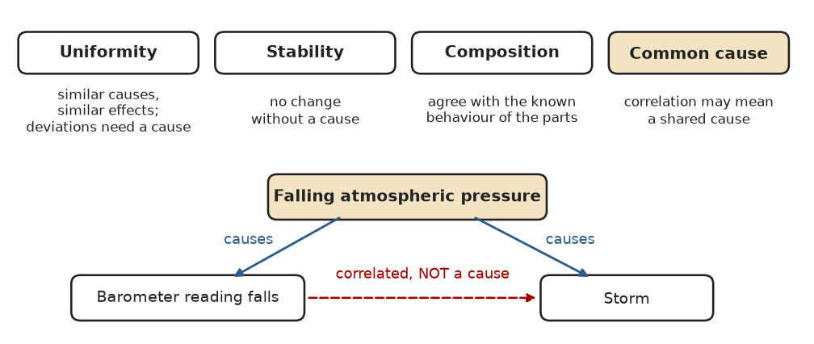

1. **Uniformity.** Similar causes tend to have similar effects, and vice versa; deviations in effects must result from specific causal factors. It applies the identity of indiscernibles. Chaos theory and non-linear systems challenge it, because very small differences in a cause can produce very large differences in effect.

2. **Stability.** Change does not occur without a cause. It is related to the principle of sufficient reason but narrower: the only sufficient reason for a change in a system is a causal one.

3. **Composition.** Causal explanations must agree with the known behaviour of the components of what is being explained and must not contradict it; a theory of evolution must not violate the known laws of genetics. It follows from the principle of contradiction.

4. **Common cause.** A constant correlation between two events, such as A always coming before B, does not show that A causes B. It justifies only the assumption that both may depend on a common cause. Before a storm the barometer falls, but the falling barometer does not cause the storm: falling atmospheric pressure causes both.

5. **A warning that goes with them.** Causal thinking tempts us to believe that every phenomenon has only one cause. Ozone depletion can be traced to chemistry, to the refrigerators that use the chemicals or to the people who buy them, so complex systems need to be explained through several causes (Discussion 13.1).

### Lists and concept recall17

U13-R01Recall

Explain this topic from the assigned readings: two views of what theory is for, the Aristotelian and Baconian views on the uses of scientific theory. Give an example or explain its significance in this unit.

Source Two views of what theory is for (Overview)

1. **Two views of the purpose of theory.** Historically, "the late 16th century saw a radical change in the view of the significance of theory" (Unit 13 Overview): the older Aristotelian (Greek) view, in which theory serves contemplation, gave way to the Baconian (modern) view, in which theory serves use.

[output not shown]

2. **Example.** Plato gives the Greek view in practice (Unit 13 Overview). In the *Republic*, science, and mathematics in particular, trains the mind to rise from "the mundane and illusory world of experience to the realm of the transcendental ideas, such as Justice, Truth and Beauty"; in the *Symposium* the same ascent is an ever-widening appreciation of beauty. Plato claimed that the person who made this ascent had the wisdom to govern both self and state.

3. **A possible revival.** Advances in cognitive science are focusing attention on the nature of mind, understanding and consciousness, "a change that may lead to a greater appreciation of the Aristotelian view" (Unit 13 Overview), so that interest in mind may revive respect for theory as vision and not only as a tool.

4. **Significance.** "It is often said that one of the chief problems of the world today is that scientific knowledge has outstripped moral development" (Unit 13 Overview). This gap between scientific power and moral development makes Plato relevant again: the Overview argues his ideas may matter where "a major issue is the proper use of the power over nature that has been gained through science." The Baconian view explains why we have that power; the Aristotelian view asks for the wisdom to use it.

U13-R02Recall

Explain this topic from the assigned readings: what a scientific theory is and does, including description, prediction and explanation. Give an example or explain its significance in this unit.

Source What a theory is and does (Overview; Discussion 13.1)

1. **Definition.** "A scientific theory is an abstract conceptual system that is constructed to explain some aspect of nature" (Unit 13 Overview). Theories "are not just ordered collections of facts, they are conceptual structures ... that transcend and illuminate, but also filter and shape" the content to which they are applied. Poincare's epigraph makes the same point: "a collection of facts is no more a science than a heap of stones is a house" (Unit 13 Overview).

2. **Conceptual bridges.** Theories "are the conceptual bridges between our ideals of natural order and our experience", and so are responsible to both: "a bridge not firmly anchored at both ends is likely to fall down" (Unit 13 Overview). Following Discussion 4.2, all that needs to be explained about a phenomenon is its deviations from the relevant ideals of natural order, and theories provide these explanations.

3. **Coherent and testable.** "Theories must be both internally coherent and empirically testable, at least in principle" (Unit 13 Overview). String theory cannot yet be tested, but tests may become possible with advances in technology. The belief that the world was created in 4004 BCE (or half a second ago) can never be tested, since the world is said to have been created to look billions of years old; "it is a belief that must be accepted on faith alone."

4. **A window and an anchor.** "When we learn a theory, we are engaged in an internal mental construction, and this process changes us" (Unit 13 Overview). The theory becomes an interpretative "window on the world" and, in terms of the cognitive heuristics of Unit 8 (Discussion 8.2), an "anchor": we interpret experience in terms of its categories and concepts.

5. **Patterns that connect.** N. R. Hanson: "theories provide patterns within which data become intelligible"; Gregory Bateson: in trying to understand a thing we should seek "the pattern that connects" (Discussion 13.1). Hanson again: "A theory is not pieced together from observed phenomena; it is rather what makes it possible to observe phenomena as being of a certain sort and as relating to other phenomena."

6. **Describe, predict, explain, understand.** A theory "allows us to describe, explain and predict perceptions", including the results of observation and experiment, and "By fitting perceptions into a conceptual framework in this way, we understand them" (Discussion 13.1). Understanding is more than the three external tasks: it comes under what Plato called "the fifth".

7. **Example.** Aristotle's theory of natural place "saves the appearances" by giving a theoretical system within which what happens is rationalized (Discussion 13.1); the theory is now rejected, yet it shows a theory doing its job of description and explanation.

8. **Significance.** The same structure that lets a theory illuminate also lets it filter: "theories also act as filters on perception" (Discussion 13.1). Filtering gives stability and a secure foundation for communication between scientists, but creativity needs the capacity to view old ideas in a new way, so the scientist must balance the two.

U13-R03Recall

Explain this topic from the assigned readings: two learning curves, the incremental and all-or-none pictures of learning, and Plato's five stages. Give an example or explain its significance in this unit.

Source Two learning curves and Plato's five stages (Discussion 13.1, Part One)

1. **Learning curves.** "A learning curve is a graph that displays the degree of mastery of a subject as a function of the time spent in its study" (Discussion 13.1, Part One).

2. **Incremental learning curve.** Mastery grows steadily with study time (Figure 13.1.1); psychologists do observe such curves. The analogy is the mind as a container that is gradually filled, the picture behind much of the educational system, and "A mind filled with preconceptions is incapable of learning" (Discussion 13.1, footnote 270).

3. **All-or-none learning curve.** In this second kind of learning "almost nothing is learned until there is a sudden jump", an "Ah Ha!" experience, "after which nearly complete mastery is exhibited" (Figure 13.1.2). Learning to ride a bicycle often follows this pattern. Popular culture calls it a light bulb going on; the course describes it as the completion of a mental construct that cannot function "as an information processing unit, or an organizer of perceptions, until all the pieces are in place."

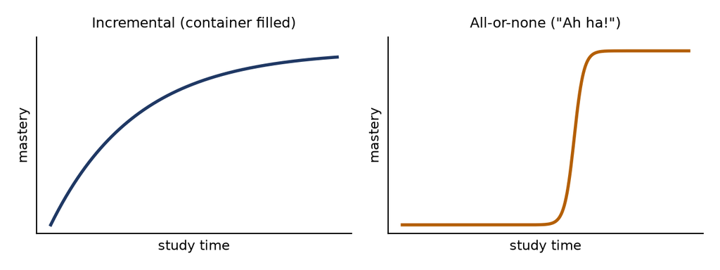

4. **Why the difference matters for science.** Both kinds of learner perform well on tests of subject matter, but only the all-or-none learner can generalize: "they are able to recognize analogous cases in areas outside the area of original study." A filled container can only pour out what it holds; a functioning information processor can handle any fitting input. "Since science seeks generality, this second kind of learning is of particular significance": a physicist must not only learn the statements of quantum mechanics but employ its tools analytically and analogically (Discussion 13.1, Part One).

5. **Plato's five stages.** In his *Seventh Letter*, Plato describes five stages in learning; the course's example is the theory of evolution.

| Stage | What it is | Evolution example |
| --- | --- | --- |
| 1. **The name** | The word and whatever associations it carries | The word evolution and its associations |
| 2. **The definition** | A statement of what the theory says | Change of species and the appearance of new species through variation and natural selection |
| 3. **The image** | Examples that illustrate the theory | Learning a number of examples illustrating evolution |
| 4. **True opinion** | The theory itself: its analytic details and how to apply them | The proficient person, who knows all the rules and how to apply them in different circumstances |
| 5. **The fifth** | Comes only as a "flash of lightning": the theory is internalized until it becomes automatic, recognized whenever it occurs and applied without thought | The expert, who knows the rules intuitively and also knows how and when to break the rules |

6. **The danger: a theory is a filter.** A learned construction "can also act as a filter, excluding those aspects of reality that do not conform to its established patterns of relationships"; the folk saying is "to a man with a hammer, everything looks like a nail" (Discussion 13.1, Part One). A footnote adds the saying that "the proponents of old theories don't change their minds, they just eventually die off."

7. **Kuhn.** In Thomas Kuhn's view, science deals with this by "a refusal to accept data that is not consistent with an existing paradigm until the degree of contradiction becomes so great that discovery of a new paradigm becomes the major goal of the field." In the course's anthropological analogy, certain kinds of mental food (data, interpretations, theorizing) are declared taboo until hunger, the need for secure understanding, overwhelms the taboos (Discussion 13.1, Part One).

8. **Significance.** Understanding, as distinct from description, prediction and explanation, comes under Plato's "the fifth", and "understanding is associated with the learning curves of Figure 13.1.2" (Discussion 13.1, Part Two). A person understands a theory when its structures function "as an information processor and an organizer of perception": the goal of learning a theory is the all-or-none jump, not a filled container.

U13-R04Recall

Explain this topic from the assigned readings: Kant's four aspects of mind, sensations, apprehensions, perceptions and empirical thought. Give an example or explain its significance in this unit.

Source Kant's four aspects of mind (Discussion 13.1, Part Two)

1. **Kant's model of the mind.** In *The Critique of Pure Reason*, Immanuel Kant distinguishes four aspects of the mind (Discussion 13.1, Part Two).

| Aspect | What it is |
| --- | --- |
| 1. **Sensations** | Direct sensory input (William James's "booming buzzing confusion") |
| 2. **Apprehensions** | Sensations located in space and time |
| 3. **Perceptions** | Apprehensions brought under a conceptual scheme ("tree," "car," "window"); "objectified apprehensions" and the basic elements of empirical thought |
| 4. **Empirical thought** | Conceptual thought based on perceptions |

2. **Mediating categories.** Between each level, "categorical frameworks that take input from the lower level and construct the elements of the higher" do the work; Kant saw the step from mere sensation to apprehension as mediated by the categories of space and time (Discussion 13.1, Part Two).

3. **Where a theory operates.** "A theory operates at the level of empirical thought." It is "a collection of relationships among abstract categories, together with certain rules of construction and inference" for adding to and manipulating statements about those categories, and on this basis it lets us describe, explain and predict perceptions (Discussion 13.1, Part Two).

4. **Example.** Looking out a window, the immediate sensations are only a display of colours, a "booming buzzing confusion". These become apprehensions of spatial patterns of colours located "now". As the mind "carves at the joints" and assigns names ("tree," "car," "window," "building"), they become perceptions, the abstract elements of empirical thought; noticing "buds" on the "limbs" of a "tree" and inferring that they will "blossom" in a few days is empirical thought (Discussion 13.1, Part Two).

5. **Significance.** A theory tells us that if we objectify our apprehensions by its categories, certain other objectified apprehensions are to be anticipated, and "By fitting perceptions into a conceptual framework in this way, we understand them." The process is circular, since the categories were themselves induced from earlier apprehensions through observed symmetries and distinctions: the scientist seeks "a conceptual pattern within which data becomes intelligible" (Discussion 13.1, Part Two).

U13-R05Recall

Explain this topic from the assigned readings: the theory ladder, with top-down and bottom-up reasoning. Give an example or explain its significance in this unit.

Source The theory ladder: top-down and bottom-up (Discussion 13.1, Figure 13.1.3)

1. **Theories mediate.** Theories are "abstract conceptual structures that mediate between our ideals of natural order and the observed regularities of nature" (Discussion 13.1). Figure 13.1.3, "Formulating scientific theories", draws this as a ladder with four rungs: ideals of natural order, theory, law statements and appearances.

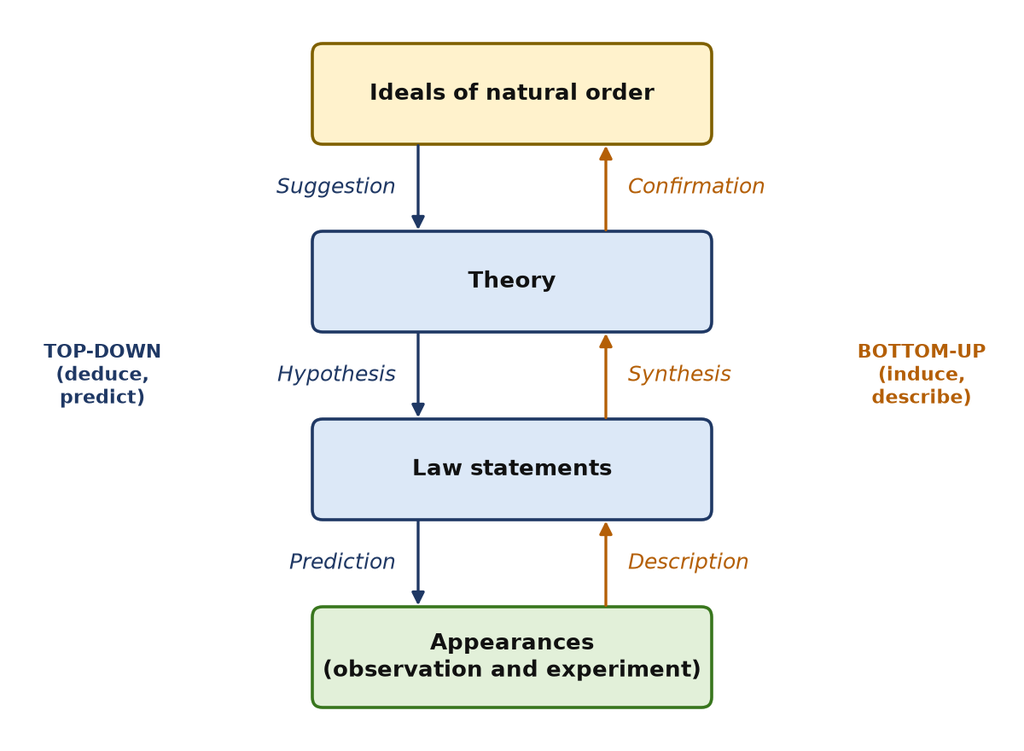

2. **Top-down.** "We begin with the ideals of natural order and seek to formulate our theory so that we can generate hypothetical statements about anticipated regularities. That is, we make predictions" (Discussion 13.1). Using a theory to fit observed regularities in specific cases is what Discussion 11.3 called "tactical modeling".

3. **Bottom-up.** "We begin with observed regularities and seek to generate, inductively, a theory that simultaneously embodies our ideals of natural order and predicts the regularities with which we began." Along the way "we may formulate strategic models that describe specific cases of the observed regularities" (Discussion 13.1).

4. **The form of a prediction.** A theory gives a conceptual taxonomy for describing phenomena plus "rules of reasoning" (logical and mathematical systems) for transforming descriptions. Starting from a hypothetical description, we derive a statement "If A then B": "if conditions A are produced, then event B will occur (at least with a predicted probability that can be tested through statistical analysis over a number of experimental trials)" (Discussion 13.1).

5. **Example.** In Discussion 11.3, the Bohr atom is a strategic model, built to fit experimental results in the hope of discovering a theory (bottom-up), while the Schrodinger equation for the hydrogen atom is a tactical model, general theory applied to a specific case (top-down). "Alert students will immediately recognize the bottom-up/top-down reasoning cycle here" (Discussion 11.3).

6. **Significance.** The two directions make one cycle: going down, we deduce and predict; going up, we induce, describe and confirm. A theory earns its place only when the ladder holds both ways, like the Overview's bridge that must be "firmly anchored at both ends" (Unit 13 Overview).

U13-R06Recall

Explain this topic from the assigned readings: when we have explained a phenomenon, through ideals of natural order and the covering law model. Give an example or explain its significance in this unit.

Source When have we explained a phenomenon? (Discussion 13.1, Part Two)

1. **The course's answer.** "We have explained a phenomenon when we are able to formulate" two things (Discussion 13.1, Part Two).

2. **First, a description.** "A description of a class of phenomena in terms of a theory in such a way that the phenomena of that class are only what would have been expected on the basis of our ideals of natural order."

3. **Second, mechanisms of deviation.** "The theoretical mechanisms that describe deviations from those ideals and show how the phenomenon under consideration fits within these descriptions."

4. **Why this satisfies us.** "When a phenomenon is only what would have been expected, we feel satisfied ... we feel that we understand it." The phenomenon has been fit into a conceptual framework, and "There are no more questions to ask." David Park: understanding means "some contact has been made with principles so simple and so natural that one is ready to accept them, provisionally of course, as representing some version of the way things really are" (Discussion 13.1, Part Two).

5. **A loose covering law model.** The covering law model "asserts that an explanation requires that what is to be explained be deduced from existing conditions and natural law." The course's version is a loose, general version of it, loosened because it "does not require strictly logical deduction, but rather allows the kinds of theoretical plausibility arguments that are often made in science" (Discussion 13.1, Part Two).

6. **Example.** In Newtonian physics, "the states of rest and uniform straight-line motion are the ideals for the natural motion of bodies" (Discussion 4.2). A body moving at constant speed in a straight line needs no explanation; a body that speeds up or curves is explained once a theoretical mechanism, an external force, accounts for the deviation.

7. **Significance.** What counts as explained depends on the ideals of natural order a science assumes, and "whether or not a particular form of explanation is acceptable depends very much on context and the state of the science in which it is offered" (Discussion 13.1, Part Two).

U13-R07Recall

Explain this topic from the assigned readings: four forms of explanation, formal, causal, statistical and functional explanations. Give an example or explain its significance in this unit.

Source Four forms of explanation (Discussion 13.1, Part Two)

1. **Four accepted forms.** Without settling the philosophical debates, Discussion 13.1 describes "four forms of explanation that are generally accepted: formal, causal, statistical and functional", stressing that whether a form is acceptable depends on context and the state of the science.

[output not shown]

2. **Causal explanation in more detail.** Aristotle defined the material, formal, efficient and final causes, and held that "the only way to understand a thing was to know its causes" (Discussion 13.1, Part Two). Modern science does not consider formal and final causes; a minimal final cause appears only in evolutionary theory, as a consequence of evolutionary processes, not a predetermined goal. Historically, mathematical statistics was strongly motivated by the need for accurate insurance tables.

3. **Example.** Study Question 4 asks students to classify explanations such as "HCl is corrosive because it is an acid" (formal: a property of its category), "The litmus paper changed colour because the solution it was dipped into is acidic" (causal: condition plus law) and "The chameleon's ability to change colour evolved as a means of protective camouflage" (functional) (Unit 13 Study Questions).

4. **Significance.** Each form of explanation has its own trap: tautology for formal, the single cause for causal, mistaking probability for certainty for statistical, and circularity for functional. In complex systems especially, "it is important to avoid the trap of thinking in terms of single causes" (Discussion 13.1, Part Two).

U13-R08Recall

Explain this topic from the assigned readings: four principles of causal simplicity, uniformity, stability, composition and common cause. Give an example or explain its significance in this unit.

Source Four principles of causal simplicity (Discussion 13.1, Part Two)

1. **Ideals for causal explanation.** Discussion 13.1 states four principles of causal simplicity "that act as ideals for construction of causal explanations" (Discussion 13.1, Part Two).

2. **Principle of Uniformity.** "It states that similar causes tend to have similar effects, and vice versa. Deviations in effects must be a result of specific causal factors." It is an application of the principle of the identity of indiscernibles. It is challenged by chaos theory and theories of non-linear systems, "where very small deviations in the cause can produce major differences in effects" (Discussion 13.1, Part Two).

3. **Principle of Stability.** "Change does not occur without a cause." It is related to the principle of sufficient reason but narrower (less general), claiming "that the only sufficient reason for change in a system is a causal reason" (Discussion 13.1, Part Two).

4. **Principle of Composition.** Causal explanations "should be in accord with known behaviours of the components of that which is being explained, and not contradict them": a causal theory of species evolution should not violate the known laws of genetics. It is a consequence of the principle of contradiction (Discussion 13.1, Part Two).

5. **Principle of Common Cause.** A constant correlation in time (event A always precedes event B) does not show that A causes B. "The assumption that is justified is that if two events or phenomena show a constant correlation, then they may both be dependent on a common cause": the barometer falls before a storm, but the barometer does not cause the storm; falling atmospheric pressure causes both (Discussion 13.1, Part Two).

6. **Example.** Study Question 5 describes statistically significant correlations among being good at mathematics, being nearsighted, being left-handed, being susceptible to allergies and autoimmune diseases, and being male; investigators propose one common cause, "the effect of testosterone on the developing brain of a fetus" (Unit 13 Study Questions). Discussion 14.1 makes the barometer point as a principle of measurement: "a falling barometric reading ... cannot be the cause of the storm that follows".

7. **Significance.** The four principles keep causal reasoning honest: look for a specific cause behind every change or difference in effect, keep explanations consistent with their components, and do not read cause into correlation. They are ideals, not laws, as chaos theory's challenge to uniformity shows.

U13-R09Recall

Explain this topic from the assigned readings: laws of nature and the forms of law statements, the laws of coexistence, succession and interaction. Give an example or explain its significance in this unit.

Source Laws of nature and the forms of law statements (Discussion 13.1, Table 13.1.1)

1. **Two views of natural laws.** On the general view, natural laws are "a description of empirical regularities observed in nature. As such they are neither true nor false, only more or less accurate statements of what will occur under given sets of circumstances." On the Platonic view, laws "actually exist as relationships between abstract universals, and our current statements of them are partial expressions in terms of our best available conceptual frameworks"; observed regularities are particular instantiations of the abstract laws (Discussion 13.1).

2. **Statements depend on the framework.** Either way, the statement of a law "depends on the conceptual framework used" (Discussion 13.1). The law of gravity has been stated in four ways.

[output not shown]

3. **The law versus its statement.** The theories change; the law (the regularity) does not: "at bottom the law itself is an abstract universal relation that is manifest in the empirical regularities falling under it." "The map is not the territory, but in some cases it can give a pretty good image of the territory" (Discussion 13.1).

4. **Forms of law statements.** Table 13.1.1 classifies law statements as deterministic or stochastic and in three forms: laws of coexistence, succession and interaction. The language of a law depends on the current state of a science; the ideal is a mathematical formulation, and mathematical modeling is the major tool (Discussion 13.1).

| Law form | Deterministic | Stochastic |
| --- | --- | --- |
| **Coexistence** | Selects the possible subsets of representations that are allowed | Specifies a probability distribution on the set of possible representations |
| **Succession** | Specifies the allowed transitions between states, representations or both | Gives the probability of a transition between states, representations or both |
| **Interaction** | Describes the result of the allowed interactions between systems | Gives the probability of specified results of interactions between systems |

5. **Memory hook.** **Coexistence** = what states can exist together (a snapshot); **succession** = what follows what in one system over time (a film); **interaction** = what happens when two systems meet (a collision).

6. **Simple, but not too simple.** "The requirements of the maximum possible precision, conciseness and simplicity are fundamental, both for law statements and for theories." Yet a statement can be too simple: Alfred North Whitehead, "Seek simplicity and distrust it"; Albert Einstein, "Everything should be made as simple as possible, but not simpler." The term **elegant** is reserved for theories that "successfully combine simplicity and comprehensive accuracy" (Discussion 13.1).

7. **Example.** Among Study Question 3's law statements, "Two electrons cannot simultaneously occupy the same quantum state" is a law of coexistence (it selects which states may exist together), and the statement that a sufficiently massive star becomes a supernova when its core burns all its available fuel is a law of succession (a transition between states) (Unit 13 Study Questions).

8. **Significance.** Separating the law from its statement explains how science can keep the same regularity while its theories are replaced, as gravity passed from Aristotle to Newton to Einstein; Feynman calls these rhythms and patterns, "not apparent to the eye, but only to the eye of analysis", Physical Laws (Discussion 13.1).

U13-R10Recall

Explain this topic from the assigned readings: instrumentalism versus realism about theories. Give an example or explain its significance in this unit.

Source Instrumentalism versus realism about theories (Discussion 13.1)

1. **The instrumental view.** "It may seem from what has been said that theories are nothing but mental constructs serving only the instrumental purpose of allowing us to make computations and predictions" (Discussion 13.1). Theories would then be tools for computing and predicting, nothing more; they would differ from guides on reading entrails only in being more accurate, because they are more restricted in the phenomena they describe and more governed by logic and experimental confirmation.

2. **The argument against it.** "What argues against the strict instrumental view of theory is the fact that it is often the case that some entities originally defined only theoretically turn out to have empirical existence" (Discussion 13.1).

3. **Context decides (Suppe).** "The view taken on theories, laws and hypotheses by working scientists depends very much on the context within which they are being considered." Quoting Frederick Suppe, science uses them "as purportedly true descriptions of classes of phenomena, as idealizations, simplifications, or approximations of phenomena"; whether a theory is "taken as providing a realistic treatment or as being a conceptual device" is settled by reasoning based on current scientific knowledge (Discussion 13.1). So a theory gets the status of a realistic description or of a conceptual device depending on context.

4. **Example.** Faced with an apparent breakdown of energy conservation in a subatomic reaction, physicists postulated a new particle that was hard to observe but conserved energy; "Sure enough, several decades later this particle (the neutrino) was experimentally verified to really exist" (Derry, p. 232). A theoretical entity became an empirical one, against a purely instrumental reading. Ernst Mach, by contrast, had denied the existence of atoms because they could not be observed (Derry, p. 191).

5. **Significance.** Working scientists are neither pure instrumentalists nor pure realists: the same theory can be treated as a realistic description in one context and as an idealization, simplification or approximation in another. Discussion 13.1 itself treats theories as conceptual structures that "save" appearances while aiming at the laws behind them.

U13-R11Recall

Explain this topic from the assigned readings: the three metaphysical assumptions of science and the layers above them, theories, models, paradigms and ideals of natural order. Give an example or explain its significance in this unit.

Source Three metaphysical assumptions and the layers above them (Discussion 13.1)

1. **The three metaphysical assumptions.** Discussion 13.1 recalls the fundamental metaphysical assumptions of science: (1) "Nature is ordered." (2) "The order of nature is comprehensible to human reason." (3) "It is possible to communicate our understanding of this order."

2. **What they mean.** Ordered means lawful: "there are universal relations that manifest as regularities in nature." Comprehensible means we can discover these regularities and understand them by reason, crafting law statements within a conceptual framework. Communicable means "We can share conceptual frameworks and the law statements that we make and agree that we are talking about the same things" (Discussion 13.1).

3. **The layers above them.** From the foundation up to what we observe:

[output not shown]

4. **Example.** The assumption that nature is ordered implies that there is a law of gravity, but understanding and communicating it needs a language, so "all statements of this law are relative to particular paradigmatic and theoretical assumptions" (Discussion 13.1); Newton's and Einstein's statements sit at the theory and law-statement layers, while falling bodies are the appearances.

5. **Significance.** The layers answer the unit's question about how theories, models, paradigms and ideals of natural order relate. Theories mediate "between basic metaphysical and paradigmatic assumptions on the one hand; and appearances, taken as manifestations of natural law, on the other" (Discussion 13.1): they are how we save, or rationalize, the appearances.

U13-R12Recall

Explain this topic from the assigned readings: six types of theories. Give an example or explain its significance in this unit.

Source Six types of theories (Discussion 13.1, Part Three; adapted from Rappaport)

1. **Patterns that connect, expressed six ways.** Hanson's summary is that "theories provide patterns within which data become intelligible", and Bateson's that we should seek "the pattern that connects." These patterns are expressed differently "depending on the state of development in particular fields of science and on the available descriptive languages", so the course, adapting A. Rappaport (1958), distinguishes six kinds (Discussion 13.1, Part Three).

[output not shown]

2. **Mixed types.** "Many current scientific theories have features characteristic of more than one of these types": plate tectonics in geology has intuitional, historical and qualitative aspects, and current theories in elementary particle physics have taxonomic, dynamical and stochastic aspects (Discussion 13.1, Part Three).

3. **Example.** The impact theory of dinosaur extinction shows historical theory construction (Discussion 13.1, footnote 288): a world-wide iridium layer in sediment dated to about 65 million years ago held far more iridium than earthly mechanisms deposit but matched meteors; it correlated with the extinction; the geological consequences of an impact were deduced and searched for; and the Chicxulub crater corroborated the theory.

4. **Significance.** The type of a theory sets what kind of prediction it can be asked for: an intuitional theory explains without predicting, a historical one predicts only traces, and only statistical and dynamical theories give mathematical predictions. Judging a theory fairly means judging it by its type, while Margenau's six criteria apply to all of them.

U13-R13Recall

Explain this topic from the assigned readings: Henry Margenau's six criteria for a good theory. Give an example or explain its significance in this unit.

Source Margenau's six criteria for a good theory (Discussion 13.1, Part Three)

1. **Margenau's criteria.** The physicist Henry Margenau (1901-1997) "has suggested six criteria for a good scientific theory, which apply to all types of theory discussed above", that is, to all six types of theory (Discussion 13.1, Part Three).

| Criterion | What it demands |
| --- | --- |
| 1. **Logical fertility** | The theory's constructs (electrons, molecules, biological species, social classes, psychological states) "must provide a basis for fruitful deductions and the construction of hypotheses" |
| 2. **Multiple connection** | Constructs "ought to be multiply connected": to each other and, at least indirectly, to observation |
| 3. **Stability** | "it must be possible to adapt the theory to new data" |
| 4. **Extensibility** | Constructs "should be found to have applications beyond the original confines of the theory itself" |
| 5. **Causal connection** | The theory "ought to provide causal connections between phenomena and the events it is intended to explain" |
| 6. **Simplicity and elegance** | "Theories must strive for simplicity and elegance" |

2. **Memory hook.** F-M-S-E-C-S: 'Fertile Minds Stay Excited, Curious, Simple' (fertility, multiple connection, stability, extensibility, causal connection, simplicity).

3. **Derry's parallel.** Derry asks the same of scientific constructs: they must be connected to other constructs by logical relationships, since "an isolated construct cannot be valid in science"; they must have at least an indirect connection to perceptions; they need "some degree of stability"; they should be extensible, "that is, capable of being generalized"; and scientists prefer simple constructs to ones "unnecessarily cluttered with complications" (Derry, p. 198).

4. **Good theories as a goal.** "Theories that satisfy these criteria are considered good theories", and much of the work in theoretical science is the attempt to develop or refine theories until they meet them (Discussion 13.1, Part Three).

5. **Example.** The Big Bang theory in Discussion 13.2 shows several criteria at work. It was stable: when its predicted age came out younger than the Earth, the correction for two types of Cepheid variables doubled the age, and the elements beyond hydrogen and helium were explained by nucleosynthesis in stars. It was fertile: Gamow deduced that leftover radiation should now be about 5 K, and the uniform background radiation of about 3 K found by Penzias and Wilson was recognized as its signature (Discussion 13.2).

6. **Significance.** The criteria let a scientist judge and choose between theories of any type, not only check whether a theory fits the data. Unit 13 Study Question 7 asks for a comparison of them with the qualities of a good question and the criteria for a valid answer from Discussion 3.2 (Unit 13 Study Questions).

U13-R14Recall

Explain this topic from the assigned readings: the qualities of a good question, the criteria for a valid answer and the conditions for an experiment. Give an example or explain its significance in this unit.

Source Good questions, valid answers, and conditions for an experiment (Discussion 3.2, used in Unit 13)

1. **Science as question and answer.** For a working scientist, "scientific reasoning is a question-and-answer process that involves asking the right questions at the right time and in the right way, and paying attention to the answers." A good question "must grab a scientist's imagination and demand an answer" (Discussion 3.2).

2. **Four qualities of a good question.** Discussion 3.2 lists them:

| Quality | Meaning |
| --- | --- |
| **Depth** | "it goes to the heart of a situation" |
| **Tantalizing** | "it seems to hold out the possibility of an answer" |
| **Suggestive** | "it almost tells one how to look for an answer" |
| **Fruitful** | "the answer, when obtained, will have significant meaning for several areas of science" |

3. **Three criteria for a valid scientific answer.** (1) No answer can imply the violation of an established empirical fact, unless it also explains why the cases where the violation occurs "have as yet not been observed"; such an answer "offers predictions that can be tested." (2) "Every answer must either be consistent with existing theories, or provide a good reason for changing these theories." (3) "No answer can involve a logical contradiction." "It is the criteria for acceptable answers that give us science": answers such as "it is obvious" or "it just feels right" may satisfy elsewhere but are inadmissible in science (Discussion 3.2).

4. **Five questions to ask before an experiment.** Discussion 3.2 gives them with an example each:

| Question | Course example |
| --- | --- |
| Will the procedure **interfere** with the system's natural behaviour? | A bird kept in a small cage; by contrast, a small thermometer barely alters the temperature of a large beaker of liquid |
| Is the system **capable** of the expected behaviour? | A spelling test for infants who have not yet learned to talk would be useless |
| Can the **equipment detect** the expected result? | Stellar parallax, predicted by the Copernican theory, needed instruments that took "well over 100 years" to develop |
| Is the **initial state properly prepared**? | Rats trained to perform a task for food must be hungry when tested |
| Will the procedure **destroy or disable** the system, and does that invalidate the experiment? | An electrode so large that it kills the nerve cell is useless; yet physicists study atomic nuclei by bombarding them with high energy particles and analysing the fragments |

5. **Example.** Einstein's general relativity raised a question with all four qualities: it went to the heart of gravitation, promised an answer, suggested where to look (starlight passing the sun) and was fruitful for several fields. The 1919 eclipse expedition that measured the bending of starlight then had to meet the experimental conditions, above all equipment able to detect a tiny shift (Discussion 3.2).

6. **Significance.** Unit 13 Study Question 7 brings these lists into the unit: a scientific theory "can be seen both as providing an answer to a general question and as a framework within which answers can be given to more specific questions", so the qualities of a good question and the criteria for a valid answer are to be compared with the six criteria for a good theory in Discussion 13.1 (Unit 13 Study Questions). A fruitful question matches a logically fertile theory, and consistency with existing theory matches a stable theory that adapts to new data.

U13-R15Recall

Explain this topic from the assigned readings: confirmation and refutation of theories, with falsifiability and the Quine-Duhem thesis. Give an example or explain its significance in this unit.

Source Confirmation and refutation (Derry ch. 14, pp. 199-201; Discussion 3.2)

1. **Induction fails as proof.** Any logical proof of induction must itself be inductive: arguing that "induction has always worked, therefore it is valid" is circular, since it "assumes the truth of the premise it sets out to prove." In practice induced conclusions also fail: after Lavoisier, the unchangeability of elements was confirmed "innumerable times", until radioactivity was discovered around 1900 and Rutherford showed that radioactive decay changes one element into another (Derry, pp. 199-200).

2. **Falsificationism.** A proposed theory must "make statements that can be falsified by comparison with observation", that is, statements observation could show false. Disagreement refutes the theory; agreement confirms it provisionally but does not prove it, and theories are accepted "on a provisional basis, as long as they continue to be confirmed." "We can never prove a theory is right, only that it's wrong" (Derry, p. 200). As a formal doctrine it is associated with Karl Popper, who called the process "conjectures and refutations": a conjecture is made and the scientific community tries to refute it, sharpening it (Discussion 3.2).

3. **Falsifiability weeds out empty claims.** An Aristotelian opponent of Galileo, shown mountains and craters on the moon, claimed an invisible substance filled the craters so the moon stayed a perfect sphere; because it "could not in principle be observed", the claim could not be falsified and is of little use in science (Derry, p. 200).

4. **Asymmetry.** No number of confirmations proves a theory, while one solid refutation can show it false and sink it (Derry, p. 200).

5. **Example.** Stellar parallax: the Copernican theory predicted that stars should shift as the Earth moves, but the effect was not seen until about 1840, roughly 300 years after Copernicus. Strictly the theory was falsified, yet it was rightly kept, because the stars are much farther away than anyone suspected: falsification is not enforced rigidly in practice (Derry, p. 200). A good theory with many confirmations is not dropped over a few minor discrepancies; it "will not and should not be given up even if a few minor discrepancies remain" (Derry, p. 201).

6. **What drives progress.** Bold confirmations (starlight bending, predicted by Einstein's general relativity in 1915 and observed during a solar eclipse in 1919) and refutations of well-accepted ideas (the radioactive transmutation of elements) both drive science. Falsificationism is a useful framework, but "it doesn't provide us with a universal principle for determining validity in science" (Derry, p. 201).

7. **Quine-Duhem thesis.** A theory is "a complex interlocking set of concepts, observations, definitions, presuppositions, experimental results, and connections to other theories", so no single fact is crucial. If carbon fails to turn into diamond at the predicted pressure and temperature, perhaps the instruments that measure them, which rest on their own theories, are wrong. Duhem argued in 1906 that experiments "only test the total structure of a science, not individual hypotheses"; Quine extended this to the thesis that, logically, the whole structure is tested and "any observation can be accommodated by making suitable adjustments" (Derry, p. 201).

8. **Significance.** Unit 13 treats theories as provisional but not disposable: when a theory fits within the limits of observation, scientists extend it rather than keep replacing it, and the course sets this against "the Popperian idea that we should constantly be developing new theories and attempting to refute them" (Discussion 13.1). Confirmation and refutation explain how theories such as the Big Bang survive anomalies while rivals such as the Steady State are eventually abandoned.

U13-R16Recall

Explain this topic from the assigned readings: the controlled experiment, its control group and the method of comparison. Give an example or explain its significance in this unit.

Source Controlled experiments and the method of comparison (Discussion 11.2; Discussion 14.1; Derry ch. 7)

1. **Method of comparison.** It involves "making comparisons of similarities and differences between entities thought to be related in some way": equipment or experimental methods, hypotheses, sets of data, or theories. The conditions are always the same: "There must be a goal, some reason for making comparisons"; tools appropriate to the goal; and dimensions of comparison "both relevant to our goals and accessible with the available tools." If the tools are lacking, we change the goals, find new dimensions or invent new tools. Its primary uses are "classification, historical reconstruction, a search for generalizations, and hypothesis testing" (Discussion 11.2).

2. **Controlled experiment.** A planned comparison: by the traditional principles of measurement, "systems are to be controlled experimentally so that only one independent variable is changed at a time" (Discussion 14.1). An **experimental group** receives the change; a **control group** is identical except for that one variable. In the biological, social and psychological sciences "it is often impossible to isolate only a single independent variable" (Discussion 14.1).

3. **Control group or baseline.** The control is the reference against which a deviation is measured. In brain-lesioning studies, rats are first tested "to establish a measure of their normal behaviour and capacities"; comparing pre-operative and post-operative performance then shows the function of each brain area (Discussion 11.2). Without such a baseline we cannot tell whether an effect was caused by the treatment or would have happened anyway.

4. **Example.** In the studies of power lines and health, early correlations between childhood leukemia and nearness to transformers were suggestive but not conclusive. A major problem was that very few good measures of the dose were possible, "especially compared to a control group reflecting the general population": no one knew the field strengths or exposure times for either the studied groups or the controls (Derry, p. 142).

5. **Showing causality.** To demonstrate a causal link, the cause must be "both a necessary and a sufficient condition for the effect", and "in science, this can sometimes be accomplished by a detailed series of carefully controlled experiments" (Derry, p. 97).

6. **Significance.** Comparison is how rival hypotheses and theories are tested in this unit: the Big Bang and Steady State theories were tested by comparing the ages of distant and nearby galaxies, a test that stayed inconclusive while the data were not refined enough (Discussion 13.2). A controlled experiment is the most exact form of the method, since it changes one variable and holds the rest fixed.

U13-R17Recall

Explain this topic from the assigned readings: the Big Bang and Steady State theories in the history of modern cosmology. Give an example or explain its significance in this unit.

Source Big Bang versus Steady State (Discussion 13.2)

1. **Two rival theories.** The Big Bang theory has the universe begin from a state of almost infinite density and temperature (Lemaître's "cosmic egg") and expand ever since. In the Steady State theory of Hoyle, Bondi and Gold, "the universe has existed eternally and always looked much as it does now"; because it expands, the theory "requires that a certain amount of new matter be continuously created" (Discussion 13.2).

2. **Timeline.** Discussion 13.2 tells the history in this order:

| Date | Event | Significance |
| --- | --- | --- |
| 1916 | Einstein's general theory of relativity | The foundation for theoretical cosmology |
| 1922 | Friedmann's expanding-universe solution of the Einstein equations | Treated as "a mathematical exercise" |
| 1927 | Lemaître's expanding-universe solutions | Scant attention until compared with Hubble's discovery in 1930 |
| 1929 | Hubble (100-inch telescope, Mount Wilson; Cepheid distances) shows spiral nebulae are galaxies and that they are receding | The universe is **expanding**; running the expansion backward gives an age |
| 1931 | Lemaître's "cosmic egg": the universe as "the ashes and smoke of bright but very rapid fireworks" | The "fireworks theory", first version of the Big Bang |
| Late 1940s | Gamow, Alpher and Herman: elements "cooked up" in the initial explosion from "Ylem" (protons, neutrons and electrons in high energy radiation) | Right for hydrogen and helium (Gamow: 99% of the matter in the universe), radically wrong for other elements |
| Late 1940s | Hoyle, Bondi and Gold: **Steady State** (eternal universe, continuous creation of matter); Hoyle sarcastically renames the fireworks theory the "Big Bang Theory" | Rival theory; it seemed to fix the Big Bang's problem of a universe younger than the Earth |
| 1950s | Heavier elements made by **nucleosynthesis in stars**, supported by Hoyle's measurements | Resolves the element problem |
| 1950s | Cepheid variables found to be **two types**; the correction doubles the age of the universe | Age problem dispelled |
| 1948 / 1954 | A 1948 survey suggests distant galaxies are older; a 1954 review shows "an artifact of measurement" | Test inconclusive |
| 1951-1955 | Ryle's radio survey of 2000 extra-galactic sources (begun 1951, published 1955): more distant ones older | Evidence against Steady State, questioned by its supporters |
| 1948 | Gamow predicts leftover radiation now at about 5 K | Prediction |
| 1963-1965 | Penzias and Wilson (Bell Laboratories) find uniform background microwave radiation at about 3 K (1963); Dicke and Peebles (Princeton) identify it as the big bang's signature (1965) | The "deathblow" for Steady State |
| Mid-1970s | Steady State "effectively abandoned", after "five more years of study were needed to bury it" | A few cosmologists still try to adjust it |

3. **Science and religion.** In 1952 Pope Pius XII proclaimed that big bang cosmology affirmed a Creator God; Hermann Bondi replied that the big bang rested on a singularity in certain solutions of Einstein's equations, and that tying it to creation "raised the possibility of eliminating God with better mathematics" (Discussion 13.2).

4. **Example.** The background radiation was a bold, independent prediction: Gamow's 1948 estimate of about 5 K and the 3 K actually observed agree to within a factor of two, and the Steady State theory had no such radiation to offer, so the observation settled a contest that the galaxy-age surveys had left open (Discussion 13.2).

5. **Significance.** Unit 13 Study Question 9 asks for "the different factors contributing to the modern theory and the underlying theoretical assumptions" (Unit 13 Study Questions). The history shows theory (Einstein, Friedmann, Lemaître) ignored until observation (Hubble) gave it meaning, anomalies (the age problem, the heavier elements) resolved by new data rather than by abandoning the theory, tests that stayed inconclusive while the data were not refined enough, and a decision reached only by an independent prediction.

### Key term questions19

U13-T01Term

Define or distinguish Theory. Give an example and explain its role in this unit.

1. **Definition.** A scientific theory is "an abstract conceptual system that is constructed to explain some aspect of nature" (Unit 13 Overview): a pattern of thought, not a mere collection of facts, made of relationships among abstract categories together with rules for drawing conclusions.

2. **Example.** Newton's theory of gravity, which explains falling bodies, tides and planetary orbits with one law of attraction and three laws of motion.

3. **Role in this unit.** Theories are the "conceptual bridges" between ideals of natural order and experience. They let us describe, predict and explain, and the unit classifies them into six types and judges them by six criteria.

4. **Distinction.** A theory is not a law statement (which states a regularity), a model (which applies a theory to a specific case) or an opinion (which need not be testable). As Poincaré said, a heap of facts is no more a science than a heap of stones is a house.

5. **Significance.** Theories must be internally coherent and testable in principle. Because learning a theory changes how we perceive, theories both illuminate and filter what we see.

U13-T02Term

Define or distinguish Theoria. Give an example and explain its role in this unit.

1. **Definition.** *Theoria* is the Greek word from which "theory" comes. It meant "vision": a theory gave a person a vision of the world (Unit 13 Overview).

2. **Example.** Plato's account in the *Republic*, where studying mathematics lifts the mind from the changing world of experience to a vision of Justice, Truth and Beauty.

3. **Role in this unit.** It names the Aristotelian view of theory as an aid to contemplating nature and to spiritual growth, which the unit contrasts with Bacon's view.

4. **Distinction.** In the Baconian view, theory is for use: control of nature and reduction of suffering. *Theoria* is for understanding and inner development.

5. **Significance.** The Overview suggests the idea may regain importance, both through cognitive science's interest in understanding and because scientific power has outgrown moral development.

U13-T03Term

Define or distinguish Ideal of natural order. Give an example and explain its role in this unit.

1. **Definition.** An ideal of natural order is an assumption about how nature behaves when nothing interferes. It is accepted without question within a paradigm, so only deviations from it need to be explained (Discussions 3.2 and 13.1).

2. **Example.** The ancient Greek assumption that planets move in perfect circles; in modern physics, the assumption that a body moves in a straight line at constant speed unless a force acts on it.

3. **Role in this unit.** Theories mediate between the ideals of natural order and the observed regularities. A phenomenon is explained when it is shown to be only what the ideals lead us to expect, plus mechanisms for any deviations. The ideals sit at the top of the course's theory ladder.

4. **Distinction.** An ideal is not a theory or a law statement: it is assumed, not tested directly. A theory built on it is tested.

5. **Significance.** Ideals set what counts as needing explanation. Changing an ideal, as Kepler did when he gave up circular orbits, can transform a science.

U13-T04Term

Define or distinguish Law statement. Give an example and explain its role in this unit.

1. **Definition.** A law statement is a statement, made within a theoretical framework, of an empirical regularity in nature. It gives an analytical presentation of the regularity, rationalized within the framework's assumptions (Discussion 13.1).

2. **Example.** Newton's law of gravity: any two masses attract each other with a force proportional to the product of their masses and inversely proportional to the square of the distance between them.

3. **Role in this unit.** Law statements link theories to appearances on the course's theory ladder. They are classified as laws of coexistence, succession or interaction, each deterministic or stochastic (Table 13.1.1).

4. **Distinction.** The law itself, the regularity in nature, does not change; our statements of it do. "What goes up must come down," Aristotle's natural places, Newton's inverse square and Einstein's general relativity all describe the same regularity.

5. **Significance.** Because every law statement depends on a framework, a better theory can restate a law without the regularity changing. Law statements should be as precise, concise and simple as possible, though "not simpler."

U13-T05Term

Define or distinguish Covering law model. Give an example and explain its role in this unit.

1. **Definition.** The covering law model says that a phenomenon is explained when it is deduced from existing conditions together with natural laws that "cover" it (Discussion 13.1).

2. **Example.** A stone falls when released: given its initial conditions (held above the ground, then let go) and the law of gravity, the fall follows.

3. **Role in this unit.** The course's account of explanation is a looser version of this model. It allows the plausibility arguments scientists actually use (if certain conditions hold, the result follows from natural laws, theoretical principles and ideals of natural order) instead of demanding strict logical deduction.

4. **Distinction.** It is a model of what explanation *is*, while formal, causal, statistical and functional explanations are *forms* an explanation can take. Causal explanation is the form closest to it.

5. **Significance.** It answers one of the main questions in the philosophy of science, what counts as an adequate explanation, and it explains why we feel satisfied once a phenomenon is "only what would have been expected."

U13-T06Term

Define or distinguish "Saving the appearances". Give an example and explain its role in this unit.

1. **Definition.** "Saving the appearances" is an ancient Greek phrase for what a theory does: it provides a theoretical system within which appearances, meaning what we observe, are rationalized and reproduced (Discussion 13.1).

2. **Example.** Aristotle's theory that objects seek their natural places saved the appearances of falling stones, rising flames and flowing rivers. Ptolemy's epicycles saved the appearances of planetary motion.

3. **Role in this unit.** It describes how theories mediate between our ideals of natural order and appearances, giving "law statements" that fit the observed order.

4. **Distinction.** Saving the appearances is not the same as being true. Aristotle's theory saved the appearances but is no longer accepted; when it failed, it was the theory that was faulty, not the phenomena.

5. **Significance.** The phrase reminds us that theories are judged first by their fit to observation, and that several theories may fit the same appearances, which is why the other criteria for a good theory are needed.

Note*Outside the readings: the association of the phrase with Ptolemaic astronomy is standard history of science.*

U13-T07Term

Define or distinguish Instrumentalism. Give an example and explain its role in this unit.

1. **Definition.** Instrumentalism is the view that theories are only mental tools for calculating and predicting, not descriptions of what really exists (Discussion 13.1).

2. **Example.** On this view, Ptolemy's epicycles were a good instrument as long as they predicted planetary positions, whether or not planets really move on circles upon circles.

3. **Role in this unit.** The course presents it, compares it to "guides on reading entrails" that are merely more accurate, and then argues against the strict form of it.

4. **Distinction.** Realism holds that a good theory describes real entities. Against strict instrumentalism, entities first defined only in theory often turn out to exist empirically, and scientists give a theory realistic or instrumental status depending on context (Suppe, in Discussion 13.1).

5. **Significance.** It explains why an inaccurate but useful theory (Newton's gravity for spaceflight) is still used, and why prediction alone does not settle what a theory says about the world.

Note*Outside the readings: the atom, the neutrino and the Higgs boson are standard cases of entities first defined in theory and later detected.*

U13-T08Term

Define or distinguish Elegant theory. Give an example and explain its role in this unit.

1. **Definition.** In science, "elegant" is reserved for theories that successfully combine simplicity with comprehensive accuracy: they explain as much as possible as simply as possible (Discussion 13.1).

2. **Example.** Newton's single law of gravitation, which covers the falling apple, the tides and the orbits of the planets; Feynman's remark that with a right guess "more comes out than goes in."

3. **Role in this unit.** Simplicity and elegance is the sixth of Margenau's criteria for a good theory, and the unit treats conceptual parsimony, seeking "to explain more with less," as an instinct a scientist must develop.

4. **Distinction.** Elegance is not mere simplicity. Whitehead warned, "Seek simplicity and distrust it," and Einstein said everything should be as simple as possible, "but not simpler." A simple theory that is inaccurate is not elegant.

5. **Significance.** Elegance guides theory choice when evidence is incomplete, as Dirac's preference for beauty in equations shows, but it cannot replace empirical testing.

U13-T09Term

Define or distinguish Deterministic / stochastic law. Give an example and explain its role in this unit.

1. **Definition.** A deterministic law gives a definite result: the allowed states, transitions or outcomes. A stochastic law gives probabilities: a probability distribution over states, the probability of a transition, or the probability of each result of an interaction (Table 13.1.1).

2. **Example.** Deterministic: Newton's laws fix a planet's next position from its present state. Stochastic: a radioactive nucleus has a fixed probability of decaying in each second, but when one nucleus will decay cannot be predicted.

3. **Role in this unit.** The distinction forms the columns of Table 13.1.1, crossed with laws of coexistence, succession and interaction, and it separates dynamical theories from statistical ones.

4. **Distinction.** A stochastic law is not a vague one. It makes exact predictions about frequencies over many cases, tested statistically; it does not predict individual events.

5. **Significance.** Many modern sciences, from population genetics to quantum physics, are stochastic, so a scientist must know which kind of law a prediction comes from in order to test it properly.

U13-T10Term

Define or distinguish Tactical / strategic model. Give an example and explain its role in this unit.

1. **Definition.** A tactical model is deduced from an existing theory to apply it to a specific case (top-down). A strategic model is built to fit observations, without a developed theory, in the hope that a theory can be found from it (bottom-up) (Discussion 11.3).

2. **Example.** The Bohr model of the atom was strategic: built (1913) to fit the hydrogen spectrum before quantum mechanics existed. The Schrödinger equation for the hydrogen atom is tactical: quantum theory applied to one atom.

3. **Role in this unit.** They appear on the two sides of the course's theory ladder (Figure 13.1.3): tactical modeling on the way down from theory to predictions, strategic models on the way up from observed regularities to theory.

4. **Distinction.** The difference is direction and purpose, not content: tactical models apply a known theory, strategic models search for an unknown one. Simulation models can be used either way.

5. **Significance.** Together they make the bottom-up and top-down cycle by which theories are built and tested.

U13-T11Term

Define or distinguish Falsifiability. Give an example and explain its role in this unit.

1. **Definition.** Falsifiability is the requirement that a scientific theory make statements that could be shown false by comparison with observation (Derry p. 200, after Karl Popper).

2. **Example.** General relativity predicted a definite bending of starlight by the Sun; the 1919 eclipse observations could have contradicted it. The claim of an invisible substance that fills the Moon's craters could not be falsified, even in principle.

3. **Role in this unit.** It underlies the unit's demand that theories be "empirically testable, at least in principle," and the relationship between confirmation and refutation (Objectives 2 and 3).

4. **Distinction.** Falsifiable does not mean false; it means testable. A confirmed prediction does not prove a theory true, while a genuine contradiction shows that something is wrong.

5. **Significance.** It weeds out statements with no observable consequences, but it is "rarely enforced in practice": the Copernican theory was kept although stellar parallax went unseen for about 300 years (Derry p. 200).

U13-T12Term

Define or distinguish Quine-Duhem thesis. Give an example and explain its role in this unit.

1. **Definition.** The Quine-Duhem thesis says that it is impossible, on purely logical grounds, to falsify a theory experimentally, because any observation can be accommodated by making suitable adjustments elsewhere. Experiments test the whole structure of a science, not single hypotheses (Derry p. 201).

2. **Example.** Derry's case: a theory predicts that carbon turns into diamond at a certain pressure and temperature. When it does not, the fault may lie in the instruments that measure extreme pressures and temperatures, which rely on theories of their own.

3. **Role in this unit.** It qualifies the relationship between confirmation and refutation and explains why a single failed experiment rarely overturns a good theory. In cosmology, the mistaken Cepheid distance scale first counted against the Big Bang theory, then for it once corrected.

4. **Distinction.** It does not say that all theories are equally good. The adjustments that would save a theory, though logically possible, may be unacceptable on other grounds (Derry pp. 201-202).

5. **Significance.** It shows that testing a theory always involves judgment about which assumption to blame, which leads to Kuhn's account of paradigms.

U13-T13Term

Define or distinguish Theory-laden facts. Give an example and explain its role in this unit.

1. **Definition.** Facts are theory-laden when the concepts used to state and interpret them come from a theory, so observations are not wholly independent of the theories they are used to test. The term was coined by N. R. Hanson (Derry p. 199).

2. **Example.** "The sun rises in the east" uses the concepts "sun" and "east," which meant something very different to the ancient Druids than to us (Derry p. 199). Galileo and his opponents saw the same Moon but saw different things in it.

3. **Role in this unit.** It explains why theories act as filters on perception and why learning a theory changes what we observe (Discussion 13.1). Hanson's own line, "theories provide patterns within which data become intelligible," opens Part Three.

4. **Distinction.** Theory-laden does not mean made up. The data still come from observation, and observation can still contradict the theory; it means that facts carry interpretation.

5. **Significance.** It undermines the positivist idea that theories are proved by pure observation, and it is the reason scientists occasionally need to take their spectacles off (Study Question 2).

Note*Course spelling: Derry p. 199 spells the name "Hansen"; it is Norwood Russell Hanson, as Discussion 13.1's footnotes spell it.*

U13-T14Term

Define or distinguish Controlled experiment. Give an example and explain its role in this unit.

1. **Definition.** A controlled experiment changes only one independent variable at a time while everything else is held constant, and compares the result with a control (Discussion 14.1).

2. **Example.** Two sets of identical bean plants get the same soil, water and light, but one set is given a fertilizer. A difference in growth can then be traced to the fertilizer.

3. **Role in this unit.** It is the method of comparison (Discussion 11.2) used for hypothesis testing, and the main way an experiment can provide a clean test of a theory (Objectives 4 and 5).

4. **Distinction.** It differs from an observational or epidemiological study, where nature supplies the groups and other factors cannot be held fixed, as in the power-line studies (Derry p. 142).

5. **Significance.** A detailed series of controlled experiments can show that a cause is both necessary and sufficient for its effect (Derry p. 97). The method is limited in complex biological and social systems, where variables cannot be separated (Discussion 14.1).

U13-T15Term

Define or distinguish Control group / baseline. Give an example and explain its role in this unit.

1. **Definition.** A control group is a group treated like the experimental group in every way except the variable being tested; a baseline is a measurement of normal behaviour taken before the change. Both supply the expected result against which an effect is judged.

2. **Example.** Rats are tested before brain lesioning to establish "a measure of their normal behaviour and capacities" (Discussion 11.2). In a drug trial, a group given a placebo is the control.

3. **Role in this unit.** Objective 5 asks why one is needed: without it, a result cannot be credited to the variable changed rather than to chance, time or expectation.

4. **Distinction.** The control group runs alongside the experiment at the same time; a baseline comes before it, from the same subjects. Either one provides the comparison.

5. **Significance.** It is the experimental form of the course's view of explanation, in which only deviations from an expected order need explaining. Its absence weakened the power-line studies (Derry p. 142).

Note*Outside the readings: the placebo control in drug trials.*

U13-T16Term

Define or distinguish Cepheid variable. Give an example and explain its role in this unit.

1. **Definition.** A Cepheid variable is a star that brightens and dims regularly. The period of its variation is related to its intrinsic brightness, so measuring the period gives its true brightness, and comparing that with its observed brightness gives its distance (Discussion 13.2, footnote 290).

2. **Example.** Hubble used Cepheids in the Andromeda "nebula" to show that it lies far outside our galaxy: it is another galaxy.

3. **Role in this unit.** Cepheids were the distance measure behind Hubble's discovery that the galaxies are receding, and so behind the estimate of the age of the universe.

4. **Distinction.** There are two distinct types of Cepheid, each with its own period-brightness relation. Confusing them made distances too small and the universe seem younger than the Earth; correcting the error doubled the estimated age.

5. **Significance.** They show how a whole cosmological theory can depend on an auxiliary assumption about a measuring tool, and how correcting that assumption can change the verdict on a theory.

Note*Outside the readings: Henrietta Leavitt discovered the period-brightness relation (1912), and Walter Baade identified the two types (1952).*

U13-T17Term

Define or distinguish Ylem. Give an example and explain its role in this unit.

1. **Definition.** Ylem was the name George Gamow, Ralph Alpher and Robert Herman gave to the primordial mix from which they supposed the universe cooled: protons, neutrons and electrons immersed in a sea of high-energy radiation, at almost infinite density and temperature. The word is an old philosophical term for "primordial substance" (Discussion 13.2).

2. **Example.** Their calculations of how the elements were "cooked up" from the Ylem gave reasonably good estimates of the amounts of hydrogen and helium in the universe.

3. **Role in this unit.** It was the starting assumption for the first attempt to predict the abundances of the elements, a major step in developing the Big Bang theory.

4. **Distinction.** The Ylem model succeeded for hydrogen and helium but was badly wrong for the heavier elements, which come from nucleosynthesis in stars.

5. **Significance.** Gamow joked that the theory must be good since it got 99% of the matter right; the hot early state it assumed also led to the prediction of leftover radiation.

U13-T18Term

Define or distinguish Nucleosynthesis. Give an example and explain its role in this unit.

1. **Definition.** Nucleosynthesis is the building of heavier atomic nuclei from lighter ones by nuclear reactions. In Discussion 13.2 it is the process in the cores of stars that produced most of the elements heavier than hydrogen and helium.

2. **Example.** In stars, hydrogen fuses into helium, and later helium into carbon and oxygen; the heaviest elements form in the explosions of massive stars.

3. **Role in this unit.** It solved the problem the Ylem calculations could not: where the elements other than hydrogen and helium came from. Fred Hoyle's measurements gave it empirical support.

4. **Distinction.** Stellar nucleosynthesis is distinct from the nucleosynthesis in the first minutes of the universe, which Gamow's group calculated and which produced mostly hydrogen and helium.

5. **Significance.** It shows that a theory can be completed by work from a rival camp: Hoyle, the leading Steady State supporter, helped answer one of the Big Bang theory's main weaknesses.

Note*Outside the readings: the fusion steps in stars and the formation of the heaviest elements in supernova explosions (and in mergers of neutron stars).*

U13-T19Term

Define or distinguish Cosmic microwave background. Give an example and explain its role in this unit.

1. **Definition.** The cosmic microwave background is faint microwave radiation, nearly uniform across the whole sky, at a temperature of about 3 K, left over from the hot, dense early universe (Discussion 13.2).

2. **Example.** Arno Penzias and Robert Wilson of Bell Laboratories found it as a background they could not remove; Robert Dicke and James Peebles recognized it in 1965 as the "archaic signature" of the Big Bang.

3. **Role in this unit.** It was the "deathblow" for the Steady State theory and decided the contest between the two cosmologies.

4. **Distinction.** It was a prediction of the Big Bang theory (about 5 K was estimated in 1948) that the Steady State theory had no natural way to explain, which is what made it decisive, unlike the expansion that both theories accepted.

5. **Significance.** It is a case of a bold prediction confirmed years later by a discovery made for other reasons, and of a theory, the Big Bang, telling scientists what an observation means.

Note*Outside the readings: the modern measured temperature is 2.725 K. Penzias and Wilson received the 1978 Nobel Prize in Physics for the discovery.*

### Applied written questions16

U13-A01Applied5 marks

Compare the contemplative and practical purposes of scientific theory in the course's Aristotelian and Baconian accounts. Explain how one theory might serve both purposes.

Source Unit 13 Overview

1. **The contemplative purpose (Aristotelian).** Theory is an aid to contemplating nature, through which a person grows spiritually. *Theoria* meant "vision": a theory gives a vision of the world, and for Plato the study of science and mathematics lifts the mind towards Justice, Truth and Beauty and gives the wisdom to govern oneself and the state (Unit 13 Overview).

2. **The practical purpose (Baconian).** Bacon attacked "empty" speculation and held that the role of knowledge is to reduce human suffering. A theory is valued for the control over nature and the practical applications it makes possible, the view that dominates modern society.

3. **How they differ.** The contemplative purpose looks inward, at understanding and the character of the knower; the practical purpose looks outward, at results for society. The first is judged by insight and wisdom, the second by usefulness.

4. **One theory serving both: the theory of evolution.** It gives a vision of the unity of life: every living thing is related, and humans belong to the same history as other species, which changes how a person sees their place in nature. The same theory is used practically: it explains why bacteria become resistant to antibiotics, and so guides doctors to use antibiotics carefully and to combine them.

5. **Why the two purposes support each other.** The practical uses depend on real understanding: someone who has only memorized rules cannot apply evolution to a new disease, while someone who has internalized it (Plato's "fifth") can. And the Overview's point that power over nature has outstripped moral development suggests that the contemplative purpose is needed to guide the practical one.

Note*Outside the readings: antibiotic resistance as natural selection in bacteria.*

U13-A02Applied5 marks

Distinguish description, prediction, explanation and understanding using a weather example. Explain why accurate prediction need not supply a satisfying mechanism.

Source Discussion 13.1 Part Two

1. **Description.** A weather station reports a temperature of 8 °C, falling air pressure, rising humidity and wind from the southeast. A forecaster describes this in the theory's categories: a low-pressure system with a warm front approaching. Description fits observations into a conceptual taxonomy.

2. **Prediction.** From the description and the regularities of meteorology, the forecaster predicts rain within twelve hours, often as a probability ("a 70% chance of rain"). A prediction has the form "If A then B," and a probability can be tested over many forecasts.

3. **Explanation.** The rain is explained when we show why it is what should be expected: air in the low rises, cools and can no longer hold its water vapour, which condenses into clouds and falls as rain. The mechanism accounts for the deviation from fair weather, the ideal state for that place and season.

4. **Understanding.** A forecaster who understands the theory has internalized it as an organizer of perception (Plato's "fifth"). Faced with an unusual pattern, they can reason about it from the principles instead of matching it to a memorized rule.

5. **Prediction without a mechanism.** A falling barometer predicts storms reliably, yet the barometer does not cause them: falling pressure causes both (Discussion 13.1). A correlation, a statistical rule or a simulation can predict accurately without saying why. Ptolemy's epicycles predicted planetary positions well for centuries with a false picture of the heavens. Accurate prediction shows that a theory fits the appearances; it does not show that its mechanism is right, which is why prediction and explanation are separate goals.

Note*The station readings and the 70% forecast are invented for illustration.*

U13-A03Applied5 marks

Explain the incremental and all-or-none pictures of learning, and relate them to Plato's five stages. Give an example of applying a learned framework to a new case.

Source Discussion 13.1 Part One

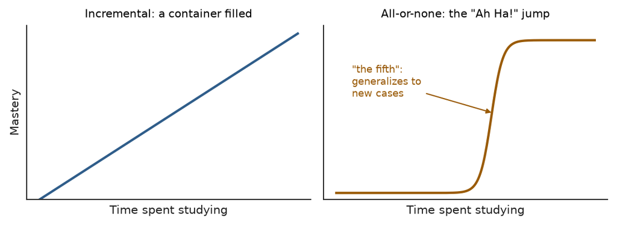

1. **Incremental learning.** Mastery grows steadily with study time, like a container being gradually filled (Figure 13.1.1). The learner can repeat what has been put in, but, as Discussion 13.1 says, all that can be done with a filled container is to pour out some of what it already holds.

2. **All-or-none learning.** Almost nothing seems to be learned until a sudden jump, the "Ah Ha!" experience, after which mastery is nearly complete (Figure 13.1.2). Learning to ride a bicycle often follows this pattern. A mental construct cannot work as an information processor until all its pieces are in place, and once it does, the learner can generalize to analogous cases.

3. **Plato's five stages.** In the *Seventh Letter*: the name, the definition, the image (examples), true opinion (the theory's details and how to apply them), and "the fifth," which comes as a "flash of lightning." The first four can be built up step by step, like the incremental curve; "the fifth" is the jump of the all-or-none curve, the point where the theory works automatically.

4. **The difference it makes.** A proficient person at the stage of true opinion knows the rules and how to apply them. An expert who has reached "the fifth" knows all of this intuitively and also knows when to break the rules. Because science seeks generality, the second kind of learning is the one that matters most.

5. **Applying a framework to a new case.** A student who has internalized natural selection (variation, inheritance, selection by the environment) can recognize it far from the examples in the textbook: insects becoming resistant to a pesticide that kills most of them, or bacteria becoming resistant to an antibiotic. The same pattern appears in each, and the student sees it without being told, which is what "the fifth" makes possible.

U13-A04Applied5 marks

Trace sensations, apprehensions, perceptions and empirical thought in the interpretation of an unfamiliar scientific image. Explain where conceptual organization enters.

Source Discussion 13.1 Part Two

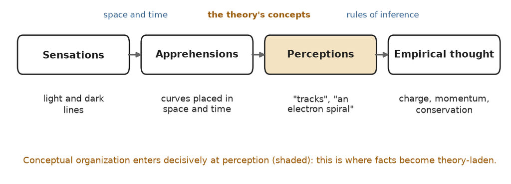

Example: a person sees, for the first time, a bubble-chamber photograph from a particle physics experiment.

1. **Sensations.** At first there is only a pattern of light and dark: thin curved lines and spirals on a grey background, William James's "booming buzzing confusion." Nothing yet is a track or a particle.

2. **Apprehensions.** The sensations are located in space and time: this curve starts at the left edge, that spiral winds in the lower right, and the lines are all present in one picture taken at one moment. In Kant's model, the categories of space and time mediate this step.

3. **Perceptions.** The apprehensions are brought under concepts: "this line is a track," "this spiral is an electron losing energy," "these lines all start at one point, so a collision happened there." This is where conceptual organization enters. A novice cannot take this step; a physicist does it at a glance, because the theory has become an organizer of perception.

4. **Empirical thought.** Reasoning then works on the perceptions: tracks that curve opposite ways in the magnetic field carry opposite charges; a tighter curve means less momentum; and whatever the products, energy, momentum and quantum numbers must have been conserved (Study Question 5e). The image becomes evidence for or against a theory.

5. **Where theory enters, and the risk.** Conceptual organization enters at each step above sensation, but decisively at perception, where categories from the theory decide what the lines *are*. The facts are theory-laden: someone with a different theory might "carve" the same image into different objects. The same organization that makes the image intelligible can also hide an unexpected track that does not fit the expected categories.

Note*Outside the readings: in a bubble chamber, charged particles leave trails of bubbles, and a magnetic field bends their paths according to their charge and momentum.*

U13-A05Applied10 marks

Draw the course theory ladder from ideals of natural order to theories, hypotheses and observations. Show both directions of reasoning and identify places for strategic and tactical models.

Source Discussion 13.1 Part Two

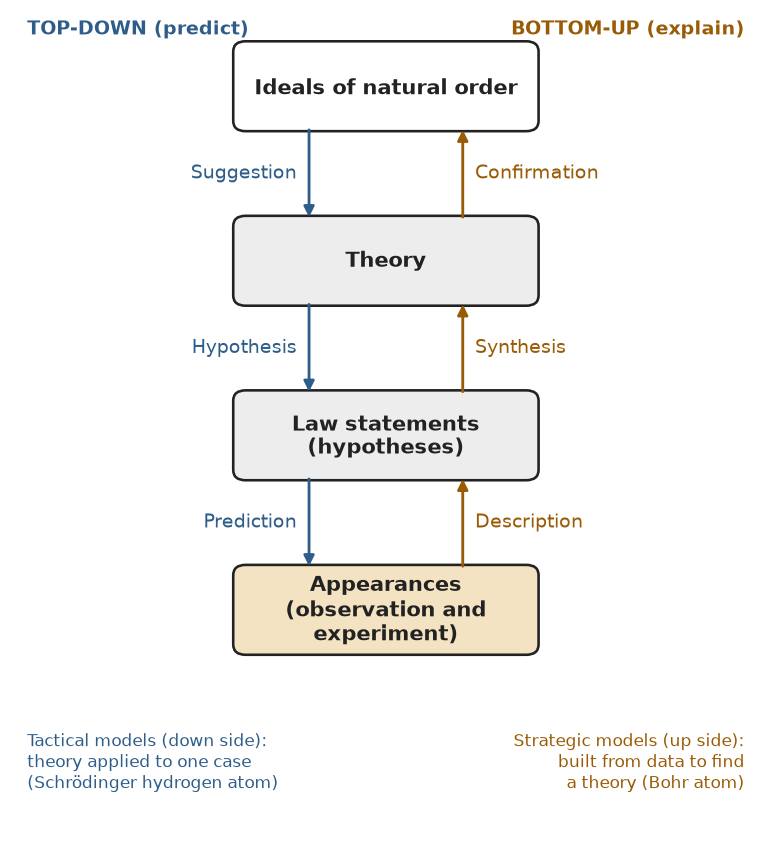

1. **The ladder (after Figure 13.1.3).** From top to bottom: ideals of natural order; theory; law statements (the hypotheses a theory generates); and appearances, the results of observation and experiment. Above it all lie the metaphysical assumptions (nature is ordered, comprehensible and communicable) and the paradigm of the field.

2. **Down the ladder (top-down): suggestion.** The ideals of natural order suggest what kind of theory to build. Newton's ideal that bodies move in straight lines unless a force acts on them suggested a theory in which every curved path needs a force.

3. **Down: hypothesis.** The theory generates hypothetical law statements for particular situations: if gravity follows the inverse-square law, then each planet's orbit is a calculated ellipse, slightly disturbed by the other planets.

4. **Down: prediction.** Law statements yield predictions of the form "If A then B" that can be compared with appearances: given these positions today, Uranus should be at this point next year.

5. **Up the ladder (bottom-up): description.** Observations are described in the theory's categories: measured positions of Uranus become an observed orbit.

6. **Up: synthesis.** Described regularities are synthesized into law statements and built into a theory, inductively and on the basis of observed symmetries and distinctions: Kepler's laws were synthesized from Tycho's measurements, and Newton's theory unified them.

7. **Up: confirmation.** When the theory fits the appearances, it confirms the ideals it embodies. The successful prediction of Neptune from the deviations in Uranus's orbit confirmed both Newton's theory and its ideals (Derry pp. 48-50).

8. **Where tactical models go.** On the downward side. A tactical model applies an existing theory to a specific case: the Schrödinger equation for the hydrogen atom (Discussion 11.3), or Newton's theory applied to the orbit of Uranus. Discussion 13.1 calls this use of theory to fit regularities in specific cases "tactical modeling."

9. **Where strategic models go.** On the upward side. A strategic model is built to fit observations in the hope of reaching a theory: the Bohr atom, built to fit the hydrogen spectrum before quantum mechanics existed (Discussion 11.3).

10. **The ladder is a cycle.** The two directions run together: predictions are tested against appearances, and the results feed back up through description and synthesis. When a prediction fails, as with Mercury's orbit, the search moves up the ladder for the faulty level, which in that case was the theory itself.

U13-A06Applied10 marks

Give original formal, causal, statistical and functional explanations of familiar phenomena. For each, identify one limitation or question that would test its adequacy.

Source Discussion 13.1 Part Two

1. **Formal explanation.** "Copper conducts electricity because it is a metal." The property is explained by the category the thing belongs to.

2. **Its limitation and test.** If "metal" is partly defined as "conducts electricity," the explanation is circular, like explaining opium's effect by a "dormative (i.e., sleep producing) principle." Test it by asking whether the category is defined independently of the property, and whether every member of the category has the property; a deeper answer (free electrons in metals) turns it into a causal explanation that can be checked.

3. **Causal explanation.** "The ice on my windshield melted because the morning sun warmed the glass above 0 °C." Initial conditions (sunlight on the glass, ice) and a natural law (ice melts above 0 °C) make the event follow.

4. **Its limitation and test.** The stated cause may not be the only one: warmer air or the car's defroster could have done it. Test it by comparing: shade half of the windshield on a similar morning and see whether the shaded ice stays frozen. Beware assuming that there is only one cause (Discussion 13.1).

5. **Statistical explanation.** "This patient's lung cancer was probably related to their 40 years of smoking, because long-term smokers have a much higher rate of lung cancer." The event is explained as highly probable given the situation, as insurance rates are set by risk group.

6. **Its limitation and test.** A high probability is not a certainty: some smokers never develop cancer and some non-smokers do, so the explanation cannot settle one case. Test it on populations: compare cancer rates between groups that differ in smoking and are similar in other ways, and check that the rate rises with the amount smoked.

7. **Functional explanation.** "Geese fly south in autumn because migration lets them reach food and open water through the winter." The behaviour is explained by the function it serves, its survival value.

8. **Its limitation and test.** It says *why* the behaviour is useful but not *how* it is produced, and such explanations can become circular ("it exists because it helps survival, and we know it helps because it exists"). Test it by asking what triggers departure (day length, temperature, food) and whether birds given plenty of food still leave; if they do, a causal mechanism is needed alongside the function.

9. **Mixtures.** Real explanations often combine forms: "Geese evolved to migrate because migrants survived winter better" is functional and causal, and the smoking case is statistical with a causal claim behind it.

10. **What decides adequacy.** In each case the question that tests adequacy is the same: does the explanation say something that could be checked and could fail? Whether a form of explanation is acceptable depends on the context and the state of the science (Discussion 13.1).

Note*The four examples are original. Outside the readings: smoking and lung cancer rates, and the role of day length in triggering bird migration.*

U13-A07Applied5 marks

Someone explains a device's action by renaming it as a power to act that way. Explain the danger of an empty formal explanation and how a testable mechanism would improve it.

Source Discussion 13.1 Part Two

1. **The empty explanation.** "The thermostat turns the furnace on when the room gets cold because it has a temperature-regulating power." This just renames the action as a power to act. It is a formal explanation of the worst kind, like explaining opium's sleep-inducing property by a "dormative (i.e., sleep producing) principle" (Discussion 13.1).

2. **Why it is empty.** It adds no information: "a power to regulate temperature" means only "it regulates temperature." It names no parts, no process and no conditions.

3. **Why it is dangerous.** It sounds like an explanation, so it can stop inquiry. Because it predicts nothing, no observation could ever count against it: if the thermostat failed, one could say its power was "weak." An explanation that cannot fail cannot be tested, and so it is not scientific.

4. **A testable mechanism.** Inside a traditional thermostat is a bimetallic strip: two metals bonded together that expand by different amounts when heated, so the strip bends as the temperature changes. When the room cools, the strip bends far enough to close an electrical contact, and the closed circuit switches the furnace on.

5. **Why the mechanism is better.** It makes predictions that could fail: warming the strip with a hair dryer should switch the furnace off even though the room is cold; adjusting the dial moves the contact and so changes the switching temperature; a broken strip or a dirty contact should cause specific faults. It also fits the known behaviour of its components, as the principle of composition requires.

Note*Outside the readings: how a bimetallic-strip thermostat works.*

U13-A08Applied5 marks

A barometer reading and storm frequency are correlated. Apply the common-cause principle and distinguish prediction from causal intervention.

Source Discussion 13.1 Part Two

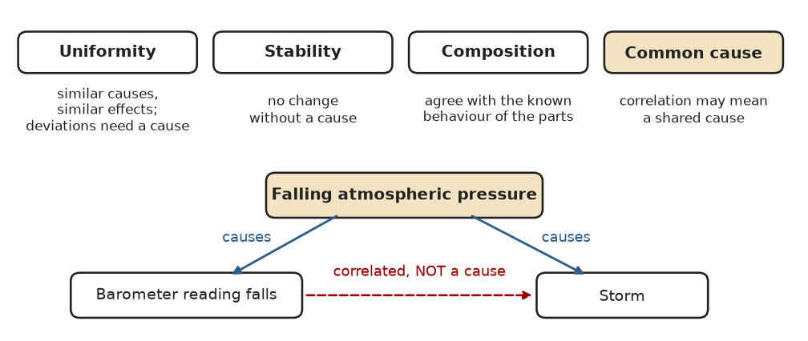

1. **The correlation.** A falling barometer is followed by storms far more often than chance would allow, so the two are correlated.

2. **The common-cause principle.** A constant correlation does not show that one event causes the other. It justifies only the assumption that both may depend on a common cause (Discussion 13.1). Here the common cause is falling atmospheric pressure, which lowers the barometer reading and also brings the conditions for storms.

3. **Prediction works.** For prediction, the correlation is enough. A sailor who sees the barometer falling is right to expect bad weather and to head for harbour. Prediction needs only a reliable regularity, not knowledge of what causes what.

4. **Intervention does not.** For causal intervention the correlation is useless. Pushing the barometer's needle down, or sealing the instrument so it reads low, would not make a storm, and holding the needle up would not prevent one. "A measurement cannot be a cause of the result being measured" (Discussion 14.1). To change the outcome one would have to act on the common cause, the pressure system itself.

5. **The general lesson.** Before acting on a correlation, ask whether a third factor drives both. A predictive sign and a lever for change are different things, and confusing them is the post hoc error of treating what comes first as the cause.

U13-A09Applied10 marks

Use an original example to distinguish uniformity, stability, composition and common cause. Explain how each principle guides inquiry without replacing empirical evidence.

Source Discussion 13.1 Part Two

Example (invented): office workers on the third floor of a building begin to complain of headaches every afternoon from March onward; the second floor, which is laid out the same way, has no complaints.

1. **Uniformity, stated.** Similar causes tend to have similar effects; when effects differ, a specific causal factor must account for the difference (Discussion 13.1).

2. **Uniformity, applied.** The two floors are alike in layout, staff and work, yet only one has headaches. So the investigators look for a factor present on the third floor but not on the second: a different ventilation zone, new furniture or a new photocopier.

3. **Stability, stated.** Change does not occur without a cause.

4. **Stability, applied.** The headaches began in March. Something must have changed then, so the investigators ask what did: a new ventilation schedule, new carpet, more staff on the floor, a change of season.

5. **Composition, stated.** A causal explanation must agree with the known behaviour of the components of what is being explained.

6. **Composition, applied.** Proposed causes must fit known physiology, chemistry and physics. Too little fresh air (a build-up of carbon dioxide) or fumes from new materials could cause headaches in known ways. A claim that the headaches come from "bad energy" in the floor is ruled out because it contradicts or ignores what is known about the components.

7. **Common cause, stated.** When two things are constantly correlated, one need not cause the other; both may depend on a common cause.

8. **Common cause, applied.** On the third floor, headaches are correlated with complaints that the air feels stuffy. Stuffiness may not cause the headaches; both may come from a ventilation system that reduces fresh air in the afternoon. Treating one symptom would then miss the cause.

9. **Guidance, not proof.** Each principle narrows the search: what differs (uniformity), what changed (stability), what is possible (composition) and what might lie behind a correlation (common cause). None identifies the cause. The investigators still have to gather evidence: measure carbon dioxide and fumes through the day, increase the fresh air on one floor and see whether the headaches stop, and compare with the control floor.

10. **Limits of the principles.** They are ideals of simplicity, not laws of nature. Uniformity fails in chaotic, non-linear systems, where tiny differences in causes produce large differences in effects, and complex problems often have several causes rather than one (Discussion 13.1). Only empirical evidence can decide.

U13-A10Applied5 marks

Classify these law descriptions and justify each choice: a restriction on simultaneous particle states; a rule for the next state of a single system; a rule for a collision. Give a stochastic variant of one.

Source Discussion 13.1 Table 13.1.1

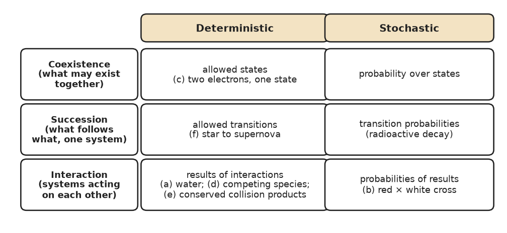

1. **A restriction on simultaneous particle states: coexistence.** It says which combinations of states may exist together at one time, as the exclusion principle forbids two electrons from being in the same quantum state. Nothing changes and nothing interacts, so it is a law of coexistence, and deterministic, since it simply allows or forbids.

2. **A rule for the next state of a single system: succession.** It gives the allowed transition from one state of a system to the next, as Newton's laws take a planet from its present position and velocity to the next. One system changing over time is the mark of a law of succession.

3. **A rule for a collision: interaction.** It describes the result when two or more systems act on each other, such as which products may emerge when particles collide. That makes it a law of interaction. If it states only which results are allowed (conservation of energy, momentum and quantum numbers), it also works like a coexistence rule for the possible products.

4. **A stochastic variant of succession: radioactive decay.** A law for an unstable nucleus gives no definite moment of decay; it gives a fixed probability that the nucleus will change to a new state in each unit of time. That is a stochastic law of succession: such laws "give the probability of a transition between states, representations or both" (Table 13.1.1).

5. **Why the distinction matters.** A stochastic law is tested differently: its prediction is a frequency (half of a large sample decays in one half-life), checked statistically over many cases, not by watching one atom. A stochastic version of the collision rule would likewise give the probability of each possible set of products.

Note*Outside the readings: half-life as the time in which half of a large sample decays.*

U13-A11Applied5 marks

Distinguish a regularity in nature from its formulation within a theory. Use changing accounts of gravity to explain how a law statement may change while some observed patterns remain.

Source Discussion 13.1 Part Two

1. **Regularity and formulation.** A regularity is the pattern in nature itself: unsupported objects fall, the Moon circles the Earth, the tides follow the Moon. A law statement is our formulation of that pattern within a theory, and so it depends on the theory's concepts. "The map is not the territory" (Discussion 13.1).

2. **Common sense and Aristotle.** "What goes up must come down" is a limited statement: CFCs stay in the upper atmosphere for years and the Voyager spacecraft will never return. Aristotle said heavy, earthy things seek their natural place at the centre, while fire rises to its sphere. That explained the appearances within his theory, but his theory was faulty, not the phenomena.

3. **Newton.** Newton restated the law as a force between any two masses, proportional to the product of the masses and inversely proportional to the square of the distance. The same statement covered falling apples, the Moon's orbit and the tides, and it allowed very accurate calculations of orbits.

4. **Einstein.** General relativity replaced Newton's statement with one in which there is no gravitational force at all: masses curve spacetime and bodies follow the curvature. Attempts at quantum gravity may bring back a kind of force carried by gravitons. Each time the law statement changed.

5. **What remained.** Through every change, the observed patterns stayed the same: stones still fall, planets still orbit and the tides still follow the Moon. Each new law statement had to reproduce the patterns the old one fitted, and it added the ones the old one missed, such as the motion of Mercury's orbit that Newton's statement could not explain. The regularity stayed; its formulation changed.

Note*Outside the readings: the excess motion of Mercury's orbit explained by general relativity.*

U13-A12Applied10 marks

Give examples of intuitional, historical, qualitative, taxonomic, statistical and dynamical theories. Compare their different forms of prediction and testing.

Source Discussion 13.1 Part Three

1. **Intuitional: Freud's theory of neurosis.** It explains a neurosis after the fact through theoretical entities such as defence mechanisms fixed by childhood trauma, but it cannot predict that a given trauma will produce a neurosis, or which one. Prediction: almost none. Testing: mainly whether its explanations seem to fit cases, the weakest kind of test.

2. **Historical: the impact that ended the dinosaurs.** It reconstructs a unique past event. Prediction: further traces in the record. The theory began from a worldwide iridium-rich layer and predicted a large crater of the same age; the Chicxulub crater was found later. Testing: searching the record for predicted traces that might not have been there.

3. **Qualitative: weather forecasting.** It organizes masses of qualitative and measured data (temperature, pressure, humidity, the jet stream) and feeds them into simulation models. Prediction: likely developments, often as probabilities. Testing: comparing forecasts with what happens, over many days.

4. **Taxonomic: the periodic table.** It classifies elements by their properties and predicts from class membership. Prediction: an element's behaviour from its group, and even unknown elements from gaps (gallium and germanium were found to fit Mendeleev's predictions). Testing: checking new members against their class's expected properties.

5. **Statistical: population genetics.** It predicts expected gene frequencies in a population, not the genes of one individual. Prediction: probabilities over ensembles. Testing: statistical comparison of observed frequencies with expected ones, over large samples.

6. **Dynamical: Newtonian mechanics.** A state (positions and velocities) plus equations of motion fixes every future state. Prediction: exact, as in eclipse dates or a spacecraft's path. Testing: precise measurement against precise prediction, where even a small discrepancy matters (Uranus's orbit).

7. **Comparing prediction.** The six form a range, from intuitional theories that barely predict, through historical theories that predict only traces, qualitative and taxonomic theories that predict patterns and class properties, to statistical theories that predict frequencies and dynamical theories that predict exact states.

8. **Comparing testing.** Dynamical theories can be tested by repeatable experiments and single precise observations. Statistical theories need many cases. Historical theories cannot repeat their event and must be tested by traces that might have been absent. Intuitional theories are the hardest to test, which is their main weakness.

9. **Mixtures.** Many theories have more than one type: plate tectonics is intuitional, historical and qualitative, and particle physics is taxonomic, dynamical and stochastic (Discussion 13.1). Such theories can be tested in several ways at once.

10. **One standard for all.** Whatever the type, Margenau's six criteria apply: logical fertility, multiple connection, stability, extensibility, causal connections, and simplicity and elegance. A type that predicts less is not unscientific, but it must still face whatever tests its form allows.

Note*Outside the readings: the periodic table example (as in Study Question 6).*

U13-A13Applied5 marks

Use Margenau's six course criteria to evaluate a hypothetical theory that is elegant and comprehensive but yields no possible empirical test. Identify the strongest and weakest features.

Source Discussion 13.1 Part Three

1. **The case and the course's standard.** The hypothetical theory is elegant and comprehensive but yields no possible empirical test. The Overview requires that theories be "both internally coherent and empirically testable, at least in principle," which is why string theory is treated as awaiting tests and creation in 4004 BCE as a matter of faith.

2. **Strongest features: simplicity and elegance, and extensibility.** It meets Margenau's sixth criterion fully, and if it is comprehensive its constructs reach beyond their original area, which looks like extensibility. Its constructs may also be well connected to each other.

3. **Weak: logical fertility and causal connections.** Its constructs must give "a basis for fruitful deductions and the construction of hypotheses." Deductions that can never be checked are not fruitful in the scientific sense. Its claimed causal connections to phenomena cannot be confirmed either, since no observation could tell whether they are real.

4. **Weakest: stability and multiple connection to observation.** Stability means the theory can adapt to new data, but no data bear on it, so it can neither adapt nor be corrected. Its constructs are connected to each other but not to observation, so their multiple connection is internal only.

5. **Verdict.** Elegance counts for a lot in science, as Dirac's remark shows, but it is the last criterion, not a substitute for the others. A theory that no observation could ever count against is, like the invisible substance on Galileo's Moon (Derry p. 200), outside science until a test becomes possible. The right response is to look for consequences that could be tested, as physicists hope to do for string theory.

U13-A14Applied5 marks

Explain how a historical theory can predict evidence not yet found even though the historical event cannot be repeated. Use a course example and a possible disconfirming observation.

Source Discussion 13.1 Part Three

1. **How a historical theory predicts.** It reconstructs a unique event and predicts the traces the event must have left. The event cannot be repeated, but the traces are evidence that can still be searched for (Discussion 13.1). Prediction here means predicting what will be *found*, not what will *happen*.

2. **The course's example.** The theory that a large meteor or comet ended the dinosaurs began with a worldwide layer of iridium in sediments about 65 million years old, far richer than earthly processes produce but matching meteorites. From the hypothesized impact, researchers deduced its other geological consequences and searched for them.